[figure not shown]

# 表象与本质SURFACES AND ESSENCES

# 表象与本质SURFACES AND ESSENCES

类比——思维的燃料与火焰

ANALOGY AS THE FUEL AND FIRE OF THINKING

道格拉斯·侯世达 与 埃马纽埃尔·桑德尔

DOUGLAS HOFSTADTER & EMMANUEL SANDER

Basic Books出版社

BASIC BOOKS

珀修斯出版集团成员

A Member of the Perseus Books Group

纽约

New York

谨向下列个人与机构致谢，感谢他们允许我们使用其提供的材料，或引用其拥有版权的文献。我们已尽一切努力寻找本书所转载材料的版权所有者。凡经告知的疏漏，均将在后续版本中更正。

Grateful acknowledgment is hereby made to the following individuals and organizations for permission to use material that they have provided or to quote from sources for which they hold the rights. Every effort has been made to locate the copyright owners of material reproduced in this book. Omissions that are brought to our attention will be corrected in subsequent editions.

马克·吐温照片：© CORBIS

Photograph of Mark Twain: © CORBIS

爱德华·格里格照片：© Michael Nicholson/CORBIS

Photograph of Edvard Grieg: © Michael Nicholson/CORBIS

阿尔伯特·爱因斯坦照片：© Philippe Halsman/Magnum Photos

Photograph of Albert Einstein: © Philippe Halsman/Magnum Photos

阿尔伯特·施韦泽照片：© Bettmann/CORBIS

Photograph of Albert Schweitzer: © Bettmann/CORBIS

我们还要最热忱地感谢凯莉·古特曼和托尼·霍格兰德，感谢他们慷慨地允许我们在本书中发表其诗作。

We also most warmly thank Kellie Gutman and Tony Hoagland for their generous permission to publish their poems in this volume.

版权 © 2013，Basic Books出版社

Copyright © 2013 by Basic Books

Basic Books出版社出版

Published by Basic Books

珀修斯出版集团成员

A Member of the Perseus Books Group

设计：道格拉斯·侯世达

Designed by Douglas Hofstadter

封面：妮科尔·卡普托和安德烈娅·卡德纳斯

Cover by Nicole Caputo and Andrea Cardenas

版权所有。未经书面许可，不得以任何方式复制本书的任何部分，但评论文章和书评中包含的简短引文除外。欲了解有关信息，请联系Basic Books出版社，地址：250 West 57th Street, New York, New York 10107。

All rights reserved. No part of this book may be reproduced in any manner whatsoever without written permission, except in the case of brief quotations embodied in critical articles and reviews. For information, please contact Basic Books at 250 West 57<sup>th</sup> Street, New York, New York 10107.

企业、机构及其他组织在美国大批量购买Basic Books出版社出版的图书，可享受特别折扣。详情请联系珀修斯出版集团特别市场部，地址：2300 Chestnut Street, Suite 200, Philadelphia, Pennsylvania 19103；或致电(800) 810-4145，分机5000；或发送电子邮件至special.markets@perseusbooks.com。

Books published by Basic Books are available at special discounts for bulk purchases in the United States by corporations, institutions, and other organizations. For more information, please contact the Special Markets Department at the Perseus Books Group, 2300 Chestnut Street, Suite 200, Philadelphia, Pennsylvania 19103, or call (800) 810-4145, ext. 5000, or send an email to: special.markets@perseusbooks.com.

美国国会图书馆控制号：2013932688

Library of Congress Control Number: 2013932688

ISBN：978-0-465-02158-1（电子书）

ISBN: 978-0-465-02158-1 (e-book)

10 9 8 7 6 5 4 3 2 1

献给弗朗切斯科·比安基尼

To Francesco Bianchini

以及

and

献给米卡埃尔、汤姆和塔莉娅

To Michaël, Tom, and Talia

## 目录TABLE OF CONTENTS

致谢

Words of Thanks

序言 类比：认知的核心

Prologue Analogy as the Core of Cognition

第一章 词语的唤起

Chapter 1 The Evocation of Words

第二章 短语的唤起

Chapter 2 The Evocation of Phrases

第三章 看不见的类比的浩瀚海洋

Chapter 3 A Vast Ocean of Invisible Analogies

第四章 抽象与范畴间的滑移

Chapter 4 Abstraction and Inter-category Sliding

第五章 类比如何左右我们

Chapter 5 How Analogies Manipulate Us

第六章 我们如何运用类比

Chapter 6 How We Manipulate Analogies

第七章 朴素类比

Chapter 7 Naïve Analogies

第八章 震撼世界的类比

Chapter 8 Analogies that Shook the World

尾声对话 凯蒂和安娜辩论认知的核心

Epidialogue Katy and Anna Debate the Core of Cognition

注释

Notes

参考文献

Bibliography

索引

Index

## 致谢WORDS OF THANKS

### 一点背景**A Little Background**

回首往事，怀着温情重温本书的诞生过程，我们鲜明地记得第一个关键时刻：1998年7月中旬，保加利亚索非亚的一次学术大会。那是首届以类比为主题的国际会议。这次令人难忘的会议由博伊乔·科基诺夫、基思·霍利奥克和德德蕾·根特纳组织，汇集了许多国家的研究人员，大家在轻松活泼的气氛中，就共同热衷的领域交换想法。机缘就这样让我们二人在索非亚初次相遇，我们发现彼此一见如故——那是一簇愉快而明亮的火花，逐渐发展成为长期而牢固的友谊。

As we look back, fondly reliving the genesis of our book, we vividly recall the first key moment, which took place in mid-July, 1998, at an academic congress, in Sofia, Bulgaria. The occasion was the first international conference on the subject of analogy. Organized by Boicho Kokinov, Keith Holyoak, and Dedre Gentner, this memorable meeting assembled researchers from many countries, who, in an easy-going and lively atmosphere, exchanged ideas about their shared passion. Chance thus brought the two of us together for the first time in Sofia, and we found we had an instant personal rapport — a joyous bright spark that gradually developed into a long-term and very strong friendship.

2001—2002年，道格拉斯·侯世达在意大利博洛尼亚度过了一个学术休假年，其间受让-皮埃尔·迪皮邀请，到巴黎综合理工学院做了一系列关于认知的讲座。当时，埃马纽埃尔·桑德尔刚出版自己的第一本书——一部深入研究类比形成与范畴化的著作——在其中一次讲座上，他自豪地把一本书赠给这位新朋友。后者读完后欣喜地发现，自己与该书作者对认知究竟是什么的看法竟如此深刻地相似。随后又过了一段时间，我们在巴黎和图卢兹有过几次短暂聚会，辅以电子邮件往来和电话交谈，既交流思想，也增进友情。

In 2001–2002, Douglas Hofstadter spent a sabbatical year in Bologna, Italy, and during that period he was invited by Jean-Pierre Dupuy to give a set of lectures on cognition at the École Polytechnique in Paris. At that time, Emmanuel Sander had just published his first book — an in-depth study of analogy-making and categorization — and at one of the lectures he proudly presented a copy of it to his new friend, who, upon reading it, was delighted to discover how deeply similar was the vision that its author and he had of what cognition is really about. And then some time passed, with a couple of brief get-togethers in Paris and Toulouse, supplemented by email exchanges and phone calls, mixing intellectual content and friendly feelings.

2005年2月，道格邀请埃马纽埃尔到布卢明顿，参加他为自己众多朋友举办的盛大生日聚会，庆祝自己年满60岁。聚会期间的一天，他向埃马纽埃尔提议，自己十分愿意去巴黎住几周，与埃马纽埃尔合作，把他的书译成英语。埃马纽埃尔非常高兴。不过，道格7月抵达巴黎后不久，原先的目标就变成了一个大得多的目标：合著一本讨论类比在思维中根本作用的书，以非技术性的方式，从多个角度探讨这一主题，并用大量具体例子来论证理论立场。我们希望这本书能让任何对思维感兴趣的人读懂，同时又抱有远大志向：面向学术读者，对认知提出一种全新而独创的立场。这便是本书孕育的时刻！

In February of 2005, Doug invited Emmanuel to Bloomington for a gala birthday party he was throwing for his many friends, as he turned 60. One day during that event, he suggested to Emmanuel that he would be very happy to come to Paris for a few weeks to work with Emmanuel in translating his book into English. Emmanuel was very pleased, but shortly after Doug arrived in Paris in July, the original goal mutated into a considerably larger one — namely, that of co-authoring a book on the fundamental role of analogy in thought, approaching the topic in a non-technical manner and from many points of view, and using a large sampling of concrete examples to justify the theoretical positions. The book would hopefully be accessible to anyone interested in thinking, yet would also have the high ambition of reaching an academic audience and of putting forth a new and original stance towards cognition. This thus was the moment of our book’s conception!

在巴黎的三周里，各种想法不断碰撞，最后产生了一份四十页的文稿，其中有两位未来合著者的谈话片段、许多有关本书构想的笔记，以及一份极其初步的章节草图。随后四年，即2006至2009年间，每位作者每年都到另一位居住的城市访问一个月。此外，道格2010年还在巴黎度过了八个月的学术休假。整个期间，我们始终通过电子邮件和电话交换思想，让这本书从几个细胞成长为一个能够存活的复杂有机体。

Over a three-week period in Paris, many ideas were tossed about, and the result was a forty-page document that featured snips of conversations between the two future co-authors, many notes on ideas for the book, and a very preliminary sketch of what its chapters might look like. And then, for the next four years — 2006 to 2009 — each of the authors made a month-long visit to the other one in his home town. Adding to that, Doug spent an eight-month sabbatical in Paris in 2010. During all this time, there was a constant exchange of ideas via email and via phone, allowing the book to evolve from a few cells into a viable complex organism.

这一切表明，本书是长期合作的结晶，如今终于成熟了。作者们寄希望于它所传达的信息具有持久的价值，尽管它显然植根于当今的文化与生活方式——事实上，它植根于“鲜活的思想”，我们深情地记得一位朋友这样说过。不过，我们希望，尽管它的起源具有特定的时空背景，其核心思想仍有足够的普遍性，经得起时间的考验。

As all this shows, the present book is the fruit of a long collaboration, and finally it has reached maturity. Its authors have invested in it the hope that it has a message with enduring value, even if it is clearly rooted in today’s culture and style of life — in fact, it is rooted “in vibrant thought”, as we fondly recall one of our friends putting it. But we hope that, despite the spatial and temporal specificity of its origins, its key ideas are universal enough that they will withstand the passage of time.

### 在语言与文化之间打乒乓球**Ping-ponging between Languages and Cultures**

我们的合著是一种非常不寻常的创作过程的产物，对此我们颇感自豪。它不仅由两个人撰写，而且同时用两种语言撰写。更具体地说，本书有两个原本——一个法语原本，一个英语原本。两者互为译本，也可以说，两者都不是译本。但无论你选择怎样看待它，本书的两个版本都享有同等地位。它们是同一个无形实体的两种截然不同的具体化身——这个实体就是本书，它存在于并非由词语而是由思想构成的缥缈层面。

We are quite proud of the fact that our joint book is the result of a very unusual creative process. Not just written by two people, it was written in two languages at the same time. To be more specific, this book has two originals — one in French and one in English. Each is a translation of the other, or perhaps neither of them is a translation. But however you choose to look at it, the two versions of this book have equal standing. They are two highly distinct concrete incarnations of one immaterial entity — namely, this book as it exists on the ethereal plane not of words but of ideas.

诚然，写作过程涉及无数次翻译，但这些翻译恰好发生在原文生成的同时。有时，它们把思想从英语带入法语，有时则朝着相反方向进行。这里的关键在于，两位作者的大脑之间来来回回的交流，伴随着——这是很少见的——两种语言之间来来回回的交流。这些交流以逐渐趋于一致的方式，促使原文经历许多修改，使它与其译文更加贴合；接着，修改后的文字再次绕行于这个双语、双文化、双脑的回路，直到经过相当多次往返迭代，终于达到令人满意的平衡。

To be sure, the writing process involved countless acts of translation, but those acts took place at the very moment that the original text was being generated. Sometimes they carried ideas from English to French, and sometimes they went in the other direction, but what is key here is that these back-and-forth exchanges between the brains of the two authors were accompanied — and this is a rare thing — by back-and-forth exchanges between two languages, which led, in a convergent fashion, to many modifications of the original text, bringing it into closer alignment with its translation, and then the resulting text went once more around the bilingual, bicultural, bicerebral loop, until finally, after a good number of iterations back and forth, things reached a satisfactory equilibrium.

因此，这两个版本——你现在读到的英语版，以及相应的法语版——已多次来回穿过两种语言的过滤器。我们常常发现，这种特别的动态过程使文字变得高度清晰，因为翻译最擅长的莫过于毫不留情地揭露不精确、含糊和逻辑不畅之处。翻译把这些缺陷照得一清二楚，就像在积满灰尘的阁楼里打开一只手电筒。另一个隐喻是磨刀，因为反复交流的过程，对我们而言成了不断磨砺我们试图表达的思想的过程。因此，本书拥有两个原本这一事实，不仅是一件有趣的新奇事，更重要的是，它成了一条指导原则，使我们始终专注于连贯与明晰这一目标。至少我们这些作者是这样看待本书的，而我们希望读者也能像我们一样看待它。

And thus the two versions — the English one that you are now looking at, and its counterpart in French — have gone back and forth many times through the filters of both languages. Often we would find that a high level of clarity emerged as a result of this special dynamic, as translation is nothing if not a merciless revealer of imprecision, vagueness, and lack of logical flow. Translation brings such defects out like a flashlight turned on in a dusty attic. A different metaphor is the sharpening of a knife, because our process of repeated exchanges became, for us, a constant act of sharpening of the ideas we were trying to express. And thus the fact that this book has two originals is not merely an amusing curiosity, but more importantly, it has been a guiding principle keeping us constantly focused on the goal of coherence and lucidity. At least we, the authors, see our book in this way, and we hope that our readers will see it as we do.

我们鼓励那些熟悉法语的英语读者，试着把两个版本中的几段文字对照阅读，因为每个具体版本都利用了深深植根于其所面向的文化中的思想、意象和表达方式。这使写作成为一项让两位作者都格外享受、备受启发的练习：我们不断面临挑战，要为某个惯用短语、某种情境，或某个口误，想出恰当的类比对应物；寻找最佳例子的过程，确实使我们始终保持警觉。因此，对任何热爱语言的人而言，平行细读两种文本，除了会带来大量新思想（这当然是我们的首要目标），还应能提供一种特别的体验：品味以两种截然不同的方式具体呈现的思想——简言之，就是蛋糕上那一点美味的糖霜。

We encourage those of our English-speaking readers who are comfortable with French to try tackling a few passages in both versions, because each specific version takes advantage of ideas, images, and turns of phrase that are deeply rooted in the culture at which it is aimed. This fact made for a particularly enjoyable and stimulating exercise for both authors, in that we were constantly being challenged to come up with an apt analogue for, say, a given idiomatic phrase or a given situation, or perhaps a given speech error, and the quest for optimal examples really kept us on our toes. For anyone who loves languages, then, a parallel perusal of the two texts should provide, in addition to plenty of new ideas (which was of course our primary aim), a special experience of savoring ideas fleshed out in two contrasting ways — in short, a bit of delicious icing on the cake.

### 向这么多人说声“Merci”（谢谢）！**“Merci” to So Many!**

两位作者，两种语言，两段人生。本书写作期间，许多人以多种不同的方式参与了我们的生活，而生活一如预料地沿着不可预料的轨迹前行。因此，我们有许多由衷的情感要表达。

Two authors, two languages, two lives. While this book was being written, many people were involved with us in many diverse ways, and life predictably followed its unpredictable course. We thus have many heartfelt feelings to express.

排在首位的是我们无比珍爱的家人。对道格而言，首先是宝芬；对埃马纽埃尔而言，是塞西尔。她们是我们的缪斯，有趣又令人惊叹，爱着我们，也为我们所爱。“À B., C. – D., E.”，用法语和姓名首字母，就表达了一切。接下来是我们的孩子。对道格而言，儿子丹尼和女儿莫妮卡意味着一切。他们都富于幽默、活力、理想主义和艺术想象力，这些主要继承自他们慈爱的母亲卡萝尔；遗憾的是，她多年前便被从我们身边夺走。埃马纽埃尔这边，有爱护他人、热烈而冲动的米卡埃尔，敏感、善于交际而稳重的汤姆，以及顽皮、机智且富于创造力的塔莉娅；还有他们全心付出、充满爱意的母亲达妮埃拉。最近，道格这边有宝芬的儿子戴维，埃马纽埃尔这边有塞西尔的儿子阿蒂尔，加入了我们的家庭。他们的才华和温和的性情，为我们的生活增添了光彩。

At the top of the list are our families, whom we cherish immeasurably. For Doug this means first of all Baofen, and for Emmanuel it means Cécile. They are our muses, amusing and amazing, loving and beloved. “À B., C. – D., E.” says it all, using initials, in French. Next come our children. To Doug, his son Danny and daughter Monica mean everything. Both are rich in humor, verve, idealism, and artistic imagination, inherited largely from their loving mother Carol, who, alas, was torn from us so many years ago. On Emmanuel’s side, there are Michaël, who is protective, intense, and impetuous, and Tom, who is sensitive, social, and solid, and Talia, who is impish, witty and creative; and there is Daniela, their devoted and loving mother. Into our families have recently come, on Doug’s side, Baofen’s son David, and on Emmanuel’s side, Cécile’s son Arthur, who grace our lives with their talents and their gentle natures.

道格向妹妹劳拉·侯世达、她的丈夫伦·沙尔，以及他们两个都充满思想活力的儿子纳撒尼尔和杰里米，表达深深的感谢。这些年来，他们家举办过无数个“欢乐之夜”：高水平的槌球竞赛、狂放的文字魔法、令人捧腹的语义胡闹，再加上最可口的食物和最亲切的闲聊。与之有些对称的是，埃马纽埃尔热忱感谢戴维——可信赖的兄弟、富有洞见的同事——以及戴维的妻子韦罗妮克、他们的女儿汉娜和加布里埃拉，也就是他那两个光彩照人的侄女。埃马纽埃尔还向父母让-皮埃尔·桑德尔和弗朗丝·桑德尔致以最深切的谢意，感谢他们从他幼年起，就以能想象到的最慷慨的方式培育他成长。同样，道格也满怀无比的感激，回忆已故父母罗伯特·侯世达和南希·侯世达给予他的全部温情与鼓励。

Doug expresses many thanks to his sister Laura Hofstadter, her husband Len Shar, and their two sons, Nathaniel and Jeremy, both filled with intellectual brio. Over the years, their house has been the site of innumerable “jolly evenings” marked by crack croquet competitions, wild word-wizardry, and side-splitting semantic silliness, along with the yummiest of food and the chummiest of chatting. Somewhat symmetrically, Emmanuel warmly thanks David, trusted brother and insightful colleague, David’s wife Véronique, and their daughters Hannah and Gabriela, his radiant nieces. Emmanuel also extends his deepest gratitude to his father and mother, Jean-Pierre and France Sander, for having fostered his growth, from his earliest youth, in the most generous fashion imaginable. And Doug likewise recalls with enormous thanks all the warmth and encouragement of his late parents, Robert and Nancy Hofstadter.

在这七年多里，我们每个人都经历了失去几位感情至深的人的悲痛。在此，我们愿缅怀这些珍贵的身影：埃马纽埃尔这边的Raphaël Sander、Agnès Sander、Maurice Sander、Esther Sidi、Morgan Rogulski和Lucie Cohen，以及道格这边的Nancy Hofstadter、Helga Keller、Steve Larson、Valentino Braitenberg和Paolo Bozzi。

Over the course of these seven-plus years, each of us has experienced the grief of losing several people with whom the bonds ran very deep. Here we wish to honor the treasured memory of Raphaël Sander, Agnès Sander, Maurice Sander, Esther Sidi, Morgan Rogulski, and Lucie Cohen, on Emmanuel’s side, and of Nancy Hofstadter, Helga Keller, Steve Larson, Valentino Braitenberg, and Paolo Bozzi, on Doug’s.

现在，我们理应花一两段文字来谈谈Paragraphe（意为“段落”）实验室。自本书构思以来，它一直是埃马纽埃尔·桑德尔在巴黎第八大学的思想家园。主任Imad Saleh以热情、慷慨和活力，领导着这个人文价值与科学价值并存的实验室。在Paragraphe内部，CRAC研究组（法语“理解、推理与知识获取”的首字母缩写）由埃马纽埃尔·桑德尔和Raphaële Miljkovitch共同领导。埃马纽埃尔珍视与Raphaële的思想交流，也很高兴采用了她从两个年幼儿子口中收集的众多语言怪趣中的一些例子。CRAC是一支合作融洽的团队，成员的研究体现了发展心理学的许多不同侧面，彼此相处得如此融洽，以至于团队中孕育出了许多深厚友谊。

It behooves us now to devote a paragraph or two to Paragraphe, the laboratory that, ever since this book was conceived, has been Emmanuel Sander’s intellectual home at the University of Paris VIII. Its director Imad Saleh leads, with ebullience, generosity, and vigor, a laboratory where human and scientific values exist side by side. Within Paragraphe, the research group CRAC (a French acronym for “Understanding, Reasoning, and Knowledge Acquisition”) is led jointly by Emmanuel Sander and Raphaële Miljkovitch. Emmanuel treasures his intellectual exchanges with Raphaële, and he is delighted to have used some of the plentiful harvest she has made of linguistic oddities issuing from the mouths of her two young sons. CRAC is a cooperative team whose members represent many diverse facets of developmental psychology and get along so well that many strong friendships have come to bloom within it.

因此，我们要衷心感谢Jean Baratgin（专长为推理研究）、Christelle Bosc-Miné（问题解决）、Rémi Brissiaud（教育心理学）、Sandra Bruno（概念发展）、Anne-Sophie Deborde（依恋）、Corinne Demarcy（问题解决）、Sabine Guéraud（理解）、Caroline Guérini（心智理论）、Frank Jamet（朴素推理）、Hélène Labat（阅读学习）、Annamaria Lammel（文化心理学）、Jean-Marc Meunier（知识表征）、Sandra Nogry（概念发展）和Carine Royer（阅读学习）。埃马纽埃尔现在和过去的博士生，以他们的专注，以及思想的新鲜与开放，给予了他许多。他们的表现很难被超越。我们特别要提到Valentine Chaillet、Laurence Dupuch、Sylvie Gamo、Khider Hakem、Bruno Martin、Évelyne Mengue、Lynda Taabane和Emmanuel Trouche。我们也把Justine Pélouard的记忆珍藏在心中；她似乎正迈向辉煌的科学事业，生命却突然终止了。

And thus a big thank-you to Jean Baratgin (whose specialty is the study of reasoning), Christelle Bosc-Miné (problem-solving), Rémi Brissiaud (educational psychology), Sandra Bruno (conceptual development), Anne-Sophie Deborde (attachment), Corinne Demarcy (problem-solving), Sabine Guéraud (understanding), Caroline Guérini (theory of mind), Frank Jamet (naïve reasoning), Hélène Labat (learning to read), Annamaria Lammel (cultural psychology), Jean-Marc Meunier (knowledge representation), Sandra Nogry (conceptual development), and Carine Royer (learning to read). Emmanuel’s doctoral students, current and former, have given much to him through their dedication and the freshness and openness of their thinking. They are a hard act to follow. In particular, we mention Valentine Chaillet, Laurence Dupuch, Sylvie Gamo, Khider Hakem, Bruno Martin, Évelyne Mengue, Lynda Taabane, and Emmanuel Trouche. We also keep in our hearts the memory of Justine Pélouard, who seemed to be headed for a wonderful scientific career, when all at once her life came to an end.

在Paragraphe的其他团队中，我们想特别提到Anne Bationo、Ghislaine Azemard、Claude Baltz、Françoise Decortis、Hakim Hachour、Madjid Ihadjadene、Pierre Quettier、Alexandra Saemmer、Samuel Szoniecky和Khaldoun Zreik，感谢他们与埃马纽埃尔多次进行丰富的交流。这些年来，其中一些人已成为他深深珍视的朋友。埃马纽埃尔也愿向一些不属Paragraphe、但仍在心理学系工作的同事致谢，感谢他们活跃的思想和个人的温暖。他尤其感谢Marie-Carmen Castillo和Roxane Bordes，此外还有Aline Frey、Alain Blanchet、Samuel Demarchi、Sophie Frigout、Corinna Kohler、Michèle Montreuil、Tobie Nathan、Michael Pichat、Jean-Luc Picq和Frédéric Rousseau。

In other teams within Paragraphe, we would like to single out Anne Bationo, Ghislaine Azemard, Claude Baltz, Françoise Decortis, Hakim Hachour, Madjid Ihadjadene, Pierre Quettier, Alexandra Saemmer, Samuel Szoniecky, and Khaldoun Zreik for rich interactions with Emmanuel on numerous occasions. Over the years, some of them have become deeply appreciated friends. Emmanuel would also like to express his gratitude to a set of colleagues outside of Paragraphe, but still in the Psychology Department, for their lively ideas and their personal warmth. Above all, he thanks Marie-Carmen Castillo and Roxane Bordes, and then Aline Frey, Alain Blanchet, Samuel Demarchi, Sophie Frigout, Corinna Kohler, Michèle Montreuil, Tobie Nathan, Michael Pichat, Jean-Luc Picq, and Frédéric Rousseau.

道格的研究组FARG（“流动类比研究组”）起初在安娜堡，后来主要在布卢明顿；三十年来，组员们揭示了称为“类比形成”的这种难以捉摸的心理现象的丰富性。我们想到的是玛莎·梅雷迪思（开发了计算机模型Seek-Whence）、梅拉妮·米切尔（Copycat）、罗伯特·弗伦奇（Tabletop）、加里·麦格劳（Letter Spirit）、约翰·雷林（Letter Spirit）、詹姆斯·马歇尔（Metacat）、哈里·丰达利斯（Phaeaco）、弗朗西斯科·拉拉-达默（George）、阿比吉特·马哈巴尔（SeqSee）和埃里克·尼科尔斯（Musicat）。站在他们肩膀上、追随他们脚步的，是马修·赫尔利、本·科维茨、威廉·约克和戴维·本德。多年来，为FARG带来思想与洞见的其他人包括丹尼尔·德费（Numbo）、亚历克斯·林哈雷斯（Capyblanca）、戴维·莫泽（错误与幽默）、唐纳德·伯德、格雷·克洛斯曼、史蒂夫·拉尔森、哈米德·埃克比亚、戴维·查尔默斯、王培、彼得·苏伯、严勇、刘皓明、克里斯托夫·魏德曼、罗伊·勒班、莉安·加博拉和达米恩·沙利文。

The members of Doug’s research group FARG (“Fluid Analogies Research Group”), early on in Ann Arbor but mostly in Bloomington have, over three decades, shed much light on the richness of that elusive mental phenomenon called “analogy-making”. We are thinking of Marsha Meredith (who developed the computer model Seek-Whence), Melanie Mitchell (Copycat), Robert French (Tabletop), Gary McGraw (Letter Spirit), John Rehling (Letter Spirit), James Marshall (Metacat), Harry Foundalis (Phaeaco), Francisco Lara-Dammer (George), Abhijit Mahabal (SeqSee), and Eric Nichols (Musicat). Standing on their shoulders and following in their footsteps are Matthew Hurley, Ben Kovitz, William York, and David Bender. Others who have brought ideas and insights to FARG over the years include Daniel Defays (Numbo), Alex Linhares (Capyblanca), David Moser (errors and humor), Donald Byrd, Gray Clossman, Steve Larson, Hamid Ekbia, David Chalmers, Wang Pei, Peter Suber, Yan Yong, Liu Haoming, Christoph Weidemann, Roy Leban, Liane Gabora, and Damien Sullivan.

在FARG之外，许多国家中那么多挚友和才思闪耀的同事，都为道格的人生增添了不可或缺的丰富内容。先说法国吧，浮现在脑海中的名字包括弗朗索瓦·瓦努奇、雅克琳·亨利、塞尔日·阿罗什、丹尼尔·基希勒、丹尼尔·布纽、安德烈·马尔科维奇、雅克·皮特拉、保罗·布尔金、弗朗索瓦·雷卡纳蒂、吉尔·科恩、吉尔·埃斯波西托-法雷兹、阿兰·扎尔曼斯基、弗朗索瓦丝·斯特罗布、让-皮埃尔·斯特罗布、马蒂娜·勒莫尼耶、安娜·布尔吉尼翁、于贝尔·塞拉姆、卡琳·塞拉姆、莉亚娜·古尔吉亚、马克·科佩、杰夫·斯坦斯、西尔维娅·布西拉基、米歇尔·布吕莱和德尼·马尔博。再说总是如此热情地接待他的意大利，他想起了贝内代托·希梅米、路易莎·希梅米、朱塞佩·特劳特尔、平戈·隆戈、乔瓦尼·桑宾、阿尔贝托·帕尔梅贾尼、弗朗切斯科·比安基尼、毛里齐奥·马泰乌齐、亚历克斯·帕西、萨布丽娜·阿尔迪佐尼、阿基莱·瓦尔齐、奥利维耶罗·斯托克、恩里科·普雷达齐、克里斯蒂娜·佩罗尼、毛里齐奥·科多尼奥、恩里科·伦、保拉·图里纳、帕特里齐奥·弗罗西尼、厄扎尔普·巴巴奥卢、伊雷娜·恩里克斯、彼得罗·佩尔孔蒂、安德烈亚·帕多瓦，以及根科一家。

Beyond FARG, Doug’s life has been vitally enriched by so many good friends and sparkling colleagues in so many lands. Let’s start with France, where, among the names that come to mind, are François Vannucci, Jacqueline Henry, Serge Haroche, Daniel Kiechle, Daniel Bougnoux, André Markowicz, Jacques Pitrat, Paul Bourgine, François Récanati, Gilles Cohen, Gilles Esposito-Farèse, Alain Zalmanski, Françoise Strobbe, Jean-Pierre Strobbe, Martine Lemonnier, Anne Bourguignon, Hubert Ceram, Karine Ceram, Liana Gourdjia, Marc Coppey, Geoff Staines, Silvia Busilacchi, Michelle Brûlé, and Denis Malbos. Turning to Italy, where he has always been so warmly received, he is reminded of Benedetto Scimemi, Luisa Scimemi, Giuseppe Trautteur, Pingo Longo, Giovanni Sambin, Alberto Parmeggiani, Francesco Bianchini, Maurizio Matteuzzi, Alex Passi, Sabrina Ardizzoni, Achille Varzi, Oliviero Stock, Enrico Predazzi, Cristina Peroni, Maurizio Codogno, Enrico Laeng, Paola Turina, Patrizio Frosini, Ozalp Babaoglu, Irene Enriques, Pietro Perconti, Andrea Padova, and *la famiglia* Genco.

不过，我们也不该遗漏他在北美大陆的朋友和同事！因此，道格十分愉快地向以下诸位致意（排列次序相当随意）：斯科特·布雷什、格雷格·胡伯、卡伦·西尔弗斯坦、凯莉·古特曼、理查德·古特曼、卡罗琳·斯特罗布、格兰特·古德里奇、彼得·林比、斯科特·金、彼得·琼斯、史蒂夫·琼斯、布赖恩·琼斯、伊拉妮·扎布、弗朗西斯·扎布、戴维·波利坎斯基、查尔斯·布伦纳、英加·卡利纳、乔恩·泰勒、拉里·特斯勒、科琳·巴顿、彭蒂·卡内尔瓦、埃里克·汉堡、迈克尔·戈尔德哈伯、罗布·戈尔德斯通、凯蒂·伯纳、里奇·希夫林、吉姆·舍曼、科林·艾伦、约翰·克鲁施克、迈克·邓恩、布里昂·米切尔、丹·弗里德曼、乔治·施普林格、迈克·加瑟、戴维·赫茨、威利斯·巴恩斯通、须美枝·琼斯、贝齐·斯蒂拉特、马克·侯世达、丹尼尔·丹尼特、约翰·霍兰德、鲍勃·阿克塞尔罗德、迪克·尼斯贝特、肯·德沃斯金、比尔·卡夫纳、吉尔·福科尼耶、马克·特纳、莱拉·博罗迪茨基、马克·约翰逊、布巴尔·沃尔夫、乔·贝克、唐纳德·诺曼、伯纳德·格林伯格、约翰尼·温克、杰伊·柯林、约瑟夫·塞文、安东·库尔蒂、比尔·弗鲁赫特、格伦·沃西、玛丽琳·斯通、吉姆·法伦、伊芙·法伦、詹姆斯·普拉思、克里斯托弗·海因里希、卡伦·本特利、安·特雷尔、苏·温德、朱莉·蒂格、菲比·瓦洪古、克拉克·金伯林、约翰·里格登、莱昂·莱德曼、杰里·费舍尔、史蒂夫·朱、彼得·米克尔森、比尔·利特尔、保罗·琼卡、西德尼·内格尔、唐·利希滕贝格、菲利普·泰勒、西蒙娜·布鲁特拉格、道格·布鲁特拉格、桑迪·迈尔斯、克里斯滕·莫茨，以及最后但绝非最不重要的奥利（一只真正的金毛寻回犬）。更远处，散居世界各地的还有弗朗西斯科·克拉罗、彼得·史密斯、罗伯特·伯宁格、西里尔·埃尔布、约翰·埃利斯、亚历山大·劳、玛丽娜·埃斯基娜、马雷克·卡利纳、哈坎·托克尔和米歇尔·穆钦。向以上所有人，道格脱帽致以深深的谢意。

But we shouldn’t omit his friends and colleagues on the North American continent! Doug thus takes great pleasure in saluting (and in a fairly arbitrary order) : Scott Buresh, Greg Huber, Karen Silverstein, Kellie Gutman, Richard Gutman, Caroline Strobbe, Grant Goodrich, Peter Rimbey, Scott Kim, Peter Jones, Steve Jones, Brian Jones, Iranee Zarb, Francis Zarb, David Policansky, Charles Brenner, Inga Karliner, Jon Thaler, Larry Tesler, Colleen Barton, Pentti Kanerva, Eric Hamburg, Michael Goldhaber, Rob Goldstone, Katy Börner, Rich Shiffrin, Jim Sherman, Colin Allen, John Kruschke, Mike Dunn, Breon Mitchell, Dan Friedman, George Springer, Mike Gasser, David Hertz, Willis Barnstone, Sumie Jones, Betsy Stirratt, Marc Hofstadter, Daniel Dennett, John Holland, Bob Axelrod, Dick Nisbett, Ken DeWoskin, Bill Cavnar, Gilles Fauconnier, Mark Turner, Lera Boroditsky, Mark Johnson, Bubal Wolf, Joe Becker, Donald Norman, Bernard Greenberg, Johnny Wink, Jay Curlin, Joseph Sevene, Anton Kuerti, Bill Frucht, Glen Worthey, Marilyn Stone, Jim Falen, Eve Falen, James Plath, Christopher Heinrich, Karen Bentley, Ann Trail, Sue Wunder, Julie Teague, Phoebe Wakhungu, Clark Kimberling, John Rigden, Leon Lederman, Jerry Fisher, Steve Chu, Peter Michelson, Bill Little, Paul Csonka, Sidney Nagel, Don Lichtenberg, Philip Taylor, Simone Brutlag, Doug Brutlag, Sandy Myers, Kristen Motz, and last but not least, Ollie (truly a *golden* retriever). Further afield, scattered hither and yon around the globe, are Francisco Claro, Peter Smith, Robert Boeninger, Cyril Erb, John Ellis, Alexander Rauh, Marina Eskina, Marek Karliner, Hakan Toker, and Michel Moutschen. To all of the above, Doug tips a deeply thankful hat.

同样，许多朋友和同事影响了埃马纽埃尔关于思维的思想，丰富了他的智识、职业与个人生活。Jean-François Richard占据着一个特别尊崇的位置，因为他始终相伴，具有启发他人的天赋，以及非凡的创造动力。埃马纽埃尔还想提及那些与他长期交流、在许多方面给予他启发的同事所产生的深刻影响。他们包括Daniel Andler、Nicolas Balacheff、Jean-Marie Barbier、Claude Bastien、Luca Bonatti、Jean-François Bonnefon、Valérie Camos、Roberto Casati、Evelyne Clément、Jacques Crépault、Karine Duvignau、Michel Fayol、Jean-Paul Fischer、Bruno Gaume、Jean-Marc Labat、Jacques Lautrey、Ahn Nguyen Xuan、Jean-François Nicaud、Ira Noveck、Pierre Pastré、Sébastien Poitrenaud、Guy Politzer、Pierre Rabardel、Sandrine Rossi、Gérard Sensevy、Catherine Thevenot、Andrée Tiberghien、André Tricot、Jean-Baptiste Van der Henst、Gérard Vergnaud、Lieven Verschaffel和Bruno Villette。在更私人的层面，埃马纽埃尔想感谢那么多相交已久的朋友，感谢他们的忠诚和珍贵得难以言表的情谊：Youri Beltchenko、Florence Deluca Boutrois、Patrick Grinspan、Michaël Jasmin、Audrey Norcia、Franck Lelong、Gaëlle Le Moigne、Philippe Pétiard、Caroline Sidi、Nadine Zahoui和Marie-Hélène Zerah。

Many friends and colleagues have likewise influenced Emmanuel’s ideas about thought and have enriched his intellectual, professional, and personal life. Jean-François Richard occupies a special place of honor because of his constant presence, his gift of inspiring others, and his phenomenal creative drive. Emmanuel also wishes to cite the profound influence of colleagues with whom he has had long-time interactions and who have inspired him in many ways. These include Daniel Andler, Nicolas Balacheff, Jean-Marie Barbier, Claude Bastien, Luca Bonatti, Jean-François Bonnefon, Valérie Camos, Roberto Casati, Evelyne Clément, Jacques Crépault, Karine Duvignau, Michel Fayol, Jean-Paul Fischer, Bruno Gaume, Jean-Marc Labat, Jacques Lautrey, Ahn Nguyen Xuan, Jean-François Nicaud, Ira Noveck, Pierre Pastré, Sébastien Poitrenaud, Guy Politzer, Pierre Rabardel, Sandrine Rossi, Gérard Sensevy, Catherine Thevenot, Andrée Tiberghien, André Tricot, Jean-Baptiste Van der Henst, Gérard Vergnaud, Lieven Verschaffel, and Bruno Villette. On a more personal level, Emmanuel wishes to thank so many long-time friends for their loyalty and their indescribably valuable affection: Youri Beltchenko, Florence Deluca Boutrois, Patrick Grinspan, Michaël Jasmin, Audrey Norcia, Franck Lelong, Gaëlle Le Moigne, Philippe Pétiard, Caroline Sidi, Nadine Zahoui, and Marie-Hélène Zerah.

大西洋两岸的出版商都待我们极为亲切，给予了极大帮助。美国这边，John Sherer多年来一直坚信这本书的价值；他离开Basic Books出版社后，T. J. Kelleher和Lara Heimert继续让那热情的火焰温暖地燃烧。我们还想感谢Nicole Caputo、Andrea Cardenas、Tisse Takagi、Michele Jacob、Cassie Nelson和Sue Caulfield，感谢他们为本书的英语化身所作的出色贡献。法国这边，Odile Jacob和Bernard Gotlieb欢迎我们加入，并让我们知道他们会大力支持我们。我们尤其要感谢Jean-Luc Fidel对书稿细致的阅读，以及富于感受力的意见。我们也想感谢Jeanne Pérou、Cécile Andrier-Taverne和Claudine Roth-Islert，感谢他们在本书法国版的制作与发行中所做的优秀工作。

Our publishers on both sides of the Atlantic have been extremely cordial and helpful to us. On the American side, John Sherer was, for several years, a true believer in this book, and when he left Basic Books, T. J. Kelleher and Lara Heimert kept the enthusiastic fires warmly burning. We would also like to thank Nicole Caputo, Andrea Cardenas, Tisse Takagi, Michele Jacob, Cassie Nelson, and Sue Caulfield for their top-notch contributions to this work in its English-language incarnation. On the French side, Odile Jacob and Bernard Gotlieb welcomed us on board and made us know they would support us strongly. We owe special thanks to Jean-Luc Fidel for his meticulous reading of the manuscript and for his sensitive comments. We also wish to thank Jeanne Pérou, Cécile Andrier-Taverne, and Claudine Roth-Islert for their excellent work on the production and distribution of this book in France.

我们向David Bender、Steven Willliams和Jane Stewart Adams表达达最最深切的感谢，感谢他们为这本书细查错字和不合逻辑之处；相应地（mutatis mutandis），我们也感谢Christellle Bosc-Miné和Karine Duvignau为那本书做同样的细查。啊，当然不能忘记Greg Huber、Tom Seeber和D. Alvin Oyzeau，他们都对插图做了极有帮助的修整（有时也修整了事实！）。

We expresss deeepest gratitude to David Bender, Steven Willliams, and Jane Stewart Adams for scouring *this* book for typos and non sequiturs, and *mutatis mutandis*, we thank Christellle Bosc-Miné and Karine Duvignau for scouring *that* book. And no, certainly not to be forgotten are Greg Huber, Tom Seeber, and D. Alvin Oyzeau, all of whom tinkered most helpfully with the figures (and sometimes with the facts as well!).

不言而喻，道格的许多朋友成了埃马纽埃尔的朋友，反之亦然，这当然模糊了所有这些类别的边界。两个世界如此交融，是多年合作带来的重大额外收获之一。确实，有时这个过程显得如此漫长，仿佛永远不会结束；然而如今我们终于在为这本书作最后的润色了。在这一过程中，我们学到了大量关于思维、写作和语言的知识；我们希望读者能从我们共同的创作中得到乐趣，也希望得到启发。

It goes without saying that many of Doug’s friends have become friends of Emmanuel’s, and vice versa, which of course blurs the borders of all these categories. Such mingling of two worlds has been one of the great side benefits of so many years of work together. Indeed, sometimes the process seemed so long it would never end, and yet here we are, putting the finishing touches on this book. We have learned a great deal about thinking, about writing, and about language from this process, and we hope our readers will take pleasure in, and hopefully inspiration from, our joint creation.

# 表象与本质SURFACES AND ESSENCES

## 序言PROLOGUE

## 类比：认知的核心Analogy as the Core of Cognition

### 给予类比应有的地位Giving Analogy its Due

在这本关于思维的书里，类比和概念将担任主角，因为没有概念就不可能有思维，没有类比就不可能有概念。这就是我们将在全书中阐发并论证的主张。

In this book about thinking, analogies and concepts will play the starring role, for without concepts there can be no thought, and without analogies there can be no concepts. This is the thesis that we will develop and support throughout the book.

这一主张的含义是，我们头脑中的每一个概念，都因多年来无意识地进行的一长串类比而存在；这些类比最初孕育出概念，随后在我们的一生中不断使它丰富。此外，在我们生命的每一刻，大脑为了用旧有的、已知的事物来理解新的、未知的事物，不停地形成类比，这些类比又有选择地触发我们的概念。因此，本书的主要目标，就是给予类比应有的地位——也就是说，展示人类形成类比的能力如何处于我们一切概念的根基，以及概念如何被类比有选择地唤起。总而言之，我们想表明，类比是思维的燃料与火焰。

What we mean by this thesis is that each concept in our mind owes its existence to a long succession of analogies made unconsciously over many years, initially giving birth to the concept and continuing to enrich it over the course of our lifetime. Furthermore, at every moment of our lives, our concepts are selectively triggered by analogies that our brain makes without letup, in an effort to make sense of the new and unknown in terms of the old and known. The main goal of this book, then, is simply to give analogy its due — which is to say, to show how the human ability to make analogies lies at the root of all our concepts, and how concepts are selectively evoked by analogies. In a word, we wish to show that analogy is the fuel and fire of thinking.

### 词典没有告诉我们的概念知识What Dictionaries Don’t Say about Concepts

在应对这一挑战之前，我们需要清晰描绘概念的本质。人们很容易——事实上，几乎普遍如此——低估概念的精妙与复杂；尤其是词典还加强了这种把概念想得过于简单的倾向：它们把主词条划分成若干子词条，声称这样就能列明某个词的各种不同含义。

Before we can tackle this challenge, we need to paint a clear picture of the nature of concepts. It is easy — in fact, almost universal — to underestimate the subtlety and complexity of concepts, all the more so because the tendency to think of concepts in overly simple terms is reinforced by dictionaries, which claim to lay out the various different meanings of a given word by dividing the main entry into a number of subentries.

以名词“band”为例。任何一本规模过得去的词典，都会在这个词的总词条下列出几个子词条：一个把band说成可以缠绕东西的一条布带，另一个说明band可以是布料或其他表面上的彩色条带或条纹，再一个把band说成一小群乐手，他们通常演奏某些类型的音乐，或只使用某些类型的乐器；还有一个指共同工作或玩乐的一群人，一个指婚戒，一个指唱片或光盘上的一个曲目，一个指频率、能量、价格或年龄等的一个范围，也许还有其他几个。词典会清楚地列出这些各种各样的概念；它们彼此相当不同，却都由同一个词“band”涵盖，然后词典便就此打住，仿佛每一种较窄的意义都已解释得一清二楚，而且可以与其他所有意义分得干干净净。这一切看似不错，可它给人的印象却是，这个词的每一种较窄的意义，单独看来都是同质的，丝毫不存在问题，而且仿佛任何一种意义与其他意义之间都绝不可能混淆。然而，事实远非如此，因为这些子意义往往密切相关（例如彩色条纹与频率范围，或婚戒与缠绕某物的布带）；同时，“band”这个词的每一种据称清晰而独立的意义，本身都是复杂性的一道无底深渊。词典虽然给人以把词语一直分析到最基本原子的印象，实际上却只不过擦过它们的表面。

Take, for example, the noun “band”. In any reasonably-sized dictionary, there will be, in the overall entry for this word, a subentry describing a band as a piece of cloth that can be wrapped around things, another subentry describing how a band can be a colored strip or stripe on a piece of cloth or other type of surface, another subentry describing a band as a smallish set of musicians who tend to play certain types of music or to use only certain types of instruments, another one for a group of people who work or play together, another one for a wedding ring, another one for a selection on a record or a compact disk, another one for a range of frequencies or energies or prices or ages (etc.), and perhaps a few others. The dictionary will clearly set out these various concepts, all fairly distinct from each other and all covered by the same word “band”, and then it will stop, as if each of these narrow meanings had been made perfectly clear and were cleanly separable from all the others. All well and good, except that this gives the impression that each of these various narrower meanings of the word is, on its own, homogeneous and not in the least problematic, and as if there were no possible risk of confusion of any one of them with any of the others. But that’s nowhere near the truth, because sub-meanings are often closely related (for instance, the colored stripe and the range of frequencies, or the wedding ring and the piece of cloth wrapped around something), and because each of these supposedly clear and separate senses of the word “band” constitutes on its own a bottomless chasm of complexity. Although dictionaries give the impression of analyzing words all the way down to their very atoms, all they do in fact is graze their surfaces.

一个人可以花上许多年，编出一部巨大的、收录形形色色婚戒照片的集子；或者，同样地，编一部头带、爵士乐队或犯罪团伙的照片集——又或者收录千差万别的椅子、鞋、狗、茶壶，或字母“A”的各种形态的照片，如此等等——但任何这样的集子，都远远无法穷尽概念中潜藏的无限可能。事实上，确实有这种书，比如《1000把椅子》。如果椅子这一概念完全简单明了，就很难看出这样的书能有什么趣味。要欣赏某把椅子的美、独创性、实用性或风格，需要大量经验和专门知识，而词典连其中一丝一毫也无法传达。

One could spend many years compiling a huge anthology of photographs of highly diverse wedding bands, or, for that matter, an anthology of photos of headbands, or of jazz bands, or of bands of criminals — or then again, of photos of wildly different chairs or shoes or dogs or teapots or versions of the letter “A”, and on and on — without ever coming close, in any such anthology, to exhausting the limitless possibilities implicitly inherent in the concept. Indeed, there are books of precisely this sort, such as *1000 Chairs.* If the concept *chair* were completely straightforward, it is hard to see what interest such a book could possibly have. To appreciate the beauty, the originality, the practicality, or the style of a particular chair requires a great deal of experience and expertise, of which dictionaries cannot convey even an iota.

当然，关于各种band的精微之处，也可以作出类似的观察——一个人可以一生都研究爵士乐队、头带或犯罪团伙，等等。即使看似比它们简单得多的概念，实际上也是复杂性无边无际的沼泽。比如大写字母“A”这一概念。如果想要确切说明，在成千上万种我们毫不费力便视为该范畴成员的形状中，我们究竟认出了哪些共同点，就需要用复杂、近似法律条文的语言写上许多页。这远远超出了多数人对“A”概念的简单看法，即它由两条倾斜方向相反的斜笔画，以及把它们连接起来的一条水平横杠组成。

One could of course make similar observations concerning the subtleties of various types of bands — thus, one could spend one’s whole life studying jazz bands, or headbands, or criminal bands, and so forth. And even concepts that seem much simpler than these are actually endless swamps of complexity. Take the concept of the capital letter “A”, for instance. One would need many pages of text in complex, quasilegal language if one were trying to pin down just what it is that we recognize in common among the countless thousands of shapes that we effortlessly perceive as members of that category — something that goes way beyond the simple notion that most people have of the concept “A” — namely, that it consists of two oppositely leaning diagonal strokes connected by a horizontal crossbar.

事实上，对任何关注范畴丰富性的人而言，字体目录都是名副其实的金矿。在对面的插图中，我们汇集了一组为广告用途设计的大写“A”的样本。只需略加观察便能明白，任何事先凭空构想的“A性”概念，都会遭到其中一个或多个字母的反驳；但每一个字母又都完全可以辨认——即使单独展示时未必能毫不费力地认出，放在词语或句子的语境里，也肯定能认出。

Indeed, catalogues of typefaces are veritable gold mines for anyone interested in the richness of categories. In the facing figure, we have collected a sampler of capital “A” ’s designed for use in advertising, and as is clear from a moment’s observation, any *a priori* notion that one might have dreamt up of *A*-ness will be contradicted by one or more of these letters, and yet each of them is perfectly recognizable — if not effortlessly so when displayed all by itself, then certainly in the context of a word or sentence.

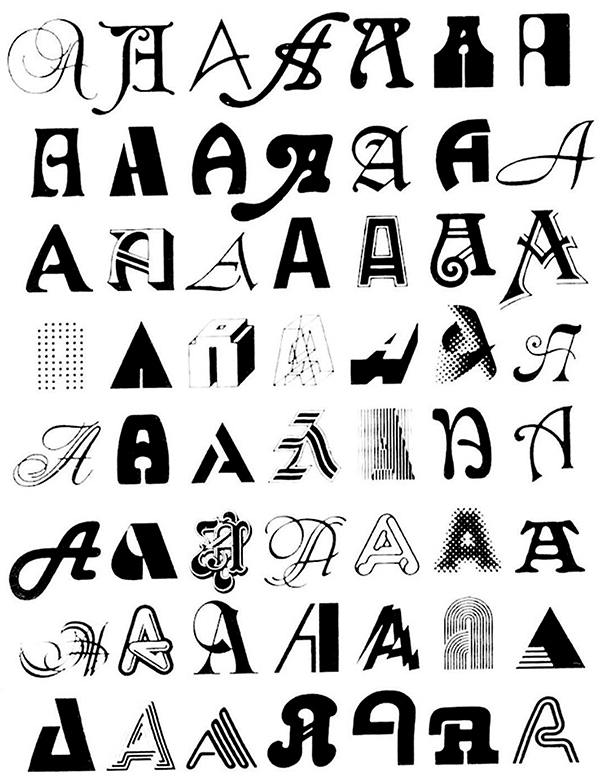

band、chair（椅子）、teapot（茶壶）、mess（一团糟）和letter ‘A’（字母“A”）这些日常概念，与prime number（质数）或DNA这样的专门概念十分不同。后者也拥有多得不可想象的成员，但其所有成员的共同点可以精确而无歧义地表达。相反，在支撑“band”“chair”“mess”或“teapot”等词的心理结构中，潜藏着无边无际、模糊不清的丰富内涵，而词典对此完全略而不谈，因为详细说明这种精微之处，并不是词典的目的。事实是，普通词语并非只有两三种意义，而是有无限多种意义，这个念头颇为吓人；但从更积极的一面来看，它意味着每个概念都有无限的多样性潜能。这是个相当令人愉快的念头，至少对那些充满好奇、受新奇事物激励的人而言如此。

The everyday concepts band, *chair, teapot, mess*, and letter *‘A’* are very different from specialized notions such as *prime number* or *DNA.* The latter also have unimaginably many members, but what is shared by all their members is expressible precisely and unambiguously. By contrast, in the mental structure underpinning a word like “band”, “chair”, “mess”, or “teapot” there lurks a boundless, blurry richness that is completely passed over by dictionaries, because spelling out such subtleties is not a dictionary’s aim. And the fact is that ordinary words don’t have just two or three but an *unlimited number* of meanings, which is quite a scary thought; however, the more positive side of this thought is that each concept has a limitless potential for variety. This is a rather pleasing thought, at least for people who are curious and who are stimulated by novelty.

### 轭式搭配：揭示概念精微之处的趣味手段Zeugmas: Amusing Revealers of Conceptual Subtlety

语言学中有一个叫“zeugma”（有时也叫“syllepsis”，即轭式搭配）的概念，虽然不太为人所知，却很有魅力，能揭示词语（因而也是概念）隐藏的丰富内涵。zeugma或syllepsis是一种古典修辞格，常常——也许几乎总是——用来产生幽默效果。其特点是，在一个句子中利用某个词的一种以上的意义，但这个词本身只出现一次。例如：

There is a linguistic notion called “zeugma” (also sometimes called “syllepsis”) that, although it is fairly obscure, has a good deal of charm and brings out the hidden richness of words (and thus of concepts). The zeugma or syllepsis is one of the classical figures of speech, and is often — perhaps nearly always — used to humorous effect. It is characterized by the fact that more than one meaning of a word is exploited in a sentence, although the word itself appears only once. For example:

I’ll meet you in five minutes and the garden.（我会在五分钟后和花园里与你见面。）

I’ll meet you in five minutes and the garden.

这句话利用了介词“in”的两种不同意义——一种与时间有关，另一种与空间有关。当想象在花园里与某人见面时，我们在心眼里看到的是两个较小的实体在物理上被一个较大的实体围绕；而当想象见面将在五分钟后发生时，我们想到的是两个特定时刻之间的一段时间。人人都能毫不困难地理解，同一个词对应着两个十分不同的概念。虽然所传达的两种意义之间差距很大，介词“in”在句中却只用了一次，这便是读到这句话时我们会心一笑的原因。

This sentence exploits two different meanings of the preposition “in” — one temporal and the other spatial. When one imagines meeting someone *in* a garden, one sees in one’s mind’s eye two relatively small entities physically surrounded by a larger entity, whereas when one imagines a meeting taking place *in* five minutes, one thinks of the period of time that separates two specific moments from each other. Everyone understands with no trouble that these are two very different concepts associated with the same word, and the fact that the preposition “in” is used only once in the sentence despite the wide gap between the two meanings that it’s conveying is what makes us smile when we read the sentence.

以下是另外几个颇有幽默意味的轭式搭配例子：

Here are a few other somewhat humorous examples of zeugmas:

Kurt was and spoke German.（库尔特是德国人，也说德语。）The bartender gave me a wink and a drink.（酒保给了我一个眼色和一杯酒。）She restored my painting and my faith in humanity.（她修复了我的画，也恢复了我对人性的信心。）I look forward to seeing you with Patrick and much joy.（我期待带着帕特里克和满心欢喜来见你。）

Kurt was and spoke German.  
The bartender gave me a wink and a drink.  
She restored my painting and my faith in humanity.  
I look forward to seeing you with Patrick and much joy.

在第一个例子中，“German”一词在读者头脑里被迫迅速从表示国籍的形容词转变为表示语言的名词。

In the first, the word “German” is forced to switch rapidly, in the reader’s mind, from being an adjective denoting a nationality to being a noun denoting a language.

第二个轭式搭配涉及人与人之间传递这一概念的两个不同方面。一个人真的会把一个眼色“给”另一个人吗？眼色是像一杯酒那样的物质对象，可以由一个人递给另一个人吗？

The second zeugma involves two different aspects of the notion of *transfer* between human beings. Does one person really *give* a wink to another person? Is a wink a material object like a drink, which one person can hand another?

在第三个轭式搭配中，说话者对人性的信心曾经消失，现在又被唤回，而那幅画根本没有消失过。此外，对人性的信心，远没有墙上的一幅画那样具体可感。这个轭式搭配之所以带有古怪的趣味，是因为它依赖的动词“restore”的一种意义是“把已经失去的东西带回来”，而所用的另一种意义则是“使某物重新回到它先前更理想的状态”。同一个词的这两种意义虽然显然彼此相关，却也同样明显并非同义。

In the third zeugma, the speaker’s faith in humanity had disappeared and was made to come back, whereas the painting had not disappeared at all. Moreover, faith in humanity is far less palpable than a painting on one’s wall. What gives this zeugma its flavor of oddness is that one of the meanings of the verb “restore” that it depends on is “to return something that has been lost”, while the other meaning used is “to make something regain its former, more ideal state”, and although these two senses of the same word are clearly related, they are just as clearly not synonymous.

最后，我们这四例中的最后一个，利用了介词“with”的两种对比鲜明的意义：一种唤起某人（帕特里克）在身体上陪伴其他人（说话者和听话者）的形象，另一种传达某种心理过程（期待重聚）的情感色彩（极大的喜悦）。像其他例子一样，“with”的轭式用法揭示了一个词的两种意义之间的巨大距离；如此鲜明地体验这种区别，令人深思。因此我们看到，任何精心设计的轭式搭配，依其本性，都会自动凸显作为其构建中心的词语或短语的某些语义细微差别。

Finally, the last zeugma in our quartet plays on two sharply contrasting senses of the preposition “with”, one conjuring up the image of someone (Patrick) physically accompanying someone else (the speaker and the person being addressed), and the other communicating the emotional flavor (great pleasure) of a mental process (the anticipation of a reunion). As in the other cases, the zeugmatic use of “with” brings out the wide gap between two senses of one word, and to experience this distinction in such a crisp fashion is thought-provoking. We thus see that any well-designed zeugma will, by its very nature, automatically highlight certain semantic subtleties of the word (or phrase) around which it is built.

例如，“book”（书）这个词是什么意思？人们起初往往会说，它指一种物体，由印有文字的纸页以某种方式装订而成，并有封面（如此等等）。这通常没错，但以下轭式搭配揭示了这个词的另一种意义：

For example, what does the word “book” mean? One would at first tend to say that it designates an object made of printed sheets of paper bound together in some fashion, and having a cover (and so forth and so on). This is often correct, but the following zeugma brings out a different sense of the word:

The book was clothbound but unfortunately out of print.（这本书是布面装订的，可惜已经绝版了。）

The book was clothbound but unfortunately out of print.

这句话提醒我们，“book”一词还表示一种更抽象的概念——即商店或仓库中所有册本的集合。那么，我们面前是一个概念，还是两个概念？而当有人说“I’m translating this book into English”（我正在把这本书译成英语）时，他们是否使用了这个词的第三种意义？在看似无辜的“book”一词中，究竟暗暗并存着多少个有细微差别的概念？试着根据“book”的其他意义构造更多轭式搭配，会是一项有益的练习，不过我们在这里另有目标，所以就把这一挑战留给读者了。

This sentence reminds us that the word “book” also denotes a more abstract concept — namely, the set of all copies available in stores or warehouses. Are we thus in the presence of *one* concept, or of *two*? And when someone says, “I’m translating this book into English”, are they using a third sense of the word? How many subtly distinct concepts secretly coexist in the innocent word “book”? It would be an instructive exercise to try to construct more zeugmas based on yet other senses of the word “book”, but we have other goals here, so we will leave that challenge to our readers.

不如让我们看看一个稍复杂些的轭式搭配：

Instead, let’s look at a somewhat more complex zeugma:

When they grew up, neither of those bullies ever had to pay for all the mean things that they did as, and to, younger kids.（长大以后，那几个恃强凌弱者都从未为他们年幼时干的，以及对比他们年幼的孩子干的种种恶事付出代价。）

When they grew up, neither of those bullies ever had to pay for all the mean things that they did as, and to, younger kids.

这里的巧妙之处，在于“younger kids”的意义发生了奇异而快如闪电的转变，具体取决于它被视为短语“things that they did as younger kids”（他们年幼时干的事）的一部分，还是短语“things that they did to younger kids”（他们对比自己年幼的孩子干的事）的一部分。前一种情况下，younger kids指过去那些恃强凌弱者自己（更确切地说，是他们当年恃强凌弱时的自己）；后一种情况下，younger kids则指他们的受害者。

Here the trickiness is in the strange, lightning-fast shifting of meaning of “younger kids” as a function of whether it is seen as part of the phrase “things that they did as younger kids” or as part of the phrase “things that they did to younger kids”, since in the first case the *younger kids* are the ex-bullies themselves (or rather, the bullies that they once were), while in the latter case the *younger kids* are their victims.

### 一些发人深省的轭式搭配Some Revealing Zeugmas

我们上面展示的轭式搭配虽然大多颇为有趣，但我们提出这个话题，是为了启发而不是娱乐。因此，让我们看看一些会提出更严肃问题的例子。

Although the zeugmas we’ve exhibited above are mostly quite amusing, it’s not for entertainment but for enlightenment that we’ve brought up the topic. And so let’s take a look at some cases that raise more serious issues.

“You are always welcome in my home,” he said in English and all sincerity.（“我家永远欢迎你。”他用英语、满怀真诚地说。）

“You are always welcome in my home,” he said in English and all sincerity.

这个轭式搭配显然围绕“in”一词构成，这里自然要问：我们面对的是这个词的一种意义，还是两种意义？在一本像样的词典里，这两种意义大概会各有独立的子词条。但是，下面这个句子又如何呢？

This zeugma is clearly built around the word “in”, and the natural question here is whether we are dealing with *one* sense or *two* senses of the word. In a respectable dictionary, these two meanings would probably have distinct subentries. However, what about the following sentence?

“You are no longer welcome in my home,” he said in anger and all sincerity.（“我家不再欢迎你。”他愤怒而十分真诚地说。）

“You are no longer welcome in my home,” he said in anger and all sincerity.

这里“in”的两种意义完全相同吗？也许是——毕竟，它们都适用于同一个人的心理状态；但也可能不是——毕竟，可以把“in anger”（愤怒地）换成“in an outburst of anger”（怒火爆发时），却绝不能说“in an outburst of sincerity”（真诚爆发时）。所以，这颇为棘手。事实上，对于这个问题，不可能作出定论。的确，我们选这个例子，正是因为它揭示了in这一概念的某些微妙差别。我们如何辨认哪些情境与英语词“in”相符？换个说法，我们如何辨认“in情境”？所有in情境有什么共同点，其中一些与另一些有何区别，而为什么几乎不可能对所有类型的in情境作出精确、界限分明的分类？

Are the two meanings of “in” here exactly the same? Perhaps — after all, they both apply to the mental states of a single person; but then again perhaps not — after all, one could replace “in anger” by “in an outburst of anger” but certainly one could not say “in an outburst of sincerity”. So it’s rather tricky. As a matter of fact, it would be impossible to give a definitive judgment on this issue. Indeed, we chose this example precisely because it brings out certain subtle nuances of the concept *in.* How does one recognize those situations that match the English word “in”? To put it another way, how does one recognize in-situations? What do all in-situations have in common, and how do some of them differ from others, and why would it be next to impossible to make a precise and sharp classification of all the types of *in*-situation?

让我们把注意力从介词转向动词。下面这个句子，你觉得平淡无奇、完全可以接受（即不构成轭式搭配），还是觉得听着别扭（因而构成轭式搭配）？

Let’s shift our attention from a preposition to a verb. Does the following sentence strike you as innocuous and perfectly acceptable (*i.e.*, nonzeugmatic), or does it grate on your ears (thus it would be a zeugma)?

I’m going to brush my teeth and my hair.（我要刷牙和刷头发。）

I’m going to brush my teeth and my hair.

这两种brush（刷）行为，深究起来真的只是同一件事，还是天差地别？看看另一种语言中的一个类似例子，或许能帮助我们获得新的视角。在意大利语里，人们可以轻松自然地说：

Are the two types of brushing really just one thing deep down, or are they worlds apart? We might gain perspective on this question by looking at a similar example in another language. In Italian, one might easily and comfortably say:

Voglio lavarmi la faccia e i denti.（我想洗脸和洗牙。）

Voglio lavarmi la faccia e i denti.

（相当贴近字面的译法是“I want to wash my face and my teeth”，即“我想洗脸和洗牙”。）意大利语使用者这样说话这一事实，让我们了解了他们如何看待世界——也就是说，它表明他们把洗脸的行为和刷牙的行为视为属于同一个范畴（两者都是洗的类型），因而在某种意义上，它们是“同一种行为”。

(In a fairly literal translation, this says, “I want to wash my face and my teeth.”) The fact that Italian speakers say things this way sheds light on how they perceive the world — namely, it shows that they perceive the act of washing one’s face and the act of brushing one’s teeth as belonging to the same category (both are types of *washing*), and thus they are, in some sense, “the same act”.

另一方面，对英语使用者而言，刷牙不是一种洗涤（洗涤通常涉及某种肥皂，而多数人会犹豫，不愿把牙膏称为“soap”，尽管两者有很多共同点），所以这句话听起来带有轭式搭配的意味（即同一个词的双重运用令我们发笑）。至于法语，虽然偶尔会听到“se laver les dents”（“洗牙”），但更常说、也更常听到的是“se brosser les dents”（“刷牙”）。对法语使用者而言，后一种说法似乎比前一种更自然。因此我们看到，一个短语（“洗牙和洗脸”）可以在一种语言（英语）里具有很强的轭式意味，在另一种语言（法语）里略有轭式意味，而在第三种语言（意大利语）里完全没有轭式意味。

On the other hand, to speakers of English, brushing one’s teeth is not a kind of washing (washing usually involves soap of some sort, and most people would hesitate to refer to toothpaste as “soap”, though the two have much in common), so the sentence sounds zeugmatic (that is, its double application of the same word makes us smile). As for French, although occasionally one will hear “se laver les dents” (“to wash one’s teeth”), it is more common to say (and hear) “se brosser les dents” (“to brush one’s teeth”). The latter seems more natural to French speakers than the former. And thus we see that a phrase (“to wash one’s teeth and one’s face”) can be very zeugmatic in one language (English), can have a faintly zeugmatic flavor in another language (French), and can be totally nonzeugmatic in a third language (Italian).

前面的例子表明，轭式搭配能够揭示某种概念划分：A语言的使用者认为它再明显不过，B语言的使用者却难以察觉。例如，在英语里，我们可以毫不觉得古怪地说：

The preceding example shows how a zeugma can reveal a conceptual division that speakers of language A find blatantly obvious, while to speakers of language B it is difficult to spot. For instance, in English, we can say without any sense of oddness:

Sometimes I go to work by car, and other times on foot.（我有时开车去上班，有时步行去。）

Sometimes I go to work by car, and other times on foot.

然而在德语或俄语里，这两种移动方式需要不同的动词。乘交通工具到达目的地时，德语使用动词“fahren”；步行去某处时，则使用动词“gehen”。俄语还要复杂一些，因为它不仅区分乘交通工具前往和步行前往，而且动词的选择还取决于这种移动是经常进行，还是仅进行一次。因此，英语里一个看似完全普通的动词，在俄语里分裂成几个不同的动词。换言之，在英语使用者看来浑然一体的概念，在俄语使用者那里分成了四个不同的概念。

In German or Russian, however, these two forms of locomotion call for different verbs. When one takes a vehicle to arrive at one’s destination, then the verb “fahren” is used in German, whereas when one goes somewhere on foot, then the verb “gehen” is used. In Russian it’s trickier yet, because not only is there a distinction between *going in a vehicle* and going on foot, but also the choice of verb depends on whether this kind of motion is undertaken frequently or just one time. Thus a completely innocuous-seeming verb in English breaks up into several different verbs in Russian. In other words, what to English speakers seems to be a monolithic concept splits into four distinct concepts to Russian speakers.

再来看一个非常简单的英语句子：

Let’s take another very simple sentence in English:

The boy and the dog were eating bread.（男孩和狗都在吃面包。）

The boy and the dog were eating bread.

这个句子在英语里不是轭式搭配；也就是说，它就是一个成立的句子，英语使用者听来既不奇怪，也不幽默。另一方面，它在德语里听来就不对，因为动物和人进食适用不同的动词——禽兽用“fressen”，人类用“essen”。换言之，在我们这些英语使用者眼里，吃是一个浑然一体的概念；德语使用者却按执行这一行为的生物类型，把它分成两种。

This sentence is nonzeugmatic in English; that is, it simply *works*, sounding neither strange nor humorous to the English-speaking ear. On the other hand, it sounds wrong in German, because different verbs apply to animal and human ingestion — “fressen” for the beasts, and “essen” for humans. In other words, German speakers split up what to us anglophones is the monolithic concept of *eating*, breaking it into two varieties, according to the type of creature that is carrying out the act.

### 每种语言提供的“自然”概念区别The “Natural” Conceptual Distinctions Provided by Each Language

这些例子也许会启发人们设想一种语言（及文化），其中没有任何动词能够同时适用于男人和女人。因此，它会用一个动词表示男人的进食行为，用另一个动词表示女人的进食行为——比如男人用“to wolf down”（像狼一样吞下），女人用“to fox down”（像狐狸一样吞下），如“Petunia foxed down her sandwich with relish, gusto, and pickles”（佩图妮娅兴致勃勃、津津有味地，配着酱料和腌菜，狐吞了她的三明治）。这种假想语言的使用者，如果得知英语可以说“My husband and I enjoy eating the same things”（我和丈夫喜欢吃同样的东西），或“A girl and a boy were walking down the sidewalk”（一个女孩和一个男孩正沿着人行道走），就会大为震惊。对他们而言，这样的句子毫无意义。你也许觉得这样的语言荒唐，但许多语言确实作出了这类基于性别的词汇区别。

These examples might inspire someone to imagine a language (and culture) that has no verb that applies both to men and to women. Thus it would have one verb that would apply to eating acts by *men* and a different one that would apply to eating acts by *women* — say, “to wolf down” for men and “to fox down” for women, as in “Petunia foxed down her sandwich with relish, gusto, and pickles”. Speakers of this hypothetical language would find it jolting to learn that in English one can say, “My husband and I enjoy eating the same things” or “A girl and a boy were walking down the sidewalk.” To them, such sentences would sound nonsensical. A language like this may strike you as ludicrous, but many languages do make just such gender-based lexical distinctions.

例如，法语明确区分男人享有的快乐与女人享有的快乐，这种区别会出现在许多地方，其中之一就是通常表示“快乐”的形容词：一个快乐的男人或男孩是“heureux”，一个快乐的女人或女孩则是“heureuse”。因此，一个curieux（好奇的）法国男子，很可能会好奇成为heureuse是什么感觉——但他只能徒劳地想！男人就是不能是heureuse！同样，一个curieuse（好奇的）法国女子，可能想知道成为heureux是什么感觉——但不管她多么勇敢地尝试，都会注定失败。金星人不妨也试着想象一下身为火星人的感觉！

For instance, in French there is a clear-cut distinction between enjoyment partaken of by men and enjoyment partaken of by women, which shows up in, among other venues, the standard adjective meaning “happy”: whereas a joyous man or boy will be “heureux”, a joyous woman or girl will be “heureuse”. And thus, a *curieux* French male might well wonder what it feels like to be *heureuse* — but he would do so in vain! A man simply cannot be *heureuse*! In like manner, a *curieuse* French woman might wonder what it feels like to be *heureux* — but her efforts, no matter how valiant, would be doomed to failure. A Venusian might as well try to imagine what it feels like to be Martian!

你觉得这一切牵强吗？那么，想想一首著名的俄语诗吧。诗人是一位名叫伊利亚·利沃维奇·谢尔文斯基的男子，这首诗围绕他认为非常奇怪的一个事实展开：爱人的每一个动作——描述她行为的每一个普通动词——用过去时表达时，都会带上一个阴性词尾（往往是单音节或双音节的“la”“ala”或“yala”）。诗人描述她各种完全普通的行为（走路、吃饭等），接着惊叹自己居然产生了迷失方向的感觉，因为身为男性的他，从来没有做过这些“女性独有的”行为中的任何一个，也从未体验过这些“女性独有的”感受中的任何一种；而且，唉，他永远也不可能做到。谢尔文斯基作出这样的观察，是在表达某种深刻的东西，还是仅仅在玩弄文字？

Does all this sound far-fetched to you? Well, consider that there is a famous Russian poem centered on what the poet, a man named Il’ya L’vovich Selvinsky, considered a very strange fact: namely, that every act of his lover — every single one of the mundane verbs that described her actions — was graced, when in the past tense, by a feminine ending (often the syllables or bisyllables “la”, “ala”, or “yala”). The poet describes various completely ordinary actions on her part (walking, eating, etc.), and then expresses wonderment at his own feeling of disorientation, since he, being a male, has never once performed a single one of these “uniquely feminine” acts, nor experienced a single one of these “uniquely feminine” sensations, and, alas, will never be able to do so. In making such observations, is Selvinsky expressing something deep, or is he merely playing with words?

我们很容易设想一种语言，它拥有一大套动词，区分数量繁多的不同进食方式——饥肠辘辘的男孩、上流社会的女士、猪、马、兔子、鲨鱼、鲶鱼、鹰、蜂鸟的进食，如此等等。把一个在我们看来完全浑然一体的概念如此精细地拆分，是完全可以想象的，因为我们理解这些生物摄取食物的方式确有真正的差别（事实上，若不存在差别，我们就不会写下“真正的差别”）。每种语言都有权利、也有责任，决定自己要在涵盖所有这些不同活动的语义空间区域中，哪些地方作出区别。毕竟，地球上不存在（过去从未有过，未来也不会有）两种生物，进食方式完全相同；甚至同一种生物，在两个不同的时刻，也不会以精确到最细小细节都完全相同的方式进食。

One can easily enough imagine a language that, with a panoply of verbs, distinguishes between a vast number of different ways of eating — the eating of a famished boy, of a high-society lady, of a pig, a horse, a rabbit, a shark, a catfish, an eagle, a hummingbird, and so forth and so on. Such a fine-grained breakup of a concept that seems to *us* completely monolithic is perfectly imaginable, because we understand that there are genuine differences between these creatures’ ways of ingesting food (indeed, if there weren’t any, we would not have written “genuine differences”). Each language has the right and the responsibility to decide where it wishes to draw distinctions in the zone of semantic space that includes all of these distinct activities. After all, there are not, on earth (and never have been, and never will be) two creatures that eat in an exactly identical fashion, nor even two different moments in which a single creature eats in exactly the same manner, down to the tiniest detail.

每个行为都是独特的，但某些行为之间又存在相似之处，而正是这些相似之处，让一种语言可以用同一个标签描述它们；当语言选择这样做时，就会创造出行为的“家族”。这是一项微妙的挑战，每种语言都以自己的方式回应；但一旦作出了回应，每群使用同一种母语的人，都会认为语言交给他们的特定概念划分完全自然、不言自明。另一方面，其他语言不可分割的一部分——那些概念区别——在他们看来可能是人为的、毫无必要地繁琐，甚至不可理解或愚蠢；除非他们对这种区别的精微之处产生兴趣，而这又可能让他们以全新的眼光看待自己的概念体系。

Every act is unique, and yet there are resemblances between certain acts, and it is precisely these resemblances that give a language the opportunity to describe them all by the same label; and when a language chooses to do so, that fact creates “families” of actions. This is a subtle challenge to which every language reacts in its own fashion, but once this has been done, each group of people who share a common native language accepts as completely natural and self-evident the specific breakdown of concepts handed to them by their language. On the other hand, the conceptual distinctions that are part and parcel of *other* languages may strike them as artificial, pointlessly finicky, even incomprehensible or stupid, unless they find some interest in the subtleties of such distinctions, which may then make them see their own set of concepts in a fresh light.

### 用“Play”玩文字游戏Wordplay with the Word “Play”

动词“to play”（玩、演奏等）给我们提供了一组令人愉快的轭式搭配样本——或者并非轭式搭配，这取决于一个人的母语，以及此人感知相关行为的个人方式。例如：

The verb “to play” affords us a delightful sampler of zeugmas, or else, depending on a person’s native language and on their own personal way of perceiving the actions involved, non-zeugmas. For example:

Edmond plays basketball and soccer.（埃德蒙打篮球和踢足球。）

Edmond plays basketball and soccer.

这句话乍看或许自然得不能再自然，与轭式搭配相去甚远；但其中涉及的两种活动，虽然同属体育运动范畴，却在许多方面彼此不同。例如，一种活动中的球主要接触脚（偶尔也接触头），另一种活动中的球主要接触手（几乎从不接触头）。因此，有些英语使用者在听到同一个动词用于两种相当不同的活动时，可能会觉察到一丝怪异，尽管只有非常轻微的一丝。

This sentence, on first sight, might seem about as natural as they come, and very far from zeugmaticity, and yet the two activities involved, although they both belong to the category of *sports*, are different in numerous ways from each other. For instance, one involves a ball that is primarily in contact with the feet (and on occasion with the head), while the other involves a ball that is primarily in contact with the hands (and virtually never with the head). Certain speakers of English might therefore hear a trace of strangeness, albeit only very slight, in the application of the same verb to two rather disparate activities.

如果德语使用者把essen（人吃食物时所做的事）和fressen（比如猪和兔子对其食物所做的事）视为属于两个不同范畴的活动，那我们完全可以想象一种语言，在这种语言里人们会说：

If *essen* (which is what people do when they eat food) and *fressen* (which is what, say, pigs and rabbits do with their food) are seen by German speakers as activities that belong to two different categories, then there is nothing to keep us from imagining a language in which one would say:

Edmondus snuoiqs basketballum pluss iggfruds soccerum.（埃德蒙snuoiq篮球，并且iggfrud足球。）

Edmondus snuoiqs basketballum pluss iggfruds soccerum.

这种假想语言的使用者，会认为篮球运动员——更确切地说，是篮球snuoiq者——的动作，与足球igg frud者的动作之间的差异，就像“snuoiq”与“iggfrud”两个语音之间的差异一样大。

The speakers of this hypothetical language would see the actions of basketball players — or rather, of basketball *snuoiqers* — as being just as different from the actions of soccer *igg fruders* as the sounds “snuoiq” and “iggfrud” are different from each other.

如果这个例子的轭式意味似乎太弱，我们可以换一条途径探讨同一个问题：

If this example’s zeugmaticity seems too weak, then we can try another avenue of approach to the same issue:

Sylvia plays tennis, Monopoly, and violin.（西尔维娅打网球、玩大富翁，并拉小提琴。）

Sylvia plays tennis, Monopoly, and violin.

这句话涉及一种乐器和两种游戏，而这两种游戏彼此间的差别，远比篮球与足球间的差别大。如果请人们估计这三个概念之间的距离，试着以此衡量它们，大概多数人都会把小提琴放在离网球和大富翁相当远的地方；而这两种游戏虽然并非极其接近，但彼此间的距离，仍会比它们任何一个与小提琴之间的距离小得多。最后，并不太令人意外的是，这与意大利语使用者的集体选择相符，他们会把上述句子译为：

This sentence involves a musical instrument and two types of game that are much more different from each other than are basketball and soccer. If one tried to measure the distances between these three concepts by asking people to estimate them, it’s likely that most people would place *violin* quite a long ways from *tennis* and *Monopoly*, and those two games, though not extremely near each other, would be much closer than either of them is to *violin.* And finally, not too surprisingly, this matches the collective choice of Italian speakers, who would translate the above sentence as follows:

Sylvia gioca al tennis e a Monopoly, e suona il violino.（西尔维娅打网球、玩大富翁，并演奏小提琴。）

Sylvia *gioca* al tennis e a Monopoly, e *suona* il violino.

在意大利语里，任何人play（就giocare的意义而言）一种乐器，都是不可想象的；仅仅提出这种说法，就足以让意大利人发笑。这样的短语唤起的场面，可能是人们拿一把斯特拉迪瓦里小提琴玩抛接游戏。对英语和法语使用者而言，把拉小提琴视为与踢足球、打篮球同属一个范畴很自然，而意大利语使用者却会觉得这个想法简直愚蠢。

It would be unthinkable, in Italian, for anyone to *play* (in the sense of *giocare)* a musical instrument; the mere suggestion is enough to make an Italian smile. The kind of scene that such a phrase would conjure up is that of people playing catch with a Stradivarius, for instance. While it is natural for English and French speakers to see violin-playing as belonging to the same category as soccer-playing and basketball-playing, the idea would seem downright silly to Italian speakers.

在法语里，动词jouer既用于乐器，也用于体育运动，但两种情况下后面所接的介词不同。因此，人们是在某项运动“上”玩（at），却是“某种乐器的”演奏（of）。这一句法惯例，是否把jouer这一概念分成了两个相当清楚、彼此不同的子意义？英语里没有类似的句法惯例，会在心理上把“to play”这个动词划分成两个独立部分；相反，它就是让人觉得浑然一体。

In French, the verb *jouer* is used both for musical instruments and for sports, but it is followed by different prepositions in the two cases. Thus one plays *at* a sport but one plays *of* a musical instrument. Does this syntactic convention split the concept of *jouer* into two quite clear and distinct sub-meanings? In English, there is no similar syntactic convention that would create a mental division of the verb “to play” into two separate pieces; rather, it simply feels monolithic.

### 汉语中的乐器演奏与体育运动Playing Music and Sports in Chinese

意大利语把“giocare”（用于体育运动）与“suonare”（用于乐器）区分开来，可能显得有点矫揉造作。毕竟，不仅是英语，许多其他语言也都乐于用完全相同的动词表示这两类活动——法语用“jouer”，德语用“spielen”，俄语用“играть”，如此等等。那么汉语呢？

The distinction made in Italian between “giocare” (for sports) and “suonare” (for musical instruments) might seem a bit precious. After all, not only English but plenty of other languages are happy to use exactly the same verb for both kinds of activities — thus French uses “jouer”, German uses “spielen”, Russian uses “играть”, and so on. What about Chinese?

结果发现，普通话使用者在这件事上，比意大利语使用者讲究得多：他们在语言上把乐器分成四大类，每类都值得拥有自己的专用动词。因此，对于弦乐器，有动词“拉”（读作“lā”），意思大致是“to pull”；对于管乐器，则说“吹”（“chuī”），意思是“to blow”。接着，对吉他这样用手指拨动琴弦的乐器，或者钢琴这样用手指按压琴键的乐器，所用动词是“弹”（“tán”）；最后，对于敲击的鼓，则说“打”（“dǎ”）。

It turns out that Mandarin speakers are considerably more finicky in this matter than Italian speakers: they linguistically perceive four broad types of musical instruments, each type meriting its own special verb. Thus for stringed instruments there is the verb “拉” (pronounced “lā”), meaning roughly “to pull”, while for wind instruments one says “吹” (“chuī”), which means “to blow”. Then for instruments such as the guitar, whose strings are plucked by the fingers, or the piano, whose keys are pushed by the fingers, the verb is “弹” (“tán”) — and finally, for drums, which are banged, what one says is “打” (“dǎ”).

颇为奇怪的是，表示“to play”（如“玩玩具”中的玩）的动词，也可以用于任何乐器（它是“玩”，读作“wán”）；然而不幸的是，它的意义并不像英语使用者可能期待的那样：它基本上指摆弄所说的那种乐器，而且“玩”的这种用法极不正式，实际上带有俚语色彩。

Curiously enough, it’s possible to apply the verb that means “to play” (as in “play with a toy”) to any musical instrument (it is “玩” , pronounced “wán”); unfortunately, however, the meaning is not what an English speaker might expect: it’s essentially the idea of *fussing around* with the instrument in question, and moreover this usage of “玩” is extremely informal, indeed slangy.

人们自然可能会好奇，汉语使用者会怎样问一个更一般化的问题，比如“How many instruments does Baofen play?”（宝芬会演奏多少种乐器？）然而，这个完全自然的英语句子的最佳译法，会巧妙地绕开问题，使用“学习”（“xuéxí”）或“会”（“huì”）这类意义十分宽泛的动词；它们分别表示“to study”和“to be able; to know”，与音乐并无特别联系。简言之，普通话里没有一个一般性动词，对应音乐意义上的playing；尽管在我们这些英语使用者看来，这个概念完全合乎逻辑，甚至不可避免，但事实是，汉语使用者并不觉得自己的词汇中存在这个空缺，不管我们觉得它多么显眼。

好吧，就算如此。但玩游戏和从事体育运动呢——对于这个浑然一体的概念，汉语肯定只有一个动词吧？首先，普通话并不用同一个动词表示玩棋盘游戏和从事体育运动。对于棋，人们进行的是“下”（“xià”）这一活动，而任何一种球都不这么说。至于使用球的运动，则完全取决于所用球的种类。篮球用“打”（“dǎ”），这也是打鼓所用的动词（非汉语使用者可能会觉得这层联系有些勉强）；足球则用“踢”（“tī”），意思是“to kick”。因此，人们可以说：“比起打篮球，我更喜欢踢足球。”我们再次看到，在英语使用者看来浑然一体的领域里——一切都用played，就这么简单！——汉语中的区别不仅比比皆是，而且必不可少。

Well, all right, then. But what about playing games and sports — surely there is just one verb in Chinese for this monolithic concept? To begin with, one does not, in Mandarin, play board games and sports with the same verb. For chess, one engages in the activity of “下” (“xià”), which one does not do with any kind of ball. And for a sport that uses a ball, it all depends on the kind of ball involved. For basketball, it’s “打” (“dǎ”), the verb that applies to playing a drum (the connection may seem a bit strained to a non-Chinese), whereas for soccer it’s “踢” (“tī”), which means “to kick”. Thus one might say, “I prefer kicking soccer to beating basketball.” Once again we see that in a domain that strikes an English speaker as monolithic — everything is *played*, and that’s all there is to it! — distinctions are not just rife but necessary in Chinese.

对英语使用者而言，尽管我们只用“to play”这一个动词，也并不很难看出，这个动词融合了两种相当不同的活动——即制造有节奏的声音和享受乐趣——而由此产生的概念结合并非不可避免，甚至可能被视为相当任意。另一方面，在这两个领域各自内部，就更难看出它们缺少自然的统一性。如果有人问我们，玩娃娃、下棋和踢足球是否真的全是“同一种活动”，我们当然可以指出差别，但如此关注精细的区别，似乎颇为吹毛求疵。得知普通话用不同动词表示踢足球和打篮球时，我们很可能觉得这实在做得过头了，有点像某种异域语言，坚持根据喝的是白葡萄酒还是红葡萄酒，用两个不同动词表示“喝”。不过，话又说回来，对葡萄酒爱好者而言，这是一项重要区别，所以可以想象，他们中的一些人会非常喜欢拥有这两个动词的想法。

For English speakers, despite our use of the single verb “to play”, it’s not terribly hard to see that this verb conflates two activities that are quite different — namely, making rhythmic noises and having fun — and that the conceptual union thus created is not inevitable, and might even be seen as being rather arbitrary. On the other hand, *within* each of these two domains, it’s harder to see a lack of natural unity. If someone were to ask us if *playing dolls, playing chess*, and *playing soccer* are all really “the same activity”, we could of course point out differences, but to focus on such fine distinctions would seem quite nitpicky. And when we learn that in Mandarin, *playing soccer* and *playing basketball* require different verbs, it is likely to strike us as really overdoing things, rather as if some exotic tongue insisted on using two different verbs to say “to drink”, depending on whether it involved drinking *white* wine or *red* wine. But then again, this is an important distinction for wine-lovers, so it’s conceivable that some of them would very much like the idea of having two such verbs.

### 轭式搭配与概念Zeugmas and Concepts

我们对轭式搭配之国的短暂游览，将在下面这个大胆的预测中达到高潮：

Our brief excursion to Zeugmaland will come to a climax in the following bold prediction:

You will enjoy this zeugma as much as a piece of chocolate or of music.（你会像享受一块巧克力或一首音乐作品那样，享受这个轭式搭配。）

You will enjoy this zeugma as much as a piece of chocolate or of music.

这句话有几个轭式搭配的方面。首先，它利用了名词“piece”的两种意义。一些读者察觉到这种对比时会会心一笑，尽管不可否认，这个词的两种用法都完全合乎规范。其次，它利用了动词“enjoy”（享受）的三种意义——一种涉及味觉体验，另一种涉及听觉体验，还有一种涉及对语言精微之处的品味。当然，每位读者都会对这个词的三种意义之间有多大区别，抱有自己的感受。

This sentence has a couple of zeugmatic aspects. Firstly, it plays on two senses of the noun “piece”. In some readers recognition of this contrast will evoke a smile, even though there’s no denying that both usages of the word are completely standard. Secondly, it plays on three senses of the verb “enjoy” — one involving a gustatory experience, another involving an auditory experience, and yet another involving the savoring of a linguistic subtlety. Each reader will of course have a personal feeling for how large the distinction between these three senses of the word is.

除了让我们发笑，轭式搭配还让我们有机会反思词语或短语背后隐藏的结构——即与某个词汇项关联的概念，更确切地说，与之关联的一组概念。由于多数词语都可能用于构成轭式搭配（包括看似十分简单的“go”这样的词，正如我们先前讨论德语和俄语时所见），这种现象必然使我们更加敏感地体会到一种奇迹：人脑能够自发地把遇到的几乎任何事物归入某个先前已知的范畴。毕竟，尽管我们每个范畴的“边缘”不可避免地模糊而无法界定，尽管范畴的数量极其庞大，我们的大脑却能在不到一秒的极短时间内，以我们完全意识不到的方式，完成这样的归属。

Aside from making us smile, zeugmas offer us the chance to reflect on the hidden structure behind the scenes of a word or phrase — that is, on the concept associated with the lexical item, or more precisely, on the *set of concepts* associated with it — and since most words could potentially be used to form a zeugma (including very simple-seeming words such as “go”, as we saw above in the discussion of German and Russian), the phenomenon necessarily increases our sensitivity to the miracle of the human brain’s ability to spontaneously assign just about anything it encounters to some previously known category. After all, despite the inevitable and undefinable blurriness of the “edges” of each one of our categories, and despite the enormous number of categories, our brains manage to carry out such assignments in a tiny fraction of a second and in a manner of which we are totally unaware.

### 范畴化的本质The Nature of Categorization

我们的大脑持续自发地进行的、发生于其中的范畴化，不仅深受我们所说语言的影响，也深受我们所处时代、文化以及当下心境的影响；它们与标准印象十分不同。按这种标准印象，范畴化是把周围各种实体放进预先存在、定义鲜明的心理范畴，有点像把衣物分放到五斗柜的不同抽屉里。正如可以轻易把衬衫放进标着“衬衫”的实体抽屉，也可以轻易把狗归入标着“狗”的心理抽屉，把猫归入旁边标着“猫”的心理抽屉，等等。世界上的每个实体，都会内在地适合某一个特定的心理“盒子”或“范畴”，而同类的所有不同实体，都将归入这一心理结构。因此，世界上的所有桥梁，都会毫无歧义地归入标着“桥”的盒子；所有涉及运动的情境，会归入标着“移动”的盒子；所有涉及事物静止不动的情境，则归入标着“静止”的盒子。这种把世间万物“装盒”的机制，将既自动又完全可靠；心理范畴存在的理由，便是以一种客观、不依赖观察者的方式，客观地把实体归入其恰当的概念标签之下。

The spontaneous categorizations that are continually made by and in our brains, and that are deeply influenced not just by the language we are speaking but also by our era, our culture, and our current frame of mind, are quite different from the standard image, according to which categorization is the placing of various entities surrounding us into preexistent and sharply-defined mental categories, somewhat as one sorts items of clothing into the different drawers of a chest of drawers. Just as one can easily stick one’s shirts into a physical drawer labeled “shirts”, so one would easily assign dogs to the mental drawer labeled “dog”, cats to the nearby mental drawer labeled “cat”, and so forth. Every entity in the world would fit intrinsically into one specific mental “box” or “category”, and this would be the mental structure to which all the different entities of the same type would be assigned. Thus all bridges in the world would be unambiguously assigned to the box labeled “bridge”, all situations involving motion would be assigned to the box labeled “move”, and all situations involving things standing still would be assigned to the box labeled “stationary”. This mechanism of “boxing” everything in the world would be both automatic and completely reliable, the *raison d’être* of mental categories being to assign entities objectively to their proper conceptual label in an objective, observer-independent fashion.

这种对范畴化本质的看法，与实际发生的情况相去甚远。在接下来的篇章中，我们将尽力说明原因。但希望从第一章起，读者就会相信，心理范畴绝不是把界限分明的事物自动分装进去的抽屉；随着本书推进，这一思想将不断得到更有力的强化。

Such a vision of the nature of categorization is very far from what really goes on, and in the pages to come we will do our best to show why this is so. But hopefully, already from Chapter 1 onwards, readers will feel persuaded that mental categories are anything but drawers into which clear-cut items are automatically sorted, and this idea will be reinforced ever more strongly as the book proceeds.

那么，本书所说的“范畴”和“范畴化”究竟是什么意思？对我们而言，范畴是一种随着时间形成的心理结构，它不断演变，有时缓慢，有时迅速；它以有组织的形式包含信息，使人在合适条件下能够获取这些信息。范畴化行为，则是把一个实体或情境，以试探性的、有程度差别、带着灰度层次的方式，与头脑中已有的范畴联系起来。（顺便说一下，我们用“范畴”一词时，总是指某人头脑中的范畴，而不是计算机数据库使用的机械标签，或科学分类体系使用的技术标签，如生物物种名称的列表。）

What, then, do we mean in this book by “category” and “categorization”? For us, a category is a mental structure that is created over time and that evolves, sometimes slowly and sometimes quickly, and that contains information in an organized form, allowing access to it under suitable conditions. The act of categorization is the tentative and gradated, gray-shaded linking of an entity or a situation to a prior category in one’s mind. (Incidentally, when we use the term “category”, we always mean a category in someone’s mind, as opposed to mechanical labels used in computer data bases or technical labels used in scientific taxonomies, such as lists of the names of biological species.)

范畴化的试探性和非黑即白以外的性质不可避免，然而范畴化行为在进行范畴化的人看来，往往完全确定、绝对，因为许多最熟悉的范畴乍看似乎具有精确而鲜明的边界。人们日常、寻常的用词很少受到质疑，这一事实又加强了这种朴素印象；实际上，每种文化都在不断地、尽管默默地，强化一种印象：词语只是自然浮现于头脑的自动标签，内在地属于相应的事物与实体。如果一个范畴有边缘成员，它们就被弄得显得极为怪异而不自然，暗示我们所知的范畴确实沿着自然的关节，把自然切分得恰到好处。这种由此而来的、认为范畴几乎具有完美确定性与清晰性的错觉，使人们对范畴，以及范畴化背后的心理过程，产生诸多混淆。范畴成员资格始终体现为深浅不同的灰度，而不是只有黑与白——这一思想强烈地违背了古老的文化惯例，因此令人迷惑，甚至不安；于是，多数时候它被扫到地毯下面。由于心理范畴的本质，比朴素印象所暗示的要精微得多，所以非常值得仔细考察。

The tentative and non-black-and-white nature of categorization is inevitable, and yet the act of categorization often feels perfectly definite and absolute to the categorizer, since many of our most familiar categories seem on first glance to have precise and sharp boundaries, and this naïve impression is encouraged by the fact that people’s everyday, run-of-the mill use of words is seldom questioned; in fact, every culture constantly, although tacitly, reinforces the impression that words are simply automatic labels that come naturally to mind and that belong intrinsically to things and entities. If a category has fringe members, they are made to seem extremely quirky and unnatural, suggesting that nature is really cut precisely at the joints by the categories that we know. The resulting illusory sense of the near-perfect certainty and clarity of categories gives rise to much confusion about categories and the mental processes that underlie categorization. The idea that category membership always comes in shades of gray rather than in just black and white runs strongly against ancient cultural conventions and is therefore disorienting and even disturbing; accordingly, it gets swept under the rug most of the time. Since the nature of mental categories is much subtler than the naïve impression suggests, it is well worth examining carefully.

范畴以一种有益于它所存在的头脑的主人——那个生物——的方式，把许多现象汇集起来。它使对象、行为和情境中不可见的方面得以被“看见”。范畴化提供清晰的视角，使人感觉理解了自己所处的情境，让隐藏的事物与性质得以察觉（一个实体由于属于人这一范畴，就被认为拥有胃和幽默感），让未来事件得以预期（刚刚被我家狗的尾巴从桌上扫落的玻璃杯将会摔碎），并让行为的后果得以预见（如果我按下“G”按钮，电梯就会降到地面层）。因此，范畴化帮助人们得出结论，猜测情境可能如何演变。

A category pulls together many phenomena in a manner that benefits the creature in whose mind it resides. It allows invisible aspects of objects, actions, and situations to be “seen”. Categorization gives one the feeling of understanding a situation one is in by providing a clear perspective on it, allowing hidden items and qualities to be detected (by virtue of belonging to the category *person*, an entity is known to have a *stomach* and a *sense of humor*), future events to be anticipated (the glass that my dog’s tail just knocked off the table is going to break) and the consequences of actions to be foreseen (if I press the “G” button, the elevator will go down to the ground floor). Categorization thus helps one to draw conclusions and to guess about how a situation is likely to evolve.

简言之，不停的范畴化对于我们在世间生存，和不停的心跳一样不可或缺。没有“范畴化引擎”永不间断的搏动，我们就什么也不能理解，不能进行任何形式的推理，不能与任何其他人交流，也没有任何行动的依据。

In short, nonstop categorization is every bit as indispensable to our survival in the world as is the nonstop beating of our hearts. Without the ceaseless pulsating heartbeat of our “categorization engine”, we would understand nothing around us, could not reason in any form whatever, could not communicate with anyone else, and would have no basis on which to take any action.

### 两种歪曲类比形成的误导性漫画Two Misleading Caricatures of Analogy-making

如果范畴化是思维的核心，那么它由什么机制执行？答案是类比。但遗憾的是，类比形成与范畴化一样，也深受简单化、误导性的刻板印象困扰。因此，我们马上来讨论这些刻板印象，以便迅速摆脱它们对认知引擎本质的那种污染认识、混淆视听的看法。

If categorization is central to thinking, then what mechanism carries it out? Analogy is the answer. But alas, analogy-making, like categorization, is also plagued by simplistic and misleading stereotypes. We therefore proceed straightaway to discuss those stereotypes, in the aim of quickly ridding ourselves of the contaminating and confusing visions that they give of the nature of the motor of cognition.

关于类比形成的第一种刻板印象，把“类比”看作某一类范围极窄的句子的名称；这些句子在精确性上似乎具有数学性质，形式如下：

The first of these stereotypes of analogy-making takes the word “analogy” as the name of a certain very narrow class of sentences, seemingly mathematical in their precision, of the following sort:

西之于东，犹如左之于右。

*West* is to *east* as *left* is to *right*.

如果用一种准形式化的记号写出来，它就显得更加像数学陈述：

This can be made to look even more like a mathematical statement if it is written in a quasi-formal notation:

西 : 东 :: 左 : 右

*west* : *east* :: *left* : *right*

智力测验常常采用以这种记号表达的谜题。例如，它们可能提出这类问题：“番茄 : 红色 :: 西兰花 : X”，或者“球体 : 圆 :: 立方体 : X”，或“脚 : 袜子 :: 手 : X”，或“土星 : 环 :: 木星 : X”，或“法国 : 巴黎 :: 美国 : X”，如此等等。这种形式的陈述被称为比例类比，这个术语本身就建立在词语与数字之间的类比之上——即认为一个表达某对数字的比率与另一对数字相同的等式（A/B = C/D），可以直接移用到词语与概念的世界中。因此，我们可以用这个类比自身的方式概括它：

Intelligence tests often employ puzzles expressed in this kind of notation. For example, they might pose problems of this sort: *“tomato* : *red* :: *broccoli* : *X*”, or perhaps *“sphere* : *circle* :: *cube* : *X*”, or *“foot* : *sock* :: *hand* : *X*”, or *“Saturn* : *rings* :: *Jupiter* : *X*”, or *“France* : *Paris* :: *United States* : *X*” — and so forth and so on. Statements of this form are said to constitute *proportional analogies*, a term that is itself based on an analogy between words and numbers — namely, the idea that an equation expressing the idea that one pair of numbers has the same ratio as another pair does (*A/B = C/D*) can be carried over directly to the world of words and concepts. And thus one could summarize this very analogy in its own terms:

比例关系 : 数量 :: 类比 : 概念

*proportionality* : *quantities* :: *analogy* : *concepts*

相信类比现象仅此而已、不多不少就是这样的人并不稀少——即一种总是恰好涉及四个词汇项（实际上通常是四个词）的模板，带有与亚里士多德的逻辑三段论同样严谨、简朴和精确的气息（例如经典的“所有人都会死；苏格拉底是人；所以，苏格拉底会死”）。而最早研究比例类比的人，确实不是别人，正是亚里士多德。对他而言，在这种狭义理解下的类比，是与演绎、归纳和溯因同属一个家族的一种形式推理。因此，今天许多人只以这种狭窄方式理解“类比”一词，确有真实而合理的历史根源。尽管如此，对类比形成能力的这种受限看法，几乎不可避免地导致一个结论：它是一种如此精确、集中而专门的心理活动，只会在极罕见的情形中出现（尤其是在智力测验中！）。

There is no scarcity of people who believe that this, no more and no less, is what the phenomenon of analogy is — namely, a template always involving exactly four lexical items (in fact, usually four words), and which has the same rigorous, austere, and precise flavor as Aristotle’s logical syllogisms (such as the classic “All men are mortal; Socrates is a man; ergo, Socrates is mortal”). And indeed it was none other than Aristotle who first studied proportional analogies. For him, analogy, understood in this narrow fashion, was a type of formal reasoning belonging to the same family as deduction, induction, and abduction. The fact that many people today understand the word “analogy” in just this narrow way therefore has genuine and valid historical roots. Nonetheless, such a restrictive vision of the faculty of analogy-making leads almost ineluctably to the conclusion that it is such a precise, focused, and specialized type of mental activity that it will crop up only in very rare circumstances (particularly in intelligence tests!).

然而，类比作为人类思维的一种自然形式，绝不限于这类情形。虽然上面展示的每个比例类比，都意在只有一个正确回答——所谓的正确答案——但事实是，我们生活的世界，绝不是给我们一长串以正确答案式类比谜题呈现的智力测验问题。因此，在上述“美国的巴黎”谜题中，虽然我们自己主要想到的“正确答案”是纽约，但在非正式交谈中，我们收集到不少其他完全可以辩护的答案，包括华盛顿、波士顿、洛杉矶、拉斯维加斯、费城，以及——当然！——得克萨斯州的巴黎。

And yet analogy, as a natural form of human thought, is not by any means limited to this kind of case. Although each of the proportional analogies exhibited above was intended to have just one single correct response — the so-called *right answer* — the fact is that the world in which we live does anything but give us a long series of intelligencetest questions in the form of right-answer analogy puzzles. Thus in the case of the “Paris of the United States” puzzle given above, although we ourselves were thinking mostly of New York as “the right answer”, we have collected, in informal conversations, quite a few other perfectly defensible answers, including Washington, Boston, Los Angeles, Las Vegas, Philadelphia, and — of course! — Paris, Texas.

事实上，恰恰相反，世界让我们面对一串永无止境、模糊而歧义重重的谜题，比如：“我生命中，或者某位朋友生命中的哪一次令人不安的经历，与我八岁儿子的自行车突然被他学校的校长没收这件事，存在有意义的相似性？”我们在记忆中寻找有力、能提供洞见的类比对应物，以此努力把握那些不断出现在面前的陌生情境的本质——生活向我们投来的一连串永无止境的曲线球。寻找合适的类比对应物，是一种无疑配得上“至关重要”这一称号的艺术；而像任何其他艺术形式一样，它很少只有一个正确答案。因此，比例类比有时虽然可能是精确与优雅的璀璨宝石，但对任何想寻找这种心理现象关键之处的人而言，它所提供的类比形成的形象，却极为误导。

Indeed, quite to the contrary, the world confronts us with a never-ending series of vague and ambiguous riddles, such as this one: “What disturbing experience in my life, or perhaps in the life of some friend of mine, is meaningfully similar to the sudden confiscation of my eight-year-old son’s bicycle by the principal of his school?” It is by searching for strong, insight-providing analogues in our memory that we try to grasp the essences of the unfamiliar situations that we face all the time — the endless stream of curve balls that life throws at us. The quest for suitable analogues is a kind of art that certainly deserves the label “vital”, and as in any other form of art, there seldom is a single right answer. For this reason, although proportional analogies may on occasion be gleaming jewels of precision and elegance, the image that they give of the nature of analogy-making is wildly misleading to anyone who would seek the crux of that mental phenomenon.

另一种广泛流传的类比观（这里我们说到第二种刻板印象）认为，人们形成类比时，会调用精密复杂的推理机制，通过错综复杂的运作，以某种方式把相距遥远的知识领域联系起来，有时是有意识地进行；由此得出的结论可能十分精微，但也十分试探。这一看法产生了一种形象：类比是天才灵光一闪的成果，或者至少是深刻而非同寻常的洞见的成果。确实，可以列举出许多这类著名案例——伟大的科学发现源于某些人突如其来的灵感，他们在看似不相关的领域之间发现了前所未料的联系。因此，数学家亨利·庞加莱写道：“有一天……我非常简洁、非常突然、十分确定地想到，不定三元二次型的变换与非欧几何的变换是相同的。”这次灵光闪现孕育了大量丰富的新数学成果。我们也可以满怀钦佩地回想各种建筑师、画家和设计师，他们凭借某个新颖类比，把一个概念从某一领域搬到遥远的另一个领域，取得如此丰硕的成果，令人惊叹。从这个角度看，形成类比是一种只有少数极富创造性的头脑才从事的认知活动；只有当心智敢于探索概念之间极不可能的联系时，它才会发生，并揭示此前从未被任何人认为相关的事物之间的关系。

Another widely held view of analogy (and here we come to the second stereotype) is that when people make analogies, they call on sophisticated reasoning mechanisms that, through intricate machinations, somehow manage to link together far-flung domains of knowledge, sometimes in a conscious fashion; the conclusions reached thereby may be very subtle but will also be very tentative. This vision gives rise to the image of analogies as being the fruit of strokes of genius, or at least of deep and unusual insights. And there are indeed numerous famous cases of this sort that one can cite — great scientific discoveries resulting from sudden inspirations of people who found undreamt-of links between seemingly unrelated domains. Thus the mathematician Henri Poincaré wrote, “One day… the idea came to me very concisely, very suddenly, and with great certainty, that the transformations of indeterminate ternary quadratic forms were identical to those of non-Euclidean geometry.” This flash of inspiration gave rise to much rich new mathematics. One can also admiringly recall various architects, painters, and designers who, thanks to some fresh analogy, were able to transport a concept from one domain to a distant one in such a fruitful way that people were amazed. From this perspective, the making of analogies is a cognitive activity that only a small number of extremely inventive spirits engage in; it happens only when a mind dares to explore highly unlikely connections between concepts, and it reveals relationships between things that no one had ever before thought of as being related.

这种关于类比形成的刻板印象，并不认为这类行为只限于科学家、艺术家和设计师；同样的看法——精密的推理把遥远领域联系起来，并得出大胆却试探性的结论——也适用于日常生活中的人。例如，大家普遍承认，类比在教学中发挥着重大作用。几乎每个人都记得学生时代的类比，比如原子与太阳系、电路与水流回路、心脏与水泵，或苯分子与咬住自己尾巴的蛇之间的类比。所有这些案例都表现出把相当遥远的领域联系起来的联系（更确切地说，是只考虑表面时显得遥远的领域）。日常争论中也能找到这样的类比，无论是支持一种想法，还是试图驳倒它。例如，如果大家当面嘲笑一个敢于袒露宏大志向的人，他很自然的反驳可能是：“你们尽管笑吧；当年他们全都嘲笑克里斯托弗·哥伦布！”在政治辩论中，相距遥远的情境之间的类比发挥着关键作用。因此，如今把某外国领导人比作希特勒，以煽动爱国热情，已成为老套的策略（例如，老乔治·布什多次从帽子里变出希特勒类比，来为第一次伊拉克战争辩护）；而在美国，把一场战争比作越南战争，则发挥了完全相反的作用（第二次伊拉克战争的反对者一再调用越南类比）。甚至孩子的观察中，也会出现这样充满新鲜感、富有洞见的类比。例如，本书一位作者的女儿，运足她七岁人生全部的心智力量，自豪地宣告：“学校就像楼梯；每升一个年级，就上一个台阶！”这种快乐的顿悟时刻，以其朴素的方式，也是一种可与庞加莱对深奥数学现象的快乐顿悟相比的洞见。

This stereotype of analogy-making does not presume that such acts are limited to scientists, artists, and designers; much the same vision of sophisticated reasoning that connects distant domains and leads to daring but tentative conclusions applies to people in everyday life. For example, it is universally accepted that analogy plays a major role in teaching. Most everyone can recall analogies from their schooldays, such as between the atom and the solar system, between an electrical circuit and a circuit in which water flows, between the heart and a pump, or between the benzene molecule and a snake biting its own tail. All of these cases feature connections that link rather remote domains (or, to be more precise, domains that *seem* remote when only their surface is taken into account). One can also find examples of such analogies in everyday arguments, whether someone is supporting an idea or trying to knock it down. For instance, if everyone laughs in the face of a person who dares to reveal grand ambitions, a natural retort might be, “Laugh all you want; they all laughed at Christopher Columbus!” And in political debate, analogies between far-flung situations play a key role. Thus these days, likening the leader of a foreign country to Hitler as a way to ignite patriotic fervor has become a hackneyed stratagem (for example, the elder George Bush pulled the Hitler analogy out of his hat numerous times in order to justify the first Iraq war), whereas likening a war to the Vietnam war has played precisely the opposite role in the United States (the opponents of the second Iraq war called on the Vietnam analogy over and over again). One even finds such insightful analogies, full of freshness, in childish observations, such as when the daughter of one of this book’s authors, rising to the full mental height of her seven summers, proudly declared, “School is like a staircase; each new grade is one step higher!” Such a joyous moment of enlightenment is, in its humble way, an insight comparable to Poincaré’s joyous insight into abstruse mathematical phenomena.

因此，概括来说，这两种刻板印象中的第一种——比例类比——受到如此严格的形式限制，如果类比形成仅此而已，它就不过是认知中的特拉华州；相反，第二种刻板印象指出了一种重要得多的心理现象——即有选择地利用过去经验，来照亮属于另一个领域的、新的陌生事物。因此，本书将花极少时间讨论比例类比；但丰富的跨领域类比则完全是另一回事，我们将给予它们大量关注。然而，尽管第二种类比形成观与我们的核心主题明显相关，它仍然是贫乏的，因为它远远不足以反映与类比相关的广泛心理现象。事实上，它完全遗漏了一个思想：类比形成是思维搏动的心跳——范畴化——背后的机制。

To summarize, then, the first of these two stereotypes — proportional analogy — is so formally constrained that if that were all analogy-making amounted to, it would merely be the Delaware of cognition; by contrast, the second stereotype pinpoints a far more important mental phenomenon — namely, the selective exploitation of past experiences to shed light on new and unfamiliar things belonging to another domain. And thus we will spend very little time on proportional analogies in this book; however, it’s quite another matter as far as rich interdomain analogies are concerned, and we will devote a great deal of attention to them. And yet, despite its clear relevance to our central topic, this second vision of analogy-making is still impoverished, since it vastly under-represents the wide range of mental phenomena to which analogy is connected. Indeed, it completely leaves out the idea that analogy-making is the machinery behind the pulsating heartbeat of thought: categorization.

### 类比形成与范畴化Analogy-making and Categorization

事实上，本书的核心主张——一个简单却非主流的思想——是：发现类比渗透着我们思维的每一刻，因此构成了思维的核心。更明确地说，类比并非在我们的头脑里每周、每天、每小时、甚至每分钟只出现一次；不，类比每秒钟都会在头脑里涌现许多次。我们不停地游弋在一个由小型、中型和大型类比构成的海洋中，类比的范围从平凡琐事直到卓越的洞见。本书将展示，我们在交谈（或写作）中说出的最简单、最普通的词语与短语，如何来自迅速而无意识形成的类比。这种位于意识阈限以下某处、永不停息的心理闪烁，产生了我们最基本、最平淡、低层次的范畴化行为；这些行为的目的，是使我们能够理解遭遇的情境（至少理解它们最基本的要素），并让我们能与他人交流这些情境。

Indeed, the central thesis of our book — a simple yet nonstandard idea — is that the spotting of analogies pervades every moment of our thought, thus constituting thought’s core. To put it more explicitly, analogies do not happen in our minds just once a week or once a day or once an hour or even once a minute; no, analogies spring up inside our minds numerous times every second. We swim nonstop in an ocean of small, medium-sized, and large analogies, ranging from mundane trivialities to brilliant insights. In this book, we will show how the simplest and plainest of words and phrases that we come out with in conversations (or in writing) come from rapidly, unconsciously made analogies. This incessant mental sparkling, lying somewhere below the conscious threshold, gives rise to our most basic, humdrum, low-level acts of categorization, whose purpose is to allow us to understand the situations that we encounter (or at least their most primordial elements), and to let us communicate with others about them.

我们头脑里不断诞生又迅速消逝的无数类比，有相当一部分是为了让我们找到命名普通物体与活动的标准词语，但绝不是所有类比都服务于这一目的。许多类比的产生，是为了在大得多的尺度上，努力理解我们面临的情境。一个复杂情境刚刚首次出现，要以一个先前已知的概念来准确把握它的本质，涉及的理解比仅仅给情境中众多熟悉成分贴上标签要透彻得多，也整体得多。然而，这个深刻得多的过程——通过类比提取一段埋藏已久的记忆——在我们生活中又是如此核心、如此寻常，以至于我们很少想到它，甚至根本注意不到它。这是一个自动过程，由于太熟悉，几乎没有人会问它为何发生，或如何发生。如果被问到“我刚告诉你发生在我身上的事，为什么那段特定的记忆就跳进了你的脑海？”，一般人可能会对这个傻问题感到好笑，回答说：“嗯，我记起的事跟你告诉我的事非常像。所以我就记起来了！难道还能怎样？”这就像有人被问到“你为什么跌倒？”，回答“因为我绊了一跤！”换言之，当Y发生并吸引我们注意时，让在某种意义上与Y十分相似的X浮现于头脑，显得与绊倒后摔下来一样自然、不可避免——没有奥秘，因此似乎完全不需要任何解释！

A substantial fraction of the myriads of analogies constantly being born and quickly dying in our heads are made in order to allow us to find the standard words that name mundane objects and activities, but by no means all of them are dedicated to that purpose. Many are created to try to make sense of situations that we face on a much larger scale. To pinpoint, in the form of a single previously known concept, the essence of a complex situation that has just cropped up for the first time involves a much more penetrating and global understanding of a situation than one gets from simply smacking labels on its many familiar constituents. And yet this far deeper process — the retrieval of a long-buried memory by an analogy — is so central and standard in our lives that we seldom think about it or notice it at all. It is an automatic process, and virtually no one wonders why it occurs, nor how, since it is so familiar. If asked “How come that particular memory popped to your mind right after I told you what happened to me?”, a typical person might reply, with a bemused tone at being asked such a silly question, “Well, what I remembered *is very much like* what you told me. *That’s* why I remembered it! How could it have been any other way?” It’s as if they had been asked, “Why did you fall down?” and answered, “Because I tripped!” In other words, having X, which is in some sense very similar to Y, come to mind when Y occurs and seizes our attention seems as natural and inevitable as falling down when one is tripped — there is no mystery, hence there seems to be no need whatsoever for any explanation!

通过类比触发记忆，似乎与为人之本质贴得如此之近，以至于很难想象没有它的精神生活会是什么样。问为什么一个想法会触发另一个相似的想法，就像问为什么在离地三英尺处松开石头，它就会掉下去。重力现象对我们如此熟悉、如此明显，显得如此正常、如此不可避免，以至于除了一小撮执意要解释别人视为理所当然之事的物理学家，没有人觉得这里居然有什么可问。对大多数非物理学家而言，很难看出重力为何需要解释——通过类比触发记忆也是如此。然而，又有多少科学发现，能够与广义相对论相媲美，能够与阿尔伯特·爱因斯坦对重力究竟是什么所作的那种出乎所有人意料的揭示相比呢？

The triggering of memories by analogy lies so close to what seems to be the essence of being human that it is hard to imagine what mental life would be like without it. Asking why one idea triggers another similar one would be like asking why a stone falls if one lets go of it three feet above the ground. The phenomenon of gravity is so familiar and obvious to us, striking us as so normal and so inevitable, that no one, aside from a tiny minority of physicists obsessed with explaining what others take for granted, even sees that there is anything to ask about. For most non-physicists, it’s hard to see why gravity needs an explanation — and the same holds for the triggering of memories by analogy. And yet, how many scientific discoveries can hold a candle to general relativity, Albert Einstein’s wildly unexpected revelation of what gravity actually is?

### 范畴化与类比形成：思维的根基Categorization and Analogy-making as the Roots of Thinking

我们在这里要捍卫的思想是：某种心理现象涵盖了上述所有关于范畴化和类比的刻板印象，却比单独看待的任何一种都广泛得多。为了让读者初步领略这一关键思想，我们再次转向轭式搭配这一主题，因为这些语言怪趣与通过类比进行范畴化有很大关系。事实上，轭式搭配提供了丰富的例子源泉，覆盖从最平凡到最富灵感的类比的整个范围；因此，以它们自身的小小方式，轭式搭配完美地反映了通过类比进行范畴化这一机制的普遍性与统一性。

The idea that we will here defend is that a certain mental phenomenon subsumes all the aforementioned stereotypes of categorization and analogy, but is much broader than any of them are, taken in isolation. To give a foretaste of this crucial idea, we turn once again to the theme of zeugmas, because these linguistic oddities have a great deal to do with categorization through analogy. Indeed, zeugmas provide a rich wellspring of examples running the full gamut from the most mundane to the most inspired of analogies; in their own small way, then, zeugmas perfectly reflect the ubiquity and uniformity of the mechanism of categorization by analogy.

假设你听到有人说：“芦笋尖和土豆团子都很delicious（美味）。”你那随时待命的轭式搭配探测器不会有任何反应，因为在这个语境中，芦笋尖和土豆团子显然属于同一个十分标准的范畴（即美味的食物）。但如果有人说：“芦笋尖和饭后的妙语都很delicious（美味、妙趣横生）”，感觉就颇为不同，因为这里会让人觉得形容词“delicious”被用于两种相当不同的意义，于是轭式搭配探测器的指针会稍稍移动，你因而会觉得，芦笋尖与饭后俏皮话之间暗示了一点类比联系。再进一步，如果你听到“芦笋尖和安娜脸上惊讶的表情都很delicious（美味、令人愉悦）”，探测器的读数还会更高，这意味着语义距离（或概念间的拉伸）更大；它会让你看到并感受到芦笋尖和某位朋友的面部表情之间存在类比，而不只是认为它们都属于delicious的事物这个普通范畴。

Suppose you heard someone say, “The asparagus tips and the potato dumplings were delicious.” Your ever-ready zeugma detector wouldn’t register a thing, because it would seem self-evident that, in this context, *asparagus tips* and *potato dumplings* simply belong to one and the same very standard category (namely, that of *scrumptious edibles).* But it would feel rather different if someone were to say, “The asparagus tips and the after-dinner witticisms were delicious”, because here one senses that the adjective “delicious” has been used in two quite different senses, and so the needle on one’s zeugma detector would move a bit, and as a result you would feel that a slight analogical link had been suggested between the asparagus tips and the postprandial quips. Then again, were you to hear “The asparagus tips and the expression of surprise on Anna’s face were delicious”, your zeugma detector would register a yet higher reading, meaning that the semantic distance (or interconceptual stretch) was yet greater; this would lead you to see and feel an analogy between the asparagus tips and a certain friend’s facial expression, rather than merely thinking that they both belong to the commonplace category of *delicious things*.

简言之，坚持明确区分类比形成与范畴化，会造成误导，因为两者都只是在两个心理实体之间建立联系，为我们遭遇的新情境提供可能有用的视角，以便解释它们。我们将会展示，这些心理行为覆盖了一个从最微不足道的物体辨认，到人类心智最伟大贡献的连续谱。因此，类比形成远非一种偶尔进行的心理运动，而正是认知的命脉，渗透认知的所有层次，范围从平凡的感知（“那是一张桌子”）一直延伸到精妙的艺术洞见与抽象的科学发现（如广义相对论）。这两个极端之间，是我们每天不断进行的心理行为——解释情境、判断各种事物的品质、作出决定、学习新事物——所有这些行为，都由同一种基本机制执行。

In brief, it is misleading to insist on a clear-cut distinction between analogy-making and categorization, since each of them simply makes a connection between two mental entities in order to interpret new situations that we run into by giving us potentially useful points of view on them. As we will show, these mental acts cover a spectrum running from the humblest recognition of an object to the grandest contributions of the human mind. Thus analogy-making, far from being merely an occasional mental sport, is the very lifeblood of cognition, permeating it at all levels, ranging all the way from mundane perceptions (“That is a table”) to subtle artistic insights and abstract scientific discoveries (such as general relativity). Between these extremes lie the mental acts that we carry out all the time every day — interpreting situations, judging the quality of various things, making decisions, learning new things — and all these acts are carried out by the same fundamental mechanism.

所有这些现象看起来相当不同，但它们背后都只有同一种机制：通过类比形成，不停地进行范畴化。它在我们描述的整个连续体上运作，这个连续体从十分平凡的范畴化行为，一直延伸到十分复杂精妙的范畴化行为。正是这一统一机制，使我们能够理解覆盖整个轭式程度范围的句子：从完全不含轭式搭配的句子（只需由非常基本的类比形成所促成的普通范畴化），到极端的轭式搭配（需要由复杂得多的类比形成所促成的、异常灵活的范畴化）。

All of these phenomena seem quite different, but underlying them all there is just one single mechanism of nonstop categorization through analogy-making, and it operates all along the continuum we’ve described, which stretches from very mundane to very sophisticated acts of categorization. And it’s this unified mechanism that allows us to understand sentences that run the gamut of zeugmaticity, from complete non-zeugmas (requiring only mundane categorization mediated by very basic analogymaking) to extreme zeugmas (requiring unusually flexible categorization mediated by much more sophisticated analogy-making).

不过，让我们告别轭式搭配，回到更大的图景。我们的主张是，认知之所以发生，是由于持续不断的范畴化之流；而一切的根基，不是分类（其目标是把所有事物装进固定而僵硬的心理盒子），而是通过类比形成进行范畴化这一现象，它赋予了人类思维非凡的流动性。

But let’s take our leave of zeugmas and return to the larger picture. We claim that cognition takes place thanks to a constant flow of categorizations, and that at the base of it all is found, in contrast to *classification* (which aims to put all things into fixed and rigid mental boxes), the phenomenon of *categorization through analogy-making*, which endows human thinking with its remarkable fluidity.

凭借通过类比形成进行范畴化，我们有能力发现相似之处，并利用这些相似之处应对新奇、陌生的事物。把新遇到的情境与很久以前遇到、编码并存入记忆的其他情境联系起来，我们便能利用先前的经验，在当下确定自己的方向。类比形成是我们头脑的这种能力的基石，使我们能运用植根于过去的丰富智慧宝库——不仅是狗、猫、喜悦、听天由命、矛盾等有标签的概念，这里只是随意举几个例子；也包括没有标签的概念，比如有一次天寒地冻，我因门意外砰地关上，而被锁在自己家门外。这些概念，无论具体还是抽象，每时每刻都被有选择地调动，而且几乎总是在我们毫无意识的情况下进行。正是这种永不停息的活动，让我们能够建立所处情境的心理表征，对它们产生复杂感情，并产生普通及更高层次的思想。没有一个思想能够不受过去的影响而形成；更确切地说，我们之所以能思考，只是因为类比把现在与过去联系起来。

Thanks to categorization through analogy-making, we have the ability to spot similarities and to exploit these similarities in order to deal with the new and strange. By connecting a freshly encountered situation to others long ago encountered, encoded, and stored in our memory, we are able to make use of our prior experiences to orient ourselves in the present. Analogy-making is the cornerstone of this faculty of our minds, allowing us to exploit the rich storehouse of wisdom rooted in our past — not only labeled concepts such as *dog, cat, joy, resignation*, and *contradiction*, to cite just a random sample, but also unlabeled concepts such as *that time I found myself locked outside my house in bitterly freezing weather because the door slammed shut by accident.* Such concepts, be they concrete or abstract, are selectively mobilized instant by instant, and nearly always without any awareness on our part, and it is this ceaseless activity that allows us to build up mental representations of situations we are in, to have complex feelings about them, and to have run-of-the-mill as well as more exalted thoughts. No thought can be formed that isn’t informed by the past; or, more precisely, we think only thanks to analogies that link our present to our past.

### 范畴提供的快速推断The Rapid Inferences that Categories Provide

在这一语境中，一个有用的术语是“推断”。按照心理学的传统，我们将以比人工智能领域广泛得多的意义使用这个术语；在人工智能中，它与由所谓“推理引擎”执行的“形式逻辑演绎”同义。相反，我们所说的“作出推断”，只是指向眼前的情境引入某个新的心理要素。基本上，这意味着某个当前活跃的概念的某一侧面，从沉睡状态中被唤醒，并进入我们的注意。这个新要素正确还是错误，并不是重点；它是否在逻辑上由先前的要素推出，也不重要。对我们而言，“推断”仅仅意味着某个新要素在头脑中被激活这一事实。

A term that will be useful to us in this context is *inference.* As is traditional in psychology, we will use the term much more broadly than it is used in the field of artificial intelligence, where it is synonymous with “formal logical deduction”, as carried out by so-called “inference engines”. By contrast, what we will mean by “making an inference” is simply the introduction of some new mental element into a situation that one is facing. Basically, this means that some facet of a currently active concept is lifted out of dormancy and brought to one’s attention. Whether this new element is right or wrong is not the point, nor does it matter whether it follows logically from prior elements. For us, “inference” will simply mean the fact that some new element has been activated in our mind.

因此，看到孩子哭泣，我们便推断孩子很难过。看到有人大喊，我们便推断这个人大概很生气。看到桌上已摆好餐具，我们便推断饭菜很可能马上就要端上来。看到关着的门，我们便推断它可以打开。看到椅子，我们便推断可以坐上去。看到狗，我们有能力推断（尽管不一定真的这么做）它时不时会叫，可能会咬人，拥有胃、心脏、两个肺和大脑——这些内部器官，严格地说并不是我们感知到的，而是范畴成员资格让我们能够推断出的。这类推断对思维作出至关重要的贡献，它们来自通过类比进行的范畴化，因为我们不停地依靠当下情境与此前遇到的情境之间所感知到的相似性。如果我们不是始终这样做，就会束手无策。

Thus if one sees a child crying, one infers that the child is distressed. If one sees someone shouting, one infers that the person is probably angry. If one sees that the table is set, then one infers that a meal may well soon be served. If one sees a door that is closed, one infers that it can be opened. If one sees a chair, one infers that one could sit on it. If one sees a dog, one has the ability to infer (though one does not necessarily do so) that it barks now and then, that it might bite someone, that it has a stomach, a heart, two lungs, and a brain — internal organs that one doesn’t strictly perceive but that category membership allows one to infer. Inferences of this sort are a crucial contribution to thought, and they come from categorization through analogy, for we rely ceaselessly on resemblances perceived between the present situation and ones we encountered earlier. If we did not do this at all times, we would be helpless.

因此，把遇到的一个像猫的东西称为“猫”，从而归入记忆中预先存在的范畴，并非仅仅为了无聊消遣；主要原因是，这样做能让我们获取大量额外信息，比如它很可能会用呼噜声表示愉悦，有追逐老鼠的倾向，受到威胁时很可能抓人，落地时往往四脚着地，性格十分自主……一旦某个实体被归入猫这一范畴，即使没有直接观察到这个特定实体具有其中任何一点，也能推断出这些以及其他性质。因此，我们的范畴始终让我们消息灵通，使我们能够绕过直接观察的必要。如果我们不持续把知识外推到新情境——如果我们克制作出推断——那么我们在概念上便是盲目的。我们将无法思考或行动，注定永远处于不确定中，永远在黑暗里摸索。简言之，为了感知周围的世界，我们对通过类比进行范畴化的依赖，与对眼睛或耳朵的依赖一样多。

Thus, it is not merely for idle fun that one calls a cat-like thing that one encounters “cat”, thereby assigning it to a preexisting category in one’s memory; it is principally because doing so gives one access to a great deal of extra information, such as the likely fact that it will show pleasure by purring, that it has a propensity to chase mice, that it may well scratch when threatened, tends to land on its feet, has a very autonomous character… These kinds of things, among others, can all be inferred about an entity once it has been assigned to the category *cat*, without any of them having been directly observed about the specific entity in question. Thus our categories keep us well informed at all times, allowing us to bypass the need for direct observation. If we didn’t constantly extrapolate our knowledge into new situations — if we refrained from making inferences — then we would be conceptually blind. We would be unable to think or act, doomed to permanent uncertainty and to eternal groping in the dark. In short, in order to perceive the world around us, we depend just as much on categorization through analogy as we do on our eyes or our ears.

### 类比的拥护者与贬抑者Analogy’s Champions and Detractors

一些古代哲学家，包括柏拉图和亚里士多德，都是类比的热烈捍卫者；他们把类比看作思维的沃土，而不仅是一种修辞格。然而，这些思想家也觉得必须指出它的局限。因此，柏拉图虽然使用了许多类比——包括在著名的《理想国》中把灵魂比作城邦——却警告说：“相似是一个极其滑溜的族类。”亚里士多德虽然同样十分赞赏类比，却对前人的许多类比加以非议。因此我们看到，即便对一些最强有力的支持者而言，类比也带有一丝可疑的气息，它的近亲隐喻亦然。在这些怀疑者看来，这两种修辞格使用不当时，可能既误导说出它们的人，也误导听到它们的人。

Some ancient philosophers, including Plato and Aristotle, were fervent defenders of analogy, seeing it as a fertile medium for thinking rather than as just a figure of speech. Nonetheless, these same thinkers felt compelled to point out its limitations. Thus Plato, using a number of analogies — among them one likening a soul to a city, in his famous work *The Republic* — warned that “likeness is a most slippery tribe”. And Aristotle, although just as great an admirer of analogies, cast aspersions on many analogies made by his predecessors. Thus we see that even for some of its strongest backers, analogy has a faintly suspicious aroma, as does its cousin, metaphor. In the minds of such doubters, these two figures of speech, when used ill-advisedly, are liable to mislead both those who utter them and those who hear them.

伊曼努尔·康德和弗里德里希·尼采，在个性、哲学与宗教观上极为不同，但他们对类比坚定不移的信念却把他们联合在一起。对康德而言，类比是一切创造力的源泉；尼采则给出一个著名的真理定义：“一支流动的隐喻大军。”不过，类比当然并非处处都享有这样的好名声。事实上，历经几个世纪，斥责类比不可靠、近乎胡猜，以及会把依赖它的人引入严重陷阱，一直是人们喜爱的消遣。一些哲学家尽情谴责类比与隐喻，把它们描述为肤浅、误导而无用的思维形式。

Immanuel Kant and Friedrich Nietzsche had extremely different personalities, philosophies, and views about religion, but they were united in their unswaying belief in analogy. For Kant, analogy was the wellspring of all creativity, and Nietzsche gave a famous definition of truth as “a mobile army of metaphors”. However, analogy has certainly not had such good press universally. Indeed, it’s been a favorite pastime down through the centuries to berate analogy for its unreliability, its closeness to wild guessing, and the serious traps into which it leads anyone who depends on it. Some philosophers have had quite a field day denouncing analogy and metaphor, describing them as superficial, misleading, and useless forms of thought.

尤其是十七世纪的经验主义者和二十世纪的实证主义者，对类比与隐喻进行了猛烈抨击。在这方面，人们常引用英国哲学家托马斯·霍布斯和约翰·洛克的话。霍布斯在他最著名的作品《利维坦》中，宣告自己对清晰词语的热爱，以及对隐喻的鄙视：

In particular, the empiricists in the seventeenth century and the positivists in the twentieth raked analogy and metaphor over the coals. The English philosophers Thomas Hobbes and John Locke are often quoted in this regard. Hobbes, in *Leviathan*, his best-known work, declares his love for clear words and his scorn for metaphors:

人类心智的光明，是明晰的词语，但须先经确切定义修剪净化，清除歧义；……隐喻，以及无意义、含糊不清的词语，则像鬼火（ignes fatui）；依据它们进行推理，就是在无数荒谬之中徘徊。

[T]he light of human minds, is perspicuous words, but by exact definitions first snuffed and purged from ambiguity; … [M]etaphors, and senseless and ambiguous words, are like *ignes fatui*; and reasoning upon them is wandering amongst innumerable absurdities.

霍布斯的观点毫无含糊之处。真理是光明，词语必须洗净并清除歧义，隐喻则不过是把人引向怪诞世界中游荡的鬼火。然而，如果停下来稍稍看看这段文字，就会发现一种讽刺意味——具体而言，其作者不是用“修剪净化过的定义”来谴责隐喻，而是反复使用隐喻来谴责它。毕竟，“心智的光明”是怎样的短语？“经过修剪净化的定义”又如何？“在无数荒谬之中徘徊”又怎样？这些短语若不是隐喻，还能是什么？心智里真的有光吗？定义实际上能被洗净吗？隐喻当真是悬浮在沼泽上方、不可预料地闪烁的光吗？

Hobbes leaves no doubt as to his views. Truth is light, words must be cleansed and purged of ambiguity, and metaphors are nothing but will-o’-the-wisps that would lead one to wander in a wacky world. However, if one stops to look at this passage for a moment, one is struck by a certain ironic quality — specifically, the fact that its author condemns metaphors not by using “snuffed and purged definitions” but through the repeated use of metaphors. After all, what kind of phrase is “the light of the mind”? What about “definitions that have been snuffed and purged”? And how about “wandering amongst innumerable absurdities”? What are all these phrases, if not metaphors? Does a mind really contain light? Can definitions actually be cleansed? And are metaphors in truth unpredictably flickering lights hovering above a swamp?

在抗议中，霍布斯有点像一个为了赞美寂静而放声尖叫的人，或者像电视上那些传福音的布道者：他们谈论直通地狱的罪恶，煽动民众，自己却从事着他们痛斥的放荡行为。他的抗议也让人想起一句概括了越南战争悲剧的矛盾话语：“为了拯救村庄，我们摧毁了它。”简言之，霍布斯用隐喻来表达反隐喻信条，反而破坏了自己的信条。

In his protest, Hobbes is a bit like someone who screams in order to praise silence, or like evangelistic television preachers who whip up the masses by speaking of the sins that lead straight to hell while themselves engaging in the very acts of debauchery that they decry. His protest is also reminiscent of a paradoxical phrase that encapsulated the tragedy of the Vietnam war: “We destroyed the village in order to save it.” In short, Hobbes undermines his anti-metaphor credo by expressing it metaphorically.

十一世纪卡西诺山的本笃会修士阿尔贝里克，从未享有接近霍布斯的名声，但他也在《修辞之花》一书中，写下过一篇猛烈攻击隐喻使用的檄文。下面是其中一段：

The eleventh-century Benedictine monk Alberic of Monte Cassino never knew anything approaching the fame of Hobbes, but he too wrote a virulent diatribe against the use of metaphors in his book *The Flowers of Rhetoric.* Here is an excerpt:

用隐喻表达自己，会使人的注意力从所描述对象的具体性质上转移开来；以某种方式，这种注意力的转移，使对象看起来像另一种东西；可以这么说，它给对象穿上一件新的婚纱，并在这样装扮它的同时，暗示对象被赋予了一种新的高贵……如果如果一顿饭以这种方式端上来，就会令我们厌恶、恶心，我们会把它丢弃……请想想，热心于以美味的新奇给人带来快乐时，先端上一盘胡说八道，是不明智的。我再说一遍，当你怀着带来快乐的希望邀请某人时，务必小心，别让他遭受如此强烈的不适，以至于因此呕吐。

Expressing oneself with metaphors has the quality of distracting a person’s attention from the specific qualities of the object being described; in one manner or another, this distracting of attention makes the object resemble something different; it dresses it, if one may put it thusly, in a new wedding dress, and in so dressing it, it suggests that a new kind of nobility has been accorded to the object… Were a meal were served in this fashion, it would disgust and nauseate us, and we would discard it… Consider that in one’s enthusiasm for giving pleasure through delicious novelty, it is unwise to begin by serving up flapdoodle. Be careful, I repeat, when you invite someone in the hopes of giving pleasure, that you not afflict him with so much malaise that he will vomit from it.

当我们从“给对象穿上一件新婚纱”滑向“端上一盘胡说八道”，再滑向“因此呕吐”时，在一段纯粹为了批评隐喻使用而写的文字中，我们却接连领受了一个又一个隐喻。

As we glide from “dressing an object in a new wedding dress” to “serving up flapdoodle” and “vomiting from it”, we are treated to one metaphor after another in a passage written for no other purpose than to criticize the use of metaphors.

八个世纪后，备受尊敬的法国科学哲学家加斯东·巴什拉，在写下这段话时也没有完全避开同一个陷阱：“一种接受意象的科学，比任何其他科学都更容易成为隐喻的受害者。因此，科学心智必须永不停息地对抗意象、对抗类比、对抗隐喻。”然而，科学怎样才能成为“受害者”？心智，无论科学的还是其他的，又怎样才能“不断对抗”某种东西，除非是以隐喻的方式？

Eight centuries later, Gaston Bachelard, a highly respected French philosopher of science, did not completely avoid the same trap when he wrote: “A science that accepts images is, more than any other, a victim of metaphors. Consequently, the scientific mind must never cease to fight against images, against analogies, against metaphors.” But how can science become a “victim”, and how can a mind, scientific or otherwise, “constantly fight” against anything, unless they do so metaphorically?

### 类比是诱人而危险的塞壬吗？Are Analogies Seductive and Dangerous Sirens?

那么，类比是像诱人而危险的塞壬歌声，很可能使我们误入歧途；还是更像不可或缺的探照灯，没有它们我们就会陷入彻底的黑暗？如果连一个类比都不肯相信，我们怎样才能理解世上的任何事物？面对新情境时，要为作出的决定寻找依据，除了自己的过去，我们还能依靠什么？当然，事实上所有情境都是新的，从最大、最抽象的，直到最小、最具体的。没有一个思想，不是以深刻而多重的方式锚定在过去。

And so, are analogies like seductive and dangerous siren songs, likely to lead us astray, or are they more like indispensable searchlights, without which we would be plunged in total darkness? If one never trusted a single analogy, how could one understand anything in this world? What, other than one’s past, can one rely on in grounding decisions that one makes when facing a new situation? And of course all situations *are* in fact new, from the largest and most abstract ones down to the tiniest and most concrete ones. There isn’t a single thought that isn’t deeply and multiply anchored in the past.

在一座此前从未进去过的公寓楼里使用电梯时，我们难道不是默默依赖着与此前使用过的无数电梯之间的类比吗？审视这个类比时，我们会发现，尽管它看似平淡，却依赖众多其他类比。例如，进入电梯后，你必须选择一个从未见过的小按钮，用某根手指和某种力度按下它；你这样做时，完全不会去想（更确切地说，意识不到自己正在想）。这意味着，你无意识地依赖着此前使用数百部电梯里数千个按钮的经验（还有键盘、音响系统、仪表板等的按钮），并依靠这个新按钮与你个人的按钮范畴之间的类比，找出应对它的最佳方式。

To use the elevator in an apartment building that one has never been in before, does one not tacitly depend on the analogy with countless elevators that one has used before? And when one examines this analogy, one sees that, despite its seeming blandness, it depends on numerous others. For example, once you’ve entered the elevator, you have to choose a small button you’ve never seen before, and you have to press it with a certain finger and a certain force, and you do that without thinking about it whatsoever (or more accurately, without noticing that you are thinking about it). This means that you are unconsciously depending on your prior experiences with thousands of buttons in hundreds of elevators (and also buttons on keyboards, stereo systems, dashboards, etc.), and that you are working out the best way to deal with this new button by relying on an analogy between it and your personal category *button*.

走出电梯，刚踏进六楼的公寓，你看到一只大狗向你走来，如果不是根据先前与狗相处的经验，尤其是与大狗相处的经验，你又怎么应对这个情境？同样的道理也适用于用从未碰过的肥皂，在从未见过的洗手池里洗手——更不用说浴室的门、门把手、电灯开关、水龙头、毛巾，这一切都从未见过或碰过。

And when, after you’ve stepped out of the elevator and are just setting foot in the sixth-floor apartment, you see a big dog coming towards you, how do you deal with this situation if not on the basis of your prior experience with dogs, particularly large dogs? And much the same could be said for when you wash your hands in the sink that you’ve never seen before with soap that you’ve never touched before — not to mention the bathroom door, the doorknob, the electric switch, the faucet, the towel, all never before seen or touched.

如果你走进一家从未见过的杂货店，想找糖、橄榄或厨房纸巾，你会往哪里走？哪条过道，哪个货架，货架的哪一层？无需任何有意识的努力，你就会想起在其他熟悉的商店里，这些物品所在的“那个”位置。当然，你想到的不是仅仅一个地方，而是你在心理上叠合起来的一组不同地方。你会想：“糖应该就在这附近。”这里的“这”同时指熟悉的各家杂货店里的一组小区域，以及新商店里的一小片区域，而你首先寻找的正是“那个地方”。

And if you go into a grocery store that you’ve never seen before and are looking for the sugar or the olives or the paper towels, where do you go? Which aisle, which shelf, and how high up on the shelf? Without any conscious effort, you recall “the” spot where these articles are found in other familiar stores. Of course you’re not thinking of just *one* place, but of a collection of various places that you mentally superimpose. You think, “The sugar should be around *here”*, where the word “here” refers simultaneously to a collection of small areas in various familiar grocery stores and also to a small area in the new store, and it’s “right there” that one looks first of all.

一位员工向老板请求多休一天假，说：“去年您给凯蒂安娜多放了一个周末，所以我想问问，您能否让我下个月多休一天……”这是多么平凡的场景。如果一个人觉得，必须时刻保持警惕，毫不留情地压制头脑中在任何抽象或具体层次上浮现的任何相似性，那么他在生活中还能做什么？更糟的是，一旦我们压制了所有相似性，接下来又该怎么办？哪怕最微小的决定，我们又依据什么作出？

How mundane is the scene of an employee who, requesting an extra day of vacation, says to her boss, “Last year you offered an extra weekend to Katyanna, so I was wondering if you would be able to give me just one extra day next month…” How could one do anything in life if one felt that it was crucial to be constantly on the alert in order to mercilessly squelch any resemblance that came to mind at any level of abstraction or concreteness? And worse yet, once we’d squelched them all, what would we then do? On what basis would we make even the tiniest decision?

是否可能有一个严谨的证明，表明所有类比都值得怀疑？显然不可能，因为正如刚才所见，人人都不假思索地依赖着日常事物之间密集如雪崩般的大量微型类比；这些微型类比整天接踵而来，日复一日——而这样平凡的类比很少误导任何人。事实上，如果它们会误导，我们就不可能活着在这里讲述了。

Might there be a rigorous proof that all analogies are dubious? Obviously not, because, as we just saw, everyone depends, without thinking, on a dense avalanche of mini-analogies between everyday things, and these mini-analogies follow on the heels of one another all day long, day in, day out — and seldom do such mundane analogies mislead anyone. Indeed, if they did, we would not be here to tell the tale.

### 巨大的电子笨蛋Giant Electronic Dunces

计算机速度快得令人目眩，拥有如此庞大且不会出错的记忆，怎么还会如此愚蠢？反过来，人类速度如此有限，记忆如此狭小且容易出错，怎么却能如此富有洞察力？这些问题或许老套，却合理而重要，因为它们聚焦于人类思维几乎自相矛盾的性质。

How can computers be so terribly stupid, despite being so blindingly fast and having such huge and infallible memories? Contrariwise, how can human beings be so insightful despite being so limited in speed and having such small and fallible memories? Though perhaps hackneyed, these are reasonable and important questions, focusing as they do on the nearly paradoxical quality of human thought.

事实上，与计算机相比，人类心智似乎充满各种缺陷，在多数比较维度上都显得不可救药地逊色。例如，执行纯推理任务时，精心完善的计算机算法几乎瞬间就能得出逻辑有效的结论，而人们却往往大多会失败。大量知识方面也是如此。人们只接收到几条信息，头脑就饱和了，而计算机却能考虑几乎无限量的信息。当然，人类记忆的不可靠众所周知；计算机从不遗忘、从不歪曲，而我们人类恰恰擅长这些活动，不管是好是坏。看完电影或读完书三天、三周、三个月或三年后，哪些细节在头脑中仍能提取？它们又被歪曲到什么程度？我们还可以比较计算机与人脑的信息处理速度。可能需要我们花上几分钟、几小时，或远为更久的事情，计算机在微乎其微的一眨眼间就能完成。只需想想简单的算术计算，例如“3 + 5”（人需要不到一秒）、“27 + 92”（也许五到十秒），或“27 x 92”，这种计算多数人无法心算。统计选定文本段落的词数，或者批改选择题考试，都是人类可以进行的活动，但与计算机相比，速度慢得可怜。

Indeed, the human mind, next to a computer, appears fraught with defects of every sort, coming off as hopelessly inferior along most dimensions of comparison. For instance, in carrying out pure reasoning tasks, well-polished computer algorithms reach logically valid conclusions virtually instantly, while people tend to fail most of the time. Much the same can be said about large amounts of knowledge. Where people’s minds are saturated after only a few pieces of information are presented, a computer can take into account a virtually unlimited amount of information. And of course human memory is notoriously unreliable; whereas computers never forget and never distort, those are activities at which we human beings excel, for better or for worse. Three days, three weeks, three months, or three years after we’ve seen a movie or read a book, what details of it remain accessible in our minds? And how distorted are they? We might also mention the speed at which processing takes place in computers as opposed to human brains. What might take us minutes, hours, or far longer can be done by a computer in an infinitesimal eyeblink. Just consider simple arithmetical calculations such as “3 + 5” (a bit under a second for a person), or “27 + 92” (perhaps five or ten seconds), or “27 **x** 92”, a calculation that most people could not carry out in their heads. Counting the number of words in a selected passage of text and correcting a multiple-choice exam are activities that we humans can carry out, but only with pathetic slowness compared to computers.

总体而言，比较结果极度偏向计算机，因为正如刚才指出的，计算机能完成远超人类能力的无误推理与计算，处理比人类能处理的多得不可想象的信息，短期长期都不会遗忘，不会歪曲所记忆的内容，并以比人类心智快得无法相比的速度进行处理。在理性、容量、可靠性和速度方面，我们设计并制造的机器，都轻而易举地击败了我们。如果再在人类这一边的账簿上，加入容易分散的注意力、经常严重干扰能力的疲劳，以及感觉器官的不精确，我们就只能在尘土中远远落后了。如果像比较两台计算机时通常所做的那样，列一张数值规格表，Homo sapiens sapiens（现代智人）最终就会被扔进回收箱。

Overall, the comparison is extremely lopsided in favor of computers, for, as we just noted, computers carry out flawless reasoning and calculation way beyond human reach, handle unimaginably larger amounts of information than people can handle, do not forget things over short or long time scales, do not distort what they memorize, and carry out their processing at speeds incomparably greater than that of the human mind. In terms of rationality, size, reliability, and speed, the machines we have designed and built beat us hands down. If we then add to the human side of the ledger our easily distractable attention, the fatigue that often seriously interferes with our capacities, and the imprecision of our sensory organs, we are left straggling in the dust. If one were to draw up a table of numerical specifications, as is standardly done in comparing one computer with another, *Homo sapiens sapiens* would wind up in the recycling bin.

既然如此，怎样解释这样一个事实：在严肃思维方面，机器远远落后于我们？为什么机器翻译常常拙劣而生硬？为什么机器人如此原始？为什么计算机视觉只限于最简单的任务？为什么今天的搜索引擎能瞬间在数十亿个网站中搜索包含“in good faith”（出于善意）这一短语的段落，却无法找出以善意这一思想（而不是那串字母数字字符）为中心主题的网站？

Given all this, how can we explain the fact that, in terms of serious thought, machines lag woefully behind us? Why is machine translation so often inept and awkward? Why are robots so primitive? Why is computer vision restricted to the simplest kinds of tasks? Why is it that today’s search engines can instantly search billions of Web sites for passages containing the phrase “in good faith”, yet are incapable of spotting Web sites in which the *idea* of good faith (as opposed to the string of alphanumeric characters) is the central theme?

读者当然已经猜到了答案——我们的优势，与通过类比进行范畴化密切相关。这一心理机制位于人类思维的正中心，却位于多数实现人工认知的尝试的最边缘。唯有凭借这一心理机制，人类思想尽管缓慢、模糊，却通常可靠、切题并能提供洞见；而计算机的“思想”（如果这个词根本适用的话），尽管速度极快、极为精确，却极其脆弱、僵硬而有限。

Readers will of course have anticipated the answer — namely, that our advantage is intimately linked to categorization through analogy, a mental mechanism that lies at the very center of human thought but at the furthest fringes of most attempts to realize artificial cognition. It is only thanks to this mental mechanism that human thoughts, despite their slowness and vagueness, are generally reliable, relevant, and insight-giving, whereas computer “thoughts” (if the word even applies at all) are extremely fragile, brittle, and limited, despite their enormous rapidity and precision.

一旦范畴化登场，与计算机的竞争便出现一种新的悬殊——但这次大大有利于人类。只要试着想象，以完全没有范畴的方式“感知”世界是什么样，就会明白通过类比进行范畴化，对帮助生物生存具有何等根本的重要性——那有点像世界必定呈现在新生儿眼中的样子，对新生儿而言，每个新概念都必须从零开始、艰难地获得。相反，以旧有的、熟悉的事物来看待新事物，使人只需付出很小的认知代价，就能受益于先前获得的知识。因此，假如有两个生物，一个（成年的人）运用通过类比进行范畴化来感知世界，另一个（计算机）则没有这种机制帮助，那么，它们在理解周围世界方面的竞争，就好比一个人与一个机器人竞赛攀上高高的屋顶：人可以使用现成的楼梯，机器人却必须从头建造自己的楼梯。

As soon as categorization enters the scene, the competition with computers takes on a new kind of lopsidedness — but this time greatly in favor of humans. The primordial importance of categorization through analogy in helping living organisms survive becomes obvious if one tries to imagine what it would be like to “perceive” the world in a manner entirely devoid of categories — something like how the world must appear to a newborn, for whom each new concept has to be acquired from scratch and with great difficulty. By contrast, seeing the new in terms of the old and familiar allows one to benefit, and at only a slight cognitive cost, from knowledge previously acquired. Thus, if there were two creatures, one of which (an adult human being) perceived the world using categorization through analogy while the other (a computer) had no such mechanism to help it out, their competition in understanding the world around them would be comparable to a race between a person and a robot to climb up to a high roof, with the human allowed to use a preexistent staircase but with the robot required to construct its own staircase from scratch.

### 在所有层次上运作的类比Analogy Operating at All Levels

通过类比进行范畴化，在从最小到最大的所有层次上驱动思维。想想一段谈话，其中几个有层级关系的语言层次持续互动。首先，选择一个特定词语，当然会决定组成它的语音；同样，在键盘上打字时，每个选定的词决定了构成它的字母，因此字母会自动跟着来，而不是一个个单独选择。类似地，词语常由更大的结构决定，它们只是这些结构的组成部分。这在使用固定短语时最明显，比如“so to speak”（可以这么说）、“cut to the chase”（直奔主题）、“down to the wire”（直到最后关头）、“when push comes to shove”（到了紧要关头），或“as easy as stealing candy from a baby”（像抢婴儿的糖果一样容易）；但即使没有这类表达，也常会如此，因为人总是在所说语言的句法与语义模式，以及自身惯常言语模式的限制下活动。

Categorization through analogy drives thinking at all levels, from the smallest to the largest. Consider a conversation in which several hierarchical linguistic levels are continually interacting. First of all, the choice of a specific word will of course determine the sounds that make it up; similarly, when one is typing at one’s keyboard, each word chosen determines the letters composing it, so that they come along automatically rather than being chosen one by one. Analogously, words are often determined by larger structures of which they are but pieces. This happens most clearly whenever one uses a stock phrase (such as “so to speak” or “cut to the chase” or “down to the wire” or “when push comes to shove” or “as easy as stealing candy from a baby”), but it also often happens when no such expression is involved, because one is always working under the constraints of the syntactic and semantic patterns of the language one is speaking, as well as those of one’s own habitual speech patterns.

同一原则也适用于言语更整体的层次。因此，当写下或说出一个句子时，其中许多词语并不是逐一选出的，而是跟着而来，因为它们都在服务于预先选定的更高层目标。因此，就像字母受词语约束一样，词语在某种意义上也受更高层思想的约束。再往上，我们可以说，展开一个想法时也同样如此；也就是说，为表达这一想法而产生的句子，又受更高层结构的约束，尽管这一层次比选择字母的层次自由更多。谈话本身的层次也一样，因为它的总体主题、语气、参与的特定人物等，都限制着会被想到的想法。当然，这一层次的灵活性，远比组成词语的字母层次大。因此，概括来说，谈话约束其中的想法，想法约束句子，句子约束短语，短语约束词语，最后，词语约束它们的字母。

And the same principle holds at more global levels of speech as well. Thus when one writes or utters a sentence, many of the words comprising it come along without being chosen one by one, since they are all serving a higher-level goal that has been pre-selected. Thus, much as with letters being constrained by a word, the words are in a sense constrained by higher-level thoughts. And then, moving yet further upwards, we can say that the same holds when one is developing an idea; that is, the sentences one produces to express this idea are once again constrained by a yet higher-level structure, even if there is more freedom at this level than at the letter-choice level. And the same holds at the level of the conversation itself, because its overall topic, its tone, the particular people involved in it, and so forth, all constrain the ideas that will be thought of. Of course at this level, there is much more flexibility than at the level of letters composing words. And so, in summary, a conversation constrains the ideas in it, the ideas constrain the sentences, the sentences constrain the phrases, the phrases constrain the words, and finally, the words constrain their letters.

我们主张，这些层次上的选择，都由通过类比进行范畴化来执行；这与一种朴素印象相悖，即范畴大致对应于单个词语。诚然，有些范畴确实由词语命名，但另一些大得多，本质上存在于整段谈话的层次。

Our claim that choices on each of these levels are carried out by categorization by analogy runs against the naïve image of categories as corresponding, more or less, to single words. To be sure, some categories are indeed named by words, but others are far larger, residing essentially at the level of an entire conversation.

例如，想想有关军事预算规模的争论。主张庞大预算的人，常常一遍又一遍搬出同样的陈旧论据：保护国家免受各类未指明威胁的迫切需要，不断开发更新技术的强大压力，军事技术进步有助于推动民用市场这一思想，如此等等。这样一条推理线索，可以绵延很长时间，同时始终依赖一个众所周知、甚至老套的概念骨架，并依据语境、场合等“按口味调味”。然而，无论主题有哪些变奏，它始终是同一个围绕国防需要与技术进步的概念骨架。决定论证整体走向的高层范畴，就是由这一概念骨架定义的。

For example, consider arguments about the size of the military budget. Those who advocate a large budget frequently trot out the same old arguments over and over again, based on the vital need to protect our nation against unnamed threats of all sorts, the intense pressure to develop ever newer technologies, the idea that advances in military technology help to drive the civilian marketplace, and so forth. Such a line of reasoning can be spun out over a long time, while always depending on a well-known, even hackneyed, conceptual skeleton that has been “seasoned to taste”, depending on the context, the occasion, and so forth. But whatever the variations on the theme are, it’s always the same conceptual skeleton centered on the need for national defense and for advances in technology. The high-level category determining the overall flow of one’s argument is defined by this conceptual skeleton.

相反，主张削减军事预算的人，几乎总会提到经济其他部门的巨大重要性，以及军方的严重低效率。这里同样，这类论证可以展开很长篇幅，但不管怎样展开，它们始终以当前军事预算的臃肿，以及其他经济部门迫切需要资金为中心。这就是指导论证整体走向的熟悉的概念骨架。

Conversely, advocates of trimming the military budget will almost invariably cite the enormous importance of other sectors of the economy and the great inefficiencies in the military. Here once again, such arguments can be spun out at great length, but however they run, they will always be centered on the bloatedness of the current military budget and the crying need for funding other sectors of the economy. This is the familiar conceptual skeleton that will guide the overall flow of the argument.

因此我们看到，在谈话的最高层次，我们面对的是需要更大的军事预算和需要更小的军事预算这两个极高层的范畴；拥护者头脑中任一范畴的激活，都会以带有一些变化、却又有相当可预测性的方式，触发浮现于脑海的辅助思想。这些思想又会迅速征召恰当的固定短语与惯用语法模式，后者继而调用构成它们的标准词语；最终，这些词语几乎不给任何回旋余地地，调用组成它们的字母或语音。

And thus we see that at the top level of the conversation, we are dealing with the very high-level categories *need for a bigger military budget* and *need for a smaller military budget*, and the activation of either category in an advocate’s mind will trigger, with a bit of variability, yet also a considerable degree of predictability, the auxiliary ideas that will pop to mind, and these will promptly enlist appropriate stock phrases and well-worn grammatical patterns, which will in their turn call up the standarized words that comprise them — and these words, in the end, will call up, with essentially no maneuvering room, the letters or sounds that make them up.

我们可以用这种方式考察任何谈话，无论深刻还是肤浅，都能看到各个不同层次上的类比如何坐在驾驶座上。下面是一个基于真实事件、相当轻松的例子。

One can examine any conversation, whether it’s a deep or a shallow one, in this fashion, and one will see how analogies, at all the different levels, are in the driver’s seat. Here’s a rather light-hearted example based on a real event.

一个星期六晚上，格伦和玛丽娜·Bayh请几位朋友来吃晚饭。食物可口，葡萄酒与妙语源源不断。最后，大约到了午夜，人们开始起身拿外套。大家鱼贯走出前门时，一位客人拉里·米勒热情地对格伦和玛丽娜说：“真是个精彩的夜晚。好久没这么开心了。多谢。希望很快再见。Bye-bye（再见）！”听到这句无心的话，另一位客人珍妮弗说：“我总觉得很难跟他们说再见。”拉里不解地回答：“可是天下没有不散的筵席。我们玩得很开心，现在结束了，我们要走了。说声bye有什么大不了的？”珍妮弗回答：“是啊，你说得对，可还是听着怪，因为他们姓‘Bayh’。我是说，他们老听到‘Bye’或‘Bye-bye’，一定有点像你老听到别人说‘Miller，Miller’，对吧？你会觉得那很奇怪，不是吗？”拉里大笑起来，说：“看来我就是迟钝！我从没想过这点！”这时，拉里的妻子科琳插话说：“这让我想起我十几岁时，每次父母带我和哥哥去祖母家，他和我总会互相悄悄说：‘可别忘了——在这里得注意你的gramma！’我们总叫她‘Gramma’，她也总纠正我们的英语，所以这是我们私下小小报复她的方式，不过她从不知道。”人人都能轻松理解科琳的故事，当然也都明白，她的话不是毫无逻辑地凭空冒出来的，而是完全恰当的顺势转接。

One Saturday evening, Glen and Marina Bayh had a few friends over for dinner. The food was savory, the wine and witticisms flowed copiously, and at last, around midnight, people started rising to get their coats. As they were filing out the front door, Larry Miller, one of the guests, said warmly to Glen and Marina, “It was a terrific evening. Haven’t had so much fun in a long time. Thanks a lot. Hope to see you again soon. Bye-bye!” On hearing this innocent remark, Jennifer, another guest, commented, “I always have a hard time saying good-bye to them.” Larry, puzzled, replied to her, “But all good things come to an end. We had a great time, it finished, and now we’re taking off. What’s the big deal about saying bye?” Jennifer answered, “Yeah, you’re right, but still it sounds weird, because ‘Bayh’ is their last name. I mean, for them to hear ‘Bye’ or ‘Bye-bye’ all the time must be a bit like it would be for you to hear people saying ‘Miller, Miller’ all the time, no? That would come across as strange to you, wouldn’t it?” Larry burst out laughing and said, “I guess I’m just dense! I’d never thought of that!” Right then, Larry’s wife Colleen chimed in, saying, “It reminds me of when I was a teen-ager and every time my parents took me and my brother to our grandmother’s house, he and I would always whisper to each other, ‘Now don’t forget — you have to mind your gramma around here!’ We always called her ‘Gramma’, and she was always correcting our English, so this was our private little way of getting back at her, though she never knew it.” Everyone could easily relate to Colleen’s story, and of course they all understood why her comment wasn’t a *non sequitur* coming out of left field but a perfectly apt segue.

这段平实交谈背后的关键类比是什么？它由“Bayh”和“bye”的语音之间的类比发起，促使珍妮弗创造出姓氏“Bayh”与“Miller”之间的类比；之后，表层话题转向几十年前拜访科琳某位亲属家的经历，但仍由类比的动力推动——这一次是称呼“Gramma”（奶奶）与词语“grammar”（语法）之间的类比。然而，在更高层次上，触发科琳头脑中沉睡记忆被提取的，是一个刚发生的片段与一个久远片段之间的相似性；两者都涉及普通词语与某人称呼之间幽默的语音相似性——一种是“bye”与“Bayh”，另一种是“grammar”与“Gramma”。所以，这里我们面对的是相似性之间的相似——也就是说，类比之间的类比。

What are the key analogies behind the scenes of this down-to-earth interchange? It was launched by an analogy between the sounds of the words “Bayh” and “bye”, which spurred Jennifer to invent an analogy between the last names “Bayh” and “Miller”, after which the surface-level topic veered off to visits paid decades earlier to the home of a relative of Colleen’s, but still driven by the momentum of analogy — this time an analogy between the name “Gramma” and the word “grammar”. At a higher level, however, the trigger that sparked the retrieval of this dormant memory in Colleen’s mind was the similarity between a fresh episode and a long-ago episode, both of which involved humorous phonetic resemblances between a normal word and someone’s name — in one case, that of “bye” to “Bayh” and in the other case, that of “grammar” to “Gramma”. So here we’re dealing with a similarity between resemblances — which is to say, with an analogy between analogies.

这段谈话，以及这种在幕后发现类比的方式，都没有什么不寻常。一切都再正常不过。我们展示它，只是为了说明，整段谈话如何在很高的概念层次上动员一两个旅，这些高层概念如何动员几个较低层的概念团，后者又如何动员数量更大的、大致处于固定短语层次的概念排或中队；最后，这些众多的“较小”概念，如何动员远在词语层次上的数百名士兵。

There is nothing unusual about this conversation or this type of analogy-spotting behind the scenes. It’s all par for the course. We exhibited it simply to show how a conversation as a whole mobilizes one or two brigades at a very high conceptual level, how those high-level concepts mobilize a few lower-level conceptual regiments, how these in turn mobilize a larger number of conceptual platoons or squadrons more or less at the level of stock phrases, and finally, how these many “smaller” concepts mobilize hundreds of individual soldiers way down at the word level.

### 抽象还是具体？Abstract or Concrete?

类比形成如此普遍，背后是什么？为了生存，人类依靠把当前发生在自己身上的事，与过去发生的事作比较。他们利用过去经验与新情境的相似性，让它始终在世间指引自己。这股以粗笔勾勒、永不停息的类比之流，构成了我们思想的关键，我们的话语则反映这些思想，尽管具体的词语选择通常很快就会被遗忘。当一个平实短语被用来描述一个平实情境，而组成短语的概念在字面层次上却远离这个情境时，具体便与抽象相遇。例如，在“Marie is off her rocker”（玛丽发疯了）或“Their love affair went down the drain”（他们的恋情付诸东流了）这样的惯用说法中，思想处于如此高的抽象层次，人们很少会有意识地想象有人从摇椅上跌落，或水从洗手池、浴缸流下排水口。

What lies behind this universality of analogy-making? In order to survive, humans rely upon comparing what’s happening to them *now* with what happened to them in the past. They exploit the similarity of past experiences to new situations, letting it guide them at all times in this world. This incessant flow of analogies, made in broad brushstrokes, forms the crux of our thoughts, and our utterances reflect them, although our specific word choices are usually fast forgotten. The concrete meets the abstract when a down-to-earth phrase is applied to describe a down-to-earth situation but where the concepts that the phrase is built from are distant, on a literal level, from the situation. For instance, in an idiomatic utterance such as “Marie is off her rocker” or “Their love affair went down the drain”, the thought is at such a high level of abstraction that one seldom will consciously envision someone falling off a rocking chair or water flowing out of a sink or bathtub.

当一个新情境让你想起此前遇到的另一个情境（或情境家族），而后者表面上完全不同，却与新情境共享一种抽象本质时，也会发生很相似的事情。因此，假如某天，你的孩子无法报名参加学校一项重要活动，因为相关网站的截止时间是四点整，而你在四点零一分才登录网站，这可能会唤起一段埋藏已久、来自大约十五年前的记忆：当时你错过了一班飞机，因为飞奔到登机口后，你抵达时机舱门刚关上几秒，无论你说什么，他们都不让你登机。

Much the same happens when a new situation reminds you of another situation (or family of situations) that you previously encountered and that is, on its surface, totally different, but that shares an abstract essence with the new one. Thus if one day your child is not allowed to register for a crucial event at school because the relevant Web site’s deadline was at 4 o’clock sharp and you logged onto the site at 4:01, this may summon up a long-buried memory from some fifteen years earlier of a time when you missed a plane because after dashing to the gate, you arrived just seconds after the doors had been closed, and no matter what you said, they wouldn’t let you board.

我们日常谈话中，充满这种具体与抽象的相遇，但多数时候我们意识不到。因此，如果一位教授说“Only a handful of students dropped in on me in my office yesterday”（昨天只有少数学生顺道来办公室找我），我们不大可能想象学生从天空中一只巨手里跌落，落进教授的办公室。如果有人说“There hasn’t been any snow to speak of today”（今天没下什么值得一提的雪），我们也不会想抗议：“你什么意思？你刚刚就提到了雪！”我们不断用来表达各种话题上的思想的词语与短语，其具体性既表明我们思维方式极为具体，同时也表明我们具有非凡的抽象倾向，能够用表面上似乎指向完全不相关事物的词语，来描绘一个情境。

Our daily talk is filled with this kind of meeting of concrete and abstract, but we are unaware of it most of the time. Thus if a professor says, “Only a handful of students dropped in on me in my office yesterday”, we aren’t likely to envision students tumbling out of a giant hand in the sky and landing in the professor’s office. And if someone says, “There hasn’t been any snow to speak of today”, we don’t feel inclined to protest, “What do you mean? You just *spoke* of it!” The concreteness of the words and phrases that we constantly use to formulate our thoughts on all sorts of topics is at one and the same time a sign of the great concreteness of our way of thinking and also a sign of our extraordinary propensity to carry out abstraction, allowing us to cast a situation using words that would seem, on their surface, to refer to totally unrelated things.

因此，一位日本股票经纪人在评论股市势不可挡的崩跌时说：“永远不要试图接住一把正在落下的刀。”多数人毫不费力就能理解这个意象，以及它与当时情形的关联。然而，即使这里真有一把落下的刀，它也肯定不是最通常意义上的刀；而这把“刀”的下落方式是不可见的，相对缓慢，而且没有局限在空间某处。那个人在那个语境中用出这个短语，需要相当程度的抽象——但故事远不止于此，因为同一短语也同样可以用来形容一个正深陷腐败丑闻、曾经热烈支持他的拥护者突然无影无踪的政治家；一座起火的摩天楼，进去就是愚蠢；一个抑郁到连最好的朋友都卷入阴郁悲观气氛的人；一个在暴风雨中落水、风暴猛烈到无人敢援救的人；一场已摧毁附近城镇、逼近而来的飓风，所有人都被命令立即疏散；或者，谁知道呢，甚至可以形容一个在厨房受伤的人，因为他竟然试图接住一把落下的刀。简言之，我们看到，这里面对的是一个成熟完整、丰富而多面的范畴。

Thus a Japanese stockbroker, commenting on the unstoppable collapse of the stock market, said, “One should never try to catch a falling knife.” Most people understand this image effortlessly, as well as its relevance to the circumstances. And yet if there is a falling knife here, it’s certainly not a knife in its most ordinary sense, and the way this “knife” is falling is invisible, comparatively slow, and not spatially localized. It took a considerable act of abstraction for that individual to use that phrase in that context — but that’s nowhere close to the end of the story, for the same phrase might just as easily be applied to a politician in the throes of a corruption scandal and whose once-ardent supporters are suddenly nowhere to be seen, or to a skyscraper on fire that it would be folly to enter, or to someone so deeply depressed that even their best friends are caught up in the atmosphere of bleak pessimism, or to someone who has fallen overboard in a storm so violent that no one dares to go to their aid, or to an approaching hurricane that has destroyed a nearby town and from which everyone has been ordered to evacuate immediately, or perhaps, who knows, even to a person who was injured in their kitchen because they tried (of all things) to catch a falling knife. In short, we see that here we are dealing with a full-fledged category, rich and multifaceted.

只要开始思考哪些情境适用“永远不要试图接住一把正在落下的刀”这句话，它们便会从眼前几乎每一块石头下面冒出来。至少在一段时间里，人会觉得仅用这一短语，就能描绘世界的很大一部分，因为世间充斥着庞大、无法遏制的力量，我们无力抵抗；如果鲁莽地试图阻止它们，它们就会把我们卷向毁灭。因此，我们会发现这个意象不由自主地跳进头脑，无论喜欢与否，都把自身强加给我们。除非能以某种方式彻底停止思考，否则就只能任这个咄咄逼人的隐喻摆布我们，直到它心满意足；毕竟，不该试图接住一把正在落下的刀。

As soon as one starts thinking about situations to which the phrase “One should never try to catch a falling knife” could apply, they start to pop up from under nearly every stone in sight. At least for a while, one has the impression that one could paint a large fraction of the world in terms of that phrase alone, since the world is rife with huge, irrepressible forces against which one has no power and which would carry one off to one’s doom if one were so rash as to try to stop them. Thus we will find this image jumping to our mind willy-nilly, imposing itself on us whether we like it or not, and unless we can somehow stop thinking altogether, we will simply have to let this aggressive metaphor have its way with us until it has had its fill; after all, one shouldn’t try to catch a falling knife.

### 本书概要Synopsis of This Book

在接下来的章节中，我们不打算从生物学层次讨论大脑，而是把认知作为心理现象来讨论。我们不会猜测所描述的心理过程背后的大脑或神经过程，因为目标不是用生物学基础解释认知，而是对思维本身究竟是什么，提出一种非传统的观点。因此，讨论将在这个相当抽象的层次上进行，但即使在这个层次，也会有大量可供研磨的材料。

In the chapters that follow, we don’t aim to speak about the brain at a biological level, but about cognition as a psychological phenomenon. We will not speculate about the cerebral or neural processes that underlie the psychological processes we describe, because our goal is not to explain cognition in terms of its biological substrate but to present an unconventional viewpoint concerning what thought itself is. Our discussion will thus take place at this rather abstract level, but even at that level there will be plenty of grist for the mill.

本书前三章，是我们对范畴与类比究竟是什么作出说明的尝试。第一章集中讨论与单个词语关联的范畴，也提出本书的一些关键主张。我们展示了由单个词语指称的概念，如何不断通过类比扩展其边界。我们仔细考察概念的发展，观察一条漫长的进程：从孩子的Mommy（妈妈，一个特定的成年人）这一概念出发，逐渐走向motherland（祖国）等各种隐喻用法，沿途经过birth mother（生母）、surrogate mother（代孕母亲）等概念。我们也展示，“thanks”（谢谢）、“much”（许多）、“to fix”（修理）、“to open”（打开）、“but”（但是）、“and”（和）等不那么具体的词，与名词一样，都是心理范畴的名称，而这些范畴是一生中一连串类比的产物。

The book’s first three chapters constitute our attempt to provide an account of what categories and analogies are. Chapter 1 focuses on categories associated with single words, and it also puts forth some of the key theses of the book. We show how concepts designated by a single word are constantly having their boundaries extended by analogies. We take a careful look at the development of concepts by observing the long progression that starts with the concept of a child’s *Mommy* (a specific adult human) and that gradually leads to all sorts of metaphorical uses such as *motherland*, passing en route through such concepts as *birth mother* and *surrogate mother.* We also show that less concrete words, such as “thanks”, “much”, “to fix”, “to open”, “but”, “and” (and so on) are, no less than nouns, the names of mental categories that are the outcome of a lifelong series of analogies.

第二章研究词汇标签长于单个词的概念。我们展示，多词固定短语的背后，甚至长达谚语或寓言的表达背后，都隐藏着与单个词所指称的概念十分相似的概念。因此，“Achilles’ heel”（阿喀琉斯之踵）这样的短语，就是某个特定范畴所戴的语言“帽子”（即可能导致某人覆灭的严重弱点这一范畴）。在伊索那则著名寓言中，狐狸试图够到看上去鲜美诱人的葡萄，失败后便宣称反正自己也不想吃，因为葡萄是酸的；这则寓言是一种抽象心理范畴的语言化身：有人热切渴望某物，但发现它遥不可及后，原先渴望它的人又转而贬低它。这种抽象性质，常被简洁地称为“sour grapes”（酸葡萄），可能在成千上万种情境中被辨认出来；因此，这个短语可以作为任何这种情境的语言标签，就像无数物体配得上“bottlecap”（瓶盖）的标签，无数行为配得上“retrieve”（取回）的标签一样。更抽象的范畴也如此，其中有些与当下发生的交流行为有关，由副词短语标示，如“after all”（毕竟）、“on the other hand”（另一方面）、“as a matter of fact”（事实上）、“that having been said”（话虽如此），等等。换言之，我们的日常交流中存在需要“after all”这一标签的情境；当这种情境出现时，我们便把它们辨认为这样的情境（几乎总是无意识地），并应用这一标签，巧妙地把它插入实时的言语流中。本章最后讨论智力：它是准确指出任何给定情境中重要之处的能力；母语与文化交给我们的范畴库，如何塑造我们运用这一能力的方式。

In Chapter 2, we study concepts having lexical labels that are longer than single words. We show that hidden behind the scenes of multi-word stock phrases, even ones as long as a proverb or a fable, there lie concepts that are very similar to those designated by isolated words. Thus a phrase such as “Achilles’ heel” is the linguistic “hat” worn by a particular category (namely, the category of *serious weaknesses that may lead to someone’s undoing).* Æsop’s famous fable in which a fox tries to reach some luscious-looking grapes and when he fails, he declares that he didn’t want them anyway because they are sour, is a linguistic embodiment of the abstract mental category of situations featuring something that is the object of someone’s ardor, but that, having turned out to be out of reach, is subsequently deprecated by the person who desired it. This abstract quality, often concisely called “sour grapes”, is potentially recognizable in thousands of situations, and this phrase could thus be used as the verbal label of any such situation, in just the same way as there are myriads of objects meriting the label “bottlecap” and myriads of actions meriting the label “retrieve”. And the same can be said of more abstract categories, some of which have to do with the act of communication taking place at the moment, and which are labeled by adverbial phrases, such as “after all”, “on the other hand”, “as a matter of fact”, “that having been said”, and so on. In other words, there are situations in our everyday interchanges that call for the label “after all”, and when such situations arise, we recognize them (almost always unconsciously) as such, and we apply that label, deftly inserting it into our real-time speech stream. The chapter concludes with a discussion of intelligence as the ability to put one’s finger on what counts in any given situation, and how the repertoire of categories that is handed to one by one’s native language and culture tailors one’s way of doing this.

第三章讨论没有标准语言标签的范畴；人们在自己复杂的个人世界中应对新情境时，会自发地独自创造这类范畴。后来，这些范畴常常产生“回想片段”：一个事件使人想起另一个时间、地点发生的事件，它们可能相距十分遥远。例如，当D.在埃及著名的卡纳克神庙注意到一位老朋友俯身捡瓶盖时，便突然自发地想起大约十五年前的一次经历：当时他一岁的儿子坐在大峡谷边缘附近，完全不理会壮丽景色，专注地看着地上的蚂蚁和树叶。虽然任意两个情境之间都能找到各种表面差别，但发生这种回想时，它揭示了两个情境在更深层共享概念骨架，并显示我们未词汇化的概念宝库何等丰富精妙。通过分析一系列含有“me too”（我也是）、“next time”（下次）、“like that”（像那样）等高频短语的句子，我们展示，任何此类短语背后，无论看似多么随意简单，都潜藏着一个未用言语表达的范畴；它有时简单，有时精微，基于对相同性的隐含感知，也就是说，基于类比。

Chapter 3 deals with categories for which there is no standard linguistic label; people manufacture such categories spontaneously on their own as they deal with new situations in their complex personal worlds. Later on, such categories often give rise to “reminding episodes”, where one event recalls another from another time and place, possibly very distant. As an example, when D. noticed an old friend leaning down to pick up a bottlecap in Egypt’s renowned Karnak Temple, he was suddenly and spontaneously reminded of a time, some fifteen years earlier, when his one-year-old son was sitting near the edge of the Grand Canyon and, completely oblivious to the spectacular scenery, was intently focused on some ants and leaves on the ground. Despite all the superficial differences that can be found separating any two situations from each other, when such a reminding incident takes place, it reveals that the two situations in question share a conceptual skeleton at a deeper level, and it shows how extremely rich and subtle is our storehouse of non-lexicalized concepts. By analyzing a series of sentences containing such high-frequency phrases as “me too”, “next time”, and “like that”, we show that lurking behind any such phrase, no matter how casual and simple it may seem, there is a non-verbalized category, sometimes simple and sometimes subtle, based on an implicit perception of sameness, which is to say, based on an analogy.

第四章讨论，我们在与周围世界互动时，如何持续而流畅地在范畴库中移动，却几乎总是丝毫意识不到。本章尤其关注涉及抽象层次变换的范畴间跳跃。人类认知的灵活性，深深依赖于我们沿抽象阶梯上下移动的能力，原因很简单：有时作出精细区别至关重要，另一些时候则必须忽略差异，把事物模糊地合在一起，以找到共同点。例如，吃饭时，人会小心区分自己的杯子与旁边人的杯子；但饭后把杯子放进洗碗机时，这一区别就无关紧要了。再如，父母会努力确保孩子参与“活动”，无论是演戏、练柔道，还是演奏乐器。适合我孩子的活动，是一个高度抽象的范畴。我们最不起眼的行为，也隐藏着很难准确辨认的抽象选择，因为这类行为处于认知核心。我们很难“看见”自己的认知活动，因为它正是我们游弋其中的介质。努力准确指出任何给定情境中的重要之处，有时使我们在表面上极其不同的情境之间建立联系，有时又使我们区分乍看几乎相同的情境。我们持续在范畴之间来回调整，覆盖从最常规到最富创造性的整个行为范围。

Chapter 4 deals with the way in which, in our interactions with the world around us, we constantly and fluently move about in our repertoire of categories, and yet nearly always without the least awareness of doing so. The chapter focuses particularly on inter-category leaps that involve shifts between levels of abstraction. The flexibility of human cognition relies profoundly on our ability to move up or down the ladder of abstraction, for the simple reason that sometimes it is crucial to make fine distinctions but other times it is crucial to ignore differences and to blur things together in order to find commonalities. For instance, while one is dining, one will take care to distinguish between one’s own glass and that of one’s neighbor, but afterwards, when one is placing them in the dishwasher, that distinction will be irrelevant. As another example, parents will try to assure that their children get involved in “activities”, whether this means acting in plays, doing judo, or playing a musical instrument. *Activity for my child* is a highly abstract category. The most humble of our acts conceals choices of abstraction that are hard for us to recognize accurately, because such acts are central to cognition. We have a very hard time “seeing” our cognitive activity because it is the medium in which we swim. The attempt to put our finger on what counts in any given situation leads us at times to making connections between situations that are enormously different on their surface and at other times to distinguishing between situations that on first glance seem nearly identical. Our constant jockeying back and forth among our categories runs the gamut from the most routine behaviors to the most creative ones.

第五章专门讨论类比在极普通的日常情境中的作用。它讨论那些因基本上不可见而左右我们的类比。我们意识不到自己已被某个情境的类比解释接管。在这个意义上，不可见的类比左右我们，因为不管愿不愿意，它就是把自己强加给我们。它还在另一意义上左右我们——即把新想法硬塞给我们，摆布我们。类比不满足于仅仅充当丰富我们对眼前情境理解的角色，而是冲进来，塑造我们对情境的整个看法，试图让我们把新遇到的情境与熟悉的旧情境对齐。例如，2006年10月11日，一架小型私人飞机撞上曼哈顿的一座建筑时，与2001年9月11日事件的类比无法抑制，立即引发了对恐怖主义的猜测，尽管建筑并未严重受损；道琼斯平均指数甚至一度明显暴跌。因此，类比不请自来地跳进头脑，替我们思考、作决定，而我们却不知道发生了什么。

Chapter 5 is devoted to the role of analogy in very ordinary, everyday situations. It deals with analogies that, because they are essentially invisible, manipulate us. We are unaware of being taken over by an analogical interpretation of a situation. In this sense, the invisible analogy manipulates us because it has simply imposed itself on us, willy-nilly. And it manipulates us also in another sense — namely, it foists new ideas on us, pushing us around. Unsatisfied with being merely an agent that enriches our comprehension of a situation we are facing, the analogy rushes in and structures our entire view of the situation, trying to make us align the newly encountered situation with the familiar old one. For instance, when a small private plane crashed into a building in Manhattan on October 11, 2006, the analogy with the events of September 11, 2001 was irrepressible, leading instantly to speculations of terrorism, even though the building was not seriously damaged; the Dow Jones average even took a noticeable nosedive for a short while. And thus analogies just jump in uninvitedly, thinking and making decisions for us, without our being aware of what is going on.

相反，第六章讨论在某种意义上由我们自己运用的类比——当遇到引起兴趣的情境时，我们刻意新构造出来的类比，有时是为了向自己或别人解释情境，有时是为了论证自己的观点。我们称为“漫画式类比”的情形尤其如此。它们是人们即兴想出、用来让别人相信自己所信的一种想法的类比。它们把一个情境移置到新领域，同时加以夸张。例如，一位寻求海外工作的科学家写信给同事：“我爱自己的祖国，但在这里试图做研究，就像试图用保龄球踢足球！”本章还讨论，各层次的政治决策如何源于决策者在当前情境与历史事件之间感知的类比；主要案例研究，是塑造越南战争的若干关键类比。本章以几个语言间翻译研究收尾，关注熟练译者使用的类比：他们在从极小到极大的众多尺度上，于两种语言和两种文化之间，创造协调的平行对应。

In Chapter 6, by contrast, we deal with analogies that, in some sense, we ourselves manipulate — analogies that we freshly and deliberately construct when we run into a situation that arouses our interest, sometimes in order to explain it to ourselves or to others, sometimes to argue for our own point of view. This is especially the case for what we have dubbed *caricature analogies.* These are analogies that one dreams up on the spur of the moment in order to convince someone else of an idea in which one believes. They transpose a situation into a new domain while exaggerating it. For instance, a scientist seeking a job abroad wrote to a colleague: “I love my native land, but trying to get research done here is like trying to play soccer with a bowling ball!” Also discussed in this chapter is the way in which political decisions at all levels flow from analogies perceived by decision-makers between current situations and historical events, our main case study being some of the key analogies that shaped the Vietnam war. A few studies of inter-language translation conclude this chapter, focusing on the analogies used by skilled people in order to create coordinated parallelisms between two languages and two cultures on many scales, ranging from the very small to the very large.

第七、八章讨论科学思维中的类比。第七章关注我们所称的“朴素类比”——尤其是非专业人士往往用来奠定其科学概念理解的那类类比。我们展示，在学校学到的观念，无论属于数学、物理学还是生物学，都是凭借与已有熟悉概念之间吸引人、有帮助但常常过于简单的类比而获得的。因此，除法这样的基本算术运算，据说进入中学时就已完全掌握，一般却仍植根于与平实的分享行为之间的朴素类比（甚至多数大学生也是如此），例如把24颗糖果平均分给3个孩子。诚然，分享常常是理解除法的一种完全恰当的方式，但它提供的视角过于狭窄。例如，这种朴素的除法观，让人很难编出一个涉及除法的应用题，其答案比被除的数量更大，而不是更小。本章分析朴素类比对教育的正面与负面影响。

Chapters 7 and 8 deal with analogy in scientific thinking. Chapter 7 is concerned with what we call “naïve analogies” — in particular, the kinds of analogies on which nonspecialists tend to base their notions of scientific concepts. We show that notions that one picks up in school, whether in mathematics, physics, or biology, are acquired thanks to appealing and helpful but often overly simple analogies to concepts with which one is already familiar. Thus an elementary arithmetical operation such as division, which supposedly is totally under one’s belt by the time one starts middle school, is generally still rooted (even in the case of most university students) in a naïve analogy with the down-to-earth operation of *sharing* (as in the act of distributing 24 candies evenly to 3 children). To be sure, sharing is quite often a perfectly good way to look at division, but the view that it affords of the phenomenon is overly narrow. For example, this naïve view of division makes it very hard for people to devise a word problem that involves a division whose answer is *larger*, rather than *smaller*, than the quantity being divided. This chapter analyzes the implications, both positive and negative, of naïve analogies for education.

第八章接着考察连续谱的另一个极端——富于洞察力的科学家如何作出伟大发现。我们展示，数学与物理学的历史，如何由一连串滚雪球般发展的类比构成。通过近距离考察这些学科历史中的若干伟大时刻，我们揭示类比一次又一次发挥的关键作用——有时类比十分明显，有时则极为隐蔽。尤其是阿尔伯特·爱因斯坦的深刻类比，在本章担任主角；其中包括一个鲜为人知的类比，它使他1905年提出光由粒子组成的假说，整个物理学界对这一思想强烈抵制了近二十年。我们最仔细考察的历史片段，是爱因斯坦本人缓慢而渐进地理解其著名方程“E = mc<sup>2</sup>”的不同意义层次的过程。

Chapter 8 then looks at the extreme other end of the spectrum — namely, how great discoveries are made by insightful scientists. We show how the history of mathematics and physics consists of a series of snowballing analogies. By examining from up close certain great moments in the history of these disciplines, we reveal the crucial role played over and over again by analogies — sometimes very obvious ones, sometimes very hidden ones. In particular, the deep analogies of Albert Einstein play a starring role in this chapter, including a little-known analogy that led to his hypothesis in 1905 that light consists of particles, an idea that was mightily resisted by the entire physics community for nearly two decades. The most carefully examined historical episode is that of Einstein’s own slow and gradual process of coming to understand the various levels of meaning of his celebrated equation “E = *mc<sup>2</sup>*”.

本书的尾声是一场对话——因此取名“Epidialogue”（尾声对话）——其中从许多维度比较、对照范畴化与类比形成。起初，这两个过程可能显得十分不同，但在细致比较结束时，两位精神饱满的辩论者得出结论：两者没有区别；她们意识到，它们实际上是同一回事。

The epilogue to our book is a dialogue — thus it is entitled “Epidialogue” — in which categorization and analogy-making are compared and contrasted along many dimensions, and although at first the two processes may seem very different, at the end of this careful comparison, the spirited debaters conclude that there is no difference between them, and they realize that in fact they are one and the same.

## 第一章CHAPTER 1

## 词语的唤起The Evocation of Words

### 词语怎样跳进脑海？How do Words Pop to Mind?

每一刻，我们都面对一个新的情境。实际上，真实情况要复杂得多。真实情况是，每一刻，我们都同时面对数量不定、彼此重叠而交融的情境。

At every moment we are faced with a new situation. Actually, the truth is much more complicated than that. The truth is that, at every moment, we are simultaneously faced with an indefinite number of overlapping and intermingling situations.

在机场，我们被陌生人包围，随意地观察他们。有些人让我们感兴趣，另一些则不太。我们到处看见广告。扩音器响亮地播出城市名称，我们漫不经心地想到那些城市，同时又沉浸于自己的心事。我们琢磨还有没有时间去买份冻酸奶，担心一位老朋友的健康问题，为别人的报纸上一条关于中东恐怖袭击的标题而烦恼，看到电视屏幕广告中一个巧妙的文字游戏，暗自发笑，困惑于四处飞来飞去、觅食残屑的小鸟怎样在如此古怪的环境里生存……简言之，我们远非面对一个情境，而是面对沸腾般的众多界定不清的情境，没有一个带着鲜明的边框，无论空间还是时间上，都没有清楚界定。我们那可怜、受围攻的大脑，不断应付这种不可预测的混乱，总想理解周围的一切，以及不由分说地涌入其中的一切。

In the airport, we are surrounded by strangers whom we casually observe. Some seem interesting to us, others less so. We see ads everywhere. We think vaguely about the cities whose names come blaring out through loudspeakers, yet at the same time we are absorbed in our private thoughts. We wonder if there’s time enough to go get a frozen yogurt, we worry about the health problems of an old friend, we are troubled by the headline we read in someone’s newspaper about a terrorist attack in the Middle East, we smile to ourselves at a clever piece of wordplay in an ad on a television screen, we are puzzled as to how the little birds flying around and scavenging food survive in such a weird environment… In short, far from being faced with *one* situation, we are faced with a seething multitude of ill-defined situations, none of which comes with a sharp frame delineating it, either spatially or temporally. Our poor besieged brain is constantly grappling with this unpredictable chaos, always trying to make sense of what surrounds it and swarms into it willy-nilly.

“理解”又是什么意思？它意味着某些熟悉范畴被自动触发，或被无意识地唤起；一旦从沉睡中提取出来，它们便帮助我们在混乱中找到某种秩序。这在很大程度上意味着各种各样的词语自发地浮现于头脑。无需任何努力，我们便发现自己在想：“可爱的小女孩”“长相滑稽的老家伙”“跟昨天那个机场一样的蠢广告”“一个阿米什家庭”“凉鞋”“她在读什么？”“谁在吹口哨？”“它们的窝在哪里？”“我们什么时候登机？”“真烦人的铃声”“我怎么会把手机充电器落在家里？”“上次我也这样”“这里空调开得太猛了”，等等。

And what does “to make sense of” mean? It means the automatic triggering, or unconscious evocation, of certain familiar categories, which, once retrieved from dormancy, help us to find some order in this chaos. To a large extent, this means the spontaneous coming to mind of all sorts of *words.* Without any effort, one finds oneself thinking, “cute little girl”, “funny-looking coot”, “same dumb ad as at the airport I was at yesterday”, “an Amish family”, “sandals”, “what’s she reading?”, “who’s whistling?”, “where is their nest?”, “when are we going to board?”, “what an annoying ring tone”, “how could I have left my cell-phone charger at home?”, “and I did it last time, too”, “the air-conditioning is on too high in here”, and so on.

这么多词语！没有什么体验，比这种不断轰击的词语更为熟悉：它们极其高效、不请自来地跳进脑海。但这些词语从哪里来？什么样的无形机制让它们冒出来？当一个人只是默默地想“一个母亲和她的女儿”时，究竟发生了什么？

All these words! No experience is more familiar to us than this ceaseless barrage of words popping up in our mind extremely efficiently and without ever being invited. But where do these words come from, and what kind of invisible mechanism makes them bubble up? What is going on when one merely thinks silently to oneself, “a mother and her daughter”?

### 一切始于单成员范畴It All Starts with Single-member Categories

要能够不假思索地给某个实体附上“mother”（母亲）这一标签，我们必须十分熟悉由这个词指称的母亲概念。对多数人而言，这种熟悉可以一直追溯到幼年，追溯到最初接触这一观念的时候。对一岁的蒂姆而言，这个概念的核心显然是自己的母亲——一个比他大得多的人，她喂他，哭时安慰他，给他唱摇篮曲，把他抱起来，陪他在公园玩，如此等等。一旦这个名叫“Mommy”（妈妈）的最初心理范畴站稳脚跟，蒂姆便能看到周围世界里存在相似现象，或者按我们更喜欢的说法，类比现象。

To be able to attach the label “mother” to some entity without thinking about it, one has to be intimately familiar with the concept *mother*, which is denoted by the word. For most of us, this intimacy with the concept goes all the way back to our earliest childhood, to our first encounters with the notion. For one-year-old Tim, the core of the concept is clearly his own mother — a person who is much bigger than he is, who feeds him, comforts him when he cries, sings him lullabies, picks him up, plays with him in the park, and so forth. Once this first mental category bearing the name “Mommy” has a toehold, Tim will be able to see that in the world around him there are similar phenomena, or as we prefer to put it, analogous phenomena.

我们在这里稍作停顿，解释本书的一项排版惯例。谈论词语时，我们把它放在引号里（“table”）；谈论概念时，则用斜体（table）。这是个重要区别，因为词语是一串语音、一组印刷字母，或一块无声的内在语言；而概念是大脑中的一种抽象模式，代表世界中某种规律性、反复出现的侧面，可以附上任意数量的不同词语——例如它的英语、法语等名称——有时则没有任何词语。词语与概念是不同的东西。虽然两者的区别至关重要，往往也十分清楚，但文中不可避免地会有一些含糊不清的情况；在这些情况下，我们在斜体与引号之间作出的选择，可能显得有点任意。另一个歧义来源是，我们有时会用斜体表示强调，也会用引号暗示怀疑或近似（有时“所谓”一词也能同样表达）；当然，引用时我们也会使用引号。唉，这个世界就是充满陷阱，但我们希望这些歧义在理论上比在实际上更多。说完这些，我们回到主线。

We take a momentary break here to explain a typographical convention of our book. When speaking about a word, we will put it in quotation marks (“table”), whereas when speaking about a concept, we will use italics (*table).* This is an important distinction, because whereas a word is a sequence of sounds, a set of printed letters, or a chunk of silent inner language, a concept is an abstract pattern in the brain that stands for some regular, recurrent aspect of the world, and to which any number of different words — for instance, its names in English, French, and so forth, or sometimes no word at all — can be attached. Words and concepts are different things. Although the distinction between them is crucial and often very clear, there will unavoidably be cases in our text where it will be ambiguous and blurry, and in such cases, we’ll make a choice between italics and quotation marks that might seem a bit arbitrary. Another source of ambiguity is the fact that here and there we’ll use italics for emphasis, just as we’ll use quotation marks to suggest a sense of doubt or approximation (which could sometimes be conveyed equally well by the word “so-called”), and of course we will use quotation marks when we are making a quotation. Alas, the world is simply filled with traps, but we hope that the ambiguities are more theoretical than actual. And with that said, we return to our main story.

一天在公园里，十八个月大的蒂姆看到一个小孩在沙坑里玩，接着注意到她附近有个大人在照顾她。一瞬间，蒂姆在心理上作了一个小跳跃，对自己想的大致是这样（尽管远没有完全用言语表达出来）：“那个人照顾她，就像Mommy照顾我一样。”这个关键时刻，标志着以小写“m”开头的mommy概念诞生了。用小写字母，是因为这个新范畴如今有了两个成员（当然，用大小写字母只是我们暗示蒂姆头脑里发生什么的方式，而不是他的方式）。从这时起，蒂姆用不了多久，就会注意到这个概念的其他实例。

One day in the park, Tim, aged eighteen months, sees a tot playing in the sandbox and then notices a grown-up near her who is taking care of her. In a flash, Tim makes a little mental leap and thinks to himself more or less the following (although it’s far from being fully verbalized): “That person is taking care of *her* just like Mommy takes care of me.” That key moment marks the birth of the concept *mommy* with a small “m”. The lowercase letter is because there are two members of this new category now (and of course using uppercase and lowercase letters is just *our* way of hinting at what’s going on in Tim’s head, not *his* way). From this point on, it won’t take Tim long to notice yet other instances of this concept.

起初，蒂姆的mommy概念仍在单数与复数之间浮动；头脑中的类比十分具体，总是与最初的mommy作比较，也就是与Mommy（大写“M”的那个）作比较。但随着mommy概念的新实例叠加，并开始在记忆中彼此模糊地融合，蒂姆每次在公园发现新的大人时，自动进行的心理映射，将不再映射到Mommy，而是映射到正在萌芽、成长的mommy概念——即一种概括化、典型化、甚至略微抽象的情境：以一个一般化的大人（即去除具体细节）为中心，涉及一个在大人附近的一般化的孩子，大人会对孩子说话、微笑，把孩子抱起，安慰、看护孩子，等等。

At the outset, Tim’s concept of *mommy* still floats between singular and plural, and the analogies in his head will be quite concrete, a comparison always being made to the *first* mommy, which is to say, with Mommy (the one with the capital “M”), but as new instances of the concept *mommy* are superimposed and start to blur in his memory, the mental mapping that Tim will automatically carry out, each time he spots a new grown-up in the park, will start to be made not onto Mommy, but onto the nascent and growing concept of *mommy* — that is, onto a generalized, stereotyped, and even slightly abstract situation, centered on a generic grown-up (*i.e.*, stripped of specific details) and involving a generic child who is near the grown-up and whom the grown-up talks to, smiles at, picks up, comforts, watches out for, and so on.

我们在这里的目标，不是提出一套关于mommy这一具体概念成长的定论，因为目的比这更一般。我们的提议是，任何概念的诞生，都大致如上所述。起初，是一个具有具体组成部分的具体情境，因此被感知为独特、能与世界其他部分清楚分开的事物。然而过了一段时间——也许一天，也许一年——人们遇到另一个自觉相似的情境，于是建立了联系。从那时起，两种情境的心理表征开始联系起来，模糊地合在一起，由此产生一种新的心理结构；它虽然比两个来源中的任何一个都不那么具体（即细节更少），却并没有根本不同。

It’s not our goal here to lay out a definitive theory of the growth of the specific concept *mommy*, as our purpose is more general than that. What we are proposing is that the birth of *any* concept takes place more or less as described above. At the outset, there is a concrete situation with concrete components, and thus it is perceived as something unique and cleanly separable from the rest of the world. After a while, though — perhaps a day later, perhaps a year — one runs into another situation that one finds to be similar, and a link is made. From that moment onward, the mental representations of the two situations begin to be connected up, to be blurred together, thus giving rise to a new mental structure that, although it is less specific than either of its two sources (*i.e.*, less detailed), is not fundamentally different from them.

因此，最初的Mommy概念，与稍微复杂些的mommy概念，以十分相似的方式起作用。尤其是，两者都容易映射到新遇到的“外部”情境，因而都向外扩展自身——一种会持续终生的滚雪球效应。概念通过一长串自发类比，永远扩展自身；接下来几节，我们要更仔细阐明的就是这一思想。

And so the primordial concept *Mommy* and the slightly more sophisticated concept *mommy* act in very similar ways. In particular, both of them are easily mapped onto newly encountered situations “out there”, which leads both of them to extending themselves outwards — a snowball effect that will continue all throughout life. It’s this idea of concepts extending themselves forever through a long series of spontaneous analogies that we wish to spell out more carefully in the next few sections.

### 从Mommy到mommy，再到motherPassing from *Mommy* to *mommy* and then to *mother*

有一天，遗憾地从未见过父亲的蒂姆正在公园玩，遇到一个小女孩，她由一个大人陪着，大人鼓励女孩和其他孩子一起玩。他想，这个大人就是小女孩的mommy。也就是说，蒂姆的头脑把正在观察的事物，与新形成的mommy概念联系起来。这是一次范畴化行为。这个新人也许实际上不是孩子的母亲，而是父亲；或者是祖母，甚至哥哥或姐姐。但即便如此，也不能说蒂姆把这个新人映射到mommy范畴是不合理的，因为他的Mommy/mommy观念比我们的更宽（当然不是更丰富，而是由于经验不足，区别更少）。蒂姆所作的这个简单类比没有缺陷；他只是没有考虑成年人会使用的某些细节。如果他的母亲苏告诉他，这个人不是小女孩的mommy而是她的daddy（爸爸），蒂姆很可能会修改自己的mommy概念，从而与周围的人更趋一致。

One day, Tim, who sadly has never met his father, is playing in the park, and he runs into a little girl accompanied by a grown-up who is encouraging the girl to play with the other children. He thinks to himself that this grown-up is the *mommy* of the little girl. That is, Tim’s mind makes a link between what he’s observing and his new concept of *mommy.* This is an act of categorization. Perhaps the new person is not actually the child’s mother but the child’s father, or perhaps it’s her grandmother, or even her older brother or sister, but even so, that doesn’t make Tim’s mapping of this new person onto the category *mommy* irrational, because his notion of *Mommy/mommy* is wider than ours is (not richer, of course, but less discriminating, due to his lack of experience). This simple analogy Tim has made is flawless; it’s just that he hasn’t taken into account certain details that an adult would have used. If Sue, his mother, explains to him that this person isn’t the little girl’s *mommy* but her *daddy*, then Tim may well modify his concept of *mommy*, thereby coming into closer alignment with the people around him.

逐渐地，随着蒂姆越来越多地使用“mommy”这个词，最初的形象——自己的母亲——会开始从视野中退去，就像一条根随着时间流逝，越来越被后来的生长覆盖。他会把归入这个心理范畴的其他人的特征，叠加到最早的形象上，自己的Mommy那些鲜明而独特的特征，在其中将越来越难以找到。不过，即使蒂姆自己已是成年人，他的mommy概念里，仍会保留最初Mommy概念的一些残余痕迹。

Gradually, as Tim uses the word “mommy” more and more, his initial image — that of his own mother — will start to recede from view, like a root being grown over ever more as time passes. He will overlay his earliest image with traits of other people whom he assigns to this mental category, and the vivid and unique features of his own Mommy will become harder and harder to find in it. Nonetheless, even when Tim is himself a grown-up, there will remain in his concept of *mommy* some residual traces of his primordial concept *Mommy*.

一天，一位友好的女士从加拿大的家中远道而来，待蒂姆十分亲切。他几次听到别人用“mommy”指这个大人，于是一时得出结论：也许自己有不止一个mommy。对蒂姆而言，这可以想象，因为他还没建立起一套能排除这种可能性的预期。有时，他的“第二个mommy”带他去公园，她也与其他mommies聊天。但一周左右后，第二个mommy消失了，这让蒂姆伤心，完全可以理解。第二天，公园里一位mommy问蒂姆：“你祖母回家了吗？”蒂姆没回答，因为他还不知道祖母这个概念。于是她换了一种问法：“蒂姆，你mommy的mom今天在哪里？”但这个问题对蒂姆而言更不明白。他十分清楚，有mommy的是自己（过去几天甚至有两个！），所以他的mommy（也就是剩下的那个）不可能有mommy。毕竟，有mommies（有时也有daddies）的是孩子，她们的目的，是亲切待他们、照看他们、帮助他们；蒂姆知道自己的mommy不是孩子，所以她没有mommy。这很明显！那位女士没有追问这个奇怪的问题，蒂姆继续玩去了。

One day, a friendly woman who’s come all the way from her home in Canada turns up and treats Tim very sweetly. He hears the word “mommy” used several times to refer to this grown-up, and so for a while he concludes that maybe he has more than one mommy. For Tim this is conceivable, since he has not yet built up a set of expectations that would rule this possibility out. Sometimes his “second mommy” takes him to the park and she, too, chats with the other mommies. But after a week or so, Tim’s second mommy vanishes, which quite understandably saddens him. The next day, one of the mommies in the park asks Tim, “Did your grandmother go back home?” Tim doesn’t answer, because he doesn’t yet know the concept of *grandmother.* So she reformulates her question: “Where’s your mommy’s mom today, Tim?” But this question makes even less sense to Tim. He knows perfectly well that *he’s* the one who has the mommy (he even had two of them in the past few days!), and so his mommy (that is, the remaining one) can’t have a mommy. After all, it’s *children* who have mommies (and sometimes also daddies) whose purpose is to be sweet to them, to watch over them, and to help them, and Tim knows that his mommy *isn’t* a child, and so she doesn’t have a mommy. That’s obvious! The woman doesn’t push her strange question, and Tim goes back to his playing.

时间继续流逝。几个月后，蒂姆开始意识到，大人有时也会由另一些大人陪着，并把后者称为自己的“mother”（母亲）。突然，一切开始清楚起来……孩子有的是mommies，大人有的是mothers。这就说得通了！而且，mommy与mother之间甚至还有一条类比纽带。当然，蒂姆并不知道自己作了类比——再过十年或更久，他才会知道这个概念及其名称！——但他毕竟作了一个。像类比常见的情况一样，这个类比帮助蒂姆澄清了一些事，也稍稍误导了他。

And time passes. A few months later, Tim starts to realize that grown-ups are sometimes accompanied by other grown-ups that they refer to as their “mother”. Suddenly everything starts to be clear… What children have are *mommies*, and what grown-ups have are *mothers.* That makes sense! And into the bargain, there’s even an analogical bond between *mommy* and *mother.* Of course Tim isn’t aware of having made an analogy — neither this concept nor the word for it will be known to him for another ten or more years! — but he has nonetheless made one. And as is often the case with analogies, this one helps clarify things for Tim but it also misleads him a little.

现在，我们跳过细节，只补充说，mommy与mother这两个概念，会逐渐合并，产生一个更复杂的概念，其核心有最初的Mommy概念。这并不意味着，蒂姆每次听到“mother”，甚至“mommy”一词时，苏的最初形象都会跳进头脑；只是说，其不可见的根，是以这种方式构造的。

We now will skip over the details, simply adding that the two concepts of *mommy* and *mother* gradually merge to create a more complex concept at whose core there is the primordial concept of *Mommy.* This doesn’t mean that the primordial image of Sue springs to Tim’s mind every time that he hears the word “mother” or even the word “mommy”, but merely that the invisible roots are structured in that manner.

随着任何概念变得更一般，它也会变得更善于区分；这意味着在某一时刻，一个范畴的某些早期成员完全可能被取消资格，同时又欢迎新成员加入。因此，公园里最初被蒂姆当作mommy的那位爸爸，被剥去了这一标签；而蒂姆的祖母虽然仍是母亲范畴的成员，却最终进入一个不如mommy区域核心的地带，mommy区域保留给小孩子的母亲。当然，随着时间流逝，蒂姆会理解，祖母本人也曾属于mommy范畴（就像自己的Mommy也曾属于小孩子范畴）；但目前，这一切都远超他的理解。

As any concept grows in generality, it also becomes more discriminating, which means that at some point it’s perfectly possible that some early members of the category might be demoted from membership while new members are being welcomed on board. Thus the dad at the park whom Tim had first taken for a *mommy* is stripped of the label, and although Tim’s grandmother stays on as a member of the category *mother*, she winds up in a less central zone than the *mommy* zone, which is reserved for the mothers of small children. And of course as time goes by, Tim will come to understand that his grandmother herself was once a member of the category *mommy* (just as his own Mommy was once a member of the category *small child*), but at present all of that is well beyond his grasp.

### mother的概念云The Cloud of Concepts of *Mother*

人们可能认为，母亲这一概念十分精确——也许和质数一样精确。这意味着，对每一个“X是不是母亲？”形式的问题，总会有一个正确、客观、非黑即白的答案。但让我们想一想。如果一个小女孩在玩两个娃娃，一大一小，她说大娃娃是小娃娃的母亲，这算母亲关系的例子吗？大娃娃属于母亲范畴吗？反过来，我们能毫无遭反驳风险地说，她不属于这个范畴吗？

One might think that the concept of *mother* is very precise — perhaps as precise as that of *prime number.* That would imply that to every question of the form “Is X a mother or not?”, there would always be a correct, objective, black-and-white answer. But let’s consider this for a moment. If a little girl is playing with two dolls, one bigger and one smaller, and she says that the big one is the small one’s mother, is this an example of motherhood? Does the large doll belong to the category *mother*? Or contrariwise, could one state without risk of contradiction that she does *not* belong to that category?

如果我们读到一本书，某位苏被描述为某位蒂姆的母亲，那么这个始终不过是书中虚构人物的苏，真的属于母亲范畴吗？如果苏以某个真人为原型，蒂姆以她的儿子为原型，会有区别吗？苏比娃娃更算得上母亲吗？苏究竟是什么？如果书中说她34岁，头发浅棕色，体重120磅，身高五英尺五英寸，是一个小男孩的妈妈，这意味着苏拥有身体，并且曾经分娩吗？娃娃至少是个物质对象，但归根结底，苏是什么？她是一种由纸页上的词语、由白色背景上的黑色符号触发的抽象思想。这种思想甚至配得上“她”这个代词吗？

And if we read a certain book in which a certain Sue is described as the mother of a certain Tim, then does this Sue, who is never anything but a made-up character in a book, truly belong to the category *mother*? Does it make any difference that Sue was modeled on a real person, and Tim on her son? Is Sue more of a mother than the doll is? What indeed is Sue? If in the book it states that she is 34 years old, that she has light brown hair, that she weighs 120 pounds, that she is five feet five inches tall, and that she’s the mom of a small boy, does that mean that Sue has a body and once gave birth? A doll, at least, is a physical object, but what is Sue, when you come down to it? An abstract thought triggered by some words on a page, by some black marks on a white background. Does this thought even deserve the pronoun “she”?

蒂姆六岁时，如果有人告诉他，莱西是斯波特的母亲，他肯定不会抗议；但如果告诉他，蜂后是蜂巢中所有蜜蜂的母亲，就不那么确定他会说什么了；无论如何，接受这一思想都需要一些心理努力。如果告诉他，刚刚看见分成两滴的一滴水，是那两个新水滴的母亲，他几乎肯定会觉得这种说法非常惊人。人人都知道一些使用“mother”的短语，其意义远超适用于莱西、蜂后，甚至分裂水滴的那些意义——例如“my motherland”（我的祖国）、“a mother cell”（一个母细胞）、“the mother lode”（主矿脉）、“Mother Earth”（大地母亲）、“Greece is the mother of democracy”（希腊是民主之母），以及“Necessity is the mother of invention”（需要是发明之母）。这些是母亲概念的真正实例，是真正的母亲关系吗？该怎样恰当地理解这个词的这些用法？

When Tim gets to be six, if someone tells him that Lassie is Spot’s mother, he certainly won’t protest, but if he were told that the queen bee is the mother of all the bees in her hive, it’s less clear what he would say, and in any case some mental effort would be needed before he could absorb this idea. And if he were told that a drop of water that he just watched dividing into two drops is the mother of the two new drops, he would almost surely find this suggestion very surprising. Everyone knows phrases that use the word “mother” in ways that go far beyond the senses that apply to Lassie, the queen bee, or even the splitting drop of water — for instance, “my motherland”, “a mother cell”, “the mother lode”, “Mother Earth”, “Greece is the mother of democracy”, and “Necessity is the mother of invention”. Are these true instances of the concept of *mother*, genuine cases of maternity? What is the proper way to understand such usages of the word?

一些读者可能倾向于说，它们全是“隐喻母亲”；确实，这种观点并非没有道理。但我们必须指出，“真正的”母亲与隐喻母亲之间，没有鲜明的边界，因为范畴通常没有鲜明边界；多数时候，隐喻意义与字面意义重叠得如此之多，当试图划出清晰边界时，人们会发现，事情只是变得越来越模糊。

Some readers may feel inclined to say that these are all “metaphorical mothers”, and indeed, such a viewpoint is not without merit, but we have to point out that there is no sharp boundary that separates “true” mothers from those that are metaphorical, for categories in general don’t have sharp boundaries; most of the time, metaphorical and literal meanings overlap so greatly that when one tries to draw a clear boundary, one discovers that things only get blurrier and blurrier.

七八岁时，蒂姆将开始能够理解一些短语，其中“mother”的使用，比幼儿园时期更加灵活。他可能在宗教语境中碰到“Mary is the mother of the Lord Jesus”（玛利亚是主耶稣的母亲）这一陈述。这是通常意义的一种温和扩展，因为玛利亚被想象为一个女人，而主耶稣被想象为一个神圣存在，在某些方面神奇且全能，尽管某种意义上也像其他婴儿一样。不过，七岁的蒂姆大概不会很难想象玛利亚生下主耶稣。

When he turns seven or eight, Tim will start to be able to handle phrases in which the word “mother” is used with greater fluidity than back in nursery school. He might run into the statement “Mary is the mother of the Lord Jesus” in a religious context. This is a mild extension of the usual meaning, since Mary is imagined as a woman whereas the Lord Jesus is imagined as a divine being, magical and omnipotent in some ways, even if also, in some sense, as a baby like all others. At age seven, though, Tim probably won’t have much trouble envisioning Mary giving birth to the Lord Jesus.

另一方面，身体上生过一个婴儿，并不是把母亲身份赋予某个实体的先决条件；因为即使从没有人明确教我们，我们也都逐渐知道，母亲身份汇集了几种不同性质，如女性的生物学亲本、女性养育者、女性保护者，而这些性质不必同时全部存在。例如，熟悉的收养事实提醒我们，分娩只是成为母亲的一种可能途径。

On the other hand, having given physical birth to a baby is not a prerequisite for attributing motherhood to an entity, since even if no one ever teaches us this explicitly, we all come to know that motherhood pulls together several different properties, such as that of *female biological parent*, that of *female nurturer*, and that of *female protector*, and these properties do not all need to be present simultaneously. For example, the familiar fact of adoption reminds us that giving birth is only one possible route for becoming a mother.

如果九岁的蒂姆读一本关于埃及或神话的书，碰到“Isis is the mother of Nature”（伊西斯是自然之母）这句话，他就必须至少稍稍扩展先前关于母亲身份的观念，因为这一次，伊西斯不是人，而是一个神；在蒂姆头脑里，她看上去很像女人，但某种意义上又不是女人，并且能生出一些相当抽象的东西，比如自然，却没有任何东西从她身体里出来。然而，蒂姆会相当容易地接受这一母亲身份的新实例，因为她与记忆中已有的数百个母亲范畴成员足够相像。

If at age nine, Tim is reading a book on Egypt or on mythology and runs into the sentence “Isis is the mother of Nature”, he’ll have to extend his prior conceptions of motherhood at least slightly, because this time, Isis is not a human being but a deity who, in Tim’s mind, looks much like a woman but in some sense is not one, and who is capable of giving birth to some rather abstract things, such as Nature, yet without anything emerging from her body. And yet Tim will rather easily absorb this new instance of motherhood, because she looks enough like hundreds of other members of the category *mother* that are already installed in his memory.

继续往前，蒂姆很快将能处理更抽象的情形，如“Marie Curie is the mother of radioactivity”（玛丽·居里是放射性之母）、“The American revolution is the mother of the French revolution”（美国革命是法国革命之母）、“The American revolution is the mother of the Daughters of the American Revolution”（美国革命是美国革命女儿会之母）、“Judaism is the mother of Christianity”（犹太教是基督教之母）、“Alchemy is the mother of chemistry”（炼金术是化学之母）、“Censorship is the mother of metaphor”（审查是隐喻之母，豪尔赫·路易斯·博尔赫斯）、“Leisure is the mother of philosophy”（闲暇是哲学之母，托马斯·霍布斯），以及“Death is the mother of beauty”（死亡是美之母，出自华莱士·史蒂文斯，也是认知科学家马克·特纳一部详细研究隐喻在思维中作用的著作的标题）。

Moving right along, Tim will soon handle cases that are even more abstract, such as “Marie Curie is the mother of radioactivity”, “The American revolution is the mother of the French revolution”, “The American revolution is the mother of the Daughters of the American Revolution”, “Judaism is the mother of Christianity”, “Alchemy is the mother of chemistry”, “Censorship is the mother of metaphor” (Jorge Luis Borges), “Leisure is the mother of philosophy” (Thomas Hobbes), and “Death is the mother of beauty” (a quote from Wallace Stevens, and also the title of a detailed study of the role of metaphor in thought by cognitive scientist Mark Turner).

我们还可以更进一步，谈论自然是一切生物之母（“Mother Nature”，自然母亲），或修道院中的Mother Superior（女修道院院长），或幼童军小队的den mother（女辅导员），或一家公司在较早时从一家mother company（母公司）衍生而来，或计算机中的mother board（主板），如此等等。公园里的母亲，肥皂剧里的母亲，养母，幼童军女辅导员，母亲娃娃，蜂母，母细胞，主板，母水滴，母神，母公司，主矿脉……既然有些母亲，如蒂姆的mommy苏，肯定是“真正的母亲”，而另一些，如主板，同样肯定是“隐喻母亲”，那么，在这两个不同的子范畴之间划出鲜明、客观边界的目标，似乎很可能触手可及。然而，正如我们列出的模糊例子——小说里的人物、母亲娃娃、养母——所显示的，这一希望不过是招手诱人的海市蜃楼。

And we can go yet further, to the idea of Nature as the mother of all living creatures (“Mother Nature”), or the idea of *Mother Superior* in a convent, or the idea of *den mother* for a Cub Scout pack, or the idea of a company that has a *mother company* from which it sprang at some earlier point, or the idea of the *mother board* in a computer, and so forth. A mother in a park, a mother in a soap opera, an adoptive mother, a den mother, a mother doll, a mother bee, a mother cell, a mother board, a mother drop of water, a mother deity, a mother company, the mother lode… Given that some mothers, such as Tim’s mommy Sue, are certainly “real mothers”, while others, like the mother board, are just as certainly “metaphorical mothers”, the goal of drawing a sharp, objective boundary between the two distinct subcategories seems as if it might well be within reach. However, as we have shown with our list of blurry examples, such as the person in a novel, the doll mother, and the adoptive mother, that hope is but a beckoning mirage.

### 论孩子的范畴与类比On the Categories and Analogies of Children

刚讲过的故事，说明了本书的一个核心主题——每个范畴（本书将这一术语与“概念”同义使用），都是一长串自发类比的结果；一个情境中各要素的范畴化，完全通过类比进行，无论成年人觉得这些类比多么微不足道。这一主张的关键部分是，在一个刚感知到的刺激（如蒂姆眼中公园里小女孩的母亲），与一个相对新、内容稀疏、只有一个成员的心理范畴（如蒂姆的Mommy范畴）之间形成的类比，与在一个被感知的刺激（仍以公园里的同一位女士为例），和一个高度发达、已有数千个类比为之作出贡献的心理范畴（想想成年人头脑中极为丰富的母亲范畴）之间形成的类比，并无不同。

The story we’ve just told illustrates a central theme of our book — namely, that each category (in this book we use this term synonymously with the term “concept”) is the outcome of a long series of spontaneous analogies, and that the categorization of the elements in a situation takes place exclusively through analogies, however trivial they might seem to an adult. A crucial part of this thesis is that analogies created between a freshly perceived stimulus (such as the mother of a little girl in the park, as seen by Tim) and a relatively new and sparse mental category that has only one single member (such as Tim’s category *Mommy)* are no different from analogies created between a perceived stimulus (once again, take the same woman in the park) and a highly developed mental category to which thousands of analogies have already contributed (think of the very rich category *mother* in the mind of an adult).

这最后一个陈述，是本书最重要的陈述之一，但乍看可能显得可疑。一个两岁孩子发现圣伯纳犬并喊出“羊！”，与一个天才物理学家发现两个高度抽象的情境之间精妙而富于启示的映射，背后真的可能是完全相同的机制吗？乍看也许不太可信，但我们希望到本书结束时，已能令人信服。

This last statement is among the most important in our book, yet on first sight it might seem dubious. Is it really plausible that the very same mechanisms underlie the act whereby a two-year-old spots a Saint Bernard and exclaims “Sheep!” and the act whereby a physicist of great genius discovers a subtle and revelatory mapping between two highly abstract situations? Perhaps it seems implausible at first glance, but we hope to have made it convincing by the end of the book.

与此同时，为便于铺设通向这一目标的道路，我们将架设一些中间桥梁。为此，看看孩子们说过的一些话，会很有帮助，因为这些话揭示了他们词语选择背后隐藏的类比。于是，不再多说，下面是一小组儿童句子样本，其中许多由发展心理学家卡琳·迪维尼奥收集，来自她与在家观察孩子的父母合作的研究。

In the meantime, to facilitate building a pathway that will get us to this goal, we’ll set up some intermediary bridges. Toward this end, it will be useful for us to take a look at a number of statements made by children, for these statements reveal hidden analogies that underlie their word choices. And so, without further ado, here is a small sampler of children’s sentences, many of which were collected by developmental psychologist Karine Duvignau in her work with parents who were observing their children at home.

两岁的卡米耶自豪地宣布：“I undressed the banana!”（我把香蕉的衣服脱掉了！）

Camille, age two, proudly announces: “I undressed the banana!”

她谈论香蕉，就像谈论一个人或娃娃，把皮看作自己从它身上脱下的一件衣服。因此，香蕉被“laid bare”（裸露出来）了，这与卡米耶说的话十分接近。

She talks about the banana as she would talk about a person or a doll, seeing the peel as an article of clothing that she has removed from it. The banana has thus been “laid bare” (a near neighbor of what Camille said).

两岁的若安对母亲说：“Come on, Mommy, turn your eyes on!”（来呀，妈妈，把你的眼睛打开！）

Joane, age two, says to her mother: “Come on, Mommy, turn your eyes on!”

这里，小女孩对母亲说话，仿佛是在操作一个带有开关的电器。

Here a little girl speaks to her mother as if she were dealing with an electrical device having an on–off switch.

两岁的莱尼谈起坏掉的玩具时说：“Gotta nurse the truck!”（得照顾这辆卡车，让它康复！）

Lenni, age two, says about a broken toy: “Gotta nurse the truck!”

这里，像卡米耶的例子一样，我们看到一个无生命的物体被拟人化。卡车“生病”了，所以孩子想帮助它“康复”。

Here, as in the case of Camille, we see a personification of an inanimate object. The truck is “sick” and so the child wants to help it “get well”.

三岁的塔莉娅说：“Dentists patch people’s teeth.”（牙医给人的牙齿打补丁。）

Talia, three years old, says: “Dentists patch people’s teeth.”

这体现了硬币的另一面：孩子把有生命的东西，当作无生命的物体来谈论（我们刚才也看到若安这样做）。

This represents the flip side of the coin, where the child speaks of something alive as if it were an inanimate object (as we just saw Joane do as well).

三岁的朱尔喊道：“They turned off the rain!”（他们把雨关掉了！）

Jules, three years old, exclaims: “They turned off the rain!”

对朱尔而言，雨就像电视机或灯，一个人或一些人可以用开关把它打开、关掉。

For Jules, rain is like a television set or a lamp that a person or people can turn on or off with a switch.

五岁的丹尼对幼儿园老师说：“I want to eat some water.”（我想吃点水。）

Danny, aged five, says to his nursery-school teacher: “I want to eat some water.”

在这个例子里，丹尼说的不是母语，而是一种刚开始学的语言，因此，他伸手抓住了自己知道的最接近的词语。

In this case, Danny was not speaking his native language but one he was just starting to learn, so he reached out and grabbed the nearest word he knew.

六岁的塔莉娅对母亲说：“Are you going to go scold the neighbors today?”（你今天要去训斥邻居吗？）

Talia, aged six, says to her mother, “Are you going to go scold the neighbors today?”

前一天晚上，楼上邻居举行了一场十分吵闹的聚会，她母亲告诉塔莉娅，第二天早上会去敲他们的门，抱怨他们制造噪音。塔莉娅用“scold”（训斥）这个词，无意识地显露了自己的平等主义价值体系：任何人，无论大人还是孩子，有时都可能需要被训斥。

The night before, the upstairs neighbors had held a very noisy party, and her mother had told Talia that the next morning she would go knock on their door and complain about their noisemaking. In using the word “scold”, Talia was unconsciously revealing her egalitarian value system: any person, whether it’s an adult or a child, may sometimes have to be scolded.

八岁的汤姆问：“Dad, how long does a guinea pig last?”（爸爸，一只豚鼠能用多久？）

Tom, aged eight, asks: “Dad, how long does a guinea pig last?”

汤姆在这里谈论自己的豚鼠，方式确实极为物质化；但他对待宠物的温柔，明确无误地显示，他的持续时间有限的实体这一范畴，比多数成年人的范围宽得多。

While it’s true that Tom talks here about his guinea pig in a most materialistic manner, the tenderness with which he treats his pet shows unmistakably that his category *entity of limited duration* is much broader in scope than that of most adults.

同样是在八岁时，汤姆问父母：“How do you cook water?”（怎么烹调水？）

At the same age, Tom asks his parents, “How do you cook water?”

一天早上，汤姆慷慨地决定替父母煮咖啡，却不确定该怎样开始，于是问出这个问题。他头脑里，对to heat up（加热）、to boil（煮沸）、to cook（烹调）和to fix（准备）这些与厨房有关的概念之间的区别，还不十分清楚；不过，他向每个愿意听的人宣告，自己有朝一日立志成为一流餐馆的厨师，因此，希望这种模糊状态不会持续太久。

This question gets uttered when Tom has generously decided to fix some coffee for his parents one morning, but isn’t sure how to start. The distinctions between such kitchen-bound concepts as *to heat up, to boil, to cook*, and *to fix* are not yet very clear in his mind, but since he announces to anyone who’ll listen that he aspires to be a chef in a top-flight restaurant someday, it’s to be hoped that this blur won’t last too long.

还是八岁的汤姆，对叔叔说：“You know, your cigarette is melting.”（你知道吗，你的香烟正在融化。）

Once again Tom, still eight, says to his uncle, “You know, your cigarette is melting.”

汤姆说这句话时，叔叔如此投入谈话，似乎没有注意到自己的香烟在烟灰缸里慢慢燃尽。虽然汤姆知道香烟不是给孩子消费的东西，但在这里，他把它们与自己熟悉的某些食物联系起来，例如会融化的冰淇淋和糖果。

This is stated when Tom’s uncle is so involved in a conversation that he seems unaware that his cigarette is slowly being consumed in the ashtray. Although Tom knows cigarettes are not for consumption by children, here he links them with certain foods that he knows well, such as ice cream and candy, which can melt.

汤姆碰倒了一个酒杯，去拿了块海绵，欢快地说：“Here, I’ll erase it!”（看，我来把它擦除！）

Tom tips over a wineglass, goes to get a sponge, and chirps, “Here, I’ll erase it!”

桌布的一部分刚刚被染成了深色，很像铅笔给纸张着色，或粉笔给黑板着色；因此，在汤姆看来，海绵会像橡皮擦一样，消除洒出来的液体的所有痕迹，这很合理。

Part of the tablecloth has just been colored dark, much as paper is colored by pencils or a blackboard is colored by chalk, and so to Tom it makes sense that the sponge will act as an eraser, eliminating all traces of the spilled liquid.

十二岁的米卡问母亲：“Mom, could you please roll up your hair?”（妈妈，请你把头发卷起来好吗？）

Mica, age twelve, asks his mother, “Mom, could you please roll up your hair?”

他想给她拍张照片，意思是“请把头发盘成发髻好吗？”，但想法说出口时，变成了更形象的表达。

He wants to take a snapshot of her and what he means is, “Could you please put your hair up in a bun?”, but his thought comes out in a more picturesque way.

科朗坦提供了一个十分相似的例子，他说：“You can stop, Mom, your hair’s all cooked now”（妈妈，你可以停了，头发都煮熟了，意思是现在干了）。还有伊桑说：“I broke the book”（我把书弄断了，意思是撕破了）；蒂法妮说：“I want to get my nails permed”（我想把指甲烫一下，意思是想做美甲）；小阿莱克西娅问：“Mom, can you glue my button back on?”（妈妈，你能把我的纽扣粘回去吗？当然，意思是“缝回去”）。最后但并非最不重要的，是若安提出了经典难题：“Do buses eat gas?”（公共汽车吃汽油吗？）

Very similar examples are provided by Corentin, who says, “You can stop, Mom, your hair’s all cooked now” (meaning it’s now dry), or Ethan who observes, “I broke the book” (meaning he’s torn it), or Tiffany who declares, “I want to get my nails permed” (meaning she wants a manicure), or little Alexia, who asks, “Mom, can you glue my button back on?” (of course meaning “sew it back on”), and last but not least by Joane, who poses the classic conundrum, “Do buses eat gas?”

### 儿童令人惊叹的抽象高度Impressive Heights of Abstraction by Children

上述每个例子，都可以问：孩子真的犯了错误吗？关键问题是，什么才构成错误？如果丹尼知道“drink”（喝）这个词，只是没有想起来；如果他意识到“to eat”（吃）并不真正是自己想说的意思，那么说“I want to eat water”（我想吃水），就是错误。但如果他觉得自己的话完全没问题，听到幼儿园老师纠正时反而会惊讶，那我们会说，至少从他自己的角度看，这句话是正确的。很可能，“给香蕉脱衣服”的卡米耶、“弄断书”的伊桑，以及希望纽扣被“粘回去”的阿莱克西娅，几乎或完全不知道“to peel”（剥皮）、“to tear”（撕破）和“to sew”（缝）这些动词的存在。从他们的角度看，他们说得没错，因为他们的脱衣、弄断与粘贴概念，比成年人头脑中的这些概念更具包容性，因此能应用于更多样的情境。例如，如果条件合适，伊桑几乎肯定也能说：“the curtains are broken”（窗帘断了）、“I broke a loaf of bread”（我弄断了一条面包），或“they broke the house”（他们把房子弄断了）。

In each of the cases shown above, one can ask if the child actually was making an error. The key question is, what would constitute an error? If Danny knows the word “drink” but it simply doesn’t come to mind, and if he realizes that “to eat” isn’t really what he means to say, then saying “I want to eat water” would be an error. But if he has the feeling that what he said is perfectly fine, and if he would be surprised to hear the nursery-school teacher correct him, then we’d say that his statement was correct, at least from his own point of view. Most likely Camille, who “undressed the banana”, Ethan, who “broke the book”, and Alexia, who wanted the button to be “glued back on”, had little or no idea of the existence of the verbs “to peel”, “to tear”, and “to sew”. From their viewpoint, what they were saying was correct, because their concepts of *undressing, breaking*, and *gluing* were more inclusive than those concepts are in the mind of an adult, and they could thus be applied to situations having a wider range of diversity. For example, Ethan could almost certainly have said, given the proper conditions, “the curtains are broken”, “I broke a loaf of bread”, or “they broke the house”.

另一方面，即使在我们这个充斥科技小玩意儿的社会里，若安（“来呀，妈妈，把你的眼睛打开！”）熟悉“to turn on”（开启）却不熟悉“to open”（打开），仍很不可能。同样，朱尔（“他们把雨关掉了！”）知道“to turn off”（关掉）却不知道“to stop”（停止），也极不可能。因此我们要问：这些孩子到底有没有犯错误？

On the other hand, it’s very unlikely, even in our society, filled as it is to the brim with technological gadgets, that Joane (“Come on, Mommy, turn your eyes on!”) would be familiar with the verb “to turn on” and yet unfamiliar with the verb “to open”. Likewise, it’s extremely unlikely that Jules (“They turned off the rain!”) knows the verb “to turn off” but is unaware of the verb “to stop”. And so we ask: are these children making errors, or not?

错误与非错误之间的界线，不如人们想象得那么精确。这些孩子是在作语义上的近似，以成年人觉得不自然的方式，拉伸自己的个人概念，因为他们头脑中的to turn on（开启）、to turn off（关掉）、to open（打开）和to close（关闭）概念，尚未达到成人形式——正如（暂时从动词转向名词）三岁的小艾比看到一些灵缇犬，把它们叫作“horses”（马），不久又看到一只吉娃娃犬，把它叫作“cat”（猫）时，她头脑中的马与猫范畴，也没有达到相对稳定的成人阶段。这些词语背后默默隐藏的概念，将继续在所有这些孩子的头脑中发展，就像蒂姆头脑中的母亲范畴一样。

The line between what is and what is not an error is less precise than one might think. What these children are doing is making semantic approximations, stretching their personal concepts in a way that adults would not feel comfortable doing, because the concepts *to turn on, to turn off, to open*, and *to close* in these children’s minds have not yet reached their adult forms — no more than (to switch from verbs to nouns momentarily) the categories *horse* and *cat* had reached their relatively stable adult stages in the mind of little Abby when, at age three, she saw some greyhounds and called them “horses”, and soon thereafter saw a chihuahua and called it a “cat”. The concepts silently hidden behind these words will continue to develop in the minds of all these children, just as will the category *mother* in Tim’s mind.

这些孩子的说法，与成年人说“I broke my DVD”（我把DVD弄坏了），而不是“I scratched it”（我把它划伤了），或说“I broke my head getting out of the car”（下车时我把头弄破了），而不是“I banged it”（我把头撞了），所作的语义近似，并没有很大区别；只是成年人的概念，比孩子的稍复杂一些。此外（我们再围绕“to break”这个动词停留片刻），还有许多常被称为“隐喻”的用法，如“to break bread”（分饼共餐）、“to break one’s fast”（结束禁食）、“to break one’s silence”（打破沉默）、“to break one’s brain”（绞尽脑汁）、“to break somebody’s neck”（扭断某人的脖子）、“to break the ice”（打破僵局）、“to break wind”（放屁）、“to break ground”（破土动工）、“to break the news”（宣布消息）、“to break someone’s heart”（伤透某人的心）、“to break a habit”（戒除习惯）、“to break away”（脱离）、“to break a code”（破解密码）、“to break the law”（违法）、“to break a world record”（打破世界纪录），如此等等。这些用法显然建立在动词“to break”的类比扩展上，远远超出说“the book is broken”（书弄断了）的孩子所作的任何事情。

The utterances made by such children are not terribly different from the semantic approximations of adults who say “I broke my DVD” instead of “I scratched it”, or “I broke my head getting out of the car” instead of “I banged it”; it’s just that adults’ concepts are a little bit more sophisticated than children’s. And then (sticking with the verb “to break” for a moment) there are many usages that are often labeled “metaphorical”, such as “to break bread”, “to break one’s fast”, “to break one’s silence”, “to break one’s brain”, “to break somebody’s neck”, “to break the ice”, “to break wind”, “to break ground”, “to break the news”, “to break someone’s heart”, “to break a habit”, “to break away”, “to break a code”, “to break the law”, “to break a world record”, and on and on. Such usages are obviously built upon analogical extensions of the verb “to break” that go way beyond anything that a child does who says “the book is broken”.

我们关于儿童使用动词的故事，还没有被“关掉”。让我们看看小若安如何使用动词“Come on!”（“Come on, Mommy, turn your eyes on!”——“来呀，妈妈，把你的眼睛打开！”）。不可否认，这是正确的用法，揭示了这个两岁孩子对自身所处情境的深刻理解。“Come on”是什么意思？首先，它是一个表示说话者希望发生某种变化的动词，指向另一个说话者认为能促成这种变化的人。其次，它是一种催促——比“please”（请）更强烈、更不客气，几乎达到“I insist”（我坚持要求）的强度。第三，虽然它是基于“to come”（来）的祈使表达，却与身体移动毫无关系。事实上，“Come on!”是一个如此固定的表达，甚至可以认为，它不再是真正的动词，而更像“Hey!”（嘿！）这样的感叹词。毕竟，没人会对“Come on!”的催促回答“Okay, I’m coming on!”（好，我正在来上！）。但撇开语法，我们面对的是一个蹒跚学步的幼儿作出的精妙词语选择。她显然已准确抓住情境的本质——她想让母亲睁开眼睛——而这个愿望，使她热切希望能靠哼哼唧唧达到目标。

Our tale of children’s usage of verbs hasn’t “turned off” yet. Let’s look at little Joane’s use of the verb “Come on!” (“Come on, Mommy, turn your eyes on!”). This usage is undeniably a correct one, and it reveals a deep understanding of the situation that this two-year-old is in. What does “Come on” mean? Firstly, it’s a verb that indicates that the speaker wants some change to come about, and it’s directed at another person who the speaker feels would be able to make that change happen. Secondly, it’s spoken as a kind of urging — stronger than and less polite than “please”, almost reaching the intensity of “I insist”. Thirdly, although it’s an imperative based on the verb “to come”, it has nothing to do with physical motion. In fact, “Come on!” is such a frozen expression that one might even argue that it is no longer a genuine verb but more of an interjection, rather like “Hey!” After all, no one would reply to the exhortation “Come on!” by saying “Okay, I’m coming on!” But grammar aside, we are dealing with a subtle word choice made by a toddler. She clearly had put her finger on the situation’s essence — namely, she wanted her mother to open her eyes — and that desire led to an eager hope that she could achieve this goal by whining.

换言之，年仅两岁的若安，已经理解生活中有某一类情境，与“Come on!”这一标签相符，并会唤起它。这个由Come on!情境组成的心理范畴，已在头脑里牢牢站稳脚跟。当前这个母亲在打盹的情境，就是该范畴的成员之一。因此，简洁地说，我们认为Come on!情境构成了一个心理范畴，其真实性和重要性，与眼睛、卡车、Mommy这些指向世间实体的范畴完全相同。两岁孩子获得Come on!情境这一抽象范畴，是一个小小的认知奇迹，因此，对任何想深刻理解人类思维的人而言，都是一项极佳的挑战。

To put it in another way, already at the tender age of two, Joane had understood that there is a certain class of situations in life that match and that evoke the label “Come on!” This mental category of *Come on!* situations had gained a solid toehold in her mind. One of the situations belonging to this category was the current one, with her napping mother. To put it succinctly, then, we are saying that *Come on!* situations constitute a mental category that is every bit as real and as important as categories such as *eyes, truck*, and *Mommy*, which refer to physical entities in the world. The acquisition of the abstract category of *Come on!* situations by a two-year-old child is a small cognitive miracle and is thus an excellent challenge for anyone who has the goal of deeply understanding human thought.

我们同样可以聚焦莱尼对动词“gotta”的选择（“Gotta nurse the truck!”——“得照顾卡车，让它康复！”）。这个两岁男孩理解了那些用伪词“gotta”标示的情境的本质——即某事急需去做，不能耽误时间，等等。很可能莱尼认为“gotta”只是一个词（所以我们没有写“got to”“I’ve got to”“we’ve got to”等），这暗示他还没完全理解它是个动词，尽管在其他情形下，他可能会说“You don’t gotta do it”（你不用做），或“I gotted to do it”（我得做过它），以及其他变体，这些显然是在尝试把它当动词使用。因此，我们再一次看到，属于幼儿范畴的人，作出了高度抽象。

We might equally well focus on the choice of the verb “gotta” by Lenni (“Gotta nurse the truck!”). This two-year-old boy has understood the essence of situations that are labeled with the pseudo-word “gotta” — namely, something is needed in a hurry, there’s no time to lose, and so on. It’s very likely that Lenni thinks that “gotta” is just one single word (which is why we didn’t write “got to” or “I’ve got to” or “we’ve got to”, etc.), and this would suggest that he hasn’t fully understood that it is a verb, even if in different circumstances he might say, “You don’t gotta do it” or “I gotted to do it”, and other variants, which are clearly attempts to use it as a verb. So once again we observe a case of a high degree of abstraction carried out by a human being who belongs to the category *toddler*.

以下是另外几颗不涉及动词的童言珍珠。六岁的塔莉娅宣布：“Dad, we have to get some deodorant for the refrigerator!”（爸爸，我们得给冰箱弄点除臭剂！因为它散发着海鲜的臭味。）她两岁半的表妹汉娜，刚把Eskimo Pie冰淇淋上的巧克力舔光，便欢喜地喊道：“Look, now the ice cream is naked!”（看，现在冰淇淋光着身子了！）

Here are a couple of other childish pearls that do not involve verbs. Six-year-old Talia announced, “Dad, we have to get some deodorant for the refrigerator!” (since it reeked of seafood), and her two-and-a-half-year-old cousin Hannah, having just licked all the chocolate off her Eskimo Pie, exclaimed with delight, “Look, now the ice cream is naked!”

即便表示最普通、最具体物体的名词，仍有许多精微之处。莱尼说：“Gotta nurse the truck!”（得照顾卡车，让它康复！）但他说的是哪辆卡车？公寓里没有卡车，只有一件坏玩具。那东西真是卡车吗？嗯，既是，也不是。莱尼十分清楚，公路上看到的卡车，比自己的卡车大得多；但对他而言，那些是遥远的抽象物，他连碰都没碰过一辆。相反，他的小玩具卡车，是一个在公寓地板的无形公路上行驶的物质对象。在这个意义上，对莱尼而言，这件玩具在卡车范畴中的核心程度，与那些在“真正的”公路上行驶的“真正的”卡车一样——事实上，对他而言，它大概比那些卡车更核心。讽刺的是，对莱尼而言，真正的卡车才是隐喻。

Even with nouns that denote the most ordinary and concrete of objects, there remain many subtleties. Lenni said, “Gotta nurse the truck!”, but what truck was he speaking of? There was no truck in the apartment; there was just a broken toy. Was that object really a truck? Well, yes and no. Lenni knows perfectly well that the trucks he sees on highways are hugely bigger than *his* truck, but for him those are distant abstractions; he’s never even touched one. By contrast, his little toy truck is a physical object that drives down the invisible highways on the floor of his apartment. In that sense, this toy is, for Lenni, just as central a member of the category *truck* as are those “real” trucks that drive down the “real” highways — indeed, for him, it’s probably more central than those are. Ironically, for Lenni, it’s *real* trucks that are metaphorical.

### 照亮月亮Shining Light on the Moon

先前我们提出，小孩子的具体感知，与成熟物理学家作出的抽象心理跳跃之间，存在很强的相似性。现在，我们想用一个具体例子来说明这一主张。

Earlier we suggested that there is a strong resemblance between the concrete perceptions of a small child and the abstract mental leaps made by a sophisticated physicist. We wish now to illustrate this thesis by means of a concrete example.

1610年，伽利略·伽利莱刚造出第一架望远镜，便把它转向天空，仔细观察各种天体。请记住，当时行星与恒星的区别——今天相当鲜明的区别——仍然模糊。某些天上的亮点似乎在其他亮点构成的背景上游走，但这种运动的原因完全不清楚。伽利略选择聚焦木星，并不意味着他知道木星是什么；大概是因为木星是天空中最明亮、因而也最吸引人观察的对象之一。

In 1610, Galileo Galilei, having just constructed his first telescope, turned it toward the heavens and peered at various celestial bodies. Recall that at that time, the distinction between planets and stars, which today is quite sharp, was still blurry. Certain celestial lights seemed to wander against a backdrop formed by others, but the reason for this movement was not at all clear. Galileo’s choice to focus on Jupiter did not mean he knew what it was; it was probably because Jupiter was one of the brightest and thus most inviting objects in the sky to look at.

伽利略的第一个惊奇，是木星在望远镜里不再仅仅是一个点，而是一个小圆，这暗示这个“光点”很可能是一个具有确定尺寸的固体物体。伽利略肯定经历过看着某人提灯向自己走来的情形。远处的灯看起来只是没有尺寸的点，但逐渐地，这个点有了直径。通过与这一熟悉现象类比，伽利略便能想象，直到那时都只是一个光点的木星，其实是一个物质对象，很像他熟悉的身边物体。第二个惊奇，是在这个白色小圆的背景上，他观察到一些微小黑点；而且——第三个惊奇——这些小点沿直线穿越圆面，有些用几小时，有些用几天。进一步说，每当一个点到达白色圆面的边缘，它就会变色，成为黑暗太空背景上的白点，并继续沿同一条直线移动，随后放慢、停下、原路返回；当它回到白色圆面的边缘，就会完全消失，过一段时间又在圆面的另一侧重新出现。

Galileo’s first surprise was that in his telescope Jupiter appeared not as a mere point but as a small circle, which suggested that this “point of light” might well be a solid object with a definite size. Galileo had certainly had the experience of seeing someone with a lantern approaching him. From afar, the lantern seems to be just a dot without size, but then, little by little, the dot acquires a diameter. By analogy with this familiar phenomenon, Galileo could thus imagine that Jupiter, up till then just a dot of light, was in fact a physical object, much like the objects he knew all around him. A second surprise was that against the background of this small white circle he observed some tiny black points, and moreover — a third surprise — these tiny points moved across the circle in a straight line, some taking a few hours, others a few days. Furthermore, whenever one of these points reached the edge of the white circle, it would change color, becoming white against the backdrop of the blackness of space, and would continue moving along the same straight line, then it would slow down, stop, and reverse tracks; when it returned to the edge of the white circle, it would disappear totally, and after a while would reappear on the far side of the white circle.

我们不详细讲述伽利略这一划时代发现；相反，我们想聚焦这位伟大科学家如何解释通过望远镜观察到的现象。他判定，木星是一个大致球形的物体，其他较小物体围绕它以完全周期性的方式转动（取决于他关注的是哪个点，周期从大约两天到大约十五天不等）。伽利略知道地球是圆的，月亮以周期性的方式围绕地球转动，周期约为三十天。所有这些因素汇集起来，突然间，他头脑里有东西接通了。一瞬间，伽利略在天上“看见”了第二个地球，伴随它的是好几个Moon（月亮）。我们给“看见”加上引号，是要提醒读者，关键的“感知”时刻，是伽利略的解释行为，因为到达眼睛的光刺激丝毫没有改变。在Moon与一个光点（或黑点，取决于这个点相对于木星本身白色圆面的位置）之间的类比，是天才的灵光一闪——可以说，是有远见者的一个“视觉”。

We won’t go into great detail about Galileo’s epoch-making discovery; we want, rather, to focus on the way in which the great scientist interpreted what he was observing through his telescope. He decided that Jupiter was a roughly spherical object around which other, smaller objects were rotating perfectly periodically (with periods ranging from about two days to about fifteen days, depending on which dot he was paying attention to). Galileo knew that the Earth was round and that the Moon rotated around it in a periodic fashion, with a period of about thirty days. All these factors added up and suddenly something clicked in his mind. All at once, Galileo was “seeing” a second Earth in the sky, accompanied by several Moons. We put “seeing” in quotation marks to remind readers of the fact that the key moment of “perception” was Galileo’s act of interpretation, since the light stimuli arriving at his eyes hadn’t changed in the slightest. The analogy between the Moon and a spot of light (or a black point, depending on where the dot was with respect to the white circle of Jupiter itself) was a stroke of genius — a “vision” of a visionary, so to speak.

并非人人都能看见伽利略所看见的，即使给他们一架望远镜，即使观察天上的亮点好几个星期，甚至特别聚焦木星。原因是，直到那个时刻，“Moon”（月亮）这个词只适用于一个对象，而把这个对象“复数化”的幻想，远超当时活着的任何人的想象（如果某个有独创精神的人大胆想出这样的念头，便足以使他迅速丧命：只需回想可怜的焦尔达诺·布鲁诺，他因幻想像我们这样的世界遍布宇宙，于1600年在罗马被烧死在火刑柱上）。此外，伽利略大胆的复数化行为，是一个大多数人可能觉得可笑的类比的成果——毕竟，这个类比一边是整个世界（因为对当时多数人而言，“Earth”与“world”，地球与世界，是同义词），另一边却是一个微乎其微的光点。这个类比或许显得牵强，却导致了地球的复数化，因为它先把木星当作另一个地球；随后又迅速导致月亮的复数化，自然使开头的“M”变成小写。moon（卫星）这一概念诞生了，从那一刻起，就可以想象一个或多个moon围绕任何天体转动，甚至围绕moon本身转动。

Not everyone would have seen what Galileo saw, even if they had been given a telescope, even if they had observed the celestial lights over several weeks, and even if they had focused on Jupiter in particular. The reason is that until that moment, the word “Moon” had been applied to only one object, and the fantasy of “pluralizing” that object was well beyond the imagination of anyone alive at that time (and if someone original had the audacity to think such a thought, that was sufficient to bring about their swift demise: it suffices to recall the case of poor Giordano Bruno, who was burned at the stake in Rome in 1600 for his fantasies about worlds like our own spread throughout space). Moreover, Galileo’s daring act of pluralization was the fruit of an analogy that might have seemed laughable to most people — after all, it was an analogy between the entire world, on the one hand (since for most people back then, the terms “Earth” and “world” were synonyms), and on the other hand, an infinitesimal dot of light. This analogy, which might seem far-fetched, nonetheless led to the pluralization of the Earth, since it began by taking Jupiter to be another Earth, and it was rapidly followed by the pluralization of the Moon, which naturally led to the lower-casing of the initial “M”. The concept of *moon* had been born, and from that moment on it was possible to imagine one or more moons circling around any celestial body, even around moons themselves.

伽利略假设天上的某些小物体围绕一个较大物体转动时，所想象的，是许多他熟悉的地上情境在未知尺度上的复制品：一个或多个物体围绕中心物体转动。伽利略的天才之处，在于认真信赖哥白尼大胆的日心假说，并想到天空远非一幅漂亮的二维壁画、仅为使人类生活更愉悦而存在，而是一个完全独立于人类的真正场所；它与他所知的地球上的场所相似，却广阔得多，因此能够容纳尺寸未知的实体，也能够成为它们运动的场地。事实上，伽利略对木星及其卫星的大小完全无知；当然，他可以想象一个尺寸与地球大致相当的球体，但那不过是猜测，因为他能接触到的，只有一组微小的点。就他所知，木星可能不比他观星所在的帕多瓦城大，也可能比地球大一百倍。伽利略的类比，是在某个庞大而具体的事物（地球与月亮），和另一个极其微小、非物质的事物（一个圆和几个点）之间创造（更确切地说，感知）出来的类比，但后者却可以被想象为另一种庞大而具体的事物。

What Galileo envisioned, in hypothesizing that some small objects in the heavens were rotating around a larger object, was a replica, on an unknown scale, of numerous earthbound situations that were familiar to him, in which one or more objects rotated around a central object. Galileo’s stroke of genius was to bank seriously on the daring heliocentric hypothesis of Copernicus and to think to himself that the sky, far from being merely a pretty two-dimensional mural whose purpose was solely to make human life more pleasant, was a genuine *place* that is completely independent of humanity, similar to the places he knew on Earth but much vaster, and as such, capable of housing entities having unknown sizes, and capable of being the site of their movement. In fact, Galileo was completely ignorant of the size of Jupiter and its moons; of course he could imagine a sphere roughly the Earth’s size, but doing so would be no more than guesswork, since all he had access to was a set of tiny points. For all he knew, Jupiter might be no larger than the town of Padova, in which he was doing his stargazing, or it might be a hundred times larger than the Earth. Galileo’s analogy was an analogy created (or rather, perceived) between something vast and concrete (the Earth and the Moon) and something else that was extremely tiny and immaterial (a circle and some points), but which was nonetheless imaginable as another vast and concrete thing.

伽利略的这种深刻洞察，与孩子把一个极小玩具视为卡车范畴的成员，而该范畴的其他成员大得几乎让孩子无法想象，这两种看法真的有那么不同吗？有一点是确定的：两种情况下，都有一个很小的物体被想象为一个很大的物体；两种情况下，感知者都在利用熟悉的现象，理解不熟悉的东西。

Is this profound vision of Galileo’s all that different from the vision of the child who sees a very small toy as being a member of the category *truck*, whose other members are so enormous that they are almost inconceivable to the child? One thing is certain — namely, that in both cases, there is a very small object that is imagined as being a very large object, and in both cases, the perceiver uses familiar phenomena in order to understand what is not familiar.

我们在伽利略的行为与小孩子的行为之间建立的类比又如何——这不也只是从一个尺寸尺度跳向另一个尺度吗？孩子把地板上无声、无味的塑料玩具卡车，与公路上喧闹、喷烟的卡车联系起来，这一小小的认知跳跃，不就是伽利略复杂认知跳跃的小尺度版本吗？后者把脚下的地球与想象中遥远的木星联系起来，又把熟悉的Moon（月亮）与想象中遥远的木星moons（卫星）联系起来。幼小孩子用标准名称称呼一个日常物体的行为，是否真的与天才创造一个革新人类生活的新概念的行为，是近亲？目前，我们不再紧追这一点，但已种下种子。要继续前进，就需要更仔细地考察最普通范畴的精微之处。

And what about the analogy that *we* are drawing between what Galileo did and what the small child does — is this, too, not just a leap between one scale of sizes and another? Isn’t the small cognitive leap by the child, which links a silent, odorless plastic toy truck on the floor with a loud, smoke-belching truck on the highway, simply a small-scale version of the sophisticated cognitive leap by Galileo, which linked the Earth under his feet with the imagined, distant Jupiter, and which linked our familiar Moon with the imagined, distant Jovian moons? Could it in fact be the case that the tiny child’s act of calling an everyday object by its standard name is a close cousin of the genius’s act of creating a new concept that revolutionizes human life? For the time being, we won’t press the point, but we’ve planted the seed. To go further will require that we look more closely at the subtlety of the most ordinary categories.

### 走廊中与幕后的类比Analogies in the Corridors and Behind the Scenes

若干年前，本书年长的作者到意大利度过一个学术休假年。抵达时，他的意大利语已经掌握得不错，但像所有处在这种情形中的人一样，他犯了许多错误——有些细微，有些不那么细微——其中多数建立在无意识地向母语文化与语言所作的类比之上。办公室所在的研究所，是一座约有三百人工作的建筑——教授、研究人员、学生、作家、秘书、行政人员、技术人员、食堂员工，等等。头几周，他认识了几十个人，随即忘记了他们的名字，但每次走出自己的小办公室，在大楼宽阔而朴素的走廊里，都不断碰见他们。这些友好的人一眼就认出了新来的外国人，那位professore americano（美国教授），每次在走廊相遇，都会热情地（至少礼貌地）打招呼，该对他们说什么？那些每天见到、却从未正式认识的人，又该对他们说什么？

Some years back, the senior author of this book went to Italy for a sabbatical year. When he arrived, he had a decent command of Italian but, like everyone in such a situation, he made plenty of mistakes — sometimes subtle, sometimes not — most of which were based on unconsciously drawn analogies to his native culture and language. The research institute where his office was located was a building in which some three hundred people worked — professors, researchers, students, writers, secretaries, administrators, technicians, cafeteria workers, and so forth. During his first few weeks, he met several dozen people, whose names he instantly forgot but whom he would continually bump into in the wide, austere corridors of the building, each time he ventured out of his small office. What to say to all these friendly folks who instantly recognized the newly arrived foreigner, the *professore americano*, and who greeted him warmly (or at least politely) whenever their paths crossed in the hallways? And what to say to the people he saw every day but whom he had never actually met?

他最初从自己的本土文化出发，以为对任何人都应该说“Ciao!”，即使不确定自己以前是否见过对方。这是基于美国人说“Hi”的方式而产生的一种天真假设。收到这种自发问候的人，或许觉得它很可爱，也因为他是外国客人而自然愿意迁就他；但这位 il professore（教授）很快发现，他选择的这个单音节词，与他遇到的大多数意大利语母语者的选择并不一致。确实有几个人对他说“Ciao”，但那都是他熟悉的最亲近的同事。其他人在走廊里通常对他说“Salve”或“Buongiorno”。他花了一段时间才弄清这两种问候所对应的正式程度，最后给自己制定了一条相当明确的经验法则，用来指导走廊里的问候。基本上，对彼此直呼名字的人说“Ciao”；对不时见到、认得出（或自以为认得出）的人说“Salve”；最后，对不确定是否认识的人，以及希望与之保持距离的人，说“Buongiorno”。

His initial assumption, coming from his native culture, was that the proper thing to say to anyone and everyone was “Ciao!”, even if it was someone that he wasn’t sure he’d ever seen before. This was an innocent assumption based on the American way of saying “Hi”, and perhaps it seemed charming to those who received such spontaneous greetings and who were naturally inclined to humor their sender because of his status as a foreign guest, but *il professore* soon noticed that his monosyllabic choice did not coincide with that of the majority of the native speakers of Italian whom he ran into. To be sure, there were a handful of people who said “Ciao” to him, but these were his closest colleagues whom he knew well. Otherwise, though, the people in the halls tended to say either “Salve” or “Buongiorno” to him. It took him a while to figure out the levels of formality that were linked to these two forms of greeting, but in the end he devised a fairly clear rule of thumb for himself to guide him in his hallway greetings. Basically you say “Ciao” to people with whom you are on a first-name basis; you say “Salve” to people you see from time to time and whom you recognize (or think you recognize); and finally, you say “Buongiorno” to people you’re not sure you recognize, and also to people whom you would prefer to keep at arm’s length.

制定出这条经验法则，并从以意大利语为母语的知心朋友那里得到大致认可之后（其实他们从未认真想过这件事，因此对自己的说法也并不十分确定），他试着把新领悟付诸实践。这意味着，每次在走廊里碰到人，他都得立即进行三分判断：“直呼名字的关系？⇒ Ciao。稍微认识？⇒ Salve。不确定是谁？⇒ Buongiorno。”他很快发现，这是一项绝非小事的认知挑战。幸好，三种问候范畴中各有一两个人可以充当原型；以这些人为起点，他开始在相识关系的幽暗走廊中摸索。“嗯……这个朝我走来的家伙，我跟他的熟悉程度，大概和那个高个子卷发行政人员差不多。”于是，嗖的一下，他甩出一句“Salve”。以构成三个范畴核心的几个关键人物为中心，心智云团开始形成，并随着时间推移向外扩展。这套策略相当奏效，几个月后，il professore 大步走过起初宛如神秘迷宫的走廊时，已能流畅应对这一挑战。

Once he had formulated this rule of thumb and had gotten it more or less confirmed by native Italian-speaking confidants (who, in truth, had never really thought about it and who were therefore not all that sure of what they were saying), he tried to put his new insight into practice, which meant that every time he ran into someone in a corridor, he had to make an instant triage: “First-name basis? ⇒ *Ciao.* Know them a little bit? ⇒ *Salve.* Not sure who it is? ⇒ *Buongiorno.”* He rapidly discovered that this was a cognitive challenge that was not in the least trivial. Fortunately, in each of these three greeting-categories, there were one or two individuals who served as prototypes, and using these people as starting points, he began to feel his way in the obscure corridors of acquaintanceship. “Hmm… This fellow who’s approaching me, I know him roughly as well as I know that tall curly-haired administrator” — and zing! — he whipped out a “Salve”. Around several central individuals constituting the nuclei of the three categories, there started to form mental clouds that spread out as time passed. The strategy worked pretty well, and after a few months, *il professore* was handling the challenge fluently as he strode through the corridors of what, at the outset, had been a mysterious maze.

这具体说明了新范畴如何形成——这里就是 ciao 情境、salve 情境和 buongiorno 情境——其形成过程中的每一步都有赖于类比。它也让我们能够强调另一个关键点：即使像说出一个感叹词这样看似简单的事情，幕后也存在着依赖精细范畴的复杂认知过程。

This is a concrete example of how new categories form — in this case, those of *ciao* situations, *salve* situations, and *buongiorno* situations — thanks to the use of analogies at every step of the way. And it also allows us to stress another key point — namely, that behind the scenes of even such a simple-seeming thing as uttering an interjection, there is a complex cognitive process that depends on subtle categories.

来看一个与刚才的例子有许多共同点的英语例子。有时，人们只说“Thanks”来表达对某人的感谢；有时则说“Thank you”“Thank you very much”或“Thanks a lot”。其实，表达感谢的方式五花八门，包括“Many thanks”“Thanks ever so much”“Thanks for everything”“Thanks a million”“How can I ever thank you?”“I can’t thank you enough”等熟悉的话语。显然，并非每个感谢场合都对应一个准确完美的选择；但另一方面，某些情境会非常自然地只唤起其中一种表达，而某些表达在某些情况下又会极不合宜。简言之，情境与表达虽然并非一一对应，但母语者做出恰当选择，绝非随机行为，绝非简单掷骰子。童年时，我们观察成年人在成千上万的场合毫不思索地使用其中某种说法，很快自己也开始这么做。有时成年人微微一笑，让我们觉得自己可能稍微偏离了目标；另一些时候，从别人的反应可以看出，自己正中了靶心。于是，我们一点一点地完善对这些重要而常用的话语各自适用范围的感觉。然而，对于那些共同引导自己成为日常问候与致谢艺术大师的众多路径，我们大概不会留下任何记忆。

Let’s take an example in English that has many points in common with the one just described. On certain occasions one says simply “Thanks” to convey one’s gratitude to someone; on other occasions, one says “Thank you” or “Thank you very much” or “Thanks a lot”; indeed, there is a whole range of thanking possibilities, including such familiar phrases as “Many thanks”, “Thanks ever so much”, “Thanks for everything”, “Thanks a million”, “How can I ever thank you?”, “I can’t thank you enough”, and so on. Obviously there isn’t one exact and perfect choice for each thanking occasion, but on the other hand, certain situations will very naturally evoke just one of these expressions, and some of these expressions would be wildly out of place in certain circumstances. In short, although there isn’t a one-to-one correspondence between situations and expressions, a good choice by a native speaker is far from being a random act, far from being a mere toss of dice. When one is a child, one observes thousands of occasions in which adults use one or another of these phrases without thinking about it for a split second, and pretty soon one starts to do just that oneself. Sometimes adults will smile a little, which conveys the sense that one is probably slightly off-target, while other times one can tell, watching others’ reactions, that one has hit the bull’s-eye. Thus bit by bit, one refines one’s feel for the range of applicability of each of these important and frequent phrases. However, one will probably have no memory whatsoever of the many pathways that collectively led one to one’s current status of grandmaster in the day-to-day arts of greeting and thanking.

这些看似微不足道的行为所遵循的道理，同样适用于我们贴在现实各个方面上的标签，包括动词（我们已经通过儿童的例子说明）、形容词、副词、连词（我们马上会看到）等等。

And what holds for these seemingly trivial acts holds as well for the labels that one pins on all aspects of reality, including verbs (as we already illustrated in the case of children), adjectives, adverbs, conjunctions (as we shall shortly see), and so forth.

### “Office”还是“Study”？“Office” or “Study”?

如果注意最平常的对话中自发说出的词语，我们会碰到许多令人惊讶的事情，它们透露出这些选择背后的过程（如果“选择”在这里确实是恰当的词——mot juste——的话，因为词语通常自动冒出来，丝毫不像自己做出的选择）。这里举一个涉及凯莉和迪克的例子。他们是前面那位 professore 的两位朋友，在他返回美国数年后，从波士顿来到他家住了几天。碰巧，两人都用“your office”（你的办公室）指称主人的日常工作场所，而主人自己总是称之为“my study”（我的书房）。忍受了这种认知失调两天之后，他想到要问他们：“你们俩明明知道我总把它叫作我的‘study’，怎么却老在说我的‘office’呢？”

If one pays attention to the words that are spontaneously uttered in the most mundane of conversations, one will run into many surprises that reveal something of the processes underlying these choices (if indeed “choice” is the *mot juste* here, since words generally bubble up so automatically that they do not feel like choices one has made). Here we’ll take an example involving Kellie and Dick, two friends who came from Boston to the house of the above-mentioned *professore* a number of years after he had returned to the United States, and who visited for a few days. As it happened, Kellie and Dick both used the term “your office” to designate the standard workplace of their host, while he himself would always call it “my study”. After he had put up with this cognitive dissonance for a couple of days, it occurred to him to ask them, “How come the two of you always go around talking about my ‘office’ when you both know perfectly well that *I* always call it my ‘study’?”

这个问题使两位波士顿来客吃了一惊，但他们很快找到了一个答案，而且几乎肯定就是那个答案。他们说：“在我们波士顿的家里，我们工作的地方［他们经营着一家小型公关公司，办公地点就在家里］位于三楼，也就是我们家的顶层，我们总把它叫作我们的‘office’。电脑、打印机、复印机、所有文件柜，以及我们干这一行三十年间制作的所有幻灯片和录像，全都放在那里。你这里也是一样：你的工作区在二楼，也就是你家的顶层，你工作所需的一切东西都在那里：电脑、打印机、复印机、文件柜、书，等等。对我们来说，这个类比显而易见，清清楚楚。它一下子就跳到眼前，根本不用想。所以对我们来说，你的工作场所就是你的 office，明白得不能再明白了。事情就是这样。”

This question caught the Bostonians by surprise, but they quickly hit upon an answer to it, and it was almost surely *the* answer. They said, “In our Boston house, the place where we work [they had a small public-relations firm that they ran from their house] is on the third floor — our house’s top floor — and we always call it our ‘office’. It’s the place where we have our computer, printer, and photocopy machine, all our filing cabinets, and all the slides and videos we’ve made over the course of the three decades we’ve been doing this. And for you it’s the same thing: your work area is on the second floor — the top floor of your house — and it’s where you have all the stuff that you rely on for your work: your computer, printer, and photocopy machine, your filing cabinets, your books, and so forth. To us the analogy is blatant, crystal-clear. It just jumps out at us, no need to think at all. So to us, your workplace is your *office*, clear as clear can be. That’s the whole story.”

主人想了一会儿，回答说：“啊哈！我想我明白怎么回事了。我小时候在加利福尼亚，父亲有一个他称为‘study’的地方，在我们家二楼——同样也是顶层。他在那里放了许多文稿、书籍、计算尺、文件柜、机械计算器等等。我每天都看见他在那里工作，这给我留下了鲜明的印象。另外，他在大学校园里还有一个 office，里面的书更多，他也经常到那里工作，但他的 study 与 office 的区别对我来说清清楚楚。如今，我也既有家里的 study，又有印第安纳这边校园里的 office。不过，我绝不会把它们混淆。这就是我看待这件事的方式。”

After some reflection on the matter, their host answered, “Aha! I think I see what’s going on here. When I was a kid in California, my father had what he called his ‘study’, which was on the second floor — once again the top floor — of our house. It was the spot where he had lots of papers, books, slide rules, filing cabinets, a mechanical calculator, and so forth. Every day I would see him working there, and it left a vivid impression on me. And also, at the university, on the campus, he had an *office*, where he had many more books, and he often worked down there as well, but the difference between his *study* and his *office* was crystal-clear for me. And today, I too have both a *study* at home and an *office* on the campus here in Indiana. But I would never confuse the two of them. So that’s how I see things.”

朋友们的交谈到此结束，不过我们能从中得到重要启示。首先，显而易见，所有当事人都无意识地依靠了自己与极其熟悉的情境所作的类比。这些类比涉及轻微的‘滑移’（三楼代替二楼；幻灯片和录像代替书；公关工作代替学术工作；计算器代替电脑；等等），但同时又尊重并保留了一种更重要的本质：每个类比的双方都涉及日常固定的工作场所，它与房屋其他部分分隔开，是专业资料的存放地，等等。每个例子都表明，给工作场所选择名称，源于与某一个熟悉情境所作的类比，而不是我们事先可能以为的那样：将某个实体归入 office 这样的普遍范畴，应当依赖 office 这个丰富而抽象的范畴——它是从一生中遇到的成千上万个不同实例积累而成的。然而，这里并未建立与这种普遍范畴的联系。这三个人虽然都有丰富而抽象的概念可用，却完全忽略了它们，转而与一个熟悉的情境进行具体而实在的类比。office 概念中无数的原型实例，例如主管的办公室、牙医的诊所、医生的诊室、律师的办公室等等，与凯莉和迪克脑中发生的事情毫不相干。起作用的只有自己家里 office 的那个最初意象。这使人想起小蒂姆最初的 Mommy 概念。虽然成年蒂姆的 mother 概念已大大丰富，但毫无疑问，几十年来，他自己的母亲始终是类比的一个潜在来源；她从未被熔化，消失在抽象的 mother 概念之中。

And on this note the exchange between friends closed, but there are important lessons that can be drawn from it. First of all, what’s clear is that all parties concerned had depended unconsciously on analogies they had made to very familiar situations. These analogies involved slight “slippages” (third floor instead of second floor; slides and videos instead of books; public-relations work instead of academic work; calculator instead of computer; etc.), but at the same time they respected and preserved a more important essence — namely, both sides of each analogy involved the standard daily workplace, which was separated from the rest of the house and was the storage area for professional material, and so forth. In each case, one sees how the choice of the word to apply to the workplace came from an analogy made to one single familiar situation, rather than what one might have thought *a priori*, which is that assigning an entity to a general category like *office* would depend on the fact that the rich and abstract category *office* had been built up from thousands of different examples encountered over the course of a lifetime. And yet no connection to such a general category took place in this case. Each of the three people, although they all had rich and abstract concepts at their disposal, completely ignored them and instead made a concrete and down-to-earth analogy to a single familiar situation. The numberless prototypical instances of the concept *office*, such as executives’ offices, dentists’ offices, doctors’ offices, lawyers’ offices, and so forth, had nothing to do with what went on in Kellie’s and Dick’s minds. All that mattered was that primordial image of *office* from their own house. This is reminiscent of little Tim’s primordial concept of *Mommy.* Even though the concept *mother* has been enormously enriched for Tim as an adult, there’s no doubt that his own mother has remained over the decades a potential source for analogies; she never got melted down and lost in the abstract concept of *mother*.

作为这一事件的补记，我们可以加上一点：一年后，这两位波士顿人在朋友家作客时，偶尔用“your attic”（你的阁楼）指称他的书房。他又一次惊讶于他们的用词，便问了缘故。他们解释说，谈到自己波士顿的办公室时，也常用“attic”这个词。对他们来说，在这个语境里，“attic”与一般住宅中那种典型的凌乱、积尘的阁楼毫无关系；恰恰相反，他们想的是凌乱程度光谱另一端的一间屋子——自家一个非常整洁、每天不断使用的空间。因此，我们又一次看见，一个极其实在的类比把新地方与某一个熟悉的地方联系起来，而不是与一个将许多地方模糊地混合在一起的一般范畴联系起来。

As a postscript to this episode, we might add that the Bostonians, during a visit to their friend’s home a year later, occasionally used the term “your attic” when referring to his study. Surprised once again by this word choice, he asked them about it, and they explained that they often used the term “attic” in talking about their office in Boston. For them, in this context, the word “attic” had nothing whatsoever to do with a typical messy and dusty attic in a typical house; quite to the contrary, they were thinking of a room at the opposite end of the messiness spectrum — a very clean space in their house, constantly in use on a daily basis. And thus, once again, we see an extremely down-to-earth analogy linking the new place to just one single familiar place rather than to a generic category in which many places are blurred together.

假如凯莉和迪克在朋友家发现的是一间真正具有原型性的阁楼，里面满是蜘蛛网、古老的支票簿、从海外运来的巨大旧木箱、被丢弃的业余画作之类的东西，那么“attic”这个词肯定会涌上心头，因为他们每人的记忆里不仅有‘我们自家的阁楼’概念，也有‘典型的阁楼’概念，后者让他们能够在需要时设想一间标准阁楼。例如，如果凯莉在读一本侦探小说，碰到这样的句子：“年老的姑妈颤抖着，慢慢摸索爬上陡而窄的楼梯，走向阁楼去找金色小雕像，但过了四十五分钟，她仍未下来”，那么，这段描述在凯莉心里唤起她波士顿住宅阁楼意象的可能性，几乎等于零。

If Kellie and Dick had discovered a truly prototypical attic in their friend’s house, full of cobwebs, ancient checkbooks, huge old wooden trunks shipped from abroad, discarded amateurish paintings, and such things, the word “attic” would certainly have sprung to mind because each of them has in their memory not only the concept *our own attic* but also the concept *typical attic*, which allows them to envisage a standard attic, if need be. For example, if Kellie were reading a mystery novel and she came across the sentence, “Trembling, the aged aunt slowly groped her way up the steep and narrow stairway towards the attic to look for the golden statuette, but after three quarters of an hour she hadn’t yet come down”, the chance is next to zero that this description would evoke in Kellie’s mind an image of her Boston house’s attic.

这个关于主人书房的例子——客人先称它为“your office”，后来又称为“your attic”——表明，无意识的类比如何引导我们选用那些似乎准确说出我们想说之意的标签。它说明，范畴化与类比形成之间为什么没有边界线——事实上，没有区别。

This example of the host’s *study*, designated first by his visitors as “your office” and later as “your attic”, shows how we are guided by unconscious analogies towards labels that seem to pinpoint just what we want to say. It illustrates why there is no boundary line — indeed, no distinction — between categorization and the making of analogies.

### 范畴与概念空间的结构The Structure of Categories and of Conceptual Space

刚才讲的轶事表明，一个概念（例如由“attic”“truck”“to open”“to melt”“to nurse”“come on!”“ciao”等词语指称的概念）可以有具体而迥然不同的实例。的确，如果请你想象一位高尔夫球手，你可能会想起一位不知名的中年女士，在星期天早晨，乘高尔夫球车驶过某条不知名的球道。但更可能的是，你会想起泰格·伍兹这样的著名球手挥动五号铁杆的形象，或者想起一位曾教过你打球的高尔夫教练。高尔夫球手这个范畴的实例比比皆是，而每一个具体实例周围，都有一道向远处延伸的光晕。例如，在泰格·伍兹周围，我们可以想象他不仅在难打的果岭上成功推入（或未能推入）一个长距离推杆，还在奋力开球、把球打出长草区、打出沙坑，更不用说他出现在机场里的各种广告上以及电视上等等。此外，在围绕泰格·伍兹的这片云团中，任何高尔夫爱好者肯定都会找到伍兹几位著名的前辈，比如杰克·尼克劳斯、阿诺德·帕尔默、萨姆·斯尼德、本·霍根等等。熟悉高尔夫的人都能毫不费力地唤起这些意象。那么，高尔夫球手概念究竟是什么呢？

The anecdote we’ve just related shows that a concept (such as those designated by the terms “attic”, “truck”, “to open”, “to melt”, “to nurse”, “come on!”, “ciao”, and so forth) can have specific and very distinct instances. Indeed, if we ask you to think of a golfer, you *might* conjure up the image of an anonymous middle-aged lady riding, on a Sunday morning, down some anonymous fairway on a golf cart. But it’s more likely that you would conjure up the image of a famous golfer such as Tiger Woods swinging a five-iron, or perhaps you would recall a golf pro you once took lessons from. Instances of the category *golfer* abound, and around each of these specific and concrete instances there is a halo that extends far out. For example, around Tiger Woods, one can imagine seeing him not only making (or missing) a long putt on a tricky green, but also teeing off with great power, hitting out of the rough, and getting out of a sand trap, not to mention appearing in various airport ads and on television, and so forth. Moreover, in this cloud surrounding Tiger Woods, any golf aficionado will surely find a number of Woods’ famous predecessors, such as Jack Nicklaus, Arnold Palmer, Sam Snead, Ben Hogan, and others. Anyone familiar with golf will evoke such images without any trouble at all. And so, what does the concept of *golfer* amount to?

乍看起来，与“人类思维究竟是怎么回事？”这个巨大问题相比，询问高尔夫球手概念的本质似乎是一个微不足道的小问题，但实际上它一点也不更小。无论如何，我们对高尔夫球手概念的这些浅浅思考，突显了一个明显的事实：概念通过相似性与语境的关系，密密地缝合在一起。高尔夫球手概念与迷你高尔夫球手概念联系相当紧密，而与网球运动员、跑步者、自行车赛车手等概念的联系较弱。这些联系中，有些非常紧密，有些则疏远到几乎不存在（例如，在任何人的心里，高尔夫球手与相扑选手这两个观念，除了都是运动员这一点以外，几乎毫无关系）。

It might seem, *a priori*, that asking about the nature of the concept *golfer* is a minuscule question in comparison with the huge question, “What is human thought all about?”, but the fact is that it is no smaller. In any case, our modest musings about the concept *golfer* are bringing to the fore the obvious fact that concepts are densely stitched together through relationships of similarity and context. The concept of *golfer* is quite closely linked to that of *minigolfer*, and less closely to such concepts as *tennis player, runner, bicycle racer*, and so forth. Among these connections, some are very close while others are so distant that they barely exist (for example, there will be practically no relation at all between the notions of *golfer* and *sumo wrestler* in anyone’s mind, aside from the fact that both are types of athletes).

高尔夫球手概念还与许许多多其他概念联系着（概念距离各不相同），例如高尔夫球场、球洞、球道、球座、木杆、铁杆、推杆、果岭、标准杆、小鸟球、老鹰球、柏忌、双柏忌、一杆进洞、左曲球、右曲球、高尔夫球车、球童和锦标赛；当然，也与许多具体的人联系着（更准确地说，是与我们形成的、代表这些人的概念联系着）。任何球迷肯定听过许多球手的名字，也很可能把它们存入记忆，但球迷想起泰格·伍兹的概率，远高于想起二十世纪六十年代某位水平中等的球手。因此，从高尔夫球手概念的‘中心’到泰格·伍兹概念的距离相当小，而从中心到几十年前那位中等球手的距离则很大，除非那位球手碰巧是自己的母亲、叔叔或类似人物。

The concept of *golfer* is also connected (at various conceptual distances) to a multitude of other concepts, such as *golf course, hole, fairway, tee, wood, iron, putt, green, par, birdie, eagle, bogey, double-bogey, hole-in-one, hook, slice, golf cart, caddie*, and *tournament*, and also, of course, to a large number of specific people (or more precisely, to the concepts one has formed that represent these people). Despite the large number of golfers of whom any fan has certainly heard the name and has very likely stored it in memory, it’s far more probable that a fan will think of Tiger Woods than of some middling player from the 1960’s. Thus the distance from the “center” of the concept *golfer* to the concept *Tiger Woods* is quite small, whereas the distance from the center out to the middling player from decades ago is very great, unless, perhaps, the particular player happens to be one’s mother or one’s uncle or something along those lines.

这样，我们便得到一个多维空间的想法：概念存在于其中，有些像一个个分立的点。不过，每一点周围都有一道光晕，体现概念的模糊、朦胧和灵活的性质；离核心越远，光晕就越稀薄。

And thus we come to the idea of a multidimensional space in which concepts exist, somewhat like separate points; however, around each such point there is a halo that accounts for the vague, blurry, and flexible quality of the concept, and this halo becomes ever more tenuous as one moves further out from the core.

### 人类心智中概念的无尽组块化The Endless Chunking of Concepts in a Human Mind

假如概念在我们心里没有内部结构，我们就无法在一个概念与另一个概念之间形成类比。类比的本质，就是将一种心智结构映射到另一种心智结构上。例如，只有在心里回想起手指与脚趾，以及手如何连接手臂、脚如何连接腿，我们才能理解手与脚怎样构成类比。这类事实是‘手’的意义的一部分；它们是手概念不可分割的组成部分，使这个概念成为它自身。但手概念‘内部’究竟有多少这样的事实呢？我们的概念，其内部结构有多细致呢？我们想暂时转向这个问题。

We could not make an analogy between one concept and another if those concepts had no internal structure in our mind. The very essence of an analogy is that it maps some mental structure onto another mental structure. We can only understand how a hand is analogous to a foot if we mentally recall the fingers and the toes, for instance, as well as the way the hand is physically attached to an arm and the foot to a leg. These kinds of facts are part of what “hand” means; they are integral to the concept *hand*, and they make it what it is. But how many such facts are there “inside” the concept *hand*? How detailed are the internal structures of our concepts? This is the question to which we wish to turn for a moment.

考虑某位教授心里一段相当复杂的记忆，比如她在普罗旺斯的艾克斯度过的学术休假年。回忆那一年时，她当然不会像放电影一样重放那三百多天；她看到的只是其中极小的一部分，而且只有最简略的轮廓。仿佛她坐在飞机上俯视一条山脉，但大片云层只允许其中几座最高的山峰露出来。

Consider a rather complex memory in the mind of a certain professor — say, the sabbatical year she spent in Aix-en-Provence. When she recalls that year, of course she doesn’t replay its 300-plus days like a movie; rather, she sees just the tiniest part of it, in its barest outlines. It’s as if she were looking down at a mountain range from an airplane, but an extensive cloud layer allowed only a handful of the chain’s highest peaks to peek through.

如果有人问她艾克斯城的细节，或者那一年发生的某件大事，或者她在那里遇到的最有趣的人，或者孩子们上的学校等等，其中任何一方面都可应询而显现，但在此之前，它们全都藏在‘云层’之下。如果她决定把注意力转向孩子们那一年上的学校，也仍然只会看到这所学校最突出的几个方面。如果注意力进一步转向某一位老师，则会显现那个人最显著的几个特征——如此继续下去。那段统摄一切的记忆——在艾克斯度过的学术休假年——从来不会以全部辉煌面貌出现；每次可取用的，始终只是其中很小（但十分突出）的一部分。不过，可以聚焦于其中一些部分，由此把大记忆拆解成组成部分，再依次对这些部分做同样的事。

If someone asks her about details of the city of Aix, or about some major event that happened during the year, or about the most interesting people she met there, or about the schools that her children went to, and so on, then any of these aspects will become available upon request, but until that happens, they are all hidden under the “cloud cover”. And if she decides to shift her focus to the school that her children attended that year, then still just a handful of the school’s most salient aspects will come into view. If her focus shifts still further down onto a particular teacher, then a handful of that person’s most salient features come into view — and on it goes. The overarching memory — the sabbatical year in Aix — is never seen in its full glory; rather, just a tiny (but very salient) fraction of it is ever made available. However, pieces of it can be focused in on, and in this way, the large memory can be unpacked into its component pieces, and the same can be done to those pieces, in turn.

我们所有的概念，从最宏大到最卑微，都有这种性质：大部分隐而不见，但可以应需求部分拆解，而拆解过程还能向下重复数层。起初人们也许会想，与回忆中的学术休假年这类巨大复杂的事件不同，由简单词语命名的概念并没有多少内部结构，然而事实并非如此。

All our concepts, from the grandest to the humblest, have the same quality of being largely hidden from view but partially unpackable on request, and the unpacking process is repeatable, several levels down. One might at first think that concepts named by simple words, in contrast to a vast and complex event like a sabbatical year that one is recalling, don’t have much inner structure, but that’s not the case.

考虑脚这个概念。最初想到一只脚时，你不会想到其上的甲小皮、汗腺、毛发，或构成五个脚趾印的精致涡纹；你想到的是脚趾、脚踝和一大块模糊的中央部分，也许还有脚底和脚跟。随后，如果愿意，你可以在心里聚焦于一个脚趾，‘看见’内部的骨骼与关节，以及上面的脚趾甲和下面的脚趾纹。然后，如果愿意，你又可以在心里聚焦于脚趾甲，如此继续下去。

Consider the concept of *foot.* When you first think about a foot, you don’t think of cuticles or sweat glands or hairs on it or the fancy swirls making up its five toeprints; you think about toes and an ankle and a large vague central mass, and perhaps a sole and a heel. If you then wish to, you can mentally focus in on a toe and “see” bones and joints inside it, as well as the toenail on top and the toeprint on the bottom. And then, if you wish, you can mentally focus in on the toenail, and so it goes.

到目前为止，我们的讨论可能令人以为，概念按照构成事物的物理部件来组织，拆解总是朝着越来越小的部件推进。当然，这对于事件或其他抽象事物的概念并不适用，但即使概念所指是实体，也未必如此。现在举一个能把这一点说得十分清楚的例子：某家航空公司的 hub（枢纽）这个当代概念。选择它，是因为“hub”只有一个音节、三个字母，听起来十分朴实，处于与 photon（光子）、ketone（酮）、entropy（熵）、mitochondrion（线粒体）、autocatalysis（自催化）或 diffeomorphism（微分同胚）这些高深技术概念相反的一端。然而，察看这个概念‘内部’，会发现它也很复杂——确实与技术术语有许多共同之处。具体说来，如果我们说‘丹佛是边疆航空公司的枢纽’，你心里会出现什么？大多数人会在心里看到一幅美国地图，一组黑线向代表丹佛的圆点辐射汇入（或从该点向外辐射），如下图所示。

So far, our discussion might suggest that concepts are structured according to the physical parts that make them up, with unpacking always moving towards smaller and smaller pieces. Of course, that wouldn’t make sense for concepts of events or other sorts of abstractions, but even when a concept is of something physical, this needn’t be the case. We’ll now give an example that makes this very clear; it is the contemporary concept of a *hub* for a given airline. We chose this concept because the word “hub” is monosyllabic, just three letters long, and sounds very down-to-earth, at the opposite end of the spectrum from fancy technical concepts like *photon, ketone, entropy, mitochondrion, autocatalysis*, or *diffeomorphism.* And yet when one looks “inside” this concept, one finds that it, too, is complex — indeed, it has much in common with technical terms. To be concrete, what comes to your mind if we say, “Denver is a hub for Frontier Airlines”? Most people will picture in their mind a map of the United States, with a set of black lines radiating into (or out of) a dot representing Denver, as is shown below.

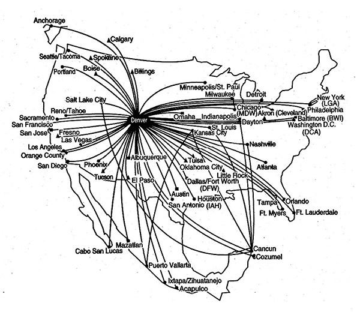

也许他们还会想：‘边疆航空的大多数航班都进出丹佛’，或者‘丹佛机场有许多边疆航空的飞机和登机口’。这几座‘最高峰’（即最显著的事实），大致就是多数谈论枢纽的情况下所需的全部内容。但实际上，它们遗漏了构成枢纽概念的几乎所有内容，而我们文化中的大多数成年人对此都完全知晓。‘我们文化中’这一限定极为重要，因为我们视为理所当然的数百个概念，在其他文化或时代并不存在。例如，想象一下，试着向约翰·塞巴斯蒂安·巴赫、圣女贞德、阿基米德或尼布甲尼撒解释枢纽概念。他们各自都是其文化中的杰出人物，但你要怎样把这个‘简单’概念传达给其中任何一人呢？那将是相当长的一番讲述。

Perhaps they will also think, “Most of Frontier’s flights go in and out of Denver”, or else “Lots of Frontier planes and gates are found at the Denver airport”. This small set of “highest peaks” (*i.e.*, most salient facts) is pretty much all that one needs in most cases where a hub is being talked about. But in fact it leaves out nearly all of what makes up the concept *hub*, and of which most adults in our culture are perfectly aware. The stipulation “in our culture” is crucial, because hundreds of concepts that we take for granted are not part of other cultures or eras. For instance, imagine trying to explain the concept of *hub* to Johann Sebastian Bach, or to Joan of Arc, or to Archimedes, or to Nebuchadnezzar. These were all remarkable individuals in their respective cultures — but how would you go about trying to get across this “simple” concept to any one of them? It would be a rather long story.

首先，“hub”是一个非常具体、可见的概念的名称；我们初骑自行车时，看到许多辐条从车轮中心辐射出去（或朝中心汇入），就学会了它——轮毂。事实上，航空枢纽之所以冠以“hub”之名，正是因为有辐条的车轮；自行车轮概念当然比航空枢纽概念更‘原始’或更‘基础’，不仅在人生中学得早得多，而且理解起来也简单得多。我们来列出一些同样比 hub 更原始、也是其先决条件的概念。例如，航空公司、航线、时刻表和航线图。要理解航空公司概念，首先必须熟悉飞机和公司概念。而航线概念依赖起点、目的地、航段和转接概念。我们不会无休止地列下去，但别忘了，枢纽存在的理由——raison d’être——是经济效率，也就是降低成本、减少不同航班数量的持续压力。因此，必须了解贸易、收益、损失、利润、竞争等概念……

To begin with, the word “hub” is the name of a very concrete, visual concept that we learn when we first ride a bicycle and we see the many spokes radiating out of (or into) the wheel’s center — its hub. Indeed, it’s because of wheels with spokes that airline hubs sport the name “hub”, and the concept of *bicycle wheel* is certainly more “primitive” or “elementary” than is that of *airline hub*, not only being learned far earlier in life but also being far simpler to grasp. Let’s list some other concepts that are more primitive than *hub* and that are likewise prerequisites to it. There’s *airline*, for instance, and *route* and *schedule* and *route map.* And in order to understand the concept of *airline*, you first have to be familiar with the concepts of *airplane* and *company.* And the concept of *route* depends on the concepts of *starting point, destination, leg*, and *connection.* We won’t go on forever, but let’s not forget that the *raison d’être* of hubs is economic efficiency — the relentless pressure to cut costs and to reduce the number of different flights — and thus one has to know about the concepts of *trade, gain, loss, profits, competition..*.

对于枢纽概念所包含的内容，我们只触及了表面。所有这些成分都‘在里面’，一旦需要，全都可以拆开呈现出来。这种拆解带着我们回到越来越基本、越来越初级的观念——涉及运动、运载工具、圆形、获取、交易、输赢、大数小数等的概念，依此类推。而且请注意，迄今我们所谈的一切，都没有涉及机场与大城市相关这一事实，也没有涉及机场不只是地图上的黑点这一事实。的确，我们完全略过了机场内部的物理结构：跑道、停机坪、候机大厅、登机口、登机廊桥、美食广场，等等。

We have only scratched the surface of what goes into the concept *hub.* All of those ingredients are “in there”, and they could all, if and when the need arose, be unpacked and revealed. Such unpackings carry one back towards more and more basic, elementary notions — concepts involving motion, vehicles, roundness, acquisition, trading, winning and losing, large and small numbers, and on and on. And note that none of what we have so far spoken of has anything to do with the fact that airports are associated with large cities, or that airports are more than just black dots on maps — indeed, we completely skipped the internal *physical* structure of an airport, with its runways, tarmacs, concourses, gates, jetways, food courts, etc.

我们刚才给出的意象，是一条概念链，其中的概念依赖别的概念，复杂程度不断向下降低，这令人想起俄罗斯套娃，也可能让人觉得概念实际上就是这样一层层盒子式地组织起来的。然而，实际上，概念建构现象远比这精微和流动。概念不像嵌套的盒子，并不是任一概念都由一组精确的、先前获得的概念来严格定义，概念也并非总以固定顺序获得。相反，新概念的到来，往往对其所依据的‘更原始’概念施加重大影响，有点像建造一座房子影响了建筑用砖本身的性质。虽然能够改变所用砖块性质的房子实在不多见，但我们都熟悉这一基本思想：例如，孩子的存在依赖父母，而同时，孩子的存在又彻底改变了父母的生活。

The image we’ve just given of a chain of concepts that depend on other concepts, moving ever downwards in complexity, is reminiscent of the nesting of Russian dolls, and might give the impression that concepts are in fact structured in this boxlike fashion. In truth, however, the phenomenon of concept-building is much subtler and more fluid than that. Concepts are not like nested boxes, with any given concept being rigidly defined in terms of a precise set of previously-acquired concepts, and with concepts always being acquired in a fixed order. Instead, when new concepts are acquired, their arrival often exerts a major impact upon the “more primitive” concepts on which they are based, a bit as if the construction of a house affected the very nature of the bricks with which it was built. Although houses that modify the nature of the bricks of which they are made do not exactly grow on trees, we are all nonetheless familiar with this basic idea, since, for example, children are dependent upon parents in order to exist, but at the same time their existence radically transforms the lives of their parents.

概念也是如此。因此，枢纽概念无疑依赖许多其他概念，例如机场；但与此同时，机场概念本身又受到枢纽概念的改变。例如，熟悉枢纽这一想法，必然会凸显一个事实：机场是能够帮助航空公司精简运营、从而省钱的实体；这肯定不是有关机场最显而易见的事实。同样，记起机场往往是旅客的中转区，会多少降低‘机场作为最终目的地’这一性质的显著程度。即使这些影响并未使机场概念发生根本改变，它们也无可否认地真实存在，说明原有概念不会不受较新概念的影响。我们还能想象枢纽概念对机场概念更根本的影响，比如旨在优化机场枢纽功能的新建筑形式，或专为快速换乘、只有二三十分钟的旅客服务的新型机场购物中心设计。而枢纽的存在也能改变城市规模与机场规模之间看似显然的相关关系：也就是说，有了枢纽，一个相对较小的城市（例如北卡罗来纳州的夏洛特）拥有航空交通量巨大、但真正在那里下机结束行程的旅客很少的机场，就变得完全可以想象。因此我们看到，虽然没有在先的‘父母’概念机场，就不可能有‘孩子’概念枢纽，但孩子还是改变了父母的身份。

This is true also for concepts. Thus the concept of *hub* depends, without any doubt, on many others, such as *airport*, but at the same time, the concept of *airport* is itself modified by the concept of *hub.* For instance, familiarity with the *hub* idea inevitably brings out the fact that airports are entities that can help airlines to become more streamlined and thus to save money; this notion is certainly not the most obvious fact about airports. Similarly, recalling that airports tend to be transit areas for travelers somewhat reduces the saliency of airports as final destinations. Even if such effects do not cause radical modifications of the concept *airport*, they are undeniably real and demonstrate that the original concept doesn’t remain unaffected by the newer one. One can imagine more radical effects of the *hub* concept on that of *airport*, such as novel kinds of architecture aimed at optimizing the design of airports to function as hubs, or the design of new kinds of airport shopping malls specially designed to serve passengers who are making rapid plane-changes and who have only twenty or thirty minutes. And the existence of hubs can change the seemingly obvious correlation between city size and airport size; that is, with hubs, it becomes perfectly conceivable for a relatively small city (such as Charlotte, North Carolina) to have an airport with an enormous volume of air traffic but very few passengers who actually disembark there. We thus see that although there cannot be a “child” concept of *hub* without the prior “parent” concept of *airport*, the child nonetheless changes the identity of the parent.

这类例子数不胜数。在科学中尤其常见：一个新思想在本质上依赖先前的思想，但同时又让旧思想呈现出崭新的、往往更深刻的面貌。例如，非欧几何不仅在历史上源于欧几里得几何，而且也使人们对欧几里得几何产生了深刻得多的理解。在物理学中，相对论力学和量子力学也大体如此：它们都是经典力学的‘孩子’，并共同使我们对经典力学有了深刻得多的理解。

There are countless examples of this general sort. It happens particularly often in science, where a new idea depends intrinsically on previous ones, but at the same time it casts the old ones in a fresh new light, and often a deeper light. For example, non-Euclidean geometry not only came historically out of Euclidean geometry, but it also allowed a much deeper understanding of Euclidean geometry to emerge. In physics, much the same could be said for relativistic mechanics and quantum mechanics, both of which are “children” of classical mechanics, and together have yielded a far deeper understanding of it.

日常生活中的概念也是如此。因此，代孕母亲、养母和单身母亲这些相对较新的观念，都来自母亲概念，领养孩子的同性恋伴侣这一观念也是如此。每一个新观念都改变母亲概念，表明母亲不一定要生孩子，不一定要养育孩子，不一定要有伴侣，甚至可能不是女性。同样，离婚概念依赖婚姻概念，但它又反过来影响婚姻本身的性质（例如，想想婚前契约的影响，以及如今每个人在结婚时都知道所有婚姻中有一半以离婚告终这一事实）。同性婚姻观念显然依赖先前的婚姻概念，而关于同性婚姻的争论如此激烈，很大程度上是因为反对者声称，这一想法不仅扩展了婚姻概念，实际上还严重损害了它。死亡概念既依赖又改变生命概念。快餐概念既依赖又改变餐馆概念。信用卡概念既依赖又改变金钱概念。手机概念依赖并改变电话概念。交通事故概念依赖并改变汽车概念。飞机概念依赖并改变距离概念。回收利用概念依赖并改变垃圾概念。强奸、奴隶制、种族灭绝、连环杀手等概念，不仅依赖人类这一概念，也改变它。

The same is true for concepts in everyday life. Thus, the relatively new notions of *surrogate mother, adoptive mother*, and *single mother* all come out of the concept of *mother*, as does that of a homosexual couple that adopt a child, and each of these new notions modifies the concept of *mother*, showing how a mother need not give birth to a child, need not raise a child, need not be part of a couple, and may even not be a female. In like manner, the concept of *divorce* depends on that of *marriage*, and yet it also has reverse effects on the nature of *marriage* itself (think, for instance, of the effect of prenuptial contracts, and of the fact that today everyone knows, when going into a marriage, that half of all marriages finish in divorce). The notion of *homosexual marriage* clearly depends on the prior concept of *marriage*, and the intensity of the debate over homosexual marriage is in large part due to the fact that opponents claim that the idea not only extends the concept of *marriage* but in fact does the concept serious harm. The concept of death both depends on and modifies the concept of *life.* The concept of *fast food* both depends on and modifies the concept of *restaurant.* The concept of *credit card* both depends on and modifies the concept of *money.* The concept of *cell phone* depends on and changes that of *phone.* The concept of *traffic accident* depends on and changes that of *car.* The concept of *airplane* depends on and changes that of *distance.* The concept of *recycling* depends on and changes the concept of *garbage.* The concepts of *rape, slavery, genocide, serial killer*, and others not only depend on but change that of *human being*.

人类的概念库在某种意义上确实有层级性，因为一些概念是另一些概念的先决条件，这意味着各个概念通常有一个大致的获得时间顺序。不过，它在本质上仍与数学或计算机科学中系统而严格分层地建立概念的精确、僵硬方式极为不同。在后两种领域中，人们引入形式定义，使每一个新概念都明确而铁板钉钉地依赖一组界定清楚的先前概念。普通概念完全没有这种僵硬性或精确依赖。诚然，一个人要获得枢纽概念，大概需要先对车轮、辐条、起飞、着陆、旅程的一段、登机廊桥、候机大厅和中转区等概念有所了解，但这些概念在某个具体的人对枢纽的理解中究竟起什么作用，并不清楚；对于一个完全自在地理解‘丹佛是边疆航空公司的枢纽’这句话的人，这些概念需要内化到何种深度，也并不清楚。

Although the repertoire of human concepts is in a sense hierarchical, in that some concepts are prerequisites to other ones, thus implying a rough temporal order in which various concepts generally are acquired, it is nonetheless extremely different in nature from the precise and rigid way that concepts are built up systematically and strictly hierarchically in mathematics or computer science. In the latter contexts, formal definitions are introduced that make each new concept depend explicitly and in an ironclad fashion on a well-defined set of prior concepts. Ordinary concepts have none of this rigidity or precise dependence. True, a person probably needs some familiarity with such concepts as *wheel, spoke, takeoff, landing, leg of a trip, jetway, concourse*, and *transit area*, for instance, before they can acquire the concept of hub, but it’s by no means clear what precise role such concepts play in any specific person’s notion of what a hub is, nor how deeply such concepts have to have been internalized by someone who feels perfectly comfortable with the sentence “Denver is a hub for Frontier Airlines.”

在一生中，我们人类建立一个又一个又一个概念。这个过程不断持续，直到死亡。许多动物并非如此：它们的概念库似乎在幼年便已固定，有些还十分有限（想想青蛙或蟑螂的概念清单）。每一个新概念都依赖若干先前存在的概念（如刚才枢纽的例子所示，数量往往很大）。而每一个旧概念，又曾依赖更早、更原始的概念。一直回溯到婴儿时期，这条链确实极其漫长。正如前面所说，概念随时间积累，并不建立严格僵硬的层级。依赖关系模糊而有渐变，不是精确的；层级中也不存在严格的‘高’或‘低’，因为如我们所示，依赖可以是相互的。新概念改变那些先于它存在、并使它得以诞生的概念；如此，较新的概念被纳入其‘父母’内部，反过来也一样。此外，这种持续的概念组块化过程，与持续的概念细化过程并行不悖。

Over the course of our lives, we humans build up concept after concept after concept. This process continues incessantly until we die. This is not the case for many animals, whose conceptual repertoires seem fixed from an early age, and in some cases very limited (think of the conceptual inventory of a frog or a cockroach). And each new concept depends on a number (often very large, as we’ve just seen in the case of hub) of previously existent concepts. But each of those old concepts depended, in its turn, on previous and more primitive concepts. The regress all the way back to babyhood is an extremely long one, indeed. And as we stated earlier, this buildup of concepts over time does not in any way establish a strict and rigid hierarchy. The dependencies are blurry and shaded rather than precise, and there is no strict sense of “higher” or “lower” in the hierarchy, since, as we’ve shown, dependencies can be reciprocal. New concepts transform the concepts that existed prior to them and that enabled them to come into being; in this way, newer concepts are incorporated inside their “parents”, as well as the reverse. Moreover, this continual process of conceptual chunking goes hand in hand with a continual process of conceptual refinement.

### 古典概念Classical Concepts

直到不久以前，哲学家一直相信物理世界划分为天然的范畴，也就是说，每一件事物都因其自身本性而永远属于某个客观范畴。这些哲学家主要关注鸟、桌子、行星等范畴，其成员都是可见的实体。部分由于这些久远的猜想，即使在大多数当代思想家中，仍有一种倾向，把范畴的观念与对物理对象、尤其是能看见的对象进行分类的想法联系起来。像照料某人使其恢复健康的情境，或盼望某种结果、改变主意的情境，也可以与桌子或鸟一样正当地构成范畴，这种想法离那些哲学家的信念相去甚远；更不用说“and”“but”“so”“nevertheless”“probably”等词是重要范畴的名称这一更加异乎寻常的想法了。如果你难以想象“but”这样看似十分普遍、甚至平淡无奇的词能够表示一个范畴，不必担心；我们很快就会谈到这个问题。目前，我们想先对较古典的范畴类型作一些观察，因为数千年来，某些思想已在我们的文化中根深蒂固，很难克服它们，重新走上新的道路。因此，作一些基础观察，描绘一幅与古典图景显著不同的概念图景，将对我们有所帮助。

Until quite recently, philosophers believed that the physical world was divided into natural categories — that is, that each and every thing, by its very nature, belonged eternally to an objective category. These philosophers focused primarily on categories such as *bird, table, planet*, and so on, whose members were visible entities. In part as a result of these conjectures from long ago, there remains a tendency, even among most contemporary thinkers, to link the notion of *category* with the idea of classifying physical objects, especially objects that we can perceive visually. The idea that situations of someone being *nursed* back to health, for example, or situations of *hoping* for an outcome or of *changing one’s mind*, might constitute categories with just as much legitimacy as *table* or *bird* was far from such philosophers’ beliefs, let alone the even further-out idea that words such as “and”, “but”, “so”, “nevertheless”, “probably” (and so forth) are the names of important categories. If you find it difficult to imagine that a word like “but”, which seems so general and perhaps even bland, denotes a category, don’t worry; we will come soon enough to this matter, but for the time being we would like to make some observations on the more classical types of categories, since over the millennia certain ideas have become so entrenched in our culture that it is very difficult to overcome them and to start afresh down new pathways. It will thus be helpful for us to make some elementary observations that will paint a picture of concepts that is markedly different from the classical one.

我们可以先问：鸟是什么？按照古典哲学家的观点，鸟范畴应当有一个精确的定义，由某个实体归入该范畴的必要且充分条件组成，比如‘具有两只脚’‘皮肤覆有羽毛’‘有喙’‘产卵’。（当然，还可以增加更多或更精细的成员资格标准；这里这几个只是示意。）这一观点在哲学中数百年来基本未受挑战，直到哲学家路德维希·维特根斯坦的研究在二十世纪五十年代发表；在心理学中，它也一直占据至高地位，直到二十年后埃莉诺·罗施开展开创性研究。成员资格标准的集合（定义性质）被称为范畴的内涵，而满足这些标准的实际实体的集合（成员）被称为范畴的外延。内涵和外延这两个观念借自数理逻辑，被认为与那门学科本身一样精确严谨。使用这些术语，透露出一种热切愿望：把起初看似完全难以捉摸的东西——即周围那些极其千差万别的对象所共有的抽象本质——变得清清楚楚。

We might begin by asking what a bird is. According to classical philosophers, whose view went essentially unchallenged in philosophy for centuries, until the studies of philosopher Ludwig Wittgenstein, published in the 1950’s, and which also reigned supreme in psychology until the pioneering research of Eleanor Rosch two decades later, the category *bird* should have a precise definition consisting of necessary and sufficient conditions for an entity’s membership in the category, such as “possesses two feet”, “has skin covered with feathers”, “has a beak”, “lays eggs”. (Obviously one could add further or more refined membership criteria for the category *bird*; these few simply constitute a gesture towards the idea.) The set of membership criteria (the defining properties) is said to be the *intension* of the category, while the set of actual entities that meet the criteria (the *members)* is said to be the *extension* of the category. The notions of intension and extension, borrowed from mathematical logic, are thought of as being just as precise and rigorous as that discipline itself, and the use of these terms reveals the ardent desire to render crystal-clear that which at first seems utterly elusive — namely, the abstract essence of all the highly variegated objects that surround us.

然而，一个问题来源在于：表达成员资格标准的词语，并不比我们试图确定的概念——这里是鸟——更精确。例如，脚是什么？‘具有’是什么意思？‘覆有’是什么意思？当然，大家都知道，有各种鸟并没有两只脚（也许由于受伤或遗传缺陷），或者并不覆有羽毛（例如小鸭和小鸡）。反过来看，我们人类有两只脚，但若手里拿着一束羽毛，这种‘具有’并不足以把我们变成鸟。还有那著名的 plume de ma tante——我年迈的姑妈喜爱用来书写漂亮书法的鹅毛笔——它算羽毛吗？如果算，拥有它就会使我那两足的老姑妈成为一只鸟吗？

A source of problems, however, is the fact that the words used to express the membership criteria are not any more precise than the concept that one is trying to pin down — in this case, *bird.* What, for instance, is a *foot*? And what does “to possess” mean? What does “covered with” mean? And of course, everyone knows that there are all sorts of birds that don’t have two feet (perhaps because of an injury or a genetic defect) or that are not covered with feathers (ducklings and chicks, for example). And turning things around, we human beings have two feet, but if we hold a spray of feathers in our hand, this “possession” does not suffice to turn us into birds. And the famous *plume de ma tante* — my ancient aunt’s quill pen, which she loved to use to make beautiful calligraphy — would that count as a feather? And if so, would possession thereof make my bipedal old aunt a bird?

有时，人们会觉得古代哲学家的真正目标，并不是为物质世界里的具体实体分类，例如种类多得令人眼花缭乱的一只只鸟，而是刻画一般的、非物质的抽象事物之间的关系，例如蜜蜂、蝙蝠、蛋、小鸡、鸵鸟、鸽子、蜻蜓、燕子、飞鱼等范畴。如果目标如此，那么关键问题就是：‘这些实体类别中，哪些是鸟？’显然，我们已经远离具体实在的东西，转而从事一种一切皆为一般和抽象的智力活动。这个高远的柏拉图式概念世界，没有拔光毛的鸟或受伤的鸟这些讨厌的例外，更不用说把鹅毛笔放在抽屉里的老姑妈了，因此可能显得像欧几里得几何或国际象棋的世界一样纯粹、不变而客观；这可能让人觉得，其中有大量永恒真理等待发现，如同几何学中的定理。但表象会骗人。即使只考虑抽象范畴，不理会那些令人头痛、充满问题的实例，仍会面临巨大障碍。

At times one gets the impression that the actual goal of ancient philosophers was not to classify specific entities from the material world, such as individual birds, whose variety is bewildering, but rather to characterize the relationships that hold between generic, immaterial abstractions, such as the categories *bee, bat, egg, chick, ostrich, pigeon, dragonfly, swallow, flying fish*, and so forth. If this is one’s goal, then the crucial question would be “Which of these *classes* of entities are birds?” It’s clear that one has moved far from the specific and concrete, and has replaced it by an intellectual activity where everything is generic and abstract. This rarefied universe of Platonic concepts, since it lacks annoying exceptions like the plucked or the injured bird, not to mention the old aunt who keeps a quill in her drawer, might appear to be as pure, immutable, and objective as the universes of Euclidean geometry or chess, and this could suggest that in this universe there are a vast number of eternal verities lying in wait to be discovered, much like theorems in geometry. But appearances are deceptive. Even if one considers only abstract categories and pays no attention to their annoyingly problematic instances, one still faces enormous obstacles.

小鸡没有羽毛，会使它失去鸟范畴的成员资格吗？这似乎不太可能。或者，对每只小鸡而言，是否存在一个特定瞬间，它从小鸡范畴跨入鸟范畴？这种身份转换会在皮肤‘覆有’羽毛的瞬间发生吗？要多少根羽毛，小鸡才算‘覆有’羽毛？或者，皮肤面积有多大比例必须被覆盖，才算‘覆有’？如果判定它是不是鸟需要知道这一点，我们又该怎样测量小鸡的表面积呢？

Would a chick’s lack of plumage make it lose its membership in the category *bird*? That seems unlikely. Or is there a specific instant, for each chick, when it passes over from the category *chick* to that of *bird*? Would that switchover in status take place at the instant when its skin becomes “covered” with feathers? How many feathers does it take for a chick to be “covered” with them? Or what percentage of the skin’s area must be covered for it to count as “covered”? And how does one measure the surface area of a chick, if that is needed in order to decide if we are dealing with a bird or not?

看得越仔细，发现的此类问题就越多，它们也越显荒谬。而我们只触及了问题的表面。考虑一只刚死去的鸟这一一般观念。它还是鸟吗？如果是，这个实体还将在鸟范畴中保留多久？会有一个鲜明的转折瞬间，此后它就不再具备成员资格吗？再向过去倒退几百万年。鸟与其前身（某些会飞的恐龙）的分界线在哪里？再往另一个方向推进，像‘拔光毛的鸡还是鸟吗？’这样的问题又如何呢？一旦创造出‘拔光毛的鸡’这个表达，我们提出的问题就成为那个支配抽象范畴的假想形式代数中的合法问题。这样一来，我们便打开了问题的潘多拉盒子：‘一只双脚被切掉的知更鸟还是鸟吗？’（因为前面的名词短语是某一实体范畴的有效名称），或者‘一条被移植了几根羽毛和两只鹰脚的蛇是鸟吗？’等等，没有尽头。

The closer one looks, the more such questions one will find, and the more they are going to seem absurd. And we have only scratched the surface of the issues. Consider the generic idea of a bird that has just died. Is it still a bird? And if so, for how long will this entity remain a member of the category *bird*? Will there be a sharp transitional moment at which the category membership no longer obtains? And let’s go backwards in time by a few million years. Where is the boundary line between birds and their predecessors (certain flying dinosaurs)? And to push matters in yet another direction, what about questions such as, “Is a plucked chicken still a bird?” The moment one has created the expression “plucked chicken”, the question we posed becomes a legitimate question in the hypothetical formal algebra that governs abstract categories. And with this, we have opened a Pandora’s box of questions: “Is a robin whose feet have been cut off still a bird?” (since the first noun phrase is the valid name of a category of entities), or “Is a snake onto which one has grafted some feathers and two eagle’s feet a bird?”, and so on, without any end in sight.

即使不设想如此激烈的变形，也可以问：凉鞋是不是鞋？橄榄是不是水果？大本钟是不是钟？一套立体声音响是不是家具？墙上挂着的日历是不是书？假发是不是衣物？等等。人们对这些问题的意见竟然大相径庭。心理学家詹姆斯·汉普顿的一项实验表明，水槽勉强被纳入厨房用具范畴，而海绵则刚好被排除。这些临界判定，是一项大型实验中许多受试者意见的平均结果，因此我们可能想，如果转而询问个人，就会发现每个人都有明确固定的边界（尽管人与人之间有所不同）。然而，即便这个已经颇为背离柏拉图式概念思想的想法——柏拉图式概念应当是客观而非主观的——也完全错误。许多人被问到枕头和床头灯是不是家具，几天后再被问同样的问题时，就会改变主意。他们是否处于永久摇摆的病态，永远无法对任何事情拿定主意呢？更可能的是，他们只是普通人，其范畴越接近边缘就越模糊；如果问的是较典型的例子，例如狗是不是动物，他们对范畴成员资格的判断就会极其稳定。

Even without imagining such radical transformations, one can ask whether sandals are *shoes*, whether olives are *fruits*, whether Big Ben is a *clock*, whether a stereo set is a *piece of furniture*, whether a calendar hanging on one’s wall is a *book*, whether a wig is an *article of clothing*, and so forth. People turn out to have highly divided opinions on such questions. In an experiment conducted by the psychologist James Hampton, sinks turned out to be just barely included in the category *kitchen utensils*, while sponges were just barely excluded. Since these close calls are the result of averaging over many subjects in a large experiment, one might imagine that if one were to ask individuals instead, one would find clear-cut and fixed boundaries for each person (even if they would vary from individual to individual). However, even that idea, which runs considerably against the idea of Platonic concepts (which are supposed to be objective, not subjective), turns out to be quite wrong. Many people change their mind if they are asked whether pillows and night-table lamps are articles of furniture and then are asked the same question a few days later. Are these individuals suffering from a pathological state of permanent vacillation, never able to make up their mind about anything? It seems more likely that they are quite ordinary individuals whose categories simply grow blurry toward their edges; if these people were asked about more typical cases, such as whether dogs are *animals*, they would be extremely stable in their judgments about category membership.

凡是对字母表感兴趣的人，都会体会过字母“A”——无论大写小写——这样一个‘简单’范畴令人目眩的丰富性。哪些几何形状属于“A”范畴，哪些不属于？只要看几张手写明信片，或一组广告所用字体，或者序言中的那幅图，就能看出，a、b、c、d 等二十六个范畴的边界为什么不可能精确规定。当然，适用于字母的道理，也同样适用于其他熟悉的范畴，如 bird、bill、boss、box 和 brag。

Anyone who has taken an interest in the letters of the alphabet will have savored the dazzling richness of a “simple” category like the letter “A”, whether capital or small. What geometric shapes belong to the category “A”, and what shapes do not? All that one needs to do is take a look at a few handwritten postcards or a collection of typefaces employed in advertising, or for that matter, the figure in the Prologue, in order to see why the boundaries of the twenty-six categories *a, b, c, d*, and so on are impossible to specify exactly. And, to be sure, what holds for the letters of the alphabet holds just as much for other familiar categories, such as *bird, bill, boss, box*, and *brag*.

总之，古人希望把描述世界中物理对象的范畴，变成精确严谨的理论实体，这种希望是徒劳的。这些范畴像云一样转瞬即逝、难以捉摸、模糊而含混。云的边界在哪里？今天天空中有多少朵云？有时望着天空，我们觉得这些问题有清楚准确的答案，在某个特定日子也许确实如此；但第二天，天空会呈现复杂得多的面貌，把‘多少’和‘边界’这类观念应用于它的想法，就只会惹人发笑。

Summing up, then, the ancient hope of making the categories describing physical objects in the world into precise and rigorous theoretical entities is a vain hope. Such categories are as fleeting and elusive, as blurry and as vague, as clouds. Where are the boundaries of a cloud? How many clouds are there in the sky today? Sometimes, when looking at the sky, one has the impression that such questions have clear and exact answers, and perhaps that’s the case on some particular day; however, the next day, the sky will have a radically more complex appearance, and the idea of applying such notions to it as *how many* and *boundary* will simply be a source of smiles.

### 以更当代的方式看待概念Concepts Seen in a More Contemporary Fashion

如今，古典范畴观已普遍被视为死路，一些当代心理学家遂迎接挑战，试图把范畴的模糊与含混本身变成一门精确科学。也就是说，他们的目标是探索那些作为我们概念的心智星云。这使他们提出了范畴化理论，拒绝精确成员资格标准的作用，转而援引原型观念（长时记忆中的一个一般心智实体，概括一个人一生中有关某个范畴的全部经验），或一个人一生中遇到的该范畴全部范例的集合。另一个有影响的观点则涉及已储存的、关于亲历经验的‘心智模拟器’：面对新刺激，它们会重新激活某些脑区，而这些脑区曾受到与当前刺激最接近的经验的刺激。

Since the classical view of categories is now generally perceived as a dead end, some contemporary psychologists have tackled the challenge of making the very blurriness and vagueness of categories into a precise science. That is, their goal is to explore those mental nebulas that are our concepts. This has led them to formulating theories of categorization that reject the role of precise membership criteria and instead invoke either the notion of a *prototype* (a generic mental entity found in long-term memory, which summarizes all one’s life’s experiences with the given category) or else the notion of *the complete set of exemplars* of the given category that one has encountered over one’s lifetime. Another influential view involves stored “mental simulators” of experiences one has undergone, which, in response to a fresh stimulus, reactivate certain regions of the brain that were once stimulated by the closest experiences to the current stimulus.

所有这些努力背后，都有一个吸引人的想法：非均质范畴，也就是成员有强弱之分的范畴。这相当于区分更居中心和较不居中心的成员。例如，给实验受试者提出‘X 是 Y 吗？’这一形式的问题，记录其反应时间；或请他们列出某个范畴的成员；或给他们一份清单，请他们指出每项作为某个范畴成员的典型程度，就会发现一些十分显著的趋势。而且，在所有这些不同测试方式中，这些趋势都很稳定。一个范畴的某些成员，竟然比其他成员‘更属于’这个范畴（令人想起奥威尔《动物农场》中某些动物比其他动物‘更平等’）。例如，鸵鸟和企鹅位于鸟范畴的外缘附近，而麻雀和鸽子接近核心。

Behind all these efforts lies the appealing idea of non-homogeneous categories — that is, categories having stronger and weaker members — which amounts to distinguishing between more central and less central members. For example, if one times the responses of experimental subjects when they are asked questions of the form “Is an X a Y?”, or if one asks them to write down a list of members of a certain category, or if one gives them a list and asks them to indicate, for each item, its degree of typicality as a member of a specific category, one finds that some very striking trends emerge, and these trends turn out to be stable across all these different ways of testing. Certain members of the category turn out to belong *more* to the given category than others do (recalling how some animals in Orwell’s *Animal Farm* were “more equal” than others). For instance, ostriches and penguins turn out to lie close to the outer fringes of the category *bird*, whereas sparrows and pigeons are near its core.

这种现象能够影响人们理解一段要求阅读的文字中某个句子的难度。比如，阅读和理解‘那只鸟现在离这里只有几码远了’所需的时间，取决于前文提到的是鸵鸟（一种不典型的鸟），还是鸽子（一种典型的鸟），铺垫句可能是‘鸵鸟正走过来’或‘鸽子正走过来’。记忆中鸵鸟与鸟之间的联系不如鸽子与鸟之间的联系强，这往往妨碍第一种情况下对文段的理解。

This phenomenon can affect the difficulty one has in understanding a sentence inside a passage that one has been asked to read. Thus, it turns out that the time taken to read and understand a sentence such as “The bird was now just a few yards away” depends on whether, earlier in the passage, there was a reference to an ostrich (an atypical bird) or to a pigeon (a typical bird), in preparatory sentences such as “The ostrich was approaching” or “The pigeon was approaching”. The link in memory between *ostrich* and *bird* turns out to be less strong than that between *pigeon* and *bird*, and this tends to impair the understanding of the passage in the first case.

必须指出，范畴化远远超出了词语之间联系的智力领域，也就是各个范畴名称（如‘sparrow’‘ostrich’和‘bird’）之间联系的领域。例如，如果有人问埃莉诺：‘蜘蛛是昆虫吗？’她很可能依据书本知识回答‘不是’。然而，若她瞥见卧室天花板上悬着一团黑东西，很可能会喊：‘哎呀！把它弄出去！我讨厌房间里的昆虫——太吓人了！’如果有人对她的用词提出异议，埃莉诺会说，她很清楚，那个‘昆虫’其实不是昆虫，而是蜘蛛。

It’s important to point out that categorization goes well beyond the intellectual realm of connections among words, which is to say, the names of various categories (such as “sparrow”, “ostrich”, and “bird”). If, for example, someone were to ask Eleanor “Is a spider an insect?”, she might well reply, on the basis of her knowledge from books, “No”, and yet if she were to espy a dark blob hanging from the ceiling of her bedroom, it is likely that she would cry out, “Yikes! Get it out of here! I hate insects in my room — they’re scary!” If someone were to object to her word choice, Eleanor would say that she knows very well that the “insect” was in fact not an insect but a spider.

一般而言，语境对范畴化有很大影响。这个故事里的蜘蛛在卧室里被看作昆虫，但在生物测验之类的语境中，就不会被这样看待。一般情况也大体如此：世界中的一个事物属于数千个范畴，它们彼此可以极其不同；我们心智生活中相当大的一部分，就是把实体归入一个范畴，再重新归入另一个范畴。篮球比赛中，人人都知道篮球会滚动，但实验表明，只有涉及水的情境（例如把一批篮球装上船）才会唤起篮球会漂浮的观念。

Generally speaking, context has a great influence on categorization. The spider in this anecdote was seen as an *insect* in the bedroom, but it would not have been seen as such in the context of a biology test, for instance. And much the same holds in general: a single item in the world belongs to thousands of categories, which can be extremely different from each other, and a good fraction of our mental life consists in placing entities in one category and then in reassigning them to another category. During a basketball game, everyone is aware of the fact that basketballs roll, but it has been experimentally shown that only situations that involve water (such as the loading of a bunch of basketballs on board a ship) evoke the notion that basketballs float.

因此，语境改变范畴化，甚至能改变我们对最熟悉事物的看法。例如，灯泡刚烧坏，需要找个东西站上去更换时，一个对象会在眨眼之间从椅子范畴滑到凳子范畴。通常，我们意识不到这种范畴转换，因为心里沉浸于特定语境，而转换完全无意识地完成。在给定语境中，对大多数人而言，似乎只有一种范畴化是可能的。他们意识不到自己戴着语境的眼罩，这便加强了一种广泛的信念：在世界中，每个对象都只属于一个柏拉图式范畴——它‘真正的’范畴。

Context thus changes categorization and can modify how we perceive even the most familiar of items. For example, an object can slip in the blink of an eye from the category *chair* to that of *stool* when a light bulb has just burned out and one needs something to stand on in order to change it. Usually one is unaware of these category shifts because one is mentally immersed in a specific context and such shifts are carried out in a totally unconscious manner. In a given context, just one categorization seems possible to most people. Their lack of awareness of the contextual blinders that they are wearing reinforces the widespread belief in a world in which every object belongs to one and only one Platonic category — its “true” category.

另一方面，考虑到单个实体很容易同时属于众多不同范畴这一事实，我们就不能不承认范畴成员资格有多复杂，例如：

On the other hand, one cannot help but recognize how complex category membership is if one considers the fact that a single entity can easily belong to many diverse categories, such as, for instance:

60 千克的物体、镜像对称的对象、生物、两足动物、哺乳动物、灵长类动物、招蚊子的人、恐蛛者、人类、四十多岁的人、爱书者、热爱自然者、不妥协者、不会说葡萄牙语的人、浪漫主义者、艾奥瓦人、A+ 血型者、远视力极好的人、失眠者、理想主义者、素食者、律师协会会员、母亲、母鸡般护孩子的母亲、受宠爱的女儿、姐妹、姐姐、妹妹、最好的朋友、死敌、金发女子、女人、行人、汽车驾驶者、骑自行车者、女权主义者、妻子、结过两次婚的女人、离婚女子、邻居、斑点狗主人、中级萨尔萨舞者、乳腺癌幸存者、三年级学生的家长、家长代表……

60-kilogram mass, mirror-symmetric object, living entity, biped, mammal, primate, mosquito attractor, arachnophobe, human being, forty-something, book-lover, nature-lover, non-compromiser, non-speaker of Portuguese, romantic, Iowan, blood-type A+, possessor of excellent long-distance vision, insomniac, idealist, vegetarian, member of the bar, mother, mother hen, beloved daughter, sister, big sister, little sister, best friend, sworn enemy, blonde, woman, pedestrian, car driver, cyclist, feminist, wife, twice-married woman, divorcée, neighbor, Dalmatian owner, intermediate-level salsa dancer, breast-cancer survivor, parent of a third-grader, parents’ representative…

当然，这只是我们可以列出的一份长得多的清单中的一小段；那份清单基本上没有尽头，其中每项都是任何人都能毫不费力地认出为指称某种范畴的词语。

To be sure, this is but a small excerpt from a much longer list one could draw up, a list having essentially no end, and whose entries would all be terms that anyone and everyone would, without any trouble, recognize as designating various categories.

安因急症必须住院、需要输血时，她属于 A+ 血型范畴这一点压倒了所有其他范畴成员身份；但在餐馆里，她首先是一位素食者；工作时，她是律师；家里，她是母亲；家长教师协会会议上，她是家长代表，等等。指出这些明显的事实，似乎毫无必要，但这样简单的观察会把我们带到古典范畴领域之外很远的地方。

When Ann had to be hospitalized on an emergency basis and a transfusion was needed, her membership in the category *blood-type A+* dominated all her other category memberships, but in a restaurant she is above all a *vegetarian*, while at work she is a *lawyer*, at home a *mother*, in a PTA meeting a *parents’ representative*, and so forth. It may seem useless to point out such obvious facts, but such simple observations carry one well outside the realm of classical categories.

### 我模仿 Tweety 时，我是一只鸟吗？When I Imitate Tweety, Am I a Bird?

再回到由一个词命名的鸟范畴，它还能够教给我们一些东西。考虑下列候选成员：

Let’s come back to the one-word category *bird*, which still has some lessons to teach us. Consider the following candidates for membership in the category:

•一只蝙蝠；

• a bat;

•一架飞机；

• an airplane;

•一只青铜海鸥；

• a bronze seagull;

•照片里的一只鹰；

• an eagle in a photograph;

•天空中一只秃鹫的影子；

• the shadow of a vulture in the sky;

•（生活在动画片里的）金丝雀 Tweety；

• Tweety the (cartoon-inhabiting) canary;

•一整个鸟类物种，比如鹰或知更鸟；

• an entire avian species, such as *eagle* or *robin*;

•孵出前两小时、仍在蛋里的小鸡；

• a chick inside an egg two hours before it hatches;

•一只会飞的恐龙（更准确地说，一只曾经飞过的恐龙）；

• a flying dinosaur (or rather, a dinosaur that once flew);

•放映希区柯克电影《群鸟》时，银幕上的一只鸽子；

• a pigeon on the screen in a showing of Hitchcock’s film *The Birds*;

•录下的夜莺歌声，在它死后五十年播放；

• the song of a nightingale recorded and played back fifty years after it died;

•一个以橡皮筋为动力、拍动翅膀、在空中盘旋俯冲的塑料物件。

• a rubber-band-powered wing-flapping plastic object that swoops about in the air.

如果你与绝大多数人一样，大概很想对上面清单中的每个候选者说‘是’或‘不是’，仿佛正在参加学校考试，必须证明自己的知识准确无误，又仿佛每个问题都确实存在一个正确答案。麻雀——是鸟吗？是！在浅色云层背景前，看见一个黑点在空中不规则地运动，你看到的是鸟吗？当然！在地上看见秃鹫的影子，你看到的是鸟吗？当然不是！夜里听见响亮的咕咕叫声，你听到的是鸟吗？是！如果听到的是录下的咕咕声（也许并不知道是录音）呢？如果是某人惟妙惟肖地模仿这种叫声呢？如果梦见一只猫头鹰，那里涉及一只鸟吗？如果读的是一本有 Tweety 的漫画书呢？

If you are like the vast majority of humans, you probably felt a keen desire to say “yes” or “no” to each of the candidates in the list above, as if you were taking an exam in school and had to demonstrate the precision of your knowledge, and as if, in each of these cases, there really were a *correct* answer to the question. A sparrow — is it a bird? *Yes!* When you spot a black spot moving unpredictably through the air against a light cloudy background, are you seeing a bird? *Of course!* And when one sees the shadow of a vulture on the ground, is one seeing a bird? *Of course not!* When one hears a loud hooting during the night, is one hearing a bird? *Yes!* And if one hears a recorded hooting (perhaps without being aware that it is recorded)? And what about the case where some person imitates hooting extremely well? And if one dreams about an owl, is there a bird involved? And if one reads a comic book featuring Tweety?

从来没有人教我们范畴的边界。我们对边界的自发感觉，来自常被我们称为‘常识’的东西，而任何学校都不教这个。没有范畴成员资格的课程；即使有，学生之间、师生之间也会争论不休，更不用说教师彼此间会发生的激烈辩论了。事实上，专门知识根本帮不上忙。这里借用心理学家格雷戈里·墨菲的一则轶事：他引用了一位世界著名冶金学家在该领域全球专家会议上所作主题演讲中的话：‘告诉你们一件事。你们其实不知道什么是金属。而且，有一大群人不知道什么是金属。知道我们管他们叫什么吗？冶金学家！’

No one ever taught us the boundaries of categories. Our spontaneous sense for their boundaries is an outcome of what we often call “common sense”, and no one teaches that in any school. There are no courses on category membership, and even if there were, there would be endless arguments among the students as well as between teachers and students, not to mention the passionate debates that would take place among the teachers themselves. Indeed, expertise doesn’t help at all. Here we borrow an anecdote from the psychologist Gregory Murphy, who quoted from a keynote speech once delivered by a world-renowned metallurgist at a conference of world experts in that field: “I’ll tell you something. You really don’t know what a metal is. And there is a big group of people that don’t know what a metal is. Do you know what we call them? *Metallurgists!*”

最近，天文学家激烈争论冥王星是否应被视为行星（截至写作时，它在官方认定中已不再是行星），原因正是行星概念的模糊：即使在我们这颗行星上最伟大的专家心里，它也模糊，这使问题极为棘手。出于类似原因，尽管如今专家相当一致地认为，称我们有‘五种感官’并不正确，因为这样列举会漏掉本体感觉、温度感觉、伤害性感觉等，但我们的感官究竟是什么，仍极为模糊。专家连我们有多少种感官都无法一致，更不用说它们具体是什么，因此常说‘我们的五种主要感官’。同样，生命仍没有一个标准定义；即使生物学家希望一劳永逸地确定它，也一直在调整分类体系的细节，而外行原以为这些细节早就板上钉钉了。自林奈以来，生物分类已走了很长的路；如今，他分类中使用的许多古典术语，比如“reptile”（爬行动物）、“fish”（鱼）和“algæ”（藻类），仍在学校课本里，却不再出现在现代系统发育分类中。这一切说明，范畴的模糊不是某种缺乏专门知识的结果，而是范畴化行为不可分割的一部分。

The recent vehement debates among astronomers over whether Pluto should or should not be deemed a planet (which, as of this writing, it no longer officially is) were due to the blurriness of the concept of *planet*, even in the minds of this planet’s greatest specialists, which made the question extremely thorny. For similar reasons, although there is considerable agreement among experts today that it is not correct to refer to our “five senses”, since proprioception, thermoception, and nociception (among others) would be left out of such a roll call, there remains a major blur about what our senses really are. Since the experts can’t even agree on how many senses we have, let alone on what they all are, they often talk about “our five main senses”. And in a similar vein, a standard definition of *life* is still missing, even if biologists, hoping to pin it down for once and for all, are constantly juggling the details of taxonomies that laypersons would have presumed had long ago been cast in concrete. The classification of living organisms has come a long way since Linnæus, and today, many classic terms that he employed in his classification, such as “reptile”, “fish”, and “algæ”, remain present in school texts, but no longer appear in modern phylogenetic classifications. All this goes to show that the blur of categories is not due to some kind of lack of expertise, but is part and parcel of the act of categorization.

### 你会说多少种语言？How Many Languages do You Speak?

心理学家已经很好地表明，没有任何范畴具有精确边界；然而，我们的日常语言与思维，仍渗透着古典观念的残余痕迹，认为范畴边界像国界一样鲜明（诚然，国界往往也不那么清楚，不过暂且不谈）。人类强烈渴望避免歧义、确定真而排除假、去芜存菁，这往往使我们对于没有明确答案的问题，也去寻求并相信十分明确的答案。

Although psychologists have done a good job in making it clear that no category has precise boundaries, our everyday language and thought are still permeated with residual traces of the classic vision in which category boundaries are as sharp as those of nations (which, to be sure, are often not all that clear, but we’ll leave that matter aside). Our intense human desire to avoid ambiguity, to pinpoint the true and to discard the false, to separate the wheat from the chaff, tends to make us seek and believe in very sharp answers to questions that have none.

例如，喜欢学习外语的人常被问：‘你会说多少种语言？’这个问题尽管看起来再自然不过，却基于一个隐含想法：世界上的语言可以分为两个精确的格子——X 会说的语言和 X 不会说的语言——仿佛这是非黑即白的事情。实际上，对每种学过的语言，我们会说的程度都不同，取决于许多因素，例如初次学习的时间、学习的环境、距离上次使用过了多久等等。受到追问时，提问者可能退一步说：‘我只是想问，你能用多少种语言进行日常交谈？’

For instance, people who enjoy studying foreign languages are frequently asked the question, “How many languages do you speak?” Despite how perfectly natural this question might seem, it is based on the tacit idea that the languages of the world fall into two precise bins: languages that person X *does* speak, and languages that X does *not* speak, as if this were a black-and-white matter. But in fact, for each language one has studied, one speaks it to a different degree, depending on many factors, such as when one first studied it, the context in which one studied it, how long it has been since one spoke it, and so forth. When pressed, the questioner may retreat, saying, “All I meant was, ‘How many languages can you have an everyday conversation in?’ ”

但这个新问题即使起初听来合理，也一样模糊。例如，它假定日常交谈这个范畴明确而界定清楚。但这可能指在邮局排队时，与身边的人谈两分钟邮票价格；也可能指与飞机上邻座的陌生人谈半小时自己的孩子和家庭、世界棒球大赛或世界经济的糟糕状况；也可能指在热闹的晚宴上，与围坐桌旁、全为母语者的另外七个人，谈三个小时、涉及二十种随意话题。大多数人在跨过远低于最后这个标准的门槛时，就说自己会说某种语言；不过无论如何，‘会说一种语言’的门槛并没有清楚的定义。

But once again, even if this new question sounds reasonable at first, it’s just as blurry. For example, it presumes that the category *everyday conversation* is sharp and well-defined. But it might mean a conversation of two minutes about the cost of postage stamps with someone standing next to one in a line in the post office. Or it might mean a half-hour conversation about one’s children and family, or about the World Series, or about the sad state of the world economy, with a stranger sitting next to one in an airplane. Then again, it might mean a three-hour conversation ranging over twenty different random topics with seven other people, all native speakers, seated around the table at a lively dinner party. Most people say they speak a language when they have surpassed a far lower threshold than that, but in any case, the threshold for “speaking a language” is not well-defined.

事实上，语言这个范畴本身就十分模糊。在印度、中国或意大利这样多语言的国家，人们说多少种语言？每个国家都有许多语言和方言；此外，方言与语言究竟有什么精确区别？下面这个幽默的说法常被归于语言学家马克斯·魏因赖希：‘语言就是拥有军队的方言。’这话大有道理，但仍回避了问题；毕竟，究竟什么才算军队呢？

And indeed, the category *language* is itself very blurry. How many languages are spoken in a polyglot land such as India, China, or Italy? In each case, there are many languages and dialects; moreover, what is the precise distinction between a *dialect* and a *language*? The following humorous observation is often attributed to the linguist Max Weinreich: “A language is a dialect with an army”, and there is much truth to it, but it still begs the question; after all, what exactly constitutes an army?

简言之，‘你会说多少种语言？’不是一个简单问题，也没有简单答案；它与‘你从事多少种体育运动？’‘你喜欢多少部电影？’‘你会做多少种汤？’‘你在多少座大城市住过？’‘你有多少个朋友？’‘你今天做了多少件事？’这些问题一样，都没有简单答案。

In short, the question “How many languages do you speak?” is not a simple question, and has no simple answer — no more so than do the questions “How many sports do you play?”, “How many movies do you love?”, “How many soups do you know how to make?”, “How many big cities have you lived in?”, “How many friends do you have?”, or “How many things have you done today?”

### 对创造性隐喻的无尽追寻The Endless Quest for Creative Metaphors

心理学研究表明，心智范畴并没有界定清楚、独立于语境的边界，而更像巴黎这样广阔的大都市区。它最初诞生时，是一个微小、近乎实心的中央核心（随着时间推移，最终会被命名为‘老城’，而在诞生后不久，可能就有城墙划定其边界）。从历史角度看，‘老城’是最初的核心，但核心可以随时间移动，如今也可能包含现代建筑和道路。毕竟，大都市与范畴都在演变，这是其自然发展过程的一部分。两者都呈现一种由反复扩张形成的结构；对范畴而言，每次新扩张都源于某种被察觉的类比。在大都市或‘成熟’范畴生命中的每一时刻，都有一个至关重要的中心地带，它包含、环绕并支配着最初的核心，被视为城市（或范畴）的本质。往外是一圈不那么密集、历史重要性也较低的城区，再外面是广阔的郊区环带，远远延伸出中心，人口密度逐渐降低，并没有精确的最外边界。不过，我们还是相当清楚地感觉得到何时已经超出都市区的边缘，因为长满麦子、遍布牛群的田野，显然不再是城市的一部分。

Psychological studies have shown that a mental category, rather than having well-defined and context-independent boundaries, is more like a vast cosmopolitan area such as Paris, which first sees the light of day as a tiny, almost solid, central core (and which, as time passes, will eventually be baptized the “old town”, and which shortly after its birth might well have had walls defining its boundary). The “old town” is the original core from a historical standpoint, but the core can move over time and today it may contain modern buildings and roads. After all, both metropolises and categories evolve; it’s part of their natural developmental process. Both metropolises and categories exhibit a structure that is the result of repeated acts of extension, and in the case of categories, each new extension is due to some perceived analogy. At every moment in the life of a major metropolis or a “mature” category, there is a crucial, central zone that includes, surrounds, and dominates over the original core, and this zone is considered the town’s (or category’s) essence. Further out, one finds an urban ring that is not as dense or as historically important, and then there comes a vast suburban ring, which extends far out from the center while growing gradually less and less densely populated, and which has no precise outermost boundary. Nonetheless, one has a pretty clear sense for when one has gone beyond the edge of the metropolitan area, since fields filled with wheat and cattle are evidently no longer part of a city.

在我们的类比中，向外蔓延的郊区，对应词语最新、鲜活、新奇、富于创造性的用法，它们仍让我们感到具有隐喻性质。然而，随着时间推移，如果这些用法引起母语者的共鸣，就会变得如此普遍和平淡，以至于不久之后，没人再把它们听作隐喻。过去的郊区基本上就是这样，今天它们在我们看来已是城市不可缺少的部分，以至于我们很难想象城市过去怎么可能不是这样。

In our analogy, the suburban sprawl corresponds to the most recent, fresh, novel, creative usages of the word, which still strike us as metaphorical. And yet over time, these usages, if they resonate with native speakers, will become so widespread and bland that after a while no one will hear them as metaphors any longer. This is essentially what happened to yesterday’s suburbs, which today strike us as essential parts of the city, so much so that we have great difficulty imagining how the city ever could have been otherwise.

我们很少、甚至从不反思自己所说的话的字面意义，便随意谈论这些东西：

Seldom if ever reflecting on the literal meaning of what we are saying, we casually speak of such things as:

桌子的腿（legs）；书的脊（spine）；一‘头’生菜（head）；岛民说的‘舌头’（tongue，即语言）；我们‘给予’的吻；做某事的机会‘窗口’；所研究的‘田野’（field，领域）；‘边缘’想法；属于某个‘括号’（bracket，档次）的薪资；木星的‘月亮’；赋格曲中的‘声音’（voices，声部）；高质量的产品；某人内心的火；家庭的茧；热浪；爱的纽带；‘分裂’的一对伴侣；正在‘沉没’的关系；‘磨损殆尽’的运动员；被‘打’败的球队；咆哮的风；‘烧’坏的灯泡；‘燃起’的愤怒；一‘把’熟人；朋友的‘圈子’；意大利烹饪的‘朋友’（爱好者）；活动于上层‘圈子’的人；飞机的尾巴；电炉上的‘燃烧器’；一‘吨’好点子；笑话的‘一拳’结句（punch line）；歌手不断‘跌落’的声誉；被‘丢掉’的想法；被‘丢出’的名字（name-dropping，借提名人抬高自己）；旋律的高点；辉煌事业的波峰；黏滑的政客；畅销的‘撕胸衣’小说（bodice buster）；跳蚤窝般的旅馆；腐烂的政府；萌芽中的恋情；葡萄酒精美的‘花束’（bouquet，香气）；肚皮纽扣（belly button，肚脐）；忧虑疣（worry wart，爱发愁的人）；交通‘果酱’（jam，堵塞）；‘洗过’的钱；难以‘抓住’的想法；小说家细腻的‘触摸’（touch，笔触）；困住我们的箱形峡谷；居住的‘块’（block，街区）；自己所在的林地‘颈部’（neck of the woods，地区）；一股辱骂的流水；河的床；时间之箭；雨伞式保单；萦绕不去、如幽灵出没的旋律；骷髅钥匙（skeleton key，万能钥匙）……

the *legs* of a table; the *spine* of a book; a *head* of lettuce; the *tongue* spoken by the islanders; the kisses we *give*; the *window* of opportunity for doing something; the *field* one studies; a *marginal* idea; salaries that *fall* within a certain *bracket*; the *moons* of Jupiter; the *voices* in a fugue; a product of *high* quality; someone’s inner *fire*; the familial *cocoon*; a heat *wave*; the *bond* of love; a couple that *splits up*; a relationship that is *foundering*; an athlete who is *worn out*; a team that is *beaten*; a *roaring* wind; a light bulb that is *burned out*; anger that *flares up*; a *handful* of acquaintances; a *circle* of friends; the *friends* of Italian cuisine; someone who *moves* in *high circles*; the *tail* of an airplane; the *burners* on an electric stove; a *ton* of good ideas; the *punch line* of a joke; the *tumbling* reputation of a singer; an idea that one *drops*; a name that one *drops*; the *high point* of a melody; the *crest* of a *fabulous* career; a *slimy* politician; a popular *bodice buster*; a *fleabag* of a hotel; a *rotten* government; a *budding* romance; a wine’s exquisite *bouquet*; a belly *button*; a worry *wart*; a traffic *jam;* *laundered* money; an idea that’s difficult to *grasp*; the subtle *touch* of a novelist; a *box canyon* in which one is *stuck*; the *block* one lives on; one’s *neck* of the woods; a *stream* of insults; the *bed* of a river; the *arrow* of time; an *umbrella* policy; a *haunting* melody; a *skeleton* key…

当然，我们可以永远列下去。词语的光晕逐渐向外移动；或者更确切地说，词语所命名的概念，其模糊边界逐渐吞没原先的隐喻沼泽与森林，将它们变为公寓楼、公园和购物中心。

and of course we could go on forever. The halo of a word gradually moves outwards or, rather, the blurry boundaries of the concept named by a word gradually engulf what were once metaphorical swamps and forests and turn them into apartment buildings, parks, and shopping malls.

语言学家乔治·莱考夫与哲学家马克·约翰逊表明，日常语言中许多隐喻的建构，受到某些系统性倾向的引导。他们的研究，以及其他研究者的相关研究，有助于证明：隐喻远不是仅由诗人和演说家使用的优雅修辞装饰，而是普通言谈中大量通行的货币。例如，语言中常以物理空间刻画时间（in three weeks，三周内；at four o’clock，在四点；a distant era，遥远的时代；the near future，不远的将来；from now on，从现在起；a tradition that goes back to the seventeenth century，可追溯到十七世纪的传统）；反过来，空间常以时间来表示（the first street after the traffic light，红绿灯之后的第一条街；the road changes name when it crosses the river，道路过河时改名；a star twelve light-years distant，十二光年外的恒星）。同样，谈论生命时常用运动或旅行的说法（她通向成功的道路；曲折的事业；困住他们的死胡同），把日常事件当作途经地点（I’m going to see them tomorrow，我明天将去看他们；I’ll come back to that point，我会回到那一点）；幸福与不幸则常以高低概念表示（提高某人的士气；身在第七重天，欣喜若狂；坠入绝望；十分低落）。抽象观念常通过与熟悉的人类活动比较来传达（她的实验孕育了一个新理论；事实为自己说话；命运对我耍了卑鄙的把戏；生活对她很残酷；一种宗教规定某些行为；疲劳追上了他）。复杂情境常被描述为与隐喻性对手展开隐喻性的斗争（衰退是我们的敌人；通货膨胀削弱了我们的经济；必须打击腐败；外包扼杀增长；我们是股市崩盘的受害者；我们已向经济危机宣战；我们赢得了对抗失业的一场战斗；等等）。这种系统性的隐喻家族，在人类语言中比比皆是，至少部分解释了我们即使最随意、最不正式的言谈也固有的巨大丰富性。

Linguist George Lakoff and philosopher Mark Johnson have shown that there are certain systematic tendencies that guide the construction of a number of metaphors in everyday language. Their studies, along with related studies by other researchers, have helped to demonstrate that metaphors, far from being just an elegant rhetorical flourish exploited solely by poets and orators, are the coin of the realm in much of ordinary discourse. For example, time is often characterized linguistically in terms of physical space (*in* three weeks; *at* four o’clock; a *distant* era; the *near* future; *from* now on; a tradition that *goes back* to the seventeenth century), and conversely, space is often represented in terms of time (the first street *after* the traffic light; the road changes name *when* it crosses the river; a star twelve *light-years* distant). Likewise, life is often spoken of in terms of motion or a trip (the *path* of her success; a *sinuous* career; the *dead end* in which they’re trapped), with everyday events as places one passes through (I’m *going* to see them tomorrow; I’ll *come back* to that point), and happiness and unhappiness are often represented by the concepts of high and low (*raising* someone’s morale; to be in *seventh heaven*; to *plunge* into despair; to be very *down*). Abstract notions are often conveyed through comparisons to familiar human activities (her experiment *gave birth* to a new theory; the facts *speak for themselves*; fate *played dirty tricks* on me; life was *cruel* to her; a religion *dictates* certain behaviors; his fatigue *caught up* with him). Complex situations are often cast in terms of a metaphorical fight with a metaphorical adversary (the recession is our *enemy*; our economy has been *weakened* by inflation; corruption must be *fought*; outsourcing *kills* growth; we are *victims* of the stock-market crash; we have *declared war* on the economic crisis; we have *won a battle* against unemployment, etc.). Systematic families of metaphors such as these abound in human languages and they explain, at least in part, the great richness inherent in even our most casual and informal speech.

另一方面，数千个词也用于隐喻，却不属于任何系统性隐喻家族。这里列出一小组例子：

On the other hand, thousands of words are used metaphorically without belonging to any systematic family of metaphors. Here is a small set of examples:

they’re all fruitcakes（他们都是水果蛋糕，即怪人）；you’re nuts（你是坚果，即疯了）；it’s Greek to me（对我来说像希腊语，即完全看不懂）；while wearing her parental hat（戴着她的家长帽，即以家长身份）；he punted on the term paper（他在学期论文上‘踢弃球’，即逃避应付）；what a mousy person（多么鼠气、胆怯的人）；watertight reasoning（滴水不漏的推理）；today was another rollercoaster for the stock market（今天股市又坐了一回过山车）；he snowed the committee（他用‘雪’蒙住委员会，即骗得他们团团转）；my engine is coughing（我的发动机在咳嗽）；an old salt（一个老盐巴，即老水手）；a spineless senator（一个没脊梁、没骨气的参议员）；the company folded（公司折起来，即倒闭了）；a bubbly personality（冒泡般活泼的性格）；they creamed the other team（他们把另一队打成奶油，即彻底击败）；let the wine breathe（让酒呼吸）；to dress the salad（给沙拉穿衣，即拌调味汁）；a rule of thumb（拇指规则，即经验法则）；I was such a chicken（我真是一只鸡，即胆小鬼）；a cool idea（一个酷点子）；nerves of steel（钢铁般的神经）；pass the acid test（通过酸性试验，即严峻考验）；in round figures（以圆整数计）；she’s so square（她真方，即古板）；you’re getting warmer（你越来越暖，即离答案越来越近）；yellow journalism（黄色新闻，即耸人听闻的报道）；what a drag（真是个拖累、扫兴的事）；he just didn’t dig（他就是没‘挖’，即没明白）；cloverleaf exchange（三叶草式立交）；hairpin turn（发夹式急弯）；make a hit（打中，即大获成功）；no soap（没有肥皂，即没戏）；she’s really wired today（她今天真通了电，即亢奋）；he swallowed her story（他吞下了她的说法，即信以为真）；the old man finally croaked（老人终于呱呱叫了，即死了）；she drove me crazy（她把我‘驱赶’得发疯）；carpet bombing（地毯式轰炸）；an umbrella clause（雨伞式、总括性条款）；a blanket excuse（毯子般覆盖一切的借口）；we just nosed them out（我们以一鼻之差险胜他们）；a straw vote（稻草投票，即非正式民意测验）；a blue mood（蓝色、忧郁的心情）；we always horse around（我们总像马似的胡闹）；his gravelly voice（他砂砾般沙哑的嗓音）；they railroaded us（他们像铺铁路般强推着迫使我们接受）……

they’re all *fruitcakes*; you’re *nuts*; it’s *Greek* to me; while wearing her parental *hat*; he *punted* on the term paper; what a *mousy* person; *watertight* reasoning; today was another *rollercoaster* for the stock market; he *snowed* the committee; my engine is *coughing*; an old *salt*; a *spineless* senator; the company *folded*; a *bubbly* personality; they *creamed* the other team; let the wine *breathe*; to *dress* the salad; a rule of *thumb*; I was such a *chicken*; a *cool* idea; nerves of *steel*; pass the *acid* test; in *round* figures; she’s so *square*; you’re getting *warmer; yellow* journalism; what a *drag*; he just didn’t *dig; cloverleaf* exchange; *hairpin* turn; make a *hit*; no *soap*; she’s really *wired* today; he *swallowed* her story; the old man finally *croaked*; she *drove* me crazy; *carpet* bombing; an *umbrella* clause; a *blanket* excuse; we just *nosed* them out; a *straw* vote; a *blue* mood; we always *horse* around; his *gravelly* voice; they *railroaded* us…

如此等等。

and on and on.

例如，把某人叫作“butterfingers”（黄油手），并不属于任何庞大、统摄性的隐喻系统，但这个意象很容易理解：黄油又滑又溜，因此可以想象，一个手指覆满黄油（甚至用黄油做成）的人，将完全无法接住球或抓牢任何东西。因此，一个经常接不住别人抛来的球的人，很容易被置于黄油手指概念的（隐喻性）光晕之中。总之，我们常通过寻找与某个复杂情境有类比联系的、更熟悉的具体情境，再借用该具体情境的标准名称，来给复杂情境贴上标签。这种策略让我们能为新的情境范畴创造有用的语言标签。

Calling someone “butterfingers”, for instance, does not belong to any large, overarching system of metaphors, but the image is very easy to relate to, since butter is slick and slippery, and thus, one imagines, a person whose fingers were covered with butter (or even were *made* of butter) would be completely unable to catch a ball or hold onto anything at all. Therefore, someone who often drops balls that are thrown to them can be easily found in the (metaphorical) halo of the concept of *buttery fingers.* In summary, we often come up with a label for a complex situation by finding a more familiar concrete situation to which it is analogically linked, and then borrowing the standard name of the concrete situation. Such a strategy allows us to create a useful verbal label for a new category of situations.

‘隐喻化’行为，无论广泛而系统，如把人生描绘为旅程的一组隐喻，还是狭窄而独特，如“butterfingers”和上面列出的其他短语，都是我们自然扩展范畴的方式中的一个关键方面。人类心智永远寻求新奇，决不会满足于一组有限、固定的隐喻。可以说，人性的一大特点，就是持续而强烈地力求超越所有惯常隐喻；它们常被称为‘死隐喻’，因为隐喻使用得足够多后，人们就不再听见背后的原始意象，它也失去全部光彩。范畴通过隐喻接连扩展：这些隐喻起初以鲜明、富于唤起力的方式一再使用，后来却像需要先静置才能发起的面团一样，逐渐凝固，变得惰性；而这恰恰激起对新扩展的追寻。每当隐喻失去冲击力，我们就用新隐喻把边界继续向外推进，始终为了更直接、更强烈地理解周围的事物，适应变化，并为看待熟悉事物的方式增添趣味与新意。

The act of “metaphorization”, whether it is broad and systematic, like the set of metaphors portraying life as a voyage, or narrow and one-of-a-kind, like “butterfingers” and the other phrases cited in the display above, is a crucial aspect of the way in which we naturally extend our categories. The human mind is forever seeking novelty, and it would never be satisfied with a limited and fixed set of metaphors. One might say that human nature is characterized by a constant, intense drive to go beyond all conventional metaphors, which are often labeled “dead metaphors”, since when a metaphor is used enough, one no longer hears the original imagery behind it and it loses all its sparkle. Categories are extended successively via metaphors that at first are used over and over again in a vivid, evocative fashion, but then, like dough that first needs to settle before rising, they gradually congeal and become inert, and this very fact sparks a quest for a new extension. Each time a metaphor loses its punch, we push the boundaries further out with new metaphors, always with the goal of understanding more directly and intensely what surrounds us, of adjusting to change, and of adding piquancy and novelty to the way we see familiar things.

### 关于字面与隐喻Concerning the Literal and the Metaphorical

像对城市那样，为每个范畴建立精确边界，宣布边界之外的任何东西都不是成员，事情到此为止，这似乎很诱人。不过，为保留一些灵活性，可以把‘荣誉成员’头衔授予某些非成员，只要它们处在距范畴官方边界一定距离之内；在这些获特许的情况下，要给范畴名称加上引号，表明这是正式的隐喻用法。那么在这样的世界里，如果有人说“Ella has a large circle of friends”，它就只能有一个意思：埃拉的朋友整整齐齐地排成一条半径固定的大闭合曲线。要表达别的意思，就必须说“Ella has a large ‘circle’ of friends”（埃拉有一个很大的朋友‘圈子’）；为了让听者明白这个词不是按字面使用，还得晃动手指做出引号状，或说‘打个比方’‘加引号的’‘隐喻地说’之类的话。

It might seem tempting to establish precise boundaries for each category, just as we do for cities, and to declare that anything that is found outside of those boundaries is not a member, end of story. In order to retain some flexibility, however, one could grant the title of “honorary member” to certain non-members, as long as they were found within a certain distance of the category’s *official* boundaries; in such specially sanctioned cases, one would put the category’s name in quotes to indicate that this would be an *official* metaphorical usage. In such a world, then, if someone said, “Ella has a large circle of friends”, it could mean only one thing — namely, that Ella’s friends were neatly arranged in a big closed curve having a fixed radius; to indicate otherwise, one would have to say, “Ella has a large ‘circle’ of friends”, and in order that one’s listeners would realize that the term was not being used literally, one would have to wag one’s fingers in a quote-marky fashion or else say, “so to speak” or “quote unquote” or “metaphorically speaking” or something of the sort.

在这种语言惯例占统治地位的世界里，伽利略看到的不会是木星的月亮，而是木星的、加引号的‘月亮’。谁也不会回家回到家庭的茧里（因为这种说法毫无意义，除非家里弄到了一个珍贵的茧，但即便如此，它也太小，装不下一个人），而只能‘打个比方’回到家庭的茧里，或回到家庭的‘隐喻性的’茧里。人们不再‘给’吻，但可以‘隐喻地’给某人一个吻，或‘打个比方’给某人一个吻。人们永远不会‘在压力之下’，而只能在加引号的‘压力之下’；而所谓压力本身也得加引号，除非你是在海面下三十米的潜水员。如此等等，永无止境。

In a world where this linguistic convention held sway, Galileo would not have seen the moons of Jupiter but the “Moons”, quote unquote, of Jupiter. And no one would ever come home to the cocoon of their family (since the expression would make no sense, unless the family had acquired one prized cocoon, but even then it would be far too small for a human to fit into) but *so to speak* to the cocoon of their family, or to the *metaphorical* cocoon of their family. One would no longer *give* kisses, but one could *metaphorically* give a kiss to someone or *so to speak* give a kiss to someone. One would never be *under pressure*, but quote-unquote under pressure, and as for the so-called pressure, it too would have to be in quotes, unless one were a diver thirty meters below the surface of the sea. And so on and so forth, without end.

遗憾的是，这种解决办法带来的问题会多于解决的问题。首先，如我们所示，那些‘范畴的精确边界’——即使最常见的范畴也一样——根本不存在。其次，即使设想范畴能够精确定义，识别其所谓‘荣誉成员’的问题仍未解决。前面我们说，一个位于概念边界外的实体，只要‘足够靠近’边界线，就可获此头衔；但这种让我们能够精确测量接近程度的概念距离，究竟是什么性质？我们会用什么尺子测量距离？引号的使用会有精确的外界限，越过它就连‘加引号的’也不适用吗？这些都会在范畴化与引号用法课程中教给孩子们吗？

Unfortunately, such a solution would give rise to more problems than it would solve. Firstly, those “precise boundaries of categories” — even of the most common categories — are nonexistent, as we’ve shown. And secondly, even were we to imagine that categories could be precisely defined, the problem of identifying their so-called “honorary members” would not be solved. Earlier we suggested that some entity located outside the border of a concept would be granted this title provided it were “sufficiently near” the boundary line — but what is the nature of this conceptual distance that would allow us to measure proximity precisely? What kind of yardstick would we use to measure distances? And would there be precise outer limits for the use of quote marks, beyond which even “quote unquote” would not apply? And would all of this be taught to children in courses on categorization and quotation-mark usage?

当然，可以设想引入二阶引号，用于命名位于比一阶引号环带离概念核心更远的另一环带中的实体。在传达这些精细区别时，手指很快就会成为嘴巴不可或缺的助手。最常用的词语中将包括‘所谓的’‘加引号的’‘打个比方’‘隐喻地’等等。此外，还会有一整套系统，表达所需引号的层数——二阶、三阶，依此类推——换句话说，是口头或手势的‘路标’，告诉我们距‘城市’中心多远。‘相当’清楚的是，这件“‘紧身衣’”很快就会‘给予’任何‘穿着’它的人“‘“盛大的”’”“‘头痛’”，这是隐喻地‘说’。

We could of course imagine introducing second-order quotation marks, which would be used to name entities found in a ring yet further out from the concept’s core than the first-order quote-mark ring. One’s fingers would soon become indispensable aids to one’s mouth in communicating these subtle distinctions. Among the most frequent words and phrases would be “so-called”, “in quotes”, “so to speak”, “metaphorically”, and others. In addition, there would be a whole system for expressing the number of quotation marks needed — second-order, third-order, and so on — in other words, oral or manual “roadsigns” telling the distance to the center of the “city”. It’s “pretty” clear that this “ ‘straitjacket’ ” would soon “give” “ ‘ “royal” ’ ” “ ‘headaches’ ” to anyone who “wore” it, metaphorically “speaking”.

### 范畴化／类比连续统The Categorization/Analogy Continuum

开设课程，教人如何范畴化、如何用引号标示词语的隐喻用法，这想法显得荒谬，而且确有道理。它就像设想小学应教孩子如何走路、吃饭和呼吸。我们不这么做，是因为进化已把身体塑造成能做这些事情的样子；去教身体做自然赋予它的功能，没有意义。大脑也是如此：它进化为强大的范畴化机器，也能部署引号。但如上所述，纯粹范畴化与引号部署之间没有鲜明边界。一个范畴有古老核心、商业区、住宅区、外围环带，然后是缓慢而不知不觉地过渡为乡村的郊区。我们很想说，把某事物看作‘老城’或‘市中心’成员，是‘纯粹’范畴化；把某事物看作属于外围环带或郊区，则涉及一定程度的引号部署。然而稍加思考便会发现，从概念核心到其边缘，是平滑而连续的过渡，任何地方都没有干净清楚的分界线。这些共同构成完整范畴的同心层，来自不同类型的类比所形成的一个谱系，是数百万人在几十年乃至数千年间共同作出的。这些类比形成无缝的连续统：从最简单、最容易形成、产生概念核心的类比（简单自然而至于未经训练的观察者根本不把它们看作类比），到更有趣、更生动、产生郊区的类比，最后到极其牵强、毫无说服力、产生偏远乡村的类比（即几乎没人会认为以任何意义属于该范畴的对象或情境）。

The idea of courses to teach people how to categorize and how to use quotation marks to indicate metaphorical uses of terms seems ridiculous, and for good reason. It’s like imagining that in elementary school we should teach children how to walk, eat, and breathe. The reason we don’t do that is that our bodies were fashioned by evolution to do such things, and it makes no sense to teach a body what it was designed by nature to do. The same can be said about our brains, which evolved as powerful machines for categorization as well as for quotation-mark deployment. But there is no sharp boundary between pure categorization and quotation-mark deployment, for all the reasons just given. A category has an ancient core, some commercial zones, some residential zones, an outer ring, and then suburbs that slowly and imperceptibly shade off into countryside. It’s tempting to say that perceiving something as a member of the “old town” or “downtown” is an act of “pure” categorization, while seeing something as belonging to the outer ring or the suburbs involves a certain amount of quotation-mark deployment — but a bit of thought shows that one passes smoothly and continuously from a concept’s core to its fringes, and there are no clean and clear demarcation lines anywhere. All these concentric layers making up a category in its full glory are the result of a spectrum of analogies of different types, collectively made by millions of people over a period ranging from dozens to thousands of years. These analogies form a seamless continuum; they range from the simplest and easiest to make, giving rise to the concept’s core (so simple and natural that they are not even seen as analogies by an untrained observer), to more interesting and lively ones, giving rise to the suburbs, and finishing up with extremely far-fetched and unconvincing analogies, giving rise to the remote countryside (that is, objects or situations that hardly anyone would consider as belonging to the category in any sense).

### 动词作为范畴名称Verbs as Names of Categories

本章已不止一次说过，适用于“desk”“elephant”“tree”“car”“part”“idea”和“depth”等名词的道理，也同样适用于其他词类。我们讨论儿童那些可爱的动词选择时，已经触及这个话题，例如“nurse the truck”（护理卡车）和“patch people’s teeth”（修补人的牙齿）；这些儿童的 to nurse 和 to patch 范畴，与成年人的并不完全一致。现在来更详细地讨论这一想法。

More than once in this chapter we have stated that what holds for nouns, such as “desk”, “elephant”, “tree”, “car”, “part”, “idea”, and “depth”, holds just as much for other parts of speech. We already broached this topic in our discussion of some of the charming verb choices such as “nurse the truck” and “patch people’s teeth”, made by children whose categories *to nurse* and *to patch* didn’t coincide totally with those of adults. We’ll now go into this idea in greater detail.

从名词转向动词并不很难，首先因为许多动词与某些名词紧密相联，反之亦然。从明显的例子说起：能认出雨落到地上的人，也能认出正在下雨。与名词“snow”相关的范畴，与动词“to snow”相关的范畴，也是如此；“hail”和“to hail”同理。因为词形相同，我们毫不费力地在名词与动词间往返。但即使名词与动词在语音上并不相像，某个动词的唤起与某个名词的唤起并行发生的例子，也数不胜数。看到一只狗，听见它突然发出响声，你同时感知到了狗范畴的一个成员，以及某物正在吠叫这一情境范畴的一个成员。同样，因为嘴会吃、喝和说话，我们每天多次感知到某物正在吃、某物正在喝、某物正在说话这些情境范畴的成员。同一思路下，太阳升起、照耀，眼睛看、看见，鸟飞翔、鸣叫，骑车人骑行、蹬踏板，树叶颤动、落下，等等。

It’s not so hard to move from nouns to verbs, firstly because many verbs are tightly associated with certain nouns, and vice versa. To start with an obvious example, anyone who can recognize *rain* falling on the ground can also recognize that *it is raining*. The same holds for the category associated with the noun “snow” and the category associated with the verb “to snow”; ditto for “hail” and “to hail”. We move effortlessly back and forth between noun and verb, because the words are identical. But even in cases where there is no phonetic resemblance between noun and verb, there are countless cases where the evocation of a particular verb goes hand in hand with the evocation of a particular noun. When you see a dog and hear it make a sudden loud noise, you are simultaneously perceiving a member of the category *dog* and a member of the category of situations where *something is barking.* In much the same manner, given that mouths eat, drink, and speak, we all perceive, many times per day, members of the categories of situations where *something is eating, something is drinking*, and *something is speaking.* In the same vein, the sun *rises* and *shines*, eyes *look* and see, birds *fly* and *chirp*, cyclists *ride* and *pedal*, leaves *tremble* and *fall*, and so forth.

我们坚持动词与名词同样是范畴的标签，这似乎只是一个没有实际后果的哲学细节。然而，我们之所以坚持，是因为让我们认出南瓜、糕点、犁和猪的同一套知觉机制，也让我们认出正在推销、威胁、喵喵叫或发生突变的情境。对威胁情境有足够经验后，就能认出这一范畴的成员，给它们贴上相应标签，与朋友谈论，向有关部门报告，在法庭作为证人被询问时描述它们，等等。经过长期观察人们如何开车，我们甚至学会认出有人以具有威胁性的方式驾驶的情境，有时仅凭轮胎发出某种泄露端倪的尖啸声便能认出。在这种情境中，“to menace”（威胁）这个动词自动冒入意识，与我们看着金丝雀、门把手或一条裤子时某个名词冒入意识，完全没有区别。词语的这些唤起，是范畴化的结果。动词与名词一样，词语毫不费力地冒出，是此前大量经历该范畴成员的结果。

Our insistence on the idea that verbs, no less than nouns, are the labels of categories might seem to be merely a fine point of philosophy without any consequence. However, we are insisting on it because the same perceptual mechanisms that allow us to recognize pumpkins, pastries, plows, and pigs also allow us to recognize situations where some marketing, menacing, meowing, or mutating is going on. Once one has had enough experience with situations where menacing is going on, one is able to recognize members of this category, to label them as such, to talk about them with one’s friends, to report them to the appropriate authorities, to describe them if called on as a witness in a court, and so forth. One even learns to recognize, from long observation of how people drive their cars, situations where someone is driving in a menacing fashion, occasionally through hearing just a certain telltale squealing of tires. The fact that the verb “to menace” automatically bubbles up to our conscious mind in such situations is in no way different from the fact that a certain noun bubbles up when we look at a canary, a doorknob, or a pair of pants. These evocations of words are the result of categorization. In the case of verbs just as much as that of nouns, the effortless bubbling-up of a word occurs as a result of a vast number of prior experiences with members of the category in question.

如果乍看之下，to nurse 范畴全体成员的集合，比桥范畴全体成员的集合显得更模糊、某种程度上更不‘真实’，那只是偏见和幻觉。世界上的桥并非毫不费力、毫无模糊地呈现给我们。即使所有现存的桥都肯配合，在按下按钮时同时亮起来，仍有古罗马时代、中国古代各朝等早已消失的桥，更不用说本世纪及未来所有世纪尚待建造的桥。当然，还没提画作、电影中见到和小说中描述的虚构桥。孩子用木积木搭的小桥呢？倒在溪流上的树干呢？‘登机廊桥’（那些连接飞机与登机口的带轮隧道）呢？还有蚂蚁为蚂蚁建造、用蚂蚁组成的桥（或者它们算桥吗？这正是问题）！随手放在两个盘子之间、为游荡的蚂蚁提供捷径的一根牙签呢？口腔里的牙桥、遥远文化之间搭建的桥、遥远思想之间的桥，又该怎么说？稍一思考就能发现，桥这个范畴极难捉摸。到这里，我们甚至可能怀疑：与值得使用可视名词‘bridge’的情境相比，值得使用“to nurse”“to menace”和“come on!”这些稍显抽象的动词的情境，会不会反倒相当直截了当。

If at first glance the collection of all the members of the category *to nurse* seems vaguer and less “real”, somehow, than the collection of all members of the category *bridge*, that’s simply a prejudice and an illusion. The bridges of the world are not given to us without effort and without blur. Even if all the existing bridges could oblige us by simultaneously lighting up in response to a button-push, there would still be all the bridges from ancient Roman times, ancient Chinese dynasties, and so forth, which have long since disappeared, not to mention all the bridges that are yet to be constructed during this century and all centuries yet to come. And of course, we haven’t even touched on the fictitious bridges seen in paintings and films and described in novels. And what about the miniature bridges built by children out of wooden blocks? Or tree trunks fallen over creeks? Or “jetways” (those tunnels on wheels that link an airplane with a gate)? And then there are bridges (or do they count as such? — that’s the question) built by ants, for ants, and made out of ants! And what about a toothpick casually placed between two plates, affording a shortcut for a wandering ant? What to say about bridges inside one’s mouth, bridges built between distant cultures, bridges between distant ideas? A moment’s thought shows that the category *bridge* is highly elusive. At this point, one might even wonder if situations that deserve the slightly abstract verbs “to nurse”, “to menace”, and “come on!” aren’t rather straightforward in comparison with situations that deserve the visual noun “bridge”.

### 关于 Much 的 Much Ado（大费周章）Much Ado about *Much*

现在转向一个平凡得大多数人绝不会把它看作范畴或概念名称的日常词语。我们将聚焦于“much”。什么样的情境会让这个词脱口而出？它们共同具有什么？简言之，这个 much 范畴是什么？来仔细看看这一抽象概念的几个例子。

Let’s move on now to such an everyday word so mundane that most people would never think of it as the name of a category or concept. Namely, we’ll focus on the word “much”. What is the nature of situations that cause this word to spring to one’s lips? What do they all have in common? In short, what is this *much* category? Let’s take a close look at some examples of this abstraction.

That’s much too little for him.（那对他来说实在太少。）That’s a bit too much for me.（那对我来说有点太多。）Much less than that, please.（请比那少得多。）Much the same as the last time.（与上次大致相同。）Don’t go to too much trouble.（别太费事。）How much will that be?（那要多少钱？）Much obliged.（非常感激。）I’d always wanted it so much.（我一直那么想要它。）It’s not much, but it’s home.（它不怎么样，但它是家。）I’m very much in agreement with you.（我十分赞同你。）Much though I wish I could…（尽管我非常希望能够……）Much of the time it doesn’t work.（它很多时候都不管用。）Your hint very much helped me.（你的提示大大帮助了我。）Just as much legitimacy as her rival had.（和她的对手具有同样多的正当性。）Moths are much like butterflies.（蛾很像蝴蝶。）As much as I’d like to believe you…（尽管我很想相信你……）So much so that we ran into trouble.（程度之甚，以至于我们遇上了麻烦。）She got much the better of him.（她远胜于他。）It didn’t do us much good.（它没给我们多少好处。）Her florid writing style is just too much!（她那浮华的文风实在太过分了！）

That’s much too little for him. That’s a bit too much for me. Much less than that, please. Much the same as the last time. Don’t go to too much trouble. How much will that be? Much obliged. I’d always wanted it so much. It’s not much, but it’s home. I’m very much in agreement with you. Much though I wish I could… Much of the time it doesn’t work. Your hint very much helped me. Just as much legitimacy as her rival had. Moths are much like butterflies. As much as I’d like to believe you… So much so that we ran into trouble. She got much the better of him. It didn’t do us much good. Her florid writing style is just too much!

much 情境的共同本质是什么？一个 much 情境，涉及与一个想象中的 some 或 somewhat（一些、稍微）情境的对照（通常是无意识的）；换句话说，它涉及一种心智比较：相对于某个较温和、较常见的情境，一个特定的心智旋钮被‘调高’了。例如，“I wanted it so much”只能通过与一个说话者愿望不那么强烈的假想场景进行短暂比较来理解。简言之，英语使用者想描述某种出乎意料的大数量或高程度时，脑中就会唤起“much”这个词，无论所指具体（“too much peanut butter”，太多花生酱；“not very much air”，没有多少空气），还是不具体（“much to my displeasure”，令我很不高兴；“much more prestige than it deserves”，比应得的高得多的声望）。听者听到这个词时，则理解说话者的这一意图，因此在脑中调高一个小小的心智旋钮，以反映说话者显然想加强某个词类、甚至某个短语或分句的愿望。

What is the shared essence of *much* situations? A *much* situation involves an opposition (usually unconscious) to an imaginary *some* or *somewhat* situation; in other words, a *much* situation involves a mental comparison in which a particular mental knob is “turned up” relative to a milder, more common situation. For example, “I wanted it so much” can only be understood by means of a fleeting comparison with a hypothetical scenario in which the speaker’s desire is less intense. In short, the word “much” is evoked in the mind of English speakers when they want to describe an unexpectedly large quantity or large degree of something, whether it’s concrete (“too much peanut butter”, “not very much air”) or not concrete (“much to my displeasure”, “much more prestige than it deserves”). As for listeners, when they hear the word used, they understand this intention on the part of the speaker, and consequently, in their heads they turn up a small mental knob in order to reflect the speaker’s apparent desire to intensify some part of speech, or even to intensify a phrase or clause.

因此，much 情境一部分存在于客观的外部世界，一部分存在于主观的内心世界，即我们对外部世界性质的预期之中。要认出一个情境是 much 情境，不仅要关注‘外面’世界中的某件事（如别人给你盛的汤量），或某种内部状态（如饥饿或困倦），还要关注你自己在该情境中的预期，或典型人物的预期。“Hey, they sure didn’t give me much soup!”（嘿，他们给我的汤可真不多！）这一感叹，意味着与我们对餐馆通常供应汤量的预期相比，这一份位于光谱的低端。

A *much* situation is thus a situation that resides partly in the objective, outside world and partly in the subjective, inner world of one’s expectations about the nature of the outer world. In order to recognize a *much* situation as such, you have to be concentrating not only on something in the world “out there” (such as the amount of soup you’re being dished up by someone), or on some internal situation (like being hungry or sleepy), but also on your own expectations in such a situation, or on a typical person’s expectations. The exclamation “Hey, they sure didn’t give me much soup!” means that, in comparison with one’s expectations of the amount of soup typically served in restaurants, this serving is on the low end of the spectrum.

如果说话者不觉得需要暗示某种较温和的对照场景（至少在意识阈下），脑中就不会冒出“much”。在给定情境中说“Too much peanut butter”（太多花生酱），旨在唤起听者脑中一个使用了恰当花生酱量的假想对照情境。短语的意义就在这种对照之中。同样，“Thank you very much!”旨在以微妙方式唤起听者的一种想法：说话者原本可以表达一种不那么热烈的感情。因此，这句话会被听作一种愿望：比其他人在同样情境中可能表达的感谢更强烈，或者比同一说话者在不同情境或不同心情下可能表达的更强烈。

If a speaker didn’t feel that some milder contrasting scenario needed to be hinted at (at least subliminally), the word “much” wouldn’t pop to mind. “Too much peanut butter”, when spoken in a given situation, is aimed at evoking in listeners a hypothetical contrasting situation where the *right* amount of peanut butter was used. It’s in this contrast that the phrase’s meaning resides. Likewise, “Thank you very much!” is aimed at evoking in a listener, in a subtle fashion, the idea that the speaker *could* have voiced a less ebullient sentiment; it is therefore heard as a desire to convey gratitude more intensely than some other people might do in the same situation, or more intensely than the same speaker might do in a different situation or in a different mood.

我们已经看到，much 情境涉及外部世界与充满预期和规范的理想内心世界之间的差异。正如人们可以希望（尽管总是徒劳）确定鸟范畴的本质是什么，这里我们也试着借助极其模糊的词语，至少暗示 much 范畴的本质是什么。

We have seen that *much* situations concern the disparity between the external world and an ideal inner world filled to the brim with expectations and norms. Just as one can hope (though always vainly) to pin down what the essence of the category *bird* is, so here we’ve tried, with the aid of extremely blurry words, at least to hint at what the essence of the category *much* is.

### 语法模式界定心智范畴Grammatical Patterns as Defining Mental Categories

上面的例子表明，说话时，有一些现成的句法空位，“much”可以十分贴切地嵌进去，发挥作用。事实上，这些句法空位本身就是“much”性质的另一个方面。成长和上学的过程中，我们遇到“much”成千上万次；这个词与其他词相处的某些位置，初听时可能有点出乎意料，但过一阵子就会更熟悉，继而成为习惯，最后成为完全无意识地融入我们自身的反射。起初显得古怪而不自然的“much”放置方式，逐渐变得如此熟悉，最后我们再也看不出它们最初有什么令人困惑或不解之处。

As the above list of examples shows, when one is talking, there are certain readymade syntactic slots into which the word “much” fits very neatly and there fulfills its function. In fact, these syntactic slots themselves constitute another facet of the nature of the word “much”. As we grow up and go to school, we encounter the word “much” many thousands of times, and if certain spots where that word sits among other words strike us, on first hearing, as a bit surprising, after a while they become more familiar, then turn into a habit, and in the end they wind up being a reflex that is completely unconsciously integrated into us. Ways of placing the word “much” that at the outset seemed odd and unnatural gradually become so familiar that in the end one no longer sees what could at first have seemed puzzling or confusing about them.

为什么表达‘我非常感激你为我做的一切’时，说“I much appreciate all you’ve done for me”，而不说“I appreciate much all you’ve done for me?” 为什么表达‘我不常出门’时，说“I don’t go out much”，有时说“I don’t much go out”，却从不说“I much don’t go out”？为什么说“I’m much in agreement with her”（我十分赞同她），而不说“I’m much out of contact with her”（我与她很不联系）？为什么说“much the same”（大致相同），而不说“much the different”（大致不同）或“much the other”（大致另一个）？为什么表达‘我非常感激’时，说“I’m much obliged”，而不说“I’m much grateful”？为什么表达‘尽管我很想加入你们’时，说“much though I’d like to join you”，而不说“very much though I’d like to join you”或“much although I’d like to join you”？为什么表示‘多谢’的“Many thanks”像雏菊一样常见，而“Much thanks”却像兰花一样稀少？真的如此吗？快速用 Google 搜索发现，表达‘非常感谢我的朋友们’的“Many thanks to my friends”与“Much thanks to my friends”的数量比是 200 比 1，前者占优；但后者居然存在这一事实，说明事情也许正在变化。这里我们面对的，是‘适合 much 这个词的句法空位’范畴那模糊而移动的轮廓。谁知道刚才那个比例在五年、十年或五十年后会是多少？母语者很少问自己这类用词问题，因为这些模式已深深成为他们自身肌理的一部分。

Why do we say “I much appreciate all you’ve done for me” but not “I appreciate much all you’ve done for me?” Why do we say “I don’t go out much” and sometimes “I don’t much go out” but never “I much don’t go out”? Why “I’m much in agreement with her” but not “I’m much out of contact with her”? Why “much the same” but not “much the different” or “much the other”? Why “I’m much obliged” but not “I’m much grateful”? Why “much though I’d like to join you” but not “very much though I’d like to join you” or “much although I’d like to join you”? Why is “Many thanks” as common as daisies while “Much thanks” is as rare as orchids? Or is it? A quick Google search revealed a ratio of 200 to 1 in favor of “Many thanks to my friends” as compared to “Much thanks to my friends” — but the fact that the latter exists at all suggests that things might be changing. Here we find ourselves face to face with the blurry and moving contours of the category *appropriate syntactic slots for the word “much”.* Who knows what the just-mentioned ratio will be in five years, ten years, or fifty? Native speakers seldom ask themselves these kinds of questions about word usages, because the patterns are deep parts of their very fiber.

这一切意味着，much 范畴——粗略说来，就是唤起“much”这个词和‘much 感’的全部情境——不仅具有认知／情感方面（说话时，我们觉得有必要或想要强调某件事，把事情实际的样子与本可能或将可能成为的样子作对比），还具有句法方面（我们一边说、一边构建句子时，会感觉到各种具有识别特征的空位，这个词可毫无问题地直接跳进去）。

What all this means is that the category *much* — that is, roughly speaking, the full range of situations that evoke the word “much” and a feeling of “muchness” — is a category that possesses not only a *cognitive/emotional* side (while speaking, we feel a need or a desire to emphasize something, to draw a contrast between how things are in fact and how they might have been or may become), but also a *syntactic* side (we sense, as we are building a sentence even while uttering it, various telltale slots where the word could jump right into the sentence with no problem).

读者可能回应这一观察，说我们无非是说“much”有两个方面：一个是它背后的概念，另一个是它在英语中可扮演的语法角色，因此我们的主张不过是“much”既有语义面，又有句法面（与任何词都差不多），而语义和句法是人类彼此独立的心智能力。这一立场意味着，决定说什么与决定怎样说的心智过程是自主的，毫无共同之处。但这种区分大有争议。难道我们在言谈世界中感知语法情境的机制，不可能与感知周围世界中物理情境的机制出自同一块布吗？

A reader might react to this observation by claiming that all we’ve said is that the word “much” has two facets, one being the concept behind it, and the other being the grammatical roles that the word can play in English, and thus that our claim is merely that “much” has both a semantic and a syntactic side (much as does any word), and that semantics and syntax are independent human mental faculties. Such a stance implies that the mental processes that underlie people’s choice of *what* to say and their choice of *how* to say it are autonomous and have nothing in common. But making such a distinction is highly debatable. Could it not be that the mechanisms with which we perceive *grammatical* situations in the world of discourse are cut from the same cloth as those with which we perceive *physical* situations in the world around us?

儿童学习在抽象的语法世界里‘导航’（加引号！），正如学习在具体对象与动作的世界里导航一样。孩子起初在最简单的句法语境中使用“much”，如“too much”（太多）、“not much”（不多）、“much more”（多得多）等。这些最初的例子构成范畴核心，因此可类比于小蒂姆的 Mommy 作为其 mommy 范畴核心，以及月球作为伽利略的 moon 范畴核心。孩子也许会探索“a lot much”（很多多）、“many much”（许多多）、“much red”（多红）、“much here”（多这里）、“much now”（多现在）、“much night”（多夜晚）等冒险道路，但这些试探气球迟早会被社会冷淡的反应戳破，继而被放弃。

As a child, one learns to “navigate” (quote unquote!) in the abstract world of grammar just as one learns to navigate in the world of concrete objects and actions. A child starts to use the word “much” in the simplest syntactic contexts at first, such as “too much”, “not much”, “much more”, and so on. These initial cases constitute the core of the category; as such, they are analogous to little Tim’s Mommy as the core of his category *mommy*, and to the Moon as the core of Galileo’s category *moon.* The child might possibly explore risky avenues such as “a lot much”, “many much”, “much red”, “much here”, “much now”, “much night”, and so forth, but such trial balloons will be popped, sooner or later, by society’s cool reaction, and will be given up.

随着岁月流逝，这个孩子会听到、读到、理解并吸收越来越复杂的用法，如“much traffic”（大量交通流）、“I much prefer the other one”（我更喜欢另一个，程度要强得多）、“much to my surprise”（令我大为惊讶）。这些可比作小蒂姆心里其他孩子的母亲，以及伽利略心里的木星卫星。每次听到一种新用法（如“much to my surprise”），这个具体例子都会为一团模糊的心智云增加内容，云中是与之类比的潜在用法（“much to her horror”，令她大为惊恐；“much to his shame”，令他大为羞愧；“much to our disappointment”，令我们大为失望；“much to my parents’ delight”，令我父母大为欣喜；等等）。于是，孩子会在这些扩张中的范畴边缘做小小探索，进一步冒险，例如“much to my knowledge”（大大就我所知）、“much to her happiness”（令她大为幸福）、“much to his unfamiliarity”（令他大为陌生）、“much to their comfort”（令他们大为舒适）。这些试探性的闯入在其他使用者那里引起共鸣或毫无反响的程度，会决定它们得到加强还是受到抑制。

As the years go by, our child will hear, read, understand, and integrate increasingly sophisticated usages, such as “much traffic”, “I much prefer the other one”, “much to my surprise”. These could be likened to the other children’s mothers in the mind of little Tim, and to the moons of Jupiter in the mind of Galileo. Each time a new usage is heard (such as “much to my surprise”), that specific case will contribute to a blurry mental cloud of potential usages that are *analogous* to it (“much to her horror”, “much to his shame”, “much to our disappointment”, “much to my parents’ delight”, etc.) Thus the child will be led to taking further risks by making little explorations at the fringes of these expanding categories — risks such as “much to my knowledge”, “much to her happiness”, “much to his unfamiliarity”, “much to their comfort” — and to the extent that these tentative forays resonate or fall flat with other speakers, they will be reinforced or discouraged.

儿童细化对 much 情境范畴的感觉（包括语义和句法两方面）的方式，与细化其他任何范畴的感觉大致相同。这一切都是他们自己做的，因为学校不教这些，也不需要教；孩子没有特别努力（更不用说大量有意识的努力），就成为 much-ness 专家。他们随意在诗歌、歌词、古代文本、俚语以及“it’s of a muchness”（它差不多一样）、“thanks muchly”（多多感谢）、“it cost me much bucks”（它花了我好多块钱）、“too much people here”（这里人太多）等边缘用法中遇到这个词；而且，他们自己也会不知不觉地进行这种对语言界限的推进。一点一点，这些积累成为个人对范畴界限的感觉——即“much”一词的适当用法与句法空位范畴。对每个人，这个心智范畴都以其独特方式伸展；但无论是谁，它都由一个被‘光晕’环绕的核心组成。正如每个人心里都有原型性的椅子，也有在范畴最边缘游走的、带引号的‘椅子’，同样也有“much”的原型用法，以及同一个词在边缘游走的用法。

Children refine their sense for the category of *much* situations (both its semantic and its syntactic aspect) in much the same way as they refine their sense for any other category. And they do all of this on their own, because schools do not teach any such thing and do not need to; children simply become, without any particular effort (let alone a great deal of conscious effort), *much*-ness experts. They will randomly run into the word in poems, in song lyrics, in ancient texts, in slang phrases, and in marginal usages like “it’s of a muchness”, “thanks muchly”, “it cost me much bucks”, “too much people here”, and without realizing that they are doing so, they themselves will indulge in just this kind of pushing of the linguistic envelope. Bit by bit, this will add up to a personal sense for the limits of the category — the category of *appropriate usages and syntactic slots for the word “much”.* For each person, this mental category will stretch out in its own idiosyncratic fashion, but no matter who it is, it will consist of a core surrounded by a “halo”. Just as in each person’s mind there are prototypical chairs and also quotation-marked “chairs” that flirt with the very edges of the category, so there are prototypical usages of “much” and also edge-flirting usages of the same word.

### 命名言谈现象的词语Words that Name Phenomena in Discourse

作为人类成长的一个深刻方面，是对我们的话在听者脑中建立的多种预期，发展出精妙的实时敏感性。在此过程中，我们获得一组与这些抽象现象有关的丰富范畴。奇怪的是，其中一些最重要的范畴，却由看似无聊、平淡的词语标示——“and”“but”“so”“while”以及许多其他词。它们起初可能显得无关紧要，甚至微不足道，但这是极其误导的印象。这些词表示深刻而精细的概念；如我们将看到的，这些概念与所有其他概念一样，扎根于类比。

A profound aspect of growing up human involves developing an exquisite real-time sensitivity to the many types of expectations that our words set up in the minds of our listeners. In so doing, we acquire a rich set of categories that have to do with these abstract phenomena. Oddly enough, though, some of the most important of these categories are labeled by words that seem boring and bland — “and”, “but”, “so”, “while”, and numerous others. Such words may at first strike us as unimportant and even trivial, but that is a most misleading impression. These words denote deep and subtle concepts, and as we shall see, those concepts are grounded in analogies, much as are all other concepts.

来看几个涉及“and”的例子。一位朋友从法国旅行归来，热情地说“I like Paris and I like Parisians”（我喜欢巴黎，也喜欢巴黎人），谁也不会惊讶。但如果朋友先说“I like Paris”，停顿一会儿又说“I like Parisians”，我们肯定会感到困惑。这会造成两个想法彼此无关的印象，而事实显然并非如此。朋友可在句尾加“also”（也），让它显得更合逻辑；这样就承认听者希望听到两句话之间明确而有意义的联系。事实上，这正是“and”的关键作用之一：在两个陈述之间建立自然联系。因此，如果朋友说“I like Paris and I just bought a pair of pliers”（我喜欢巴黎，而且我刚买了一把钳子），我们就会被这种不连贯弄得措手不及。“and”的一个核心目的，是向听者明确传达说话者心里将一个想法与下一个说出的想法相联的逻辑流动。

Let’s look at some examples involving the word “and”. No one would be at all surprised if a friend, upon returning from a trip to France, enthused, “I like Paris and I like Parisians.” On the other hand, we would certainly be confused if our friend first declared, “I like Paris” and then stated, after a short pause, “I like Parisians.” This would give the impression of two ideas that were unrelated to each other, which of course is not the case. Our friend could make it a bit more logical-seeming by adding “also” at the end of the sentence; doing so would acknowledge the fact that listeners want to hear an explicit, sense-making link between the two utterances. Indeed, that’s precisely one of the key roles of the word “and” — to set up a natural link between two statements. Thus if our friend declared, “I like Paris and I just bought a pair of pliers”, we would be caught off guard by the lack of coherence. A central purpose of the word “and” is to convey to listeners a clear sense of the logical flow that, in the speaker’s mind, links one thought to the next one uttered.

言谈的流动对人类而言，就像逃跑斑马的路径对追赶它的狮子而言一样真实。两者都是某类空间中的运动，只不过狩猎空间是物理的，言谈空间是心智的。狮子主要生活在物理世界，我们人类虽然也生活在那里，却还生活在语言世界，而我们的范畴系统很大一部分围绕着发生在这个无形却同样真实的世界里的现象。我们感知并范畴化言谈空间里出现的情境，其迅速与自然，恰如草原上追捕猎物的狮子在瞬间选择运动方向。

The flow of discourse is just as real to human beings as the pathway of a fleeing zebra is real to a pursuing lion. They are both varieties of motion in certain kinds of space; it’s just that the space of hunting is physical and the space of discourse is mental. Lions live mostly in the physical world, and although we humans live there too, we also live in the world of language, and a large part of our category system revolves around phenomena that take place in that intangible but no less real world. We perceive and categorize situations that arise in discourse space, and we do so just as swiftly and just as naturally as the pursuing lion, on the savanna, chooses its direction of motion in a split second in chasing its prey.

我们获得“and”及其背后概念的方式，与获得其他词和概念一样：通过类比性拓宽。有人能回忆自己第一次听到“and”吗？当然不能。但与幼年获得的所有其他词一样，它从未被明确地定义，而是从语境中学到其意义（可能是“Mommy and Daddy”）。我们可以合理猜想，起初它连接人，继而连接人与物（“Sally and her toy”，萨莉和她的玩具），继而连接时间序列（“I went out and looked”，我出去看了看），继而表示因果联系（“It fell and broke”，它掉下来摔碎了），继而连接抽象性质的组合（“hot and cold water”，热水和冷水）、关系（“before and after my haircut”，我理发前后）以及其他抽象属性（“a hot and healthy meal”，一顿热乎而健康的饭）。然后，更多用法如雪崩般涌来。

We all acquire the word “and” and the concept behind it just as we do for other words and concepts — through analogical broadening. Can anyone recall the very first occurrence of the word “and” that they ever heard? Of course not. But as with all other words acquired during early childhood, it was never defined explicitly; rather, its meaning was picked up from context (“Mommy and Daddy”, possibly). At first it linked people, we might well suppose. Then it linked people and objects (“Sally and her toy”). Then it linked sequences in time (“I went out and looked”). Then it served to represent causal links (“It fell and broke”). Then it linked combinations of abstract qualities (“hot and cold water”), as well as of relationships (“before and after my haircut”) and other abstract attributes (“a hot and healthy meal”). And then many more came, in an avalanche.

像任何范畴一样，and 情境范畴在每个人心里逐渐而平滑地扩张；它平滑得如此彻底，以至于事后形成的城市蔓延，虽是错觉，却显得浑然一体、均匀一致，仿佛一次建成，仿佛其中只有一个单一的基本想法，从来不需要任何泛化。and 向外扩张的许多同心层，没有留下意识中的痕迹；正如我们获得母亲、停止、much 等看似复杂得多的范畴，也没有留下意识中的痕迹。因此，这个很少有人认为代表着范畴的、天真的小连词，完全符合我们在这里讲述的词语与概念的故事。

Like any category, the category of *and* situations expands gradually and smoothly in each human mind — indeed, so smoothly that after the fact the resulting urban sprawl seems, albeit illusorily, monolithic and uniform, as if it had been constructed all at once, as if there were but one single elementary idea there, which had never needed any generalizing at all. There are no conscious traces left of the many concentric layers of outward expansion of *and*, just as there are no conscious traces left of how we acquired categories that give the impression of being considerably more complex, such as *mother, stop*, and *much.* And so this innocent little conjunction, which very few people would think of as standing for a *category*, fits right in with the story of words and concepts that we are here relating.

### 对比“And”与“But”Contrasting “And” with “But”

现在，通过涉及“but”的几个例子，深化并拓宽讨论。完全基于逻辑的观点会说，“and”和“but”除情感色彩之外，意思一模一样。然而，这种看法相当狭隘。仔细看看。如果刚归来的朋友对我们说“I like Paris but I like Parisians”（我喜欢巴黎，但是我喜欢巴黎人），我们肯定会纳闷：‘什么意思？根本说不通！’因为听到“but”，我们就预期言谈空间里会有一个转弯或之字形，但实际上并没有突然转向。说喜欢巴黎、也喜欢巴黎人，并不挑战常识，不违背合理预期，因此绝不构成言谈空间中的转弯或之字形。假想朋友的假想句子，宣布要转弯却不转，晃了我们一下。连词与它连接的两句话之间，存在令人费解的不一致。事实上，如果在电子邮件中看到这样的句子，你很可能猜它是笔误，朋友原想写的是“I like Paris but I don’t like Parisians”（我喜欢巴黎，但是不喜欢巴黎人）。这才确实构成言谈空间中的之字形。

Now let us deepen and broaden our discussion by looking at some examples involving the conjunction “but”. A totally logic-based view would claim that “and” and “but” mean exactly the same thing except for emotional shadings. However, that’s a pretty parochial view of the matter. Let’s take a closer look. Were our just-returned friend to say to us, “I like Paris but I like Parisians”, we would surely wonder, “What does *that* mean? It makes no sense!” The reason is that hearing the word “but” leads us to expect a *swerve* or a *zigzag* in discourse space, but there was no such sudden switch in direction. Stating that one likes Paris and also Parisians does not challenge common sense, does not violate reasonable expectations, and thus it does not in any way, shape, or form constitute a swerve or zigzag in discourse space. Our hypothetical friend’s hypothetical sentence faked us out by *announcing* a swerve but not carrying it out. There is a puzzling inconsistency between the conjunction and the two phrases that it links. Indeed, if such a sentence were to show up in an email message, you might well guess that it was a typo and that your friend had intended to write, “I like Paris but I don’t like Parisians.” Now that would indeed constitute a zigzag in discourse space.

为了有效交流，说话者必须密切注意所传达的一系列思想的流动性质，换句话说，必须实时自我监控。当言谈空间中的运动沿已建立的路径平顺继续时，就适合用“and”（或其亲属词语，例如“moreover”“indeed”“in addition”“on top of that”“to boot”，这里只列几种）。我们把这类情况称为‘and 情境’。认出自己处于 and 情境，就可以说“and”，事情便解决了。相反，当言谈空间中的运动突然出乎意料地转弯时，就适合用“but”（或其他让步词语，如“whereas”“however”“actually”“in fact”“although”“nevertheless”“even so”“still”“yet”“in spite of that”，这里只列几种）。类似地，这些是 but 情境；当然，认出自己处于 but 情境，就可以说“but”，事情便解决了。

For effective communication, speakers have to pay close attention to the nature of the flow in the sequence of ideas that they are conveying — in other words, they have to carry out real-time self-monitoring. When motion in the space of discourse continues smoothly along a pathway that has already been established, then the word “and” (or some other cousin word or phrase, such as “moreover”, “indeed”, “in addition”, “on top of that”, or “to boot”, to list just a few possibilities) is warranted. We’ll call situations of this sort *“and* situations”. When one recognizes that one is in an *and* situation, one can say “and” and be done with it. By contrast, when motion in the space of discourse makes a sudden, unexpected swerve, then the word “but” (or some other concessive word or phrase, such as “whereas”, “however”, “actually”, “in fact”, “although”, or “nevertheless”, “even so”, “still”, “yet”, “in spite of that” to list just a few possibilities) is warranted. Analogously, these are *but* situations, and of course, when one recognizes that one is in a *but* situation, one can say “but” and be done with it.

### 什么使人说“But”而不是“And”？What Makes One Say “But” Rather than “And”?

偶尔会听到这样的句子：“I don’t know what country the florist comes from, but she seems very nice.”（我不知道那位花店老板来自哪个国家，但她看起来人很好。）这里为什么用“but”？这是言谈空间中怎样的之字形？先考虑换成“and”会怎样：“I don’t know what country the florist comes from, and she seems very nice.” 这听来简直前后不搭。人会纳闷，这两个想法为什么会在同一个句子里。但用“but”，就有明确的逻辑流动，尽管要确定它有些微妙。所表达的感觉大致是：‘尽管我几乎完全不了解她，我还是会说，她看起来很和蔼。’“Despite”（尽管）是一个与“but”亲近的让步词。关键在于，句子第一部分说知识中的空缺，第二部分则给出这一趋势的一个小而重要的反例。因此，第一部分暗示一个模式，第二部分陈述该模式的例外。每当我们即将告诉某人一条‘消息’，却在说出前意识到，它在某种程度上违背了刚才告诉对方的话可能建立的预期，我们就检测到了 but 情境的识别特征。关于花店老板的这个双分句句子，正具有这一性质；所以，在两分句之间放“but”说得通、听着对，而放“and”则听来很奇怪。

Occasionally one hears sentences like “I don’t know what country the florist comes from, but she seems very nice.” Why the “but” here? What kind of a zigzag in discourse space is this? Well, first consider how it would sound with “and” instead: “I don’t know what country the florist comes from, *and* she seems very nice.” It simply sounds like a *non sequitur.* One wonders what these two thoughts are doing in the same sentence. On the other hand, with “but”, there is a definite logical flow, although it’s a bit subtle to pin down. The feeling being expressed is something like this: *“Despite* my near-total lack of knowledge about her, I would say that she seems affable.” “Despite” is a concessive that is a close cousin to “but”. The point is that the first part of the sentence is about a hole in one’s knowledge, and the second part is about a small but significant counterexample to that tendency. Thus the first part of the sentence suggests a pattern and the second part states an exception to the pattern. Whenever we are about to tell someone a “piece of news” and just before doing so we realize that in some way or other it goes against expectations likely to be set up by what we had just told them moments earlier, we have detected the telltale signs of a *but* situation. The two-clause sentence about the florist has exactly that property, and that’s why putting “but” between its clauses makes sense and sounds right to our ears, whereas putting “and” there would make it sound very strange.

同样，如果有人说“He has big ears, but he’s really a nice guy”（他耳朵很大，但人真的很好），这并不意味着（尽管表面听来如此）说话者把大耳朵的人刻板地视为讨厌的人。其意思更像是：‘虽然这个人在某项外貌特征上处于常模的负面一侧，但在行为上却处于常模的正面一侧。’我们又一次看到，“but”标示言谈空间中的转弯：这个人位于某个常模的一侧，却（尽管如此）位于另一个常模的另一侧。

Likewise, if someone says “He has big ears, but he’s really a nice guy”, it doesn’t mean (despite the way it sounds on the surface) that the speaker has a stereotype of large-eared people as being unpleasant. Rather, it means something more like, “Although this person is on the negative side of the norm in a certain physical way, he is on the positive side of the norm in terms of his behavior.” Once again, we see that the conjunction “but” signals a swerve in discourse space — the person in question is on one side of *one* norm and yet (despite that fact) is on the other side of *another* norm.

“but”所表示的转弯范畴，与道路上车辆转弯的范畴一样真实，只是更无形。“but”的使用之所以发生，是因为人们说话时总会用一定注意力关注自己在言谈空间中的轨迹，并实时范畴化其中较熟悉的方面；正如他们总会用一定注意力关注眼前景象（以及传入耳中的连续声音等等），并实时范畴化其中较熟悉的方面。

The category of swerves that the word “but” denotes is just as real as the category of swerves made by vehicles on roads, though it is more intangible, and the use of the word “but” comes about because as people speak, they are always paying some amount of attention to their trajectory in discourse space and are categorizing its more familiar aspects in real time, just as they are always paying some amount of attention to the scene before their eyes (and the sequence of sounds coming into their ears, etc.) and are categorizing its more familiar aspects in real time.

有时，说话者会意识到大脑中作为后台过程运行的实时语言自我监控，这就可能影响话语流动：一个语言标签被取消，并迅速换成另一个。例如有人说：‘哦，看那匹马——呃，我是说驴。’下面的故事也涉及重新贴标签，但自我纠正涉及的是说话者语言输出流中的一个事件，而不是环境中的对象。

Sometimes a speaker becomes aware of the real-time linguistic self-monitoring going on as a background process in their brain, and this can affect the flow of speech. It can result in one verbal label being canceled and swiftly replaced by another label. One example is when someone says, “Oh, look at that horse — uhh, I mean *donkey”.* The following story involves such a relabeling, but the self-correction involves an event in the speaker’s linguistic output stream rather than an object in the environment.

弗兰克和安东尼是相交一生的朋友，很久未见，正愉快地交流彼此家庭的近况。弗兰克想告诉安东尼女儿的事：她患上一种神秘的病，两年后康复了，让大家松了口气。他其中一句话是这样说的：‘她在蒙大拿期间成了极出色的滑雪者，而且（and）有一天在雪坡上，她怎么也无法保持平衡——更准确地说，但是（but）有一天在雪坡上，她怎么也无法保持平衡……’

Frank and Anthony, lifelong friends, hadn’t seen each other in a long time and were pleasantly catching up on the news of each other’s families. Frank wanted to tell Anthony about his daughter, who had been hit by a mysterious illness and, to everyone’s relief, recovered from it after a couple of years. One of his sentences went like this: “She got to be an excellent skier during her stay in Montana, and one day on the slopes she just couldn’t keep her balance — or rather, *but* one day on the slopes she just couldn’t keep her balance…”

开始这句话时，弗兰克以为自己处于 and 情境，然后突然——更准确地说，‘但是突然’——当他开始充实第二个分句时，清楚地听出了自己告诉安东尼的内容中的急转弯（一个技艺高超的滑雪者，毫无预兆地开始频频摔倒，会强烈违背任何人的预期）。因此，他迅速原地转身，中途更换连词，从“and”跳到“but”，因为他意识到，从听者的角度，正在讲述的故事包含某种之字形，因此属于 but 情境范畴，而非 and 情境范畴。

As he launched into his sentence, Frank thought he was in an *and* situation, and then suddenly — or rather, *“but* suddenly” — when he started to flesh out the second clause, he clearly heard the abrupt swerve in what he was telling Anthony (it would strongly violate anyone’s expectations that a highly accomplished skier will, without any warning, start to fall a lot), and so he quickly spun in his tracks and, changing conjunctions in mid-stream, jumped from “and” to “but”, as he realized that from a listener’s point of view, the story he was relating involved a kind of zigzag — thus a member of the category of *but* situations rather than of the category of *and* situations.

### 言谈空间中的进一步细化Further Refinements in Discourse Space

区分 and 情境与 but 情境，并不是高深艺术，却是值得学会的极有用技能；这种二分在许多情境中完全够用。不过，在我们称为‘and 情境’和‘but 情境’的宽泛范畴中，有许多子范畴。人们先作为儿童、后来作为成年人，逐渐掌握更细微的差别，以便认出这些子范畴，从而实时选用最能描述言谈空间中该情境的精细连接词语。

Making the distinction between *and* situations and *but* situations is not a high art, but it is a most useful skill to pick up, and that dichotomy is perfectly adequate in many situations. However, there are numerous subcategories inside the broad categories that we’ve labeled “and situations” and “but situations”, and people, first as children and later as adults, gradually pick up the finer nuances that will help them to recognize these subcategories and thereby to choose, in real time, the sophisticated connecting word or phrase that best describes the situation in discourse space.

只停留于 and 和 but 范畴，不作更细区分，就像对汽车和卡车作出有用却粗略的区分，不再深入细节。汽车／卡车的区分，对许多用途已足够。但迷恋机动车的人渴望多得多的细节，常使用比通称‘car’窄得多的范畴。同样，流畅说话者依赖比粗略的“and”／“but”二分更细的区分。然而，正如认出车辆是本田还是现代、双门轿车还是普通轿车、自动挡还是手动挡、节油还是油老虎、运动型还是家庭型等等，需要相当经验，判断自己在言谈空间中处于 nonetheless 情境、however 情境、and yet 情境、still 情境、on the other hand 情境等等，也是一项精细技能，因为它要求已建构这些子范畴，并相当熟练地掌握它们。

Sticking to just the categories *and* and *but* while making no finer distinctions is rather like making the useful but coarse distinction between the categories of *car* and *truck*, but not venturing into finer details. The *car/truck* distinction is good enough for many purposes. People who are fascinated by motor vehicles, though, are eager for much more detail, and they’ll often use a much narrower category than is designated by the generic word “car”. In the same way, fluent speakers depend on making finer distinctions than just the coarse “and”/“but” dichotomy. However, just as recognizing whether a vehicle is a Honda or a Hyundai, a coupe or a sedan, automatic or manual, fuel-efficient or gas-guzzling, sporty or family-style, and so forth, takes considerable experience, so deciding whether one finds oneself in a *nonetheless* situation in discourse space, a *however* situation, an *and yet* situation, a *still* situation, an *on the other hand* situation (and so forth) is a subtle skill, since it requires having constructed these subcategories and having a decent mastery of them.

我们不必深入这些选择背后的微妙之处。我们的目标不是解释人们怎样区分 studies（书房）、studios（工作室）、offices（办公室）、dens（私室）、ateliers（艺术工作室）、cubicles（隔间）和 workplaces（工作场所）；也不是解释他们怎样区分朋友处于 agitated（激动）、antsy（坐立不安）、anxious（焦虑）、apprehensive（忧惧）、concerned（关切）、disquieted（不安）、distressed（痛苦）、disturbed（心烦）、fidgety（烦躁不定）、frantic（狂乱）、frazzled（疲惫焦躁）、frenetic（疯狂忙乱）、frenzied（狂热）、jittery（神经紧张）、nervous（紧张）、perturbed（扰乱）、preoccupied（心事重重）、troubled（困扰）、uneasy（不自在）、upset（烦恼）或 worried（担忧）的状态；也不是解释需要说“Thanks a million”“Thank you ever so much”“Many thanks”及其他致谢表达的情境之间有何不同。同样，我们的目标也不是解释，什么样的细微差别使一个人选择说“however”，而不说“but”“nonetheless”“actually”“and yet”“that having been said”或“despite all that”。我们关心的不是确定促使人选择这些语言标签中的某一个的力量，而只是这样一个事实：每个不同短语，都命名一个有微妙差别的心智范畴——言谈空间中一种特征鲜明、频繁重现、可与之进行类比的模式。

We have no need to delve into the subtleties that underlie such choices. Just as it is not our aim to explain how people distinguish among *studies, studios, offices, dens, ateliers, cubicles*, and *workplaces*, or among their friends who are *agitated, antsy, anxious, apprehensive, concerned, disquieted, distressed, disturbed, fidgety, frantic, frazzled, frenetic, frenzied, jittery, nervous, perturbed, preoccupied, troubled, uneasy, upset*, or *worried*, or between situations calling for “Thanks a million”, “Thank you ever so much”, “Many thanks”, and other expressions of gratitude, so it is not our aim to explain the nature of the nuances that lead a person to choose to say “however” rather than “but” or “nonetheless” or “actually” or “and yet” or “that having been said” or “despite all that”. We are concerned not with pinpointing the forces that push for choosing one or the other of these linguistic labels, but simply with the fact that each of these different phrases is the name of a subtly different mental category — a highly characteristic, oft-recurring type of pattern in discourse space to which one can draw analogies.

这里可以指出，英语有两个最基本的连词（“and”和“but”），俄语则有三个：“и”（and）、“HO”（but）和“a”（意义浮动于 and 和 but 之间）。这意味着，关于言谈空间中极其基本、极其频繁的现象，俄语使用者与英语使用者的范畴系统稍有不同。掌握何时用“a”而不用“и”或“HO”的微妙差别，需要很久。这与任何一组彼此重叠的范畴，故事大致相同。我们不想上语言学课，所以到此为止；但根本要点是，这些对多数人来说似乎与最古老、最陈套的范畴例子（如椅子、鸟、水果）相距无限遥远的词，仍然是范畴的名称，而且理由完全相同；它们命名的范畴，其运作也大致相同。

We might point out here that where English has two most basic conjunctions (“and” and “but”), Russian has three — “и” (“and”), “HO” (“but”), and “a” (whose meaning floats somewhere between “and” and “but”). This means that Russian speakers and English speakers have slightly different category systems concerning very basic, extremely frequent phenomena that take place in discourse space. Picking up the subtleties of when to use “a” instead of “и” or “HO” takes a long time. It’s much the same story as for any set of categories that overlap. We don’t want to give a linguistics lesson, so we’ll stop here, but the bottom line is that words that to most people seem infinitely far from the most venerable and clichéd examples of categories (such as *chair, bird*, and *fruit)* are nonetheless the names of categories, and they are so for the very same reasons, and the categories they name act very much the same.

### 愈发无形Ever More Intangible

一章讨论词语的文字，从最常见的词谈到较少见的词，似乎合乎逻辑，但这里我们将违背预期。最后想谈的是一些最常见的词，它们像“and”和“but”一样，几乎从不被认为是范畴的名称。例如“very”“one”和“too”。“very”命名什么范畴？当然，我们无法像指着狗范畴的成员那样，字面地指着 very 范畴的成员。不过，试一下。尤塞恩·博尔特是一位 very fast（非常快）的跑者。开罗是一座 very big（非常大）的城市。中微子 very small（非常小）。That’s very you（那非常像你的风格）。好了，足以传达这种感觉了。与 much 很相似，very 是一个与一生经验积累起来的常模有关的范畴。如果罗马是一座大城市，那么开罗就是一座非常大的城市。

It might seem logical for a chapter on words to move from the most frequent ones to rarer ones, but we will go against expectations here. We want to finish up by talking about some of the most frequent words of all, which, like “and” and “but”, are almost never thought of as being the names of categories. Consider words like “very”, “one”, and “too”, for instance. What category does “very” name? Of course we can’t literally point to members of the *very* category the way we can point to members of the category dog, say. Still, let’s try for a moment. Usain Bolt is a very fast runner. Cairo is a very big city. Neutrinos, they are very small. That’s very *you.* There; that’s enough to give the feeling. Much like *much, very* is a category having to do with norms built up over a lifetime of prior experience. Where Rome is a big city, Cairo is a *very* big city.

学习使用“very”，与学习使用“much”一样：听到用法实例，在造句世界里摸索。very 观念的关键涉及句子的形成，这是否取消了它作为概念的资格？不，完全没有。very 与狗一样，是货真价实的概念。very 概念涉及相对大小、预期、重要性和强度。这一切都具有深刻的概念性质。

We learn to use the word “very” just as we learn to use the word “much” — by hearing examples of its usage and feeling our way around in the world of sentence construction. Does the fact that the crux of the notion *very* has to do with the formation of sentences disqualify it from being a concept? No, not at all. The concept *very* is just as genuine a concept as is *dog.* The concept *very* is all about relative magnitudes, expectations, importances, intensities. All of that is deeply conceptual.

说到这里，别忘了，阿尔伯特·爱因斯坦是“one very smart dude”（一个非常聪明的家伙）。是的，毫无疑问，爱因斯坦是 one smart dude，而不是几个聪明的家伙；但为什么不只说他是“a smart dude”呢？“one”看来不仅能传达所谈事物的数量，还能传达更多信息。这里说“one smart dude”，强调爱因斯坦这种级别的天才极为罕见；这是一种通过非常出乎意料的渠道，把额外信息巧妙挤进句子的方式。然而，选择“one”而不选择“a”，还传达了关于说话者形象（认真、坦诚）以及谈话基调（非正式、随意）的信息。此外，“dude”的使用与“one”的使用强烈呼应，反之亦然。事实上，这两个词一起使用，不仅生动描绘了阿尔伯特·爱因斯坦，还描绘了某种倾向于使用这类短语的英语使用者。

And while we’re at it, let’s not forget that Albert Einstein was one very smart dude. Yes, no doubt about it, Einstein was *one* smart dude, as opposed to being *several* smart dudes; but why was he not just *a* smart dude? The word “one” can convey more information, it seems, than just the number of items that somebody is talking about. In this case, saying “one smart dude” emphasizes the extreme rarity of a genius of Einstein’s caliber; it is a subtle way of squeezing extra information into the sentence via a very unexpected channel. However, the choice of the word “one”, as opposed to the word “a”, also conveys information about the persona of the speaker (earnest, candid) as well as about the tenor of the conversation (informal, casual). Moreover, using the word “dude” strongly resonates with using the word “one”, and vice versa — indeed, when used together, these two words paint a vivid portrait not only of Albert Einstein but of a certain brand of English speakers who are prone to use this kind of phrase.

说得更明确些，大概大多数美国英语母语者都在脑中发展了一个可以标为‘那种整天说 one smart dude 的人’的范畴。然而，这个范畴并没有标签暗示的那么狭窄。听到上面关于爱因斯坦智力的话，它当然会立即被唤起；但唤起不依赖于听到“smart”和“dude”这两个具体词。“Doris Day was one cute cookie”（多丽丝·戴真是一个可爱的甜心）或“That’s one bright lamp!”（那可真是一盏亮灯！）之类的话，也会唤起它。因此我们看到，即使像数词“one”这样平淡的小词，以某种语调说出时，尽管看似几乎没有内容，也能在心里唤起丰富而精细的范畴。

To put it more explicitly, probably most native speakers of American English have developed a category in their minds that could be labeled “the kind of person who goes around saying ‘one smart dude’ ”. However, the category is not as narrow as this label suggests. To be sure, it would be instantly evoked if one were to hear the above remark about Albert Einstein’s intelligence, but its evocation doesn’t depend on having heard the specific words “smart” and “dude”; it would also be evoked by remarks like “Doris Day was one cute cookie” or “That’s one bright lamp!” We thus see that even bland little words like the numeral “one” intoned in a certain fashion, which might seem very close to content-free, can evoke rich and subtle categories in our minds.

刚讨论了“one”，接下来讨论“too”。当然，这个词有两个相当不同的意思，即‘也’与‘过多’，所以只聚焦后者。too 范畴有哪些典型成员？也许是吃掉一整个软糖蛋糕会‘太多’的想法，或向小学生教授广义相对论会‘太早’的想法。读者可以自己发明 too 情境。关键是，这个小练习会让你鲜明地意识到，类比把每个 too 情境与其他 too 情境相联，从而与抽象的 too-ness 概念相联。

Having just considered “one”, let’s move along to “too”. Of course that word has two quite separate meanings — namely, “also” and “overly much” — so let’s focus on just the latter. What are some quintessential members of the *too* category? Well, perhaps the idea that eating a whole fudge cake would be too much. Or the idea that teaching general relativity to elementary-school kids would be too early. We’ll let readers invent their own *too* situations. The point is that doing this little exercise will make it vivid for you that there are analogies linking each *too* situation to other *too* situations, and thus to the abstract concept of *too*-ness.

讨论 much 概念时，我们指出，它的丰富性一部分在于它在句中的用法。的确，言谈领域是我们人类接触的最丰富领域之一。线性代数、分子生物学、网球和诗歌世界里有大量概念，言谈、语言、语法等世界里同样概念繁多，只是我们很少去想。因此，一名高中生可能写出一首完全符合抑扬抑格六音步的诗，却从未怀疑这种格律有标准名称。同样，英语母语者都精通“the”和“a”的使用，却从未分析它们怎样运作。但波兰语言学家亨里克·卡乌扎写了一整本书《英语中的冠词》（The Articles in English），教非母语者掌握我们语言定冠词与不定冠词的“the ins and outs”（来龙去脉，这是他列举的一个 the 用例）。卡乌扎的书实际上全在讨论这些丰富词语的意义，但仍有人拒绝“the”和“a”有意义这一想法，说它们不是‘实词’，只是语法工具。似乎由于这些词不指称有形对象，有些人便认为它们没有意义（这不异于几百年来坚称零不是数的人）。然而，说“the president”与“a president”的区别与意义无关，似乎很奇怪。“the sun’s third planet”（太阳的第三颗行星）与“a sun’s third planet”（某颗太阳的第三颗行星）、“I married the man in the photo”（我嫁给了那张照片里的那个男人）与“I married a man in a photo”（我嫁给了某张照片里的一个男人）、“the survivor died”（那个幸存者死了）与“a survivor died”（一个幸存者死了），这些区分都传达了大量内容。

When we considered the concept *much*, we pointed out that part of its richness is how it is used in sentences. Indeed, the realm of discourse is one of the richest domains we humans come into contact with. Just as there are concepts aplenty in the worlds of linear algebra, molecular biology, tennis-playing, and poetry, so there are concepts galore in the worlds of discourse, language, grammar, and so forth, but we seldom think about them. Thus a high-school student might pen a poem in flawless amphibrachic hexameter without ever suspecting that there is a standard name for such a meter. Likewise, we native speakers of English are all past masters in the use of words such as “the” and “a” without ever analyzing how they work. But the Polish linguist Henryk Kałuża wrote a whole book — *The Articles in English* — to teach non-native speakers “the ins and outs” (one of his examples of “the”) of our language’s definite and indefinite articles. As it turns out, Kałuża’s book is all about the *meanings* of these rich words, but nonetheless, some people resist the idea that “the” and “a” have meanings, arguing that they are not “content words” but just grammatical devices. It seems that since these words do not designate tangible objects, some people think they are devoid of meaning (not unlike people who insisted for centuries that zero isn’t a number). It seems strange, however, to suggest that the difference between “the president” and “a president” has nothing to do with *meaning.* There is a great deal of content conveyed by the distinction between “the sun’s third planet” and “a sun’s third planet”, between “I married the man in the photo” and “I married a man in a photo”, between “the survivor died” and “a survivor died”.

这里的目的不是确定英语中“the”和“a”的用法，正如不是要规定何种情况会唤起“office”而不是“study”。我们强调的是，这种精细的知识，是多年间通过一次又一次通常毫无意识的类比性扩展而获得的。

Trying to pin down how words like “the” and “a” are used in English is not our purpose here — no more than trying to specify the type of circumstances likely to evoke the word “office” as opposed to the word “study”. What we are emphasizing is that this subtle knowledge is picked up over many years thanks to one analogical extension after another, usually carried out without the slightest awareness of the act.

这样，讨论从“hub”“attic”“moon”等频率相当低的词，移到了金字塔顶端——英语中最常见的词，定冠词“the”。同时，我们从十分可视、具体的现象，移到了大体无形的心智现象。但关键是，这一移动从未离开范畴世界。正如“hub”表示一个范畴（或几个不同范畴：自行车轮的中心与某些主要机场），同样，“the”也表示一个范畴（或几个不同范畴，正如世界级 the 专家亨里克·卡乌扎会马上指出的）。

And thus we have moved our discussion from fairly low-frequency words, like “hub”, “attic”, and “moon”, to the very top of pile — the most frequent word in all of English — the definite article “the”. In so doing, we have also moved from very visual, concrete phenomena to phenomena that are largely intangible and mental. But what’s crucial is that in making this move, we have never left the world of categories. Just as “hub” denotes a category (or perhaps a couple of different categories — the centers of bike wheels as opposed to certain major airports), so “the” denotes a category (or perhaps a few distinct ones, as the world-class “the”-expert Henryk Kałuża would be quick to point out).

### 用语言免费赠送的礼物划分世界Carving Up the World Using a Language’s Free Gifts

任何语言都有一个庞大的范畴标签库，收纳着人们数千年来发现有用的标签。成长并步入成年后，我们每个人主要通过潜移默化，吸收其中相当一部分，虽远非全部。这些免费交给我们、似乎毫不费力就被迎入心里的数千个范畴，一旦内化，就往往显得是关于所生活世界的不言自明的既定事实。用词语与短语划分世界的方式，在我们看来就是看待宇宙的正确方式；然而，人们早已常说，每种语言都以其独特方式切分世界，因此交给英语使用者的范畴集合，与交给法语或其他任何语言使用者的并不一致。简言之，看世界的‘正确方式’，取决于在哪里、怎样长大。

Any language has an immense repository of labels of categories that people over millennia have found useful, and as we grow up and then pass through adulthood, each of us absorbs, mostly by osmosis, a decent fraction of that repository, though far from all of it. The many thousands of categories that we are handed for free and that we welcome, seemingly effortlessly, into our minds tend to strike us, once we have internalized them, as self-evident givens about the world we live in. The way we carve the world up with words and phrases seems to us *the right way* to view the universe — and yet it is a cliché that each language slices up the world in its own idiosyncratic manner, so that the set of categories handed to speakers of English does not coincide with the set handed to speakers of French, or to those of any other language. In short, “the right way” to see the world depends on where and how one grew up.

英语与印度尼西亚语提供了一个鲜明例子。英语“brother”和“sister”，在我们英语使用者看来，既完美涵盖同胞手足的观念，也沿着明显的自然接缝拆分了这个概念。但印度尼西亚语“kakak”和“adik”也完美涵盖同胞手足的观念，却沿着与性别完全不同的轴——年龄——把它分为两个子概念。“kakak”意为年长的手足，“adik”意为年幼的手足。对印度尼西亚语使用者，这似乎就是切分世界的自然方式；他们不觉得需要只用一个词说‘sister’，就像英语使用者不觉得需要只用一个词说‘older sibling’。他们不会想到自己的语言缺了什么。当然，印度尼西亚语可以说‘女性的 kakak 或 adik’，实质上就是‘sister’，正如我们英语使用者可以说‘older brother or sister’，实质上就是‘kakak’。一种语言用单词表达的，另一种可用短语表达。法语对这些概念处理得相当圆融，两种切分世界的方式兼而有之。法语较常使用男／女二分（“frère”与“sœur”），但年长／年幼二分也同样存在（“aîné”与“cadet”），因而各种可能都可表达。这表明，沿世界的‘自然’关节切分，并不像想象中那么自然。

A striking example is provided by English and Indonesian. The English words “brother” and “sister” seem to us anglophones to cover the notion of *siblinghood* excellently, as well as to break that concept apart at its obvious natural seams. However, the Indonesian words “kakak” and “adik” also cover the notion of *siblinghood* excellently, but they break it into two subconcepts along an entirely different axis from that of sex: that of age. Thus “kakak” means “elder sibling” while “adik” means “younger sibling”. To speakers of Indonesian, this seems the *natural* way to slice up the world; they don’t feel a need to be able to say “sister” using just one word any more than anglophones feel a need to be able to say “older sibling” using just one word. It doesn’t cross their minds that something is *missing* from their language. Of course Indonesian speakers can say “female kakak or adik”, and that effectively means “sister”, just as we English speakers can say “older brother or sister”, and that effectively means “kakak”. Each language can express through a *phrase* what the other language expresses through a *word.* And the French language does an admirably diplomatic job with these concepts, managing to slice the world up in both ways. The male/female dichotomy tends to be the more frequently used one in French (“frère” vs. “sœur”), but the older/younger one exists just as well (“aîné” vs. “cadet”), and thus all possibilities are available. As this shows, slicing the world up at its “natural” joints is not quite so natural as one might think.

切分世界的不同方式，远非明信片般罕见的异景。要挖掘这一现象的好例子，完全不必求助于使用地点相隔半个地球的语言对。只要稍微探查一下与母语最近的语言，即使把搜索限于无疑居于核心的词语与概念，也能在眼皮底下找到大量例子。

Different ways of cutting up the world are far from being exceptional picture-postcard rarities. In order to unearth good examples of the phenomenon, one certainly doesn’t need to resort to pairs of languages that are spoken halfway around the world from each other. We can find plenty of them right under our nose, simply by poking about a bit in the languages that are closest to our native tongue, even limiting our search to words and concepts that are unquestionably central.

对我们英语使用者，似乎没有什么比 time 是什么更明显。我们知道现在是哪个 time（时刻），知道开车到机场要多少 time（时间），也知道以前做过多少 times（次）。这三个想法在我们看来，显然全都涉及一个核心的、浑然一体、极其重要的概念：名为“time”的概念（实际上它是英语中最常见的名词）。然而，奇怪得很，有些语言根本不把这三个想法视为同一概念！如果你说法语，你知道现在是哪个 heure，知道开车到机场要多少 temps，也知道以前做过多少 fois。它们不是同一个词，甚至不是相关词；“heure”“temps”“fois”所标示的三个概念，在法语使用者看来相距很远。仿佛这还不够糟，法语“temps”不只表示英语 time 概念的某个子种类，它还在很多时候意为‘天气’。因此，法语使用者以其古怪方式，竟然把天气和时间混为一谈！另一方面，我们英语使用者却把一天中的时刻，与某事发生的次数混淆！哪种错误更傻呢？

Thus, nothing seems more obvious to us anglophones than what *time* is. We know *what time it is* right now, we know *how much time* it will take to drive to the airport, and *how many times* we’ve done so before. These three ideas strike us as being very clearly all about just one central, monolithic, and hugely important concept: the concept known as “time” (in fact, the most frequent noun in the English language). And yet, most strangely, there are languages that don’t see those three ideas as being about the same concept at all! If you’re a francophone, you know what *heure* it is right now, you know how much *temps* it will take to drive to the airport, and how many *fois* you’ve done so before. They aren’t the same word or even related words, and the three concepts labeled by the words “heure”, “temps”, and “fois” seem quite distant from each other for French speakers. As if this weren’t bad enough, the French word “temps” doesn’t denote only a certain subvariety of English’s concept of *time* — in addition, a good fraction of the time, it means “weather”. Thus speakers of French, in their whimsical fashion, somehow manage to confuse the weather and the time! On the other hand, we speakers of English manage to mix up the hour of the day with the number of occasions on which something has happened! Which mistake is sillier?

英语与法语对于世界应怎样划分为范畴，显然意见不一，哪怕是最高频的名词也如此，更不用说动词、副词、介词等标示的范畴。例如，那些无可救药的法语使用者，居然不理性地区分两种“in”，即“dans”和“en”。还有什么比这更没道理？而我们目光清明的英语使用者，却区分两种“de”，即“of”和“from”（当然，极有理性）。还有什么比这更有道理？

The English and French languages certainly don’t agree on how the world should be broken up into categories, even for the nouns of the highest frequency that exist, let alone for categories labeled by verbs, adverbs, prepositions, and so forth. For example, those incorrigible French speakers, they irrationally distinguish between two kinds of “in” — namely, “dans” and “en”. What could make less sense than that? Whereas we clear-sighted English speakers, we distinguish (most rationally, of course) between two kinds of “de” — namely, “of” and “from”. What could make more sense than this?

这些差异完全典型地表现了不同语言怎样以不同方式划分世界；任何一对语言之间，都有无数此类差异。那么，人们究竟如何跨越语言边界进行交流呢？

These kinds of discrepancies are totally typical of how different languages carve the world up differently from each other, and between any given pair of languages there are myriads of such discrepancies. How, then, do people ever communicate at all across language boundaries?

### 充满概念的空间Spaces Filled Up with Concepts

为帮助回答这个问题，我们想提供一个简单的视觉隐喻，用来思考一种语言的词（更一般地说，词汇表达）以及它们所代表的概念。首先，请想象一个二维或三维空间，随你喜欢；接着，在想象中用小色块填充这个空间，每种感兴趣的语言用一种颜色，比如法语用绿，英语用红，德语用蓝，汉语用紫，等等。很容易把这些概念色团想成石头或软糖豆——形状古怪、边缘或边界十分明确的小东西。然而，事实远非如此。每个色团的中心颜色很浓（深红、深绿等），但靠近其‘边界’（其实不存在）时，颜色就变淡——想想粉红或黄绿色——然后经过越来越淡的柔和色调，最终消失。这种轮廓朦胧的色团意象，当然呼应了我们把概念比作密集城市的隐喻：它们逐渐变为郊区，再渐隐于乡村。

To help answer this question, we would like to offer a simple visual metaphor for thinking about the words of a language (and more generally about lexical expressions) and the concepts that they represent. We begin by suggesting that you imagine a two-dimensional space or a three-dimensional one, as you prefer; next, we are going to start filling that space up, in our imagination, with small patches of color, using a different color for each different language that we are interested in — say green for French, red for English, blue for German, purple for Chinese, and so forth. It is tempting to think of these concept-blobs as something like rocks or jelly beans — odd little shapes having very well-defined edges or boundaries. The truth is far from that, however. While each blob is intensely colored in its center (deep red, deep green, whatever), as one approaches its “boundaries” (which in truth don’t exist), it grows lighter in shade — think of pink or chartreuse — and then it simply fades out, passing through lighter and lighter pastel shades as it does so. This image of blobs with hazy contours of course echoes our metaphor likening concepts to very dense cities that gradually turn into suburbs and then fade into countryside.

在放入任何彩色色团之前，我们把这个空间本身（有点像没有家具的房子）称为‘一个概念空间’（有许多这样的空间，所以用不定冠词）。每个概念空间最中心，都有最常见的概念：十分常见的有形对象、无形思想、现象、性质等等。属于特定文化（或亚文化）和时代的人，时时遇到这些概念的实例；为了生存，或仅仅为了生活，他们必须能够迅速而毫不费力地将其范畴化。

We will call the space itself, before the insertion of any colored blobs (somewhat like a house without furniture), a “conceptual space” (there are many such, which explains the indefinite article). At the very center of each conceptual space are found the most common kinds of concepts — those for very common tangible objects, intangible ideas, phenomena, properties, and so forth — the concepts whose instances are encountered all the time by people who belong to a particular culture (or subculture) and era, and which those people must be able to categorize quickly and effortlessly in order to survive, or simply to live.

典型概念空间的核心项目，显然包括各种实体的概念，例如人体主要部位；常见动物的一般类别，如鸟、鱼、昆虫和几种农场动物；植物的一般类别，如树、灌木和花；吃喝的东西；常见感受，如冷、热、饿、渴、困、快乐、悲伤；常见动作，如走、睡、吃、给、拿、喜欢、不喜欢；常见性质，如大与小、近与远、善良与残酷、可食与不可食；常见关系，如属于、在内或在外、在上或在下、在前或在后；常见程度，如完全不、不多、稍微、中等、很多、完全；等等。每种语言都有表达这些观念的词，因为所有人生活都需要这些概念。当然，这份清单只触及典型概念空间核心的表面，但传达了大致想法。总之，这些都位于或紧邻典型概念空间正中心的概念，是大多数人不断应对的准普遍项，因此每种语言都充分涵盖它们，而且必然如此。

The core items in a typical conceptual space include, quite obviously, the concepts for various entities such as the main parts of the human body; general classes of common animals, such as *bird, fish, insect*, and a few farm animals; general classes of plants, such as *tree, bush*, and *flower*; things to eat and drink; common feelings, such as being *cold* or *hot* or *hungry* or *thirsty* or *sleepy* or *happy* or *sad*; common actions, such as *walking* and *sleeping* and *eating* and *giving* and *taking* and *liking* and *disliking*; common properties, such as *big* and *small, near* and far, *kind* and *cruel, edible* and *inedible*; common relationships, such as *belonging to*, being *inside* or *outside*, being *above* or *below*, being *before* or *after*; common degrees, such as *not at all, not much, slightly, medium, very much, totally —* and so forth. Every language has words for such notions, because all humans require these concepts in order to live. This list merely scratches the surface of the core of a typical conceptual space, of course, but it gives the general idea. In any case, these concepts, all residing at or very close to the dead center of a typical conceptual space, are quasi-universals that most humans deal with constantly, and they are thus bases that are well covered, and necessarily so, by every language.

概念空间的想法，有助于把某种语言的词语和表达，以及使用者所用概念的一些观念变得更有形、更具体。它帮助我们思考的最重要问题之一，是不同语言如何涵盖、或未能涵盖某些概念。遥远文化的概念空间之间会有很大差异。但对于由地理、历史、传统等联系起来的文化，又如何呢？在这种情况下，概念空间会彼此十分接近。

The idea of conceptual spaces will help to make more tangible and concrete some ideas about the words and expressions of a given language and the concepts used by its speakers. One of the most important ideas that it helps one to think about is how different languages cover, or fail to cover, certain concepts. Between the conceptual spaces of distant cultures there will be large discrepancies. But what about cultures that are bound together by geography, history, traditions, and so forth? In such cases, the conceptual spaces will be very close to each other.

下文主要关注当代西方文化，只因为我们自己觉得在这个背景下更有把握，也假定许多读者（至少那些用本书两种原文语言之一阅读的人）也会觉得这样更自在。不过，我们的普遍论点与所讨论的具体概念无关。

In what follows, we will focus mostly on contemporary Western cultures, simply because we ourselves feel more competent in that context, and we assume that many of our readers (at least those who are reading this book in one of its two original languages) would also feel more comfortable that way. However, our general points have nothing to do with the specific concepts that we will discuss.

### 在一个概念空间中考察两种或更多语言Looking at Two or More Languages within a Conceptual Space

一个概念空间怎样由不同颜色的色团集合填满？例如，文化基本相同的法语与英语使用者，其概念库比较起来如何？

How is a conceptual space filled up with sets of blobs of different colors? For instance, how do the repertoires of concepts possessed by French and English speakers who share essentially the same culture compare?

按照我们的视觉隐喻，无论谈论哪种语言，概念空间最中心附近的区域都被密集填满。如果如前所述，法语用绿色表示，那么概念空间中央附近便有一块绿色色团，覆盖手概念所占区域。如果英语用红色表示，则大致同一片区域会被一块红色色团覆盖，大小形状与绿色（法语）色团相近。每种语言都相当充分地涵盖概念空间的同一片区域，因此那里会有许多不同颜色的色团，彼此紧密重叠。

According to our visual metaphor, regions near the very center of a conceptual space are densely filled in, no matter what language we are speaking about. If, as suggested above, French is represented by green, then there is a green blob near the middle of conceptual space that covers the area occupied by the concept *hand.* And if English is represented by red, then fairly much the same area is covered by a red blob of similar size and shape to the green (French) blob. Each different language will cover that same area of a conceptual space fairly well, so there will be blobs of many different colors right there, all closely overlapping with one other.

表示不同语言对某个极常见概念之涵盖的不同颜色色团，有些往往形状大体一致，但其他色团则会有差异，有小有大。我们已经见过一个相当大的差异：time 对应 heure、temps 和 fois，而 temps 同时对应 time 和 weather。再举一例：代表英语“big”所表达的极常见概念的红色色团，与法语“grand”的绿色色团相当吻合，但绝不完美。因为英语“big”的部分意义被法语“gros”夺去（例如厚度或宽度很大，而非高度很大的东西）；反过来，英语“great”又夺去法语“grand”的部分意义（指‘成就卓著、世界知名、影响深远’）。

Some of the different-colored blobs representing different languages’ coverages of a given extremely frequent concept will tend to have pretty much the same shape, but in the case of other blobs there will be discrepancies, some minor and some major. We’ve already seen a pretty major one, involving *time* corresponding to *heure, temps*, and *fois*, and *temps* corresponding to both *time* and *weather.* To provide another case, the red blob representing the extremely frequent concept expressed by the word “big” in English aligns quite well with the green blob for the French word “grand”, but by no means perfectly so, since some of the meanings expressed by our “big” are usurped by French’s “gros” (for instance, things that are large in thickness or width, as opposed to those that are large in height), and conversely, our word “great” usurps some of the meanings expressed by French’s “grand” (those that mean “highly accomplished, world-famous, and deeply influential”).

一些更严重的不吻合，涉及“in”这类极常见介词（其实法语不仅用“dans”和“en”涵盖它，还根据语境用许多其他介词），以及同样常见、变化极多的动词，如“to get”（有时最好译为“obtenir”，有时“prendre”，有时“chercher”，有时“recevoir”，有时“comprendre”，有时“devenir”，有时“procurer”，等等）。当然，这个故事是对称的：刚才提到的每个高频法语介词和动词，也根据语境由各种不同英语动词来涵盖。不同颜色的色团虽大量重叠，却没有清楚的一一对应。

Some even more severe misalignments involve extremely frequent prepositions such as “in” (which in fact is covered in French not just by “dans” and “en”, but by many other prepositions, depending on the context), and by similarly frequent and enormously protean verbs such as “to get” (which sometimes is best rendered by “obtenir”, other times by “prendre”, other times by “chercher”, other times by “recevoir”, other times by “comprendre”, other times by “devenir”, other times by “procurer”, and on and on). Of course, the story is symmetric; that is, each of the just-mentioned high-frequency French prepositions and verbs is likewise covered by all sorts of different English verbs, depending on the context. There’s no clean one-to-one alignment between blobs of different colors, although there’s a great deal of overlap.

另一方面（十分幸运！），对于大量真正重要的概念，例如手指、水、花、微笑、重量、跳、掉落、想、悲伤、多云、疲惫、没有、上方、尽管、从不、这里、缓慢地、和、但是、因为——仅列几个——法语与英语之间通常相当一致；其实，我们熟悉的所有语言之间也如此。

On the other hand (and quite luckily!), for a very large number of truly important concepts — say, *finger, water, flower, smile, weight, jump, drop, think, sad, cloudy, tired, without, above, despite, never, here, slowly, and, but*, and *because*, to give just a few examples — there is generally quite good agreement between French and English, and, for that matter, among all the languages that we are familiar with.

因此，这个概念空间的中心布满红绿两色的色团，往往吻合得很好；不吻合时，则有各种各样彼此重叠、各具奇特形状的色团。不过幸运的是，尽管涵盖某个概念的绿色色团，与涵盖同一概念的红色色团往往形状颇为不同，重叠空间的中央区域却被红色色团和绿色色团都极其密集地覆盖（如果想加入其他语言，还有蓝色色团、紫色色团等等）。

Thus, the center of this conceptual space is inhabited by red and green blobs that often coincide quite well, and when they don’t coincide, then there are all sorts of overlapping blobs, each with its own curious shape. Luckily, though, despite the fact that the green blobs covering a certain concept and the red blobs covering the same concept are often shaped rather differently, the central zone of the overlapping space is extremely densely covered both by red blobs and by green blobs (and also, if we want to throw in other languages, blue blobs and purple blobs, and so forth).

此外，其他文化（例如尼泊尔或纳瓦霍文化）的概念空间正中心附近的概念，其语言覆盖中也不会有显眼的空洞；不会出现某个人类语言完全没有词汇项来标示普遍属于人类处境的概念的空白区。任何由不止一个微小孤立群体使用的语言，都很容易谈论睡得不好、久别重逢、折断棍子、扔石头、走上坡路、感到汗湿、十分疲惫、脱发等事情，尽管各有独特方式。

Furthermore, there aren’t going to be any gaping holes in the linguistic coverage of concepts residing near the dead center of the conceptual space of some other culture (such as the Nepali or the Navajo culture); there won’t be blank zones where a human language totally lacks a lexical item labeling a concept that is universally part of the human condition. Any language spoken by more than a tiny, isolated group will easily be able to talk about, for instance, sleeping poorly, or seeing a friend after a long time, or breaking a stick, or throwing a stone, or walking uphill, or feeling sweaty, or being very tired, or losing one’s hair, though each one will have a unique way of doing so.

### 概念空间中的环带或壳层Rings or Shells in Conceptual Space

现在，想象从核心向外移动，走向稍不常遇到的概念，例如感谢、谷仓、雾、紫色、真诚、花园、沙、星、令人尴尬、屋顶和尽管。如果这些概念在该文化中重要性相当，它们与中心的距离就大致相同，可以说构成一个环带（若想象的是三维空间，就是壳层）。这些概念在概念空间中仍很重要，所以我们再次预期，这个区域虽然不属于最中央的核心，仍会相当密集地布满各种颜色的色团。另一方面，假设从概念空间核心再向外远移相当距离，到另一壳层，那里会遇到（姑且说）皱眉、慢跑步、咬指甲、踢踏舞、欢迎回家、所得税、笑话结句、老掉牙的笑话、煽情电影、素食者、仰泳、首席执行官、一厢情愿、性别歧视、峰会、副词等概念（仅列这个假想壳层中的极小样本）。这次向外跳跃显然把我们带到了更稀疏的区域，因此不会预期世界上所有文化（及所有不同历史时期）都共有这一壳层中的全部概念，也不会预期地球上所有语言都有词语或短语指称其中全部概念。

Let us now imagine moving outwards from the core towards slightly less frequently encountered concepts, such as, for instance *thanks, barn, fog, purple, sincere, garden, sand, star, embarrassing, roof*, and *although.* If these concepts are of comparable importance to one another within the culture, then their distance from the center will be about the same, and we can say that they constitute a ring (or a shell, if you are envisioning a three-dimensional space). These concepts are still important in the conceptual space — and so, once again, we expect that this region of conceptual space, though not belonging to the most central core, will still be quite densely filled with blobs of every color. On the other hand, let’s zoom outwards a considerable distance further from the core of our conceptual space, to a different shell where we will encounter (let us say) the concepts *frowning, cantering, fingernail-biting, tap-dancing, welcome home, income tax, punch line, corny joke, sappy movie, vegetarian, backstroke, chief executive officer, wishful thinking, sexual discrimination, summit meeting*, and *adverb* (just to give a tiny sampling of the hypothetical shell). This latest outward leap has clearly carried us into more rarefied territory, and so we would not expect all the cultures of the world (and of all different historical epochs) to share all the concepts in this shell, nor would we expect all the earth’s languages to have words or phrases to denote all the concepts in this shell.

### 是否浑然一体，全在观察者眼中What is Monolithic is in the Eye of the Beholder

任选这个概念空间中的一个壳层。由于语言差异巨大，很容易找到一个没有任何单一绿色色团能精确覆盖的红色色团。不过，一小组绿色色团合在一起，能相当充分地覆盖红色色团的全部区域（虽然不可避免地也会覆盖其外的区域）。当然，适用于母鹅的酱汁也适用于公鹅，也就是说，同样很容易找到没有任何单一红色色团能精确覆盖的绿色色团。

Let’s take any shell of this conceptual space. Since languages differ enormously, we can easily find a red blob that no single green blob covers precisely. However, a small *set* of green blobs will collectively do a pretty good job of covering all the territory of the red blob (although they will inevitably also cover areas outside the red blob). And of course, what’s sauce for the goose is sauce for the gander, meaning that we can easily find green blobs that no single red blob covers precisely.

举个具体例子。英语使用者流畅而毫不费力地用“pattern”，描述自己在世界中察觉的精确或近似的规律。但若想用法语谈论这些现象，很快就会沮丧地发现，没有一个法语词能准确涵盖这片十分清楚的概念空间。于是，根据想表达的细节，他们必须从“motif”“régularité”“structure”“système”“style”“tendance”“habitude”“configuration”“disposition”“périodicité”“dessin”“modèle”“schéma”等法语词，也许还有其他词中选择。

To make things concrete, let’s take an example. English speakers fluently and effortlessly use the word “pattern” to describe regularities, exact or approximate, that they perceive in the world. However, if they wish to talk about such phenomena in French, they will soon learn, to their frustration, that there is no French word that exactly covers this very clear zone of conceptual space. And thus, depending on details of what they mean, they will have to choose among French words such as “motif”, “régularité”, “structure”, “système”, “style”, “tendance”, “habitude”, “configuration”, “disposition”, “périodicité”, “dessin”, “modèle”, “schéma”, and perhaps others.

起初，英语使用者会觉得法语词汇的这一空缺粗暴地违背常识，因为 pattern 概念在他们看来是不言自明、客观的，因此应该在所有语言中普遍存在。那些被一个英语词统一起来的观念，‘应该’只有一个词表示，似乎显而易见；毕竟，它让人觉得只是一个东西，而不是许多个。但法语乃至大多数其他语言，根本没有这样的词。然而，其他语言仍能相当完整、只是效率稍低地涵盖英语标为“pattern”的概念空间：它们使用一组较小的色团，各对应这一观念的有限侧面，或使用一组与英语色团部分相交的大色团。

At the outset, this lacuna in the French lexicon strikes English speakers as a rude violation of common sense, since the concept of *pattern* strikes them as being self-evident and objective, and therefore something that should be universal to all languages. It seems obvious that there “should” be just one word for all those notions that the English word unites; after all, it feels like just *one thing* rather than many. But in French and in fact in most other languages, there simply isn’t such a word. Nonetheless, other languages manage to cover the zone of conceptual space labeled “pattern” in English pretty completely, although somewhat less efficiently, by using a bunch of smaller blobs each of which corresponds to a limited facet of the notion, or else a set of large blobs that intersect partly with the English one.

公平起见，应当指出，法语也有相当高频、却在英语里没有对应词的词语，例如副词“normalement”。它看起来当然像英语使用者说“normally”时所指的意思（有时确实如此），但很多时候意思颇不相同。以下几个例子展示它的典型用法，也让人感受到，要准确译成英语，需要多种不同译法：

For the sake of fairness, we should point out that French, too, has words of quite high frequency that have no counterpart in English — for instance, the adverb “normalement”, which certainly looks like it means what we anglophones mean when we say “normally” (and sometimes it indeed does), but which a large part of the time means something rather different. Here are a few examples that show typical uses of the word, and that give a sense for the wide variety of translations it needs in order to be rendered accurately in English:

Normalement, Danny doit être arrivé à la maison maintenant.（按理说，丹尼现在应该到家了。）

Normalement, Danny doit être arrivé à la maison maintenant.

Hopefully, Danny’s back home by now.（但愿丹尼现在已经回到家了。）

*Hopefully*, Danny’s back home by now.

Normalement, on va courir à 7 heures ce soir, non ?（按原定安排，我们今晚七点去跑步，是吧？）

Normalement, on va courir à 7 heures ce soir, non ?

Unless we change our plans, we’ll be taking our run at 7 this evening, right?（除非改变计划，我们今晚七点会去跑步，对吧？）

*Unless we change our plans*, we’ll be taking our run at 7 this evening, right?

Normalement, nous devions passer deux semaines en Bretagne.（按原计划，我们本该在布列塔尼待两周。）

Normalement, nous devions passer deux semaines en Bretagne.

If there hadn’t been a hitch, we would have spent two weeks in Brittany.（如果没有出岔子，我们本会在布列塔尼待两周。）

*If there hadn’t been a hitch*, we would have spent two weeks in Brittany.

对于“normalement”所表达的那个看似明显、浑然一体的概念，英语居然没有一个单词，法语使用者会感到困惑；正如英语使用者对“pattern”所体现的那个看似明显、浑然一体的概念在法语中没有单词而感到困惑一样。是否浑然一体，全在观察者眼中。

French speakers will be just as puzzled by English’s lack of a single word for the obvious, monolithic-seeming concept expressed by the word “normalement” as English speakers are puzzled by French’s lack of a single word for the obvious, monolithic-seeming concept that is embodied in the word “pattern”. What is monolithic is in the eye of the beholder.

这类情况下，一种语言有一个单词涵盖一组情境，而另一种语言需要各种不同词语才能描述，我们面对的是语言的丰富与贫乏。因此，在“pattern”上，英语比法语丰富；在“normalement”上，法语比英语丰富。更一般地说，如果语言 A 有一个词（或短语）表示统一的概念——即母语者觉得内部紧密结合、没有自然裂缝的概念——而语言 B 没有任何单词涵盖概念空间的同一区域，就可以说语言 A 局部上比语言 B 更丰富。因此，尽管语言 B 通过一组词仍能涵盖该区域，我们仍可说，它对概念空间的覆盖中有一个局部‘空洞’或‘空缺’。

In cases such as these, where one language has a single word that covers a set of situations that another language needs a variety of different terms to describe, we are dealing with linguistic richness and poverty. Thus in the case of “pattern”, English is richer than French, and in the case of “normalement”, French is richer than English. More generally, we can say language A is locally richer than language B if language A has a word (or phrase) denoting a *unified* concept — that is, a concept that native speakers feel hangs together tightly, and that seems to have no natural internal cleavages — and if language B *lacks* any single word covering that same zone of conceptual space. We can thus speak of a local “hole” or “lacuna” in language B’s coverage of conceptual space, even though language B manages to cover the zone by resorting to a *set* of words.

另一方面，如果一种语言把概念空间的某个区域精细划分，而且两种语言的使用者都认为这种细分合理，那么没有提供这种细分的语言，就必须被认为更贫乏。比如英语“time”。对英语母语者，“pattern”感觉单一而浑然一体，“time”却没有这种整体感；母语者很容易看出（至少经人提醒时），它有几种截然不同的意思（例如对应法语“heure”“temps”“fois”的那些）。因此，这里法语更丰富，英语更贫乏，因为英语词汇并不像法语一样，把这片较大的概念空间拆成较小的分立区域。法语较弱的一个例子是“beaucoup”，它同时对应英语“much”和“many”。对我们英语使用者，这显然是两个不同概念：一个涉及某种物质的量很大，另一个涉及相似物件的数量很多。因此，模糊了这一区分的法语词显得颇为粗糙。在这里，英语显得更丰富，法语更贫乏。

On the other hand, when a certain area of conceptual space is finely broken up by a given language, and when speakers of both languages agree that this fine break-up is warranted, then a language that doesn’t offer its speakers such a fine break-up has to be considered poorer. Take the English word “time”, for instance. To native speakers of English, whereas the word “pattern” feels unitary and monolithic, the word “time” does not have that monolithic feel; native speakers readily and easily see (at least if it’s brought to their attention) that there are several very different meanings of “time” (for instance, those corresponding to the French words “heure”, “temps”, and “fois”). Thus in this case, it’s the French language that is richer and the English language that is poorer, for the English lexicon doesn’t break that large zone of conceptual space into smaller separate zones, as the French language does. An example where French is weaker is the word “beaucoup”, which corresponds to both “much” and “many” in English. For us anglophones, it’s obvious that these are separate concepts, one having to do with a large quantity of a substance, the other having to do with a large number of similar items. The French word that blurs this distinction thus seems rather crude. Thus in this case, the English language appears to be richer, and French poorer.

总之，如果语言 A 有一个词，其使用者觉得它代表一个自然、浑然一体的概念，而语言 B 没有对应词，那么语言 B 较贫乏，语言 A 较丰富，因为 B 的使用者被迫拼凑不同词语，才能涵盖 A 只用一个词就涵盖的概念空间。反过来，如果语言 B 有一组词，切分语言 A 仅用一个词涵盖的概念空间，而且 B 提供的区分对两种语言的使用者都显得自然，那么 B 较丰富，A 较贫乏。

In summary, when language A has a word that strikes its speakers as representing a natural and monolithic concept, and language B has no corresponding word, then language B is poorer and language A is richer, because speakers of language B are forced to cobble different words together in order to cover the zone of conceptual space that language A covers with just one word. Conversely, when language B has a set of words that cut up a zone of conceptual space that is covered by just one word in language A, and when the distinctions offered by language B seem natural to speakers of both languages, then it’s language B that is richer and language A that is poorer.

### 范畴细分必须在某一点停止The Need to Stop Subdividing Categories at Some Point

研究各种语言，会发现许多起初因母语而天真地以为浑然一体的概念，实际上被其他语言拆成子概念，而且往往理由极佳。如果研究的语言够多，常会发现同一概念有许多不同细分方式。看见一个概念被拆成此前从未想过的各种子概念，便让人觉得，理论上可以继续把世界划成越来越小的色团，形成一个由极小、极精细概念构成、越来越细密的网格，永无止境。

When one studies various languages, one discovers that many concepts that one had at first naïvely taken as monolithic, because of one’s native language, are in fact broken up into subconcepts, and often with excellent reason, by other languages. And if one studies enough languages, one often discovers numerous different ways of subdividing one and the same concept. Seeing a concept being broken up into all sorts of subconcepts that one hadn’t previously dreamt of suggests that it would in theory be possible to continue carving the world up into tinier and tinier blobs, thus making an ever finer mesh of very small, extremely refined concepts, without any end.

但实际上没有语言这样做，因为所有语言都来自人类的一项关键需求：拥有能同时适用于大量表面极不同、本质却极相似情境的范畴。这些范畴帮助我们生存，生活舒适。原则上，某种语言当然可以为红书与绿书分别设词，为印在蝴蝶翅膀上的书设词，为不到 99 页的橙色书设词，或为用 13 磅 Bodoni 字体排印、以（巴西）葡萄牙语写成、页数在 221 至 228 页之间（但不包括 225 页）、讲亚热带植物学的暗紫褐色书设词；但显然，细分会达到收益递减的某一点，而且远远到不了刚才暗示的那种荒谬精细的区分。任何文化都没有理由建构这些范畴中的任何一个，更不用说通过一个词使它实体化。不过，语言——地球上每种语言——的奇迹，在于这样一个迷人事实：如果需要或想要，任何这些古怪牵强的范畴，理论上都可以由某人发明出来。

But no language in fact does this, because all languages come from the key human need to have categories that apply at once to a vast number of superficially extremely different and yet deeply extremely similar situations. Such categories help us to survive and to have comfortable lives. To be sure, some language could, in principle, have separate words for red books and green books, or for books printed on butterfly wings, or for orange books of under 99 pages, or for puce-colored books about subtropical botany that contain between 221 and 228 pages (but not 225) and are in (Brazilian) Portuguese and are typeset in 13-point Bodoni — but it’s obvious that there comes a point of diminishing returns, and it’s nowhere near the absurdly fine distinctions just hinted at. There’s no reason for any culture to construct any of these categories, let alone to reify it via a word in its language, although the miracle of language — of every language on earth — is the charming fact that any of those odd and far-fetched categories *could* in theory be invented by someone, if they were needed or desired.

还应指出，范畴细化并不总朝着网格越来越细的方向。有时，细化个人的心智范畴词库，意味着通过抽象来拓宽：学会在缺乏该概念的人只会看到无关现象的情境中，察觉共同线索（例如，连接人类母亲与动物母亲、童子军小队女辅导员和母公司的共同性；连接雌性动物与雌性植物的共同性；连接车轮轮毂与枢纽机场的共同性；等等）。这种更宽泛范畴的出现，对一个民族或一种文化的发展也极有用。

We should also point out that category refinement doesn’t always move in the direction of an ever-finer mesh. Sometimes refining one’s mental lexicon of categories means broadening through abstraction, in the sense of learning to perceive common threads in situations where people who lack the concept would simply see unrelated phenomena (for example, the commonality linking human mothers with animal mothers, den mothers, and mother companies, or the commonality linking female animals with female plants, or the commonality linking hubs of wheels with airports that are hubs, and so forth). The emergence of this type of *broader* category is also extremely useful for the development of a people or a culture.

因此，两种愿望之间存在张力：一是作出只涵盖极少实例的更精细区分，二是形成涵盖更多实例的更宽泛范畴。前面看到，儿童对世界的感知，相比成年人相当粗粒度（所以幼童毫不顾忌地说‘修补牙齿’‘吃水’‘给香蕉脱衣服’等）；也看到，随着年龄增长，他们的概念系统获得越来越多的细化。这是普遍倾向，但在某一点上，成年人对于普通对象、动作、关系和情境，不再细化词库。每种语言与文化都为这类实体找到了自然的粒度，并在一种不言而喻的集体智慧中停止超越它。当然，专家一直细化其技术词汇，每个社会也随着新发现与新发明，集体创造新概念及相应新词。

There is thus a tension between the desire to make finer distinctions that cover very few cases and the desire to make broader categories that cover many more cases. Earlier, we saw that children’s perception of the world is quite coarse-grained relative to the perception of adults (this is why some young children uninhibitedly speak of “patching teeth”, “eating water”, “undressing bananas”, and so forth), and we saw that as children grow older, they acquire more and more refinements in their conceptual systems. This is a universal tendency, but at some point, adults stop refining their lexicon when it comes to ordinary objects, actions, relationships, and situations. Each language and culture has found its natural grain size for such entities, and in a kind of unspoken collective wisdom, it ceases to go beyond that, although of course experts are continually refining their technical vocabularies, and each society, as it makes new discoveries and inventions, collectively creates new concepts and new words for them.

每种文化中的每个人，都通过获得越来越多的复合词、惯用短语、谚语，以及经书籍、电影、广告进入语言的新流行语，不断细化概念库。此外，每个人也一直在建立丰富的、没有语言标签的概念库。接下来两章，我们将关注这两种关键方式：它们使我们的概念仓库只要活着就继续增长。

Everyone in every culture is constantly refining their conceptual repertoire by acquiring ever more compound words, idiomatic phrases, proverbs, and new catch phrases that enter the language through books, movies, and advertisements; in addition, everyone is also constantly building up a rich repertoire of concepts that have no verbal labels. In the next two chapters, we will turn our attention to these two key ways in which our conceptual storehouse continues growing as long as we live.

## 第 2 章CHAPTER 2

## 短语的唤起The Evocation of Phrases

### 范畴远比词语多Categories Vastly Outnumber Words

什么把词语与范畴联系起来？当然，词语往往是范畴的语言对应物。我们可以用它们描述、指称范畴，但这不意味着应把范畴等同于词语，甚至也不应等同于更宽泛的词汇项，因为范畴是心智实体，不一定有语言标签。词语往往是范畴名称，往往可用来描述范畴，但有时词语就是缺席。总的说来，范畴与语言之间的联系很复杂。一个词当然能唤起一个范畴，如“mother”“moon”“chair”“table”“office”“study”“grow”“shrink”“twirl”“careen”“thanks”“ciao”“much”“and”“but”等；但这种对应有些不对称，因为实际上，我们每个人知道的范畴，都比知道的词语多得多。

What is it that links words and categories? To be sure, words are often the verbal counterparts of categories. We can describe and refer to categories with them, but that does not mean that categories should be equated with words — not even with the broader notion of lexical items — for categories are mental entities that do not always possess linguistic labels. Often words are names of categories, often they can be used to describe categories, but sometimes they simply are lacking. All in all, the connection between categories and language is complex. A single word can of course bring a category to mind — “mother”, “moon”, “chair”, “table”, “office”, “study”, “grow”, “shrink”, “twirl”, “careen”, “thanks”, “ciao”, “much”, “and”, “but”, and so on — but the correspondence is somewhat lopsided, because in fact we all know many more categories than we know words.

创造一个词需要付出认知成本，而我们的心智范畴如此众多、不断变化，如果想每个范畴都恰有一个词，就需要天文数字般的词库。因此，人类摸索出了节省词语的办法。许多词随语境而有多种意义，涵盖多种范畴（例如想想“trunk”这样一个简单词的众多意义）。另一种省词方法是：许多范畴的语言标签由一串词而非一个词组成，这将是本章的中心主题。还有无数范畴根本没有语言标签，下一章的目标就是鲜明地照亮它们。

Coining a word is cognitively costly, and our mental categories are so numerous and constantly changing that it would take an astronomical repertoire of words if we wanted to have exactly one word per category. As a consequence, humans have figured out how to economize with words. Thus, there are many words that have multiple meanings, depending on the context. Such words cover a variety of categories (consider the multitude of meanings of a simple word like “trunk”, for instance). Another word-saving device is that many categories have verbal labels that consist of a string of words rather than just one word, and that idea will be the central focus of the present chapter. And then there are myriads of categories that simply have no verbal label at all, and the goal of the next chapter will be to shine a bright light on those.

总之，第 1 章关注标签只有一个词的范畴，本章则关注语言标签更复杂的范畴；因此，复合词、惯用短语、谚语和寓言，将是我们游览的景点。

In sum, whereas Chapter 1 focused on categories whose labels are just one word long, this chapter is concerned with categories whose linguistic labels are more complex; thus compound words, idiomatic phrases, proverbs, and fables are among the scenic spots we shall visit.

### 心理学并不重演词源学Psychology does Not Recapitulate Etymology

复合词与不可分的词一样指称范畴。因此，“airplane”（飞机）与“air”（空气）、“plane”（平面）同样是范畴名称；“airport”（机场）、“aircraft”（航空器）、“airfield”（飞机场）、“airlift”（空运）、“airsick”（晕机）、“airworthy”（适航的）、“airhead”（没头脑的人）、“airbag”（气囊）、“airplay”（广播播放）、“airtight”（气密的）等也一样。许多词内部的成分融合得如此紧密，以至于人们很少、甚至从不注意各个部分，因为（多数情况下）整体无法按部分来分析。例如“cocktail”（鸡尾酒）、“cockpit”（驾驶舱）、“upset”（使烦恼）、“upstart”（暴发户）、“awful”（糟糕的）、“headline”（标题）、“withstand”（抵挡）、“always”（总是）、“doughnut”（甜甜圈）、“briefcase”（公文包）、“breakfast”（早餐）、“offhand”（随口的）、“handsome”（英俊的）、“cupboard”（碗柜）、“haywire”（失控的）、“highjack”（劫持）、“earwig”（蠼螋）、“bulldozer”（推土机）、“cowlick”（翘起的一绺头发）、“dovetail”（吻合）等等。

No less than indivisible words, compound words designate categories. Thus the word “airplane” is no less the name of a category than are “air” and “plane”; the same goes for “airport”, “aircraft”, “airfield”, “airlift”, “airsick”, “airworthy”, “airhead”, “airbag”, “airplay”, “airtight”, and so forth. There are many words whose components are so tightly fused inside them that the individual pieces are seldom if ever noticed, since (in most cases) the wholes are not analyzable in terms of their pieces — for example, “cocktail”, “cockpit”, “upset”, “upstart”, “awful”, “headline”, “withstand”, “always”, “doughnut”, “briefcase”, “breakfast”, “offhand”, “handsome”, “cupboard”, “haywire”, “highjack”, “earwig”, “bulldozer”, “cowlick”, “dovetail”, and so on.

诚然，对其中一些词，例如“cupboard”和“headline”，稍加猜测就能提出关于词源的合理故事；但能够进行智力分析，不意味着流畅说话者把这个词理解为——也就是听作——复合词。例如，我们不会把“The plates go in the cupboard”（盘子放在碗柜里）读得仿佛写成“The plates go in the cup board”，也不会那样听它。事实上，即使“board”曾有存放处之意，如今要表示存放地点时，我们从不说“board”。实际说出的声音更像“cubberd”，而不像“cup board”，几乎没人听见整体中的任一部分。至于“airport”，尽管可以刻意放慢，在其中听见“air”和“port”，但在行李区接朋友或换乘飞机时，谁会想到大气和港湾呢？实际上，如果有人把机场叫作“atmospheric harbor”（大气港湾），即使不令听者完全不解，也会招来嘲笑。

To be sure, in some of these cases — for instance, “cupboard” and “headline” — a little guesswork provides a plausible story about their origins, but the possibility of doing an intellectual analysis doesn’t mean that a fluent speaker conceives of the word — that is, hears it — as a compound word. For example, we don’t pronounce “The plates go in the cupboard” as if it were written “The plates go in the cup board”, and we don’t hear it that way. In fact, we never say “board” when we mean a storage location, even if it once had that meaning. What we say aloud sounds more like “cubberd” than like “cup board”, and virtually no one hears either part inside the whole. As for “airport”, although we can deliberately slow down and hear “air” and “port” inside it, who ever thinks about the *atmosphere* and about a *harbor* when picking up a friend at the baggage area, or when transferring between planes? Indeed, were someone to call an airport an “atmospheric harbor”, it would invite ridicule, if not sheer incomprehension.

许多复合词，一开始细想就会显得十分神秘。为什么有时把女士的手袋叫作“pocketbook”（口袋书）？无论怎样发挥想象，它都不是书，肯定也装不进任何口袋！它也不是一本装口袋的书！又该怎样理解复合词“understand”？理解显然与站在哪里无关，更不用说站在什么东西下面。还有些复合词，两个成分中只有一个听来古怪、牵强，例如“nobody”中的“body”。

Many compound words are positively mysterious if one starts to think about them. Why do we sometimes call a woman’s purse a “pocketbook”? It’s not a book by any stretch of the imagination, and it certainly doesn’t fit in any kind of pocket! Nor is it a book of pockets! And how can we understand the compound word “understand”? Understanding has nothing obvious to do with standing anywhere, let alone underneath something. Then again, in certain compound words, just one of the two components sounds strange and strained, such as the “body” in “nobody”.

分析词语从何而来、怎样获得现今意义，属于古典的词源学领域，往往确实引人入胜；但它与母语者实际怎样感知词语关系不大。在这个意义上，心理学并不重演词源学（这里向‘个体发生重演系统发生’这一说法致意）。许多复合词的运作就像不可分的整体：儿童时期，我们把它们作为整体学会，通常也把它们听作整体。

An analysis of where words come from and how they came to mean what they now mean belongs to the classic discipline of etymology, and often it is truly fascinating, but it does not have much bearing on how words are actually perceived by a native speaker. In that sense, psychology does not recapitulate etymology (to tip our hat to the phrase “ontogeny recapitulates phylogeny”). Many compound words simply act like indivisible wholes; we learn them as wholes as children, and it is as such that we usually hear them.

因此，幼儿学习并使用“pacifier”（安抚奶嘴），却完全不知道其中存在动词“pacify”或后缀“-er”（更不用说“pacify”中的拉丁词根“pax”和后缀“ify”！）。对幼儿而言，“pacifier”这个声音只是该概念看似任意的标签，不必拆解分析。成年人也很少需要分解复合词；事实上，这样做往往更添困惑而非帮助，例如“eavesdrop”（窃听）或“wardrobe”（衣柜）。谁会把 wardrobe 想成 ward（看守）自己的 robes（袍子）的地方？标准发音“war-drobe”并不提示那样听或想（而且，谈在壁橱里存衣服时用“to ward”，本来也相当牵强）。至于“eavesdrop”，它与“understand”“handsome”“cockpit”“cocktail”一样不透明。

Thus a toddler learns and uses the word “pacifier” without having any idea of the existence of the verb “pacify” or the suffix “-er” inside it (not to mention the Latin root “pax” and the suffix “ify” found inside the verb “pacify”!). For a toddler’s purposes, the sound “pacifier” is simply that concept’s arbitrary-seeming label, and the word doesn’t need to be broken down or analyzed. As for adults, they seldom need to decompose compound words, either; indeed, doing so would often be more confusing than helpful, as in “eavesdrop” or “wardrobe”, for example. Who ever thinks of a *wardrobe* as a place where one *wards* one’s *robes*? The standard pronunciation (“war-drobe”) would not suggest hearing it or thinking of it that way (and in any case, the verb “to ward” is quite a stretch when one is talking about storing clothes in a closet). As for “eavesdrop”, well, that’s just as opaque as “understand”, “handsome”, “cockpit”, and “cocktail”.

我们常在复合词中清楚听见一部分，另一部分则较不清楚。因此，被叫作“gentlemen”的人总是男性（说明第二个成分听得十分清楚），但肯定并不总是 gentle（温和）。完全可以说：“Would the rowdy gentlemen in the corner of the room please pipe down?”（房间角落里吵闹的绅士们，请安静些好吗？）反过来，freshman 总是 fresh（在新来的意义上），但典型高中里全体 freshmen 只有大约一半是 men。great-grandson（曾孙）和 great-grandmother（曾祖母）未必特别 great 或 grand（伟大、宏伟），但前者肯定是某人的 son，后者肯定是某人的 mother。restroom 肯定是 room（房间），却很少、甚至从不是 rest（休息）的地方。

Often we hear one part of a compound word quite clearly inside the word, and the other part less clearly. Thus, people called “gentlemen” are always of the male sex (showing that the second component is heard loud and clear), but they are certainly not always gentle. It is perfectly possible to say, “Would the rowdy gentlemen in the corner of the room please pipe down?” On the other hand, a freshman is always fresh (in the sense of being new), but only about half the set of freshmen in a typical high school are men. A great-grandson and a great-grandmother are unlikely to be particularly great or grand, but the former is sure to be somebody’s son, and the latter to be somebody’s mother. A restroom is certainly a room, but seldom if ever is it a place to take a rest.

那些整体中仍能至少模糊听见成分的复合词，在变复数时可能有些棘手，因为我们不确定到底有多清楚地听见内部各部分的回响。坐在咖啡馆里，我们望着从面前走过的路人，是 passersby 还是 passerbys？往咖啡加多少 teaspoonsful（茶匙量）的糖？或者说，多少 teaspoonfuls？Noël（圣诞节）到来时，打算给孩子的跳偶盒是 jacks-in-the-box，还是在 Yuletide（圣诞时节）给 jack-in-the-boxes？高尔夫球场上，我们向往一杆进洞的 holes-in-one，还是更喜欢 hole-in-ones 的荣光？比赛中，成为亚军 runners-up 会喜笑颜开，还是因只是 runner-ups 而失望？作为已婚者，我们喜爱岳母或婆婆 mothers-in-law，却觉得岳父或公公 father-in-laws 古板吗？反过来，那些受尊敬的长辈又怎样看待女婿 sons-in-law 和儿媳 daughter-in-laws？

Compound words whose components are still at least blurrily heard in the whole can be a bit tricky when it comes to pluralization, because one isn’t sure to what extent one hears their parts resonating inside them. Thus when we sit in a café, do we gaze at the passersby or the passerbys as they stroll before us? And how many teaspoonsful of sugar do we add to our coffee? That is to say, how many teaspoonfuls? Are we thinking of giving our children jacks-in-the-box when Noël rolls around, or contrariwise, jack-in-the-boxes at Yuletide? On the golf course, do we aspire to make holes-in-one, or would we prefer the glory of hole-in-ones? And in golf tournaments, do we beam if we are runners-up or are we disappointed to be mere runner-ups? As married folk, are we fond of our mothers-in-law while finding our father-in-laws rather stuffy? And turning the tables, how do those respected elders feel about their sons-in-law and daughter-in-laws?

看看这类复合名词相互竞争的复数形式的统计，就能感受到它们位于哪段滑坡上：各部分随着时间慢慢‘熔化’进整体。一旦各部分真正被整体吸收，整体就真正成为单一单位，再没人听见部件。因此，“handsome”不妨拼成“hansim”，“nobody”不妨拼成“gnobuddy”，“cupboard”拼成“cubberd”，等等。当然，我们都见过“donut”“hiway”“hijack”，它们显示各部分正走向被吸收的过程（很像“fifteen”里残存的“five”和“ten”，以及“twelve”“twenty”里残存的“two”）。

Looking at the statistics of the rival plurals for compound nouns of this sort gives one a sense for where those nouns lie along the slippery slope on which the parts slowly “melt”, over time, into the whole. But once the parts have truly been absorbed into the whole, then the whole becomes truly a single unit, and no one hears the pieces any longer. Thus “handsome” might as well be spelled “hansim”, “nobody” might as well be spelled “gnobuddy”, “cupboard” “cubberd”, and so on — and of course we have all seen “donut”, “hiway”, and “hijack”, which show the parts as they make their way towards absorption (much like the vestigial “five” and “ten” inside “fifteen” and the vestigial “two” inside “twelve” and “twenty”).

复合词常漂移得离词源根基如此之远，以至于母语者很容易漏看眼前的东西。例如，德语‘乳头’是“Brustwarze”，拆成两个名词“Brust”与“Warze”，就是‘乳房疣’。德语‘手套’是“Handschuh”（手鞋）；法语‘许多’是“beaucoup”，拆开是“beau coup”，即‘美丽的一击’。但母语者都不会像我们那样，觉得这些词丑陋或奇怪，因为随着时间，它们已熔合成无缝的整体范畴名称，因而感觉完全平淡。

Often compound words have drifted so far from their etymological roots that native speakers can easily miss what is right in front of their eyes. Thus in German the word for “nipple” is “Brustwarze”, which, broken up into its parts (the two nouns “Brust” and “Warze”), means “breast-wart”. Once again in German, the word for “glove” is “Handschuh” (“hand-shoe”), and the French word for “many” is “beaucoup”, which, decomposed, is “beau coup” — that is, “beautiful blow”. But no native speaker would hear these words in the way that they strike us — namely, as ugly or strange — because over time, they have melted together to make category names that are seamless wholes and which therefore feel completely bland.

这些语言的母语者，怎么可能看不见（或听不见）如此明摆着的东西？真可能吗？嗯，是的；就像我们英语使用者看不见、听不见“doughnut”里的“dough”和“nut”、“breakfast”里的“break”和“fast”、或“understand”里的“under”和“stand”一样可能。而且别忘了，没有人会因常见术语“male plug”（公插头）和“female plug”（母插头）中公然的性暗示而退缩。

How could the native speakers of these languages possibly fail to see (or hear) something that is so blindingly obvious? Is it really possible? Well, yes — it’s just as possible for them as it is for us anglophones to fail to see or hear the “dough” and the “nut” inside “doughnut”, or the “break” and “fast” inside “breakfast”, or the “under” and “stand” inside “understand”. And keep in mind that no one flinches at the overtly sexual allusions in the common terms “male plug” and “female plug”.

### 开门不需要拆锁Opening the Door Doesn’t Require Taking the Lock Apart

“Front door”（前门）、“back door”（后门）、“doorknob”（门把手）、“door knocker”（门环）、“dog door”（狗门）、“dog dish”（狗食盘）、“dish towel”（擦碗巾）、“dishwasher”（洗碗机）、“washing machine”（洗衣机）、“dining room”（餐厅）、“living room”（客厅）、“bedroom”（卧室）、“bathroom”（浴室）、“bathtub”（浴缸）、“bath towel”（浴巾）、“towel rack”（毛巾架）、“kitchen table”（厨房桌）、“tablecloth”（桌布）、“table lamp”（台灯）、“lampshade”（灯罩）、“desk chair”（书桌椅）、“hair dryer”（吹风机）、“grand piano”（三角钢琴）、“piano bench”（琴凳）、“beer bottle”（啤酒瓶）、“bottlecap”（瓶盖）、“toothbrush”（牙刷）、“toothpaste”（牙膏）……不出家门，这里就有一批命名熟悉家居景物的复合词或短语。有些成分之间写有空格，有些没有。常常得查词典才知道哪些加空格、哪些不加；有时权威颁下的正式规定违背习惯，或显得完全任意。此外，跨越大西洋或数十年，正式拼法也常变化。事实上，从心理而非词源角度，空格（有时是连字符）的有无，对一般 language user（或 language-user）没有区别；他们意识不到这些细节，写下来时通常临时发挥。写“door knob”“door-knob”或“doorknob”，都能同样有效地表达意思。

“Front door”, “back door”, “doorknob”, “door knocker”, “dog door”, “dog dish”, “dish towel”, “dishwasher”, “washing machine”, “dining room”, “living room”, “bedroom”, “bathroom”, “bathtub”, “bath towel”, “towel rack”, “kitchen table”, “tablecloth”, “table lamp”, “lampshade”, “desk chair”, “hair dryer”, “grand piano”, “piano bench”, “beer bottle’, “bottlecap”, “toothbrush”, “toothpaste”… Here, without our once setting foot outdoors, are some compound words or phrases that designate familiar household sights. Some are written with a space between their components, and some are not. Fairly often it takes a trip to the dictionary to find out which ones take a space and which do not, and at times the official word handed down from on high runs against the grain or seems totally arbitrary, and moreover the official spelling frequently changes as one traverses the Atlantic or the decades. Indeed, from a psychological as opposed to an etymological point of view, the presence or absence of a space (or sometimes of a hyphen) makes no difference to the typical language user (or language-user), who is unaware of such fine points and will usually just improvise in writing such things down. One’s point will be made equally well whether one writes “door knob”, “door-knob”, or “doorknob”.

上面这些词语虽有看得见、听得到的内部部分，却与“chair”“table”“door”等‘较简单’名词一样，是心智范畴的名称。这些较长词语和短语，与它们所命名的事物一样，是由部分构成的整体。然而，正如使用实体工具不需要先理解其原理，使用复合词或短语也不需要先拆开它。我们把洗碗机和扬声器作为整体或‘黑箱’使用，不拆解、不检查；对它们的名称也大致如此。

Although the types of words (and phrases) shown above have visible, hearable inner parts, these expressions are every bit as much the names of mental categories as are “simpler” nouns, such as “chair”, “table”, and “door”. These longer words and phrases are, just like the things that they name, wholes that are built out of parts. And yet, no more than we need to understand a physical tool in order to use it do we need to take apart a compound word or phrase in order to use it. We use our dishwashers and our loudspeakers as wholes or “black boxes”, undismantled and unexamined, and much the same holds for their names.

这一观察有重要后果。与直觉可能暗示的相反，使用复合名词或短语而非‘简单’词，并不意味着理解它需要更多认知活动，也不意味着所命名的范畴更复杂。例如听到“living room”，并不意味着先激活最一般的房间概念（包含餐厅、卧室、浴室、洗手间、候诊室等），再在抽象的 room-ness 空间内移动，直到找到适当子种类。我们的客厅概念，与房间或床等‘简单’概念享有同样地位。换句话说，“living room”是复合词，并不使它作为独立心智范畴名称的地位可疑。“bottlecap”也如此。理解它不需要先在 cap 概念的子范畴中定位，而这些子范畴包括极地冰盖、犹太小帽、牙冠、镜头盖。从认知角度，瓶盖与 cork（软木塞）、plug（塞子）、lid（盖子）一样简单；后几者像瓶盖一样，都是封闭液体容器的装置。

This observation has important consequences. Contrary to what one’s intuition might suggest, using a compound noun or phrase rather than a “simple” word does not mean that more cognitive activity is required to understand it, or that the named category resides at a higher level of sophistication. When we hear “living room”, for instance, it doesn’t mean that first we activate the most general concept of *room* (which includes dining rooms, bedrooms, bathrooms, restrooms, waiting rooms, etc.) and then maneuver inside the abstract space of *room*-ness until we locate the appropriate subvariety. Our concept *living room* enjoys the same status as do “simple” concepts such as *room* or *bed.* In other words, the fact that “living room” is a compound word doesn’t cast doubt on its status as the name of a stand-alone mental category. The same holds true for “bottlecap”. Understanding this word doesn’t require locating it among the subcategories of the concept *cap*, which include polar caps, yarmulkes, dental crowns, and lens covers. Cognitively speaking, *bottlecap* is no less simple a concept than are *cork, plug*, and *lid*, which, like bottlecaps, are devices for closing containers of liquid.

在语言之间跳来跳去，有助于把这一想法变得更清楚、更可信。表达英语的简单名词“counter”（操作台），法语用三个词“plan de travail”（工作的表面），意大利语只用一个“banco”。英语的双词名词“dish towel”，法语只是原子式的“torchon”，意大利语是稍具分子性的“strofinaccio”（擦拭物）；同样，“living room”在法语只是“salon”，意大利语是“soggiorno”。复合名词“bedroom”，法语为“chambre à coucher”（睡觉的房间），意大利语却只是“camera”（非复合名词）。英语“camera”（照相机），法语是“appareil photo”（照片装置），意大利语是“macchina fotografica”。奇怪的是，英语复合名词“video camera”（摄像机），法语仅为“caméra”，意大利语为“telecamera”。这里的启示是，一种语言中明显的复合结构，在另一种语言中完全可能显得原子式，也就是不可分。（说到原子，英语不可分词“atom”来自原始希腊语复合词“a-tomos”，基本意为‘没有切割’或‘没有部分’。因此，如戴维·莫泽诙谐指出，“atom”在英语中是不可分的词源单位 etym，尽管原始希腊语并非如此；反过来，尽管词源有所暗示，实体原子如今已知可以分裂。）

Jumping around from language to language helps make this idea clearer and more believable. Thus to express our simple noun “counter”, French uses three words — namely, “plan de travail” (“surface of work”) — while Italian uses just one — “banco”. Our two-word noun “dish towel” is merely the atomic “torchon” in French and the slightly molecular “strofinaccio” (“wiper”) in Italian; similarly, our “living room” is merely “salon” in French and “soggiorno” in Italian. Our compound noun “bedroom” is “chambre à coucher” (“room for sleeping”) in French but merely “camera” (not a compound noun) in Italian. And our “camera” is “appareil photo” (“photo device”) in French and “macchina fotografica” in Italian. And oddly enough, our compound noun “video camera” is simply “caméra” in French and “telecamera” in Italian. The moral here is that what seems like a blatant compound in one language may perfectly well seem atomic — that is to say, unsplittable — in another language. (Speaking of atoms, the indivisible English word “atom” comes from a compound word in the original Greek — “a-tomos” — meaning essentially “without a cut” or “part-less”. Thus, as was wittily pointed out by David Moser, the word “atom” is an unsplittable etym in English despite not being so in the original Greek, and contrariwise, physical atoms are now known to be splittable despite what their etymology would suggest.)

理解复合名词，不必先把它拆成各部分，再把各部分‘更简单’的意义合起来，推算所说的是什么。我们当然都知道“bathroom”里有“bath”和“room”，知道“tablecloth”意为铺在桌上的一块布，但不必拆词才能理解，正如不必拆解“afternoon”“psychology”或“atom”；除非特殊语境有所需要，比如向外国人或孩子解释其意义。

In order to understand a compound noun, we do not need to break it down into its parts and then put together their “simpler” meanings in order to figure out what is being spoken of. To be sure, we are all aware that the words “bath” and “room” are found inside “bathroom”, and that “tablecloth” means a piece of cloth that one spreads out on a table, but we don’t need to take those words apart to understand them — no more than we do with “afternoon”, “psychology”, or “atom” — unless there is a special context that calls for it, such as explaining their meanings to a foreigner or a child.

### 首字母缩略词隐藏组成部分，因而显得简单By Concealing their Constituents, Acronyms Seem Simple

一种广泛的语言现象，清楚体现人类的普遍倾向：用简短组块代表复杂概念，其部分明明‘在那里’，却很少、甚至从不被注意。这就是首字母缩略词的创造和传播。已知最早的一些缩略词来自拉丁语：“SPQR”代表“Senatus PopulusQue Romanus”（罗马元老院与人民），“INRI”代表“Iesus Nazarenus Rex Iudaeorum”（拿撒勒人耶稣，犹太人的王）。历来写信者使用“P.S.”（post scriptum，附言）；数学家也不甘落后，数百年来用古典拉丁缩写“QED”（quod erat demonstrandum，即‘这就是所要证明的’）标示证明已圆满结束。英国人几百年来使用“HRH”（His/Her Royal Highness，殿下）和“HMS”（His/Her Majesty’s Ship，陛下的军舰），当然还有古老而著名的求救信号“SOS”（Save Our Ship，救救我们的船）。

A widespread linguistic phenomenon that clearly illustrates the universal human tendency to represent complex concepts by short chunks whose parts are clearly “there” and yet are seldom if ever noticed is that of the creation and propagation of acronyms. Among the earliest-known acronyms are in Latin: “SPQR”, standing for “Senatus PopulusQue Romanus” (“The Roman Senate and People”) and “INRI”, standing for “Iesus Nazarenus Rex Iudaeorum” (“Jesus the Nazarene, King of the Jews”). For ages, letter writers have used “P.S.” (“post scriptum”), and mathematicians, not to be left behind, have for centuries used the classic Latin abbreviation “QED” (“quod erat demonstrandum” — “which was to be demonstrated”) to signal that the end of a proof has been satisfactorily reached. For centuries the British have used “HRH” (His/Her Royal Highness) and “HMS” (His/Her Majesty’s Ship), and of course there is the famous old call for help, “SOS” (Save Our Ship).

二十世纪初，把固定短语缩为组成词的首字母或首音节的倾向更加普遍，例如“Nabisco”（National Biscuit Company，全国饼干公司）、“Esso”（Standard Oil，标准石油）、“Texaco”（The Texas Company，得克萨斯公司）、“GBS”（George Bernard Shaw，乔治·萧伯纳）、“FDR”（Franklin Delano Roosevelt，富兰克林·德拉诺·罗斯福）、“RCA”（Radio Corporation of America，美国无线电公司）、“CBS”（Columbia Broadcasting System，哥伦比亚广播公司）等等。随着世纪推进，这种倾向逐渐升温，缩略词世界的人口越来越密集，其中有这些著名居民：

In the early twentieth century, the tendency to reduce stock phrases down to either the initial letters or the initial syllables of their component words grew more widespread, with such examples as “Nabisco” (National Biscuit Company), “Esso” (Standard Oil), “Texaco” (The Texas Company), “GBS” (George Bernard Shaw), “FDR” (Franklin Delano Roosevelt), “RCA” (Radio Corporation of America), “CBS” (Columbia Broadcasting System), and so on. And as the century progressed, the tendency gradually heated up, and the acronymic world started becoming more and more densely populated, with such well-known denizens as:

TV（电视）、LP、UFO、ESP、BLT、LIRR、ILGWU、SPCA、PTA、YWCA、RBI、HQ、BBC、AA、AAA

TV, LP, UFO, ESP, BLT, LIRR, ILGWU,  
SPCA, PTA, YWCA, RBI, HQ, BBC, AA, AAA

如今，大多数流畅使用美国英语的成年人，应该能不太费力地说出这些缩略词中多数背后隐藏的内容。但也许少数难以解答，因为它们在创造数十年后，已走过自己的历程，开始过时。

Most fluent adult speakers of American English today should be able to say without too much trouble what lurks behind most of these acronyms, although perhaps a few of them will elude solution because, several decades after having been coined, they have run their course and are becoming dated.

二十世纪美国的一些政治人物，普遍以姓名首字母为人所知（例如 JFK、RFK、MLK 和 LBJ）。据说，理查德·尼克松极为嫉妒 JFK 如此被‘封圣’，梦想自己也作为“RMN”被封圣，尽管这个称号从未流行起来。

A number of twentieth-century American political figures were popularly known by their initials (*e.g.*, JFK, RFK, MLK, and LBJ); indeed, it is said that Richard Nixon was intensely jealous of JFK’s having been thus “canonized”, and dreamed of becoming canonized as “RMN”, although that monicker never caught on.

到二十世纪末，一百年前还只是有趣的小新奇之物，已成为不可阻挡的海啸：不透明的首字母组合从四面八方向英语使用者扑来。虽然我们强调其不透明性，可能听来像在指出缺陷，但吊诡的是，恰恰这一性质使缩略词如此引人注意、如此具有认知重要性，下文会讨论。

By the end of the twentieth century, what had a hundred years earlier been just an amusing little novelty had become an unstoppable tsunami, with opaque sets of initials coming at speakers of English left and right. And although our stressing their opacity may make it sound as if we are pointing out a defect, it is precisely that quality, paradoxically, that makes acronyms so catchy and so cognitively important, as we will discuss below.

以下列出各领域的一组缩略词，作为让读者拆解为组成部分的挑战。许多相当容易，有些大概很难，或因几乎从不拆开，或因正在过时、甚至已经过时：

We give the following sampler of acronyms in various fields as a set of challenges for the reader to unpack into their constituents. Although many will be fairly easy, others will probably be hard, either because they are almost never unpacked or because they are now growing obsolescent or are already obsolete:

计算机与信息技术：WWW、HTML、CRT、IT、URL、PDF、JPG、PC、CPU、CD-ROM、RAM、SMS、PDA、LED、GPS；

computers and information technology: WWW, HTML, CRT, IT, URL, PDF, JPG, PC, CPU, CD-ROM, RAM, SMS, PDA, LED, GPS;

银行与金融：ATM、SEP-IRA、GNP、VAT、NASDAQ、NYSE、IPO；

banking and finance: ATM, SEP-IRA, GNP, VAT, NASDAQ, NYSE, IPO;

汽车：HP、MPH、MPG、RPM、GT、SUV；

automobiles: HP, MPH, MPG, RPM, GT, SUV;

公司：GE、GM、IBM、AMOCO、BP、HSBC、AT&T、HP、SAS、TWA；

companies: GE, GM, IBM, AMOCO, BP, HSBC, AT&T, HP, SAS, TWA;

商业：CEO、CFO、CV、PR、HR；

business: CEO, CFO, CV, PR, HR;

化学与生物学：TNT、DNA、RNA、ATP、pH；

chemistry and biology: TNT, DNA, RNA, ATP, pH;

通信传播：POB、COD、AM、FM、VHF、TV、HDTV、PBS、NPR、CNN、ABC、NBC、CBC、CD、DVD、WSJ、NYT；

communication: POB, COD, AM, FM, VHF, TV, HDTV, PBS, NPR, CNN, ABC, NBC, CBC, CD, DVD, WSJ, NYT;

摄影：SLR、B&W、ASA、UV；

photography: SLR, B&W, ASA, UV;

医学：MD、DDS、AIDS、HIV、ER、ICU、ALS、CLL、DT’s、HMO、STD、MRI、CAT、PET；

medicine: MD, DDS, AIDS, HIV, ER, ICU, ALS, CLL, DT’s, HMO, STD, MRI, CAT, PET;

娱乐：PG、T&A、HBO、MGM；

entertainment: PG, T&A, HBO, MGM;

劳工：AFL-CIO、UAW、IBEW；

labor: AFL-CIO, UAW, IBEW;

政府：AEC、HUAC、DOD、DOE、FDA、NSF、CIA、FBI、NIH、NASA、SSN；军事：GI、AWOL、MIA、MAD、ICBM、NORAD、USAF、USN、ABM、SDI、WMD；

government: AEC, HUAC, DOD, DOE, FDA, NSF, CIA, FBI, NIH, NASA, SSN; the military: GI, AWOL, MIA, MAD, ICBM, NORAD, USAF, USN, ABM, SDI, WMD;

教育：GED、BS、BA、MA、MS、MBA、PhD、LLD、SAT、LSAT、MCAT、TOEFL、TA、RA、ABD、MIT、UCLA、USC、UNC、UNLV、UTEP、SUNY、CCNY；

education: GED, BS, BA, MA, MS, MBA, PhD, LLD, SAT, LSAT, MCAT, TOEFL, TA, RA, ABD, MIT, UCLA, USC, UNC, UNLV, UTEP, SUNY, CCNY;

体育：AB、HR、RBI、ERA、TD、KO、TKO、QB、NBA、NFL、NCAA；

sports: AB, HR, RBI, ERA, TD, KO, TKO, QB, NBA, NFL, NCAA;

组织：AMA、AAAS、APS、UN、UNICEF、UNESCO、PLO、IRA、MADD、NAACP、NRA、NATO、IMF；

organizations: AMA, AAAS, APS, UN, UNICEF, UNESCO, PLO, IRA, MADD, NAACP, NRA, NATO, IMF;

城市与国家：LA、NYC、SF、SLC、DFW、UAR、UAE、USA、UK、USSR（CCCP）、PRC、GDR

cities and countries: LA, NYC, SF, SLC, DFW, UAR, UAE, USA, UK, USSR (CCCP), PRC, GDR

其他：WASP、FAQ、LOL、BTW、IMHO、R&R、VIP、PDA、AKA、LSD、RSVP、OED、MOMA、GOP；

miscellaneous: WASP, FAQ, LOL, BTW, IMHO, R&R, VIP, PDA, AKA, LSD, RSVP, OED, MOMA, GOP;

如此等等。当然，我们的挑战清单只是 TOTI（the tip of the iceberg，冰山一角）。

and so forth. Our challenge list is, of course, just the TOTI.

### 缩略词不透明性的效用The Utility of Acronymic Opacity

缩略词的目的，以及如今它们在世界各地如此流行的原因，当然是每一个都把一个长（有时很长）而复杂的语言结构，变得简单得多、易于消化得多：把各部分扫到某种‘语言地毯’下面；或者换个隐喻，造一个能高效履行功能、却没人费心往里看的黑箱，至少很少看。缩略词的各部分被刻意埋藏，让听者和读者看不到、够不着，因而不会被过于精细层次的心智活动分散注意力。希望他们聚焦于更高、更相关、更组块化的层次。

The purpose of acronyms, and the reason that they are so popular all around the world these days is, of course, that each one takes a long (sometimes very long) and complex linguistic structure and makes it much simpler and more digestible, by sweeping the parts under a kind of “linguistic rug”, or, to change metaphors, by making a black box that carries out its function very efficiently but into which no one ever bothers to peer, or at least not very often. The parts of acronyms are deliberately buried so that listeners and readers won’t see them, can’t get at them, and thus will not be distracted by mental activity going on at too fine a level of detail. Listeners and readers are meant to focus on a higher, more relevant, more chunked level.

实际上，缩略词的各部分被某种膜或‘皮肤’隐藏，通过相对简单而吸引人的包装，使原本可能令人退避的概念变得可口，有时甚至讨人喜欢。因此，对多数人，“DNA”容易记住，而“deoxyribonucleic acid”（脱氧核糖核酸）却显得技术性强、复杂得令人望而生畏。“DNA”看起来毫无意义，而“deoxyribonucleic acid”显然有意义，这恰恰是缩略词的优势。它变得更像普通词，远不像技术术语。

Indeed, the parts of an acronym are hidden by a kind of membrane or “skin”, making a concept that might otherwise be off-putting become palatable and even sometimes pleasing by its relatively simple, attractive packaging. Thus for most people, “DNA” is easy to remember, while “deoxyribonucleic acid” seems forbiddingly technical and complex. The fact that “DNA” seems to mean nothing at all whereas “deoxyribonucleic acid” clearly *does* mean something is precisely the advantage of the acronym. It becomes much more word-like and much less like a technical term.

一句话使用缩略词，而不用其代表的完整短语时，可见部分的数量就比原本少，因为几个部分已组块化为单一部分，心智处理因此更容易。原理类似杂货店标着‘10 件物品或更少’的结账通道：一包六瓶啤酒只算一件，一串有 100 颗葡萄的葡萄、一袋含一百万粒糖的糖，也都算一件。如果每瓶啤酒独立成项、每颗葡萄单独装在小袋里，或者糖按粒出售（老天保佑别这样！），那就完全不同了。正如杂货店物品的组块化大大简化处理，缩略词中的语言组块化也一样。我们的短时记忆或工作记忆，不会被过多项目压得超载。

When an utterance uses an acronym instead of the full phrase that it stands for, the number of visible parts in it is smaller than it would have been, as several pieces have been chunked into a single piece, and so the processing by the mind is easier. The principle here is similar to that of checkout lanes marked “10 items or fewer” in grocery stores, where a pack of six bottles of beer counts as just one item, as does a bunch of grapes with 100 grapes, and a bag of sugar containing a million grains of sugar. If each beer bottle were autonomous, if each grape were wrapped in an individual small bag, or if sugar were sold by the grain (heavens forbid!), it would be quite another story. Just as chunking of grocery-store items greatly simplifies the processing, so does linguistic chunking in acronyms. Our short-term or working memory does not get overloaded by too many items.

例如，考虑下面这则假想通知。它的缩略词可能看起来有点多，但与我们收到的许多官僚电子邮件相比，实际上已相当温和：

As an example, consider the following hypothetical announcement, which may seem a little heavy in the acronyms, but compared to much of the bureaucratic email we receive, it is actually pretty tame:

MIT 和 NIH 宣布开设联合 AI/EE PhD 项目，研究基于 PDP 的 DNA 测序。

MIT and NIH announce a joint AI/EE PhD program in PDP-based DNA sequencing.

原样大约包含十五个‘词’，但若展开成较老派的英语术语——“The Massachusetts Institute of Technology and the National Institutes of Health announce a joint artificial-intelligence and electrical-engineering doctor of philosophy program in the sequencing of deoxyribonucleic acid based on parallel distributed processing”（麻省理工学院与美国国立卫生研究院宣布开设人工智能与电气工程联合哲学博士项目，研究基于并行分布式处理的脱氧核糖核酸测序）——长度就会超过原来的两倍。展开版是更清楚，还是更令人困惑呢？

As is, it contains about fifteen “words”, but if it is unpacked into more old-fashioned English terminology — “The Massachusetts Institute of Technology and the National Institutes of Health announce a joint artificial-intelligence and electrical-engineering doctor of philosophy program in the sequencing of deoxyribonucleic acid based on parallel distributed processing” — it would be over twice as long. And is it clearer or more confusing in this unpacked version?

一封真实的官僚电子邮件中，出现了以下名词短语：

An actual bureaucratic email contained the following noun phrase:

URDGS IT 培训与教育网页标记及样式编码 STEPS 证书系列

the URDGS IT Training and Education Web Markup and Style Coding STEPS Certificate Series

在这个短语中，“URDGS”代表“University Research Division and Graduate School”（大学科研部与研究生院），“IT”代表“Information Technology”（信息技术），“STEPS”代表“Student Technology Education Programs”（学生技术教育项目）。因此，如果展开所有缩略词（但不为提高清晰度而重新措辞），就得到：

In this phrase, “URDGS” stood for “University Research Division and Graduate School”, “IT” for “Information Technology”, and “STEPS” for “Student Technology Education Programs”. Thus if one unpacks all acronyms (and does not rephrase in an attempt at increasing clarity), one gets the following:

大学科研部与研究生院信息技术培训与教育网页标记及样式编码学生技术教育项目证书系列

the University Research Division and Graduate School Information Technology Training and Education Web Markup and Style Coding Student Technology Education Programs Certificate Series

这真可谓拗口的一大串，肯定把语言处理能力逼到了极限，甚至超出极限。带缩略词的短语仍难解析，但更接近人类能够解析的程度。

This is quite a proverbial mouthful, and it certainly taxes one’s linguistic processing capability at or beyond its limits. The phrase with the acronyms is still hard to parse, but it comes closer to being humanly parsable.

缩略词是官僚最爱用的手法，但也为大众所喜用，因为只要适量、谨慎使用，它们就很有帮助。我们的技术社会正在许多方面同时变得复杂，因此必须有办法忽略事物背后的细节，不论是物理的还是语言的。例如，一般青少年的手机，其部件数量比一架三角钢琴多几百万倍；然而，因为它巧妙设计得方便用户，在青少年看来，很可能远比钢琴简单。正如需要用优雅、便于使用的包装，隐藏精巧装置内部极其复杂的细节，也需要隐藏许多思想的细节，才能足够简洁地谈论它们，而不至迷失于细节堆成的大山中。因此，缩略词蓬勃发展。

Using acronyms is a favorite device of bureaucrats, but it’s also popular usage, because if they’re used in moderation and with care, they can be very helpful. Because our technological society is growing in complexity in many ways at once, we simply have to have ways of ignoring the details underlying things, whether they are physical or linguistic. A typical teen-ager’s cell phone, for instance, has many millions of times more parts than does a grand piano, for instance, and yet because of the way it has been cleverly engineered for user-friendliness, it probably seems far simpler than a piano to the teen-ager. Just as we need to hide the massively complex details inside our fancy gadgets by elegant and user-friendly packaging, so we need to hide the details of many ideas in order to talk about them in a sufficiently compact way that we won’t get lost in a mountain of details. And thus acronyms flourish.

此外，缩略词像隐喻一样，随时间变得越来越不透明。正如我们说‘死隐喻’，也可以说‘死缩略词’。例如，如今大概多数人不知道，下面这些词最初是作为缩略词诞生的：

Furthermore, acronyms become more and more opaque over time, like metaphors. Just as we speak of “dead metaphors”, so we could speak of “dead acronyms”. For instance, probably most people today do not realize that the following words first saw the light of day as acronyms:

yuppie（雅皮士，来自“young upwardly mobile professional”，年轻、向上流动的专业人士）；laser（激光，来自“light amplification by stimulated emission of radiation”，通过受激辐射实现光放大）；radar（雷达，来自“radio detection and ranging”，无线电探测与测距）；modem（调制解调器，来自“modulator–demodulator”，调制器—解调器）；snafu（混乱，来自“situation normal all fucked up”，情况正常，全他妈搞砸了）；scuba（水肺，来自“self-contained underwater breathing apparatus”，自给式水下呼吸装置）。

yuppie (“young upwardly mobile professional”)  
laser (“light amplification by stimulated emission of radiation”)  
radar (“radio detection and ranging”)  
modem (“modulator–demodulator”)  
snafu (“situation normal all fucked up”)  
scuba (“self-contained underwater breathing apparatus”).

的确，谁会愿意想着或说着“radio detection and ranging”，而不只说“radar”；或想着、说着“light amplification by stimulated emission of radiation”，而不只说“laser”呢？从认知上，我们希望这些膜是不透明的。正如我们乐于不看见人的静脉、肠子、大脑和其他内脏，也不愿被不断提醒，我们每天应对的事物内部有无穷细节。我们想闭上眼睛，以便看得更好。一句话，我们希望不必看那些树木，从而清楚辨认森林。

And indeed, who would want to think of, or say, “radio detection and ranging” instead of just “radar”, or “light amplification by stimulated emission of radiation” instead of just “laser”? Cognitively, we *want* these membranes to be opaque. Just as we are happy not to see people’s veins, intestines, brains, and other internal organs, so we don’t want to be constantly reminded of all the infinite details inside the things we deal with on a daily basis. We want our eyes to be closed so that we can see better. In a word, we want to be spared looking at the trees so that we can clearly make out the forest.

### 身为 Jewish Mothers（犹太母亲）的 Catholic Bachelors（天主教单身汉）Catholic Bachelors who are Jewish Mothers

很少有词典会收录复合名词“Jewish mother”（犹太母亲）。然而，尽管没有这个词条，这个短语却是一个众所周知、相当容易描述的范畴的名称。它的核心是这样一种母亲：保护欲极强，时时担忧，没完没了地抱怨，以至于她想知道孩子生活中的一切，并控制其中的一切。孩子是她生活的全部重心，她也想在孩子的生活中占据同样的地位。临床心理学家也许会发现，犹太母亲是有趣的个案研究对象；其他人则可能拿她们开玩笑，以漫画式的夸张刻画她们所属范畴的性质：

Few dictionaries would have an entry for the compound noun “Jewish mother”. And yet despite this lack, the phrase is the name of a well-known and fairly easily described category. At its core is the notion of an extremely overprotective, constantly worrying, ever-complaining mother, so much so that she wants to know everything about her children’s lives, and to control everything in them. Her children are the entire focus of her life and she wants to be the same for them. Clinical psychologists might find Jewish mothers to be interesting case studies, while other people might tell jokes about them, caricaturing the nature of the category that they belong to:

如果你夜里起床去上厕所，回来睡觉时床就已经铺好了，你就知道她是个犹太母亲。

You know she’s a Jewish mother if, when you get up at night to go to the bathroom, your bed is already made when you come back to go to sleep.

在犹太母亲看来，胎儿只有读完医学院，才算具备了独立存活的能力。

A Jewish mother considers her fetus to be viable when it has finished medical school.

一位犹太母亲给航空公司打电话，毫无铺垫地问：“请问，我儿子的飞机什么时候到？”

A Jewish mother calls up the airline and without a word of prelude asks, “Excuse me; when will my son’s plane be arriving?”

西蒙给母亲打电话，说：“嗨，妈，最近怎么样？”“哦，一切都很好，西蒙。”“哎呀！对不起，女士——我一定打错号码了。”

Simon calls his mother up and says, “Hi, Mom, how are things?” “Oh, they’re fine, Simon.” “Oops! I’m sorry, ma’am — I must have dialed the wrong number.”

这个表达有一个奇特之处，它表明，这个表达所指的东西与其两个组成词所暗示的东西大不相同：犹太母亲这个范畴的成员，不必是犹太人，甚至不必是母亲。父亲、祖父母、办公室里的同事、官僚层级中的某个人——只要表现出这个范畴比较核心、比较关键的特征，他们都可以是犹太母亲范畴的成员。例如，请考虑下面的情境。

The curious thing about this expression, revealing that it names something quite different from what its two sub-words would suggest, is that members of the category *Jewish mother* don’t need to be Jewish, nor even mothers. A father, a grandparent, a co-worker in one’s office, someone in a bureaucratic hierarchy — all of them can be members of the category *Jewish mother*, as long as they exhibit its more central and crucial features. Consider the following scenario, for instance.

威廉的一位同事把威廉置于自己的羽翼之下。他竭尽所能，帮助威廉在公司里步步高升，想当然地认定，职业晋升对威廉来说是绝对的头等大事。事实上，他希望威廉把他视为自己职业生涯的支柱，以至于每次看见威廉跟其他同事交谈，他就显得闷闷不乐。他不仅给威廉提供职业建议，还自作主张地给威廉做起了个人生活辅导。他坚信自己知道什么对威廉最好。除了确保威廉获得晋升，自从发现威廉单身，他还热衷于扮演起媒人的角色。

One of William’s co-workers has taken William under his wing. He does all he can to help William rise up the company’s ladder, taking it for granted that for William professional ascent is the absolute number-one priority. In fact, he wants William to consider him to be the linchpin of his professional life, so much so that he looks downcast whenever he sees William talking to any other co-workers. Not only does he advise William professionally, but he’s taken it upon himself to give William personal counseling. He is convinced he knows what’s best for William. In addition to making sure William gets promoted, ever since he found out that William is single, he’s gotten into playing the role of matchmaker as well.

把威廉这位爱干涉、关心得过头的同事称为“犹太母亲”，意味着舍弃一些人们事先以为加入这个范畴必须满足的条件——具体来说，当事人应当是生母，应当是女性，应当有某种亲子关系，当然还应当是犹太人。实际上，犹太母亲的关键特征并非由任何宗教信仰产生，也不暗示任何宗教信仰。因此，一个单身、无子女的天主教男子——甚至一位神父——完全可能属于犹太母亲范畴；反过来，许多犹太人的母亲充其量只是犹太母亲范畴中不太典型的成员。我们把某人看作犹太母亲，最重要的是这个范畴最刻板典型的特征（过度保护；唠叨抱怨；主要从另一个人的成功中获得满足；无限付出，并期待同样无限的回报）表现得足够明显，因为正是这些特征，对我们识别这个范畴的成员起着最关键的帮助作用。

Calling William’s intrusive and oversolicitous co-worker a “Jewish mother” involves dropping some of the *a priori* expected requirements for membership in the category — specifically, that it should involve a biological mother, that the person should be a woman, that there should be some kind of parental link, and of course that the person should be Jewish. Indeed, the key characteristics of a *Jewish mother* don’t devolve from or imply any kind of religious beliefs. Thus a single and childless Catholic man — even a priest — could easily belong to the category *Jewish mother*, and contrariwise, many Jewish mothers are at best weak members of the category *Jewish mother.* What matters most of all for us to see someone as a *Jewish mother* is that the category’s most stereotypical characteristics (overprotecting; kvetching; deriving one’s main satisfaction from the successes of another person; giving boundlessly and expecting boundless reciprocation thereof) should be present to a sufficient degree, because it is they that most crucially help us to recognize members of the category.

我们形成类比的能力，使我们能够扩展这个特定的范畴，将威廉的同事等各种各样的实体纳入其中；它们具有这个范畴最核心的特征，而它们的表层描述是否与这个语言标签相符，并不重要。当一个范畴在人心中扎根足够深时，它的标准语言标签不过是让人想起这个范畴形成早期阶段的一件遗物，而不是鲜明划定这个范畴边界的一道围栏。

Our ability to make analogies is what allows us to extend this particular category so that it includes all sorts of entities, such as William’s co-worker, that share the category’s most central characteristics independently of whether the surface-level description of those entities is consistent with the verbal label. When a category is deeply enough rooted in one’s mind, its standard verbal label is but a relic reminding one of the early stages of the category’s creation, rather than a fence sharply setting off the category’s boundaries.

### 习语的一小组样品A Modest Sampler of Idioms

到目前为止，我们考察的都是相当短的短语。那么稍微长一些的短语又如何呢？下面我们列举一组动词性习语，对以美式英语为母语的人来说，其中任何一个都不应显得特别陌生：

So far, we have been looking at rather short phrases. But what about phrases that stretch out a bit longer? Below we offer a sampler of idiomatic verbal phrases, none of which should strike a native speaker of American English as particularly strange:

to be up to one’s ears in work（工作忙得不可开交），to go in one ear and out the other（左耳进右耳出），to roll out the red carpet（隆重迎接），to roll one’s sleeves up（撸起袖子准备干活），to be dressed to the nines（穿得极其讲究），to be in seventh heaven（欣喜若狂），to be dead as a doornail（死得透透的），to wait until the cows home（等到天荒地老），to burn the candle at both ends（过度消耗精力），to swallow one’s pride（放下自尊），to eat humble pie（忍辱认错），to take it for granted（视为理所当然），to kick the bucket（翘辫子），to let the floodgates open（打开闸门任其倾泻），to drop the ball（把事情搞砸），to catch the drift（领会大意），to be caught off guard（措手不及），to get away with murder（胡作非为而不受惩罚），to read between the lines（读出言外之意），to read the handwriting on the wall（看出不祥征兆），to lick someone’s boots（阿谀奉承），to have the time of one’s life（开心得不得了），to drop something like a hot potato（像甩掉烫手山芋一样抛开某事），to throw someone for a loop（使人惊愕不已），to throw someone into a tizzy（使人慌乱），to get a kick out of something（从某事中获得乐趣），to play it by ear（见机行事），to bend over backwards（竭尽全力），to fly in the face of the evidence（公然违背证据），to tie the knot（喜结连理），to get hitched（结婚），to open a can of worms（惹出一堆麻烦），to scrape the bottom of the barrel（搜刮最后一点可用之物），to drop a bombshell（抛出惊人消息），to be caught between a rock and a hard place（进退两难），to paint oneself into a corner（使自己陷入绝境），to eat one’s words（收回说过的话），to let the cat out of the bag（泄露秘密），to spill the beans（说漏秘密），to be knocking at death’s door（濒临死亡），to play the field（不专情于一个对象），to make a mountain out of a molehill（小题大做），to shout at the top of one’s lungs（扯着嗓子大喊），to be scared out of one’s wits（吓得魂不附体），to act like there’s no tomorrow（不顾明天地行事），to take a rain check（改日再接受邀请），to cry all the way to the bank（一面抱怨一面赚大钱），to cross swords（交锋），to drag someone over the coals（痛斥某人），to hit pay dirt（找到宝藏或取得丰厚成果），to make hay while the sun shines（抓住有利时机），to rise and shine（起床并精神抖擞地开始一天），to set one’s sights on someone（把某人定为目标），to make someone’s blood boil（使人怒火中烧），to shout something from the rooftops（向所有人大声宣告某事），to lord it over someone（对人作威作福），to even the score（扳平比分或报复），to give someone a taste of their own medicine（让人尝尝自己那一套的滋味），to turn the tables（扭转局面），to miss the boat（错过机会），to jump on the bandwagon（追随潮流），to have no truck with someone（不与某人打交道），to put the cart before the horse（本末倒置），to close the barn door after the horse is out（马跑了才关厩门），to while the hours away（消磨时光），to kill time（打发时间），to spend like a drunken sailor（挥金如土），to get the hell out（赶紧滚出去），to take it out on someone（拿某人出气），to go for broke（孤注一掷），to even the score（扳平比分或报复），to be in the pink（身体状况极佳），to be riding high（春风得意），to be down in the dumps（情绪低落），to throw the baby out with the bathwater（连有价值的东西也一并丢弃），to carry coals to Newcastle（向纽卡斯尔运煤，做多余的事），to scatter to the four winds（四散而去），to open a Pandora’s box（打开潘多拉的盒子，招致无穷祸患），to be carrying a torch for someone（苦苦爱慕某人），to get something for a song（以极低价格得到某物），to be whistling Dixie（说不切实际的大话），to need something like a hole in the head（根本不需要某物），to tell it like it is（实话实说），to be playing with a stacked deck（在做了手脚的有利条件下行事），to make a long story short（长话短说），to give someone short shrift（敷衍地打发某人），to be feeling one’s oats（兴致勃勃、精力旺盛），to sow one’s wild oats（年轻时放荡胡闹），to butter someone up（给人灌迷魂汤），to slip someone a mickey（偷偷在某人的饮料中下药），to laugh on the other side of one’s face（由笑转哭），to hit the nail on the head（一针见血），to miss the point（没抓住要点），to make the grade（达到要求），to lose one’s marbles（发疯），to grasp at straws（抓住最后一线希望），to be on pins and needles（如坐针毡），to run the gauntlet（经历重重考验），to blow one’s chances（葬送机会），to shoot one’s wad（耗尽全部本钱或精力），to keep one’s cool（保持冷静），to throw a monkey wrench into the works（从中作梗），to screw things up royally（把事情搞得一塌糊涂），to look daggers at someone（怒目而视），to look white as a sheet（脸色煞白），to be pushing up daisies（已经入土），to send someone to kingdom come（送某人上西天），to knock someone into the middle of next week（把人揍得晕头转向），to cut the mustard（达到要求），to cut to the chase（直奔主题），to jump ship（脱离原来的组织），to crack the whip（严厉督促），to go belly-up（破产或失败），to be champing at the bit（迫不及待），to have one’s cake and eat it too（既想保住蛋糕又想吃掉它，两全其美），to kill two birds with one stone（一石二鸟）……

to be up to one’s ears in work, to go in one ear and out the other, to roll out the red carpet, to roll one’s sleeves up, to be dressed to the nines, to be in seventh heaven, to be dead as a doornail, to wait until the cows home, to burn the candle at both ends, to swallow one’s pride, to eat humble pie, to take it for granted, to kick the bucket, to let the floodgates open, to drop the ball, to catch the drift, to be caught off guard, to get away with murder, to read between the lines, to read the handwriting on the wall, to lick someone’s boots, to have the time of one’s life, to drop something like a hot potato, to throw someone for a loop, to throw someone into a tizzy, to get a kick out of something, to play it by ear, to bend over backwards, to fly in the face of the evidence, to tie the knot, to get hitched, to open a can of worms, to scrape the bottom of the barrel, to drop a bombshell, to be caught between a rock and a hard place, to paint oneself into a corner, to eat one’s words, to let the cat out of the bag, to spill the beans, to be knocking at death’s door, to play the field, to make a mountain out of a molehill, to shout at the top of one’s lungs, to be scared out of one’s wits, to act like there’s no tomorrow, to take a rain check, to cry all the way to the bank, to cross swords, to drag someone over the coals, to hit pay dirt, to make hay while the sun shines, to rise and shine, to set one’s sights on someone, to make someone’s blood boil, to shout something from the rooftops, to lord it over someone, to even the score, to give someone a taste of their own medicine, to turn the tables, to miss the boat, to jump on the bandwagon, to have no truck with someone, to put the cart before the horse, to close the barn door after the horse is out, to while the hours away, to kill time, to spend like a drunken sailor, to get the hell out, to take it out on someone, to go for broke, to even the score, to be in the pink, to be riding high, to be down in the dumps, to throw the baby out with the bathwater, to carry coals to Newcastle, to scatter to the four winds, to open a Pandora’s box, to be carrying a torch for someone, to get something for a song, to be whistling Dixie, to need something like a hole in the head, to tell it like it is, to be playing with a stacked deck, to make a long story short, to give someone short shrift, to be feeling one’s oats, to sow one’s wild oats, to butter someone up, to slip someone a mickey, to laugh on the other side of one’s face, to hit the nail on the head, to miss the point, to make the grade, to lose one’s marbles, to grasp at straws, to be on pins and needles, to run the gauntlet, to blow one’s chances, to shoot one’s wad, to keep one’s cool, to throw a monkey wrench into the works, to screw things up royally, to look daggers at someone, to look white as a sheet, to be pushing up daisies, to send someone to kingdom come, to knock someone into the middle of next week, to cut the mustard, to cut to the chase, to jump ship, to crack the whip, to go belly-up, to be champing at the bit, to have one’s cake and eat it too, to kill two birds with one stone…

这张丰富多彩的清单展示了英语的丰富性，其中有多少条目，就为多少范畴命了名。譬如，假设你处在一种灾难随时可能发生的境况中——例如，你患有心脏疾病，可能毫无预警地突然心脏病发作。你也许会说：“我觉得头顶上悬着一把达摩克利斯之剑。”如果你住在旧金山湾区，也可能说这句话：那里因地震活动而声名狼藉，居民都生活在对“那场大地震”的恐惧中（也就是下一场大地震，当然，发生日期完全无法预知）。如果与你一起生活的人极偶尔会大发一次可怕的脾气，你也可能这样说。你一定还想得出许多其他属于这个看似自然的范畴的情境——因为“达摩克利斯之剑”所命名的，恰恰就是一个范畴，以及范畴所蕴含的一切。

This colorful list, illustrating the richness of the English language, names as many categories as it has entries. Suppose, for instance, that you’re in a situation where you know something catastrophic might happen at any moment — for example, you have a heart condition that could trigger a sudden heart attack without warning. You might say, “I feel a sword of Damocles hanging above my head.” You might also say this if you live in the San Francisco Bay Area, notorious for its seismic activity, and whose residents live in fear of “the big one” (that is, the next big earthquake, whose date is of course completely unknowable). You might also say this if you live with someone who, once in a blue moon, throws a terrible temper tantrum. You can surely think of many other situations that belong to this natural-seeming category — for indeed, that is precisely what “the sword of Damocles” names: a *category*, with all that that entails.

如果你带女儿到一家咖啡馆吃早餐，知道那里的服务员说话往往粗声粗气，但其实他一直对你很好，你很可能事先告诉她：“别把服务员的语气当回事——his bark is worse than his bite（他叫得凶，咬得却不厉害）。”对于一辆旧车，你也可以这样说：开车时偶尔会发出一些奇怪的巨响，但多年来一直运转顺畅，从没给你添过哪怕一点麻烦。如果你偶尔闹闹脾气，大声发泄一通，但一结束就恢复如常，友好得不能再友好，你的配偶也可能这样形容你。你一定还想得出许多其他属于“叫得比咬得凶”这个范畴的情境。

If you are taking your daughter to breakfast in a coffee shop where you know that the server has a tendency to sound gruff but in fact he has always been very nice to you, you may well tell her in advance, “Don’t take the server’s tone seriously — his bark is worse than his bite.” You might also say this about an old car that occasionally makes some strange loud noises when you drive it but that has run smoothly for years without ever giving you the slightest problem. Your spouse might also say this about you if you have occasional fits of pique in which you let steam off vociferously, but the moment it’s over you’re as good as new and as friendly as can be. And you can surely think of many other situations that belong to the *bark-worse-than-bite* category.

这一类表达（表面上似乎指向非常狭窄、实际涵盖面却十分广泛的长短语）遍布口语和书面语；人们掌握它们的方式，与掌握单个词语的方式十分相似。人们逐渐扩展范畴边界，方式与对待较短的语言表达完全一样——注意到新情境与已有范畴之间的类比。构成范畴名称的那些词——例如“a sword of Damocles”（达摩克利斯之剑）或“to jump on the bandwagon”（追随潮流）——只对相关范畴的全部丰富内容略作暗示，对于它的性质往往几乎不透露任何信息，甚至全然不透露。

Expressions of this type (long phrases that superficially seem very narrowly focused but that in fact have a very broad coverage) pervade spoken and written language, and one gains mastery of them much as one masters individual words. One gradually extends the category boundaries in just the same way as one does for shorter linguistic expressions — by noticing analogies between a new situation and the existing category. The actual words constituting the category’s name — “a sword of Damocles” or “to jump on the bandwagon”, for instance — merely hint at the full richness of the associated category, often revealing little if anything about its nature.

### 我是 Spill the Beans，还是 Let the Cat out of the Bag？Did I Spill the Beans or Let the Cat out of the Bag?

丰富多彩的表达往往指称一些范畴，与字面解读所暗示的范畴截然不同。实际上，字面解读常常与表达的含义毫不相干。那么，谁能解释为什么“to spill the beans”（泄露秘密）这个短语涉及倾倒的动作，而且偏偏是倾倒豆子呢？为什么偏偏是豆子象征隐藏的秘密？为什么把它们倒在某个表面上的动作，会与揭露同义？为什么这个短语不能是“to tip over the broccoli”（掀翻西兰花）、“to pour out the peas”（倒出豌豆）、“to flip the Brussels sprouts”（翻动抱子甘蓝）、“to drop the apricots”（丢下杏子）、“to release the acorns”（放出橡子）、“to liberate the peanuts”（解放花生）、“to free the fleas”（释放跳蚤），甚至是（真把合理性的界限推到了极致）“to let the cat out of the bag”（让猫从袋子里出来）呢？当然，实际这个短语背后有充分的词源学理由，但这并不会使它在心理上更令人信服。

Colorful expressions often denote categories that are quite different from what a literal reading would suggest. Indeed, a literal reading often has nothing at all to do with the expression’s meaning. Thus who can explain why the phrase “to spill the beans” involves the action of spilling and, in particular, the spilling of *beans*? Why should *beans*, of all things, symbolize hidden secrets? And why would the act of dumping them out onto some surface be synonymous with revelation? Why couldn’t the phrase have been “to tip over the broccoli”, “to pour out the peas”, “to flip the Brussels sprouts”, “to drop the apricots”, “to release the acorns”, “to liberate the peanuts”, “to free the fleas”, or even (really stretching things to the limits of plausibility) “to let the cat out of the bag”? Of course there is a good *etymological* reason behind the real phrase, but that doesn’t make it *psychologically* more convincing.

然而，每个以英语为母语的成年人都把这个短语视为理所当然。我们都知道，它意味着一小群人共享着某个秘密，其中一人，也许故意，也许无意，没能抵挡住向这个小集团以外的人透露秘密的诱惑（很可能只是未经思考便脱口而出），于是秘密突然不再是秘密，令所有成员都感到遗憾。这样明确展开来说，人们就会看到这个范畴究竟有多么复杂、多么微妙；然而，构成其简洁名称的寥寥几个词，对于所有这些复杂与微妙之处，却没有丝毫暗示。

And yet every adult native speaker of English takes this phrase for granted. We all know that it means that *a small group of people were sharing some secret and one of them, perhaps deliberately, perhaps accidentally, couldn’t resist the temptation of revealing the secret to a non-member of the cabal (most probably by simply blurting it out without any forethought), and suddenly the secret was no longer a secret, to the regret of all its members.* When it is spelled out explicitly this way, one sees how complex and subtle the category really is, and yet there is no hint whatsoever of all this complexity and subtlety in the few words that constitute its concise name.

另外还有一个短语——一个近亲短语——有时可能被视为与“to spill the beans”同义，即“to let the cat out of the bag”。这两个表达都代表这样的情境：原本秘密的信息被透露给了更多公众，令某些当事人遗憾。然而，尽管两个短语含义相似，它们并不适用于完全相同的一组情境。也就是说，它们是略有差异的范畴的名称（这些范畴的成员有相当大的重叠）。所以，当犯罪团伙的一名成员透露团伙的作恶计划时（无论是对警察还是仅仅对一个外人），这就是 spilling the beans 的情形（而大概不是 letting the cat out of the bag）；而一对夫妻此前决心再等几周才告诉别人妻子怀孕了，却很早就把消息告诉几个亲密朋友，这就是 letting the cat out of the bag（而大概不是 spilling the beans）。这些判断很难拿捏，有些母语者可能不同意（实际上，在我们对英语母语者做的一次非正式调查中，几乎所有人都完全同意我们的判断），但不可否认的是，大多数时候，只有其中一个短语会浮现在脑海中，另一个则保持沉寂；原因在于，唤起短语的情境更符合两种情况中的一种，而不是另一种。这两个短语所指范畴之间那种意味上的微妙差别，当然不是母语者通常会有意识地掌握的一条知识（其中大多数人会觉得很难说清楚），而只是随着时间推移，在各种各样的语境中接触这个短语时习得的东西。短语本身丝毫也没有揭示这些微妙之处。

And then there is another phrase — a cousin phrase — that might at times be considered synonymous with “to spill the beans” — namely, “to let the cat out of the bag”. The two expressions both stand for situations in which once-secret information has, to the regret of certain parties, been revealed to a larger public. And yet the two phrases, for all their similarity of meaning, don’t apply to exactly the same set of situations. That is, they are names of slightly different categories (whose members have a considerable degree of overlap). Thus when a member of a criminal gang reveals (whether to the police or just to an outsider) the gang’s plans for wrongdoing, it’s a case of *spilling the beans* (and probably not of *letting the cat out of the bag*), whereas when a married couple tells a few of their close friends very early on that the wife is pregnant, despite having earlier resolved that they would wait a few more weeks before telling anyone, they are *letting the cat out of the bag* (and probably not *spilling the beans.*) These are close calls, and some native speakers might disagree (actually, in an informal poll of native speakers of English that we took, almost all fully agreed with our judgment), but what is undeniable is that most of the time, just one of these phrases will pop to mind while the other remains dormant, and the reason is that the evoking situation *fits* one of the two cases more than it fits the other. The subtle difference in flavor between the categories denoted by the two phrases is certainly not a standard piece of conscious knowledge on the part of native speakers (most of whom would be hard put to spell it out), but is simply something that is acquired over time as the phrase is encountered in a wide range of contexts. There is nothing in the phrases themselves that reveals these subtleties in even the slightest degree.

要确信习语往往是任意的，只需看看几个外语习语即可，因为它们经常无法按字面解释。谁能猜到，与“to spill the beans”和“to let the cat out of the bag”最接近的法语表达，竟是“放开那一块”（“lâcher le morceau”）和“卖掉灯芯”（“vendre la mèche”）呢？而那些有桃子（“qui ont la pêche”）的法国人，感觉又如何呢？嗯，他们满是豆子（full of beans，也就是精力充沛、身体健康）。一位法国母亲递肥皂给孩子（“elle lui passe un savon”）时，又是在做什么呢？当然是在狠狠训斥他！而那些宣称要在墙脚看泥瓦匠（“c’est au pied du mur qu’on voit le maçon”）的法国人，意思是布丁好不好，吃了才知道。一切都清楚得像岩石的水（“clair comme de l’eau de roche”）。

To convince oneself that idioms are often arbitrary, one need only take a look at a few foreign-language idioms, as they are frequently resistant to literal interpretation. Who would have guessed that “to let go of the piece” (“lâcher le morceau”) and “to sell the wick” (“vendre la mèche”) are the closest French expressions to “to spill the beans” and “to let the cat out of the bag”? And how do French people feel who *have the peach* (“qui ont la pêche”)? Well, they are *full of beans* (that is, energy and good health). And what is a French mother doing when she *passes a soap* to her child (“elle lui passe un savon”)? Why, she’s *giving him what-for*, of course! And French people who proclaim that they’ll *see the mason at the foot of the wall* (“c’est au pied du mur qu’on voit le maçon”), well, what they mean is that *the proof of the pudding will be in the eating.* All of this is *clear like some water of rock* (“clair comme de l’eau de roche”).

作家让-卢·希弗莱在书中玩弄英语和法语习语，把英语习语“在字母脚下”（也就是按字面）译成法语，反之亦然。结果往往非常有趣，因为正如刚才所见，大多数习语一经直译，就毫无意义。因此，任何英语母语者都熟悉的“Our goose is cooked”（我们的鹅煮熟了，意指我们完蛋了），若译成“Notre oie est cuite”，就会让法国人一脸困惑。同样，“Il a vu des étoiles”（“He saw stars”，他看见了星星）和“Personne n’osa faire allusion à l’éléphant dans la pièce”（“No one dared mention the elephant in the room”，谁也不敢提房间里的大象），都会让人挠头。反过来，把英语句子“The carrots are cooked”（胡萝卜煮熟了）和“He fell into the apples”（他掉进苹果里了）直译为法语，则会成为五彩缤纷的“开眼之物”（“seront des ouvre-œil colorés”）。

The writer Jean-Loup Chiflet has played with English and French idioms in his books, taking English idioms and translating them “at the foot of the letter” (that is, literally) into French, and vice versa. The results are often very amusing, because as we’ve just seen, most idioms, if translated literally, make no sense. Thus “Our goose is cooked”, familiar to any native anglophone, if rendered as “Notre oie est cuite”, will bring a puzzled look to a French face. Likewise, “Il a vu des étoiles” (“He saw stars”) and “Personne n’osa faire allusion à l’éléphant dans la pièce” (“No one dared mention the elephant in the room”) will cause brows to be scratched. Conversely, literal translations into French of the English sentences “The carrots are cooked” and “He fell into the apples” will be colorful eye-openers (“seront des ouvre-œil colorés”).

如果我们的习语对其他文化的人听来晦涩，对我们却很清楚，那是因为，随着时间推移，它们对我们失去了唤起形象的力量，变成了死隐喻——我们不再听见其字面含义的标签，而那些字面含义却会跃入外语者的耳中。对他们来说，这类表达起初像是活隐喻，因此，他们希望只要足够执着地努力理解这一串词语，最终就会豁然开朗，这完全可以理解。

If our idioms sound opaque to people from other cultures but clear to us, it’s because they have, over time, lost their evocative power for us and become *dead* metaphors — labels whose literal meanings are no longer heard by us but that jump out at foreign speakers. To them, such expressions appear at first to be live metaphors, and thus, quite understandably, they hope that a sufficiently dogged effort at making sense of the stream of words will, in the end, result in a flash of illumination.

的确，察看一个习语表达的组成词，也许有助于不熟悉它的人理解它，尽管这么做总有一点风险；然而母语者会绕过这个方法，直接从记忆中提取适当的抽象范畴，而不是通过逐部分的字面理解来推进。如果有必要根据每个习语的组成词推导它的含义，那么，我们平时非常迅速、看似毫不费力的言语理解，就会变成一场复杂而且无法保证结果的问题求解活动。

Indeed, looking at the component words in an idiomatic expression might help someone who is unfamiliar with it, though it’s always a bit risky; however, that method is bypassed by native speakers, who retrieve the appropriate abstract category directly from their memory, without proceeding via a literal, piece-by-piece understanding. If it were necessary to figure out every idiom’s meaning from the words that make it up, then our understanding of speech, normally very rapid and seemingly effortless, would turn into a complex problem-solving session with no guaranteed results.

### 寻常句子的幕后Behind the Scenes of Mundane Sentences

正如我们所见，心理范畴并不限于名词所指的东西；动词、形容词、副词、连词和感叹词，一点也不比名词逊色，同样都是范畴的名称。更长的短语也是如此。进一步说，完全不像晦涩习语的完整句子（或句子片段），也可以构成范畴的名称。例如：

As we have seen, mental categories don’t limit themselves to what nouns denote; verbs, adjectives, adverbs, conjunctions, and interjections are every bit as much the names of categories as are nouns. So are longer phrases. And for that matter, full sentences (or sentence fragments) that do not seem at all like opaque idiomatic phrases can constitute the names of categories as well. For instance:

What’s up?（怎么了？）What’s new?（有什么新鲜事？）Just barely made it.（差一点就没赶上。）Why does it always happen to me?（为什么倒霉的总是我？）It’s your bedtime.（你该睡觉了。）Are you out of your mind?（你疯了吗？）Who do you think you are?（你以为你是谁？）Just what do you think you’re doing?（你到底以为自己在干什么？）And don’t come back.（而且别再回来。）I’ll be right with you.（我马上就来照应你。）Can I help you?（有什么可以帮您的吗？）How’s your meal?（饭菜怎么样？）The check, please.（请结账。）Will that be all?（就这些吗？）Anything else?（还要别的吗？）You’re more than welcome.（非常乐意，别客气。）Oh, great… that’s all I needed.（哦，真好……偏偏又来这一出。）I told you so!（我早就告诉过你！）Spare me the details.（细节就免了吧。）That’s a likely story!（这话谁信啊！）I wasn’t born yesterday!（我可没那么好骗！）Don’t give me that.（别跟我来这一套。）Don’t make me laugh.（别逗我笑了。）I’ve really had it.（我真受够了。）Well, what have we here?（哟，看看这是什么？）And who would this be?（那么这位是谁呢？）That’s beside the point.（那跟要点无关。）There you go again!（你又来了！）I’ve heard that one before.（那套话我早听过了。）You can say that again!（说得太对了！）Tell me about it!（可不是嘛！）Get to the point, would you?（说重点，行吗？）Give me a break!（饶了我吧！）I’m no fool.（我可不是傻瓜。）I hope I’ve made myself clear.（希望我已经说清楚了。）So now you tell me!（你现在才告诉我！）Don’t get me wrong!（别误会我的意思！）Well, I’ll be damned!（真见鬼了！）How was I supposed to know?（我怎么会知道？）Now why didn’t I think of that?（我怎么没想到呢？）You want it when?（你说什么时候就要？）Go jump in a lake!（滚一边去！）Have it your way.（随你吧。）See if I care!（看我在不在乎！）Take my word for it.（相信我的话。）That’s putting it mildly!（那还是说轻了！）That’s no excuse.（那算不上借口。）I wouldn’t know.（那我就不知道了。）What makes you say that?（你为什么这么说？）You’ve got to be kidding!（你一定是在开玩笑！）There’s nothing to do about it now.（现在对此也无能为力了。）Might as well make the best of it.（不如尽量利用现有条件吧。）It’s not worth the trouble.（不值得费那个劲。）Keep it to yourself.（别说出去。）Mind your own business.（管好你自己的事。）You think you’re so smart.（你以为自己很聪明。）So where do we go from here?（那么接下来怎么办？）Don’t worry about it.（别为这事担心。）Don’t give it a second thought.（别再想这事了。）Oh, you really shouldn’t have!（哦，你实在不必这么破费！）It could be worse!（还可能更糟呢！）What won’t they think of next?（他们下一步还有什么想不出来的？）Shame on you!（真不害臊！）I don’t know what I was thinking.（我不知道自己当时在想什么。）That’ll be a hard act to follow.（后面的人可很难赶上这个了。）No harm trying!（试试也无妨！）So what?（那又怎样？）What do you want me to do?（你想让我怎么办？）So what am I — chopped liver?（那我算什么——一盘碎肝吗？）Is that all you wanted?（你想要的就这些吗？）All right, are you done now?（好啦，你现在说完了吗？）Haven’t I seen you somewhere before?（我以前是不是在哪里见过你？）We can’t keep on meeting this way.（我们可不能老这样碰面。）

What’s up? What’s new? Just barely made it. Why does it always happen to *me*? It’s your bedtime. Are you out of your mind? Who do you think you are? Just what do you think you’re doing? And don’t come back. I’ll be right with you. Can I help you? How’s your meal? The check, please. Will that be all? Anything else? You’re more than welcome. Oh, great… that’s all I needed. I told you so! Spare me the details. *That’s* a likely story! I wasn’t born yesterday! Don’t give me that. Don’t make me laugh. I’ve really had it. Well, what have we here? And who would *this* be? That’s beside the point. There you go again! I’ve heard that one before. You can say *that* again! *Tell* me about it! Get to the point, would you? Give me a break! I’m no fool. I hope I’ve made myself clear. So *now* you tell me! Don’t get me wrong! Well, I’ll be damned! How was *I* supposed to know? Now why didn’t *I* think of that? You want it *when*? Go jump in a lake! Have it your way. See if I care! Take my word for it. *That’s* putting it mildly! That’s no excuse. I wouldn’t know. What makes you say that? You’ve got to be kidding! There’s nothing to do about it now. Might as well make the best of it. It’s not worth the trouble. Keep it to yourself. Mind your own business. You think you’re so smart. So where do we go from here? Don’t worry about it. Don’t give it a second thought. Oh, you really shouldn’t have! It could be worse! What won’t they think of next? Shame on you! I don’t know what I was thinking. That’ll be a hard act to follow. No harm trying! So what? What do you want me to do? So what am *I* — chopped liver? Is *that* all you wanted? All right, are you done now? Haven’t I seen you somewhere before? We can’t keep on meeting this way.

这些句子（或片段）中的每一个，都为一个熟悉的范畴命了名——不是因为它是习语，而只是因为它在某些语境中使用得如此频繁，以至于积累了一系列丰富的隐含意义。这些有用的小套语，由简单词语构成，外表极其平淡，实际上却是重要范畴的名称，因为它们简洁地概括了日常交往中不断出现的某些观念。看似刚刚现场制造的句子，其实是一个储存起来的短语，可以被说话者所处的情境整体唤起；而这个短语带着一些惯常的内涵，远远超出其组成词的字面含义。这就好比对狗来说，主人拿出牵绳，含义远远超出牵绳马上就要系到项圈上的前景——它意味着出去、散步、到处闻东西、遇见别的人和狗、标记自己的领地，以及最后回家。

Each of these sentences (or fragments) names a familiar category — not because it is an idiomatic expression, but simply because it is so commonly used in certain contexts that it has acquired a rich set of implications. These useful little formulas, built from simple words and utterly bland-looking, are in fact the names of important categories, as they pithily encapsulate certain notions that crop up all the time in everyday exchanges. What appears to be a freshly manufactured sentence is in fact a stored phrase that can be called up as a whole by a situation that a speaker is in, and the phrase carries standard connotations that go well beyond the literal sense of the words making it up, in the same way as, for a dog, its master’s retrieval of the leash goes far beyond the mere prospect of having the leash imminently attached to its collar — it connotes going outside, taking a walk, smelling things everywhere, encountering other people and dogs, marking one’s territory, and eventually returning home.

例如，句子层面的范畴 It’s your bedtime（你该睡觉了）、So what’s new?（那么有什么新鲜事？）和 Are you out of your mind?（你疯了吗？），如同拿出牵绳对于狗一样，也如同习语所指称的范畴一样，明确、清晰，富有层层隐含意义。

For instance, the sentence-level categories *It’s your bedtime* and *So what’s new?* and *Are you out of your mind?* are as crisp, clear, and rich with layers of implicit meanings as, for a dog, is the retrieval of its leash, and as are categories designated by idiomatic phrases.

It’s your bedtime 这个范畴固然涉及受话的孩子必须很快上床睡觉的想法，但它也涉及这些想法：要睡好觉，明天在学校才能精神集中；上学比玩电子游戏更重要；好成绩在人生中很重要；在家庭生活中，父母说了算；孩子比成年人需要更多睡眠。

The category *It’s your bedtime* involves, to be sure, the idea that the child being addressed needs to go to bed very soon, but it also involves the idea that one has to sleep well to be alert in school tomorrow, the higher priority of school than of playing video games, the importance in life of good grades, the fact that in family life, parents are the bosses, and the fact that children need more sleep than adults do.

So what’s new? 所传达的，远不只是想了解最近发生的事情。它表示你关心对方的生活，想聊一聊，在意对方当前的状况。这个范畴一经激活，可能回答的范围就界定得相当清楚：家庭、个人计划、职业活动。如果问“So what’s new?”时，有人回答“My shirt”（我的衬衫），就会完全偏离预期，成为一个笑话而不是回答。

*So what’s new?* conveys much more than just the desire to be informed about recent events. It says that one cares about the life of the other person, that one would like to have a chat, that one is concerned about how the other person is currently doing. When this category has been activated, the range of possible answers is fairly well defined: family, personal projects, professional activities. If someone answered “My shirt” when asked “So what’s new?”, it would be totally out of line with expectations, and would constitute a joke rather than an answer.

至于 Are you out of your mind?，这个反问不仅表露了强烈的不同意见，还表露了惊讶与震惊、与受话者相当熟悉的关系，以及恼怒；它也暗中要求受话者作出某种解释，或者突然改变立场；最后，它还警告说，一场争吵可能正在酝酿。

As for *Are you out of your mind?*, this rhetorical question reveals not just a sharp disagreement but a sense of surprise and shock, a fair degree of familiarity with the person addressed, and an aggravation, and it also implicitly asks for some kind of explanation or else a sudden turnaround on the part of the person addressed, and lastly, it warns that there is a potential fight brewing.

正如非母语者能够逐渐掌握在另一种语言中选择不同意味的问候或道谢方式这一微妙艺术，母语者也会慢慢习得由上面这些日常短句或片段所指称的心理范畴；其微妙与复杂，都被组成词那平淡的外表掩盖了。

Just as a non-native speaker can gradually master the subtle art of choosing different flavors of greetings or thank-you’s in another language, so a native speaker slowly acquires the mental categories that are designated by short everyday sentences or fragments like those exhibited above, whose subtlety and complexity are masked by the bland appearance of their constituent words.

### 潜藏于谚语中的真理Truths Lurking in Proverbs

我们刚刚考察的这类句子，非常频繁地融入日常生活，因为它们涉及极其常见的经验范畴，其中一些一天就会遇到好几次：询问别人近况，讲述自己的近况，表达异议，努力弄清自己与他人的分歧有多大，以商业角色和人友好往来，暗示谈话即将结束，等等。另一方面，谚语和格言虽然也是固定化的句子，却提及人们可能从未亲身经历过的情境，而这些情境仍能让人从新颖而有用的角度看待自己生活中的事件。

Sentences of the sort we’ve just considered fit into daily life in a very frequent fashion, because they involve extremely common categories of experience, some of which are encountered multiple times in a single day: asking others how they are doing, saying how one is doing oneself, expressing disagreement, trying to figure out how much one disagrees with someone else, dealing cordially with people in a business role, suggesting that a conversation is approaching its end, and so forth. On the other hand, proverbs and sayings, although they are also frozen sentences, allude to situations that one may never have personally experienced but that nonetheless allow one to see events in one’s own life from a novel and useful slant.

谚语是本书论点的理想例证——类比形成和范畴化，只是同一种现象的两个名称。当人在现实生活的某个情境中，发现自己自然而然地说出“Once bitten, twice shy”（一朝被咬，二度胆怯）、“You can’t judge a book by its cover”（不能凭封面判断一本书）、“A rolling stone gathers no moss”（滚石不生苔）、“An ounce of prevention is worth a pound of cure”（一盎司预防抵得上一磅治疗）、“The early bird catches the worm”（早起的鸟儿有虫吃）、“Better late than never”（迟到总比不到好）、“The grass is always greener on the other side of the fence”（篱笆另一边的草总是更绿）、“When it rains, it pours”（不下则已，一下倾盆）、“If it ain’t broke, don’t fix it!”（没坏就别修！）等句子时，通过类比形成来范畴化这枚硬币的两面，都同样清楚可见。让我们看看一个具体的例子。

Proverbs are ideal illustrations of our book’s thesis — that analogy-making and categorization are just two names of the same phenomenon. When, in a real-life situation, one finds oneself spontaneously coming out with “Once bitten, twice shy”, “You can’t judge a book by its cover”, “A rolling stone gathers no moss”, “An ounce of prevention is worth a pound of cure”, “The early bird catches the worm”, “Better late than never”, “The grass is always greener on the other side of the fence”, “When it rains, it pours”, “If it ain’t broke, don’t fix it!”, and so forth, the two sides of the coin of categorization through analogy-making are equally visible. Let’s take a look at a particular example.

三岁的露西刚刚在客厅地板上用木积木搭了一道围栏。家里的朋友吉姆穿过房间时，不小心碰到围栏，用脚踢倒了几块积木。露西放声大哭。几分钟后，吉姆再次穿过客厅，走近同一个地方时，他显眼地拐开，避开露西的围栏，脱口说道：“Once bitten, twice shy（一朝被咬，二度胆怯）。”

Lucy, aged three, has just built a fence with her wooden blocks on the living-room floor. Jim, a family friend, accidentally bumps into her fence as he crosses the room and knocks over a couple of blocks with his foot. Lucy bursts into tears. A few minutes later, Jim is crossing the living room again, and as he approaches the same area, he conspicuously veers away from Lucy’s fence and blurts out, “Once bitten, twice shy.”

所有人都会承认，吉姆提出了一个类比：他把客厅里刚刚发生的事，暗中映射到了一个假想情境上——某个不知名的人，被一只狗（或别的动物）咬过一次之后，就格外小心，绝不再接近任何一只狗。显然，那个人就是吉姆，而那次令人受创的咬伤，就是（也即映射到）一两块积木倒下之后露西的眼泪。此后躲开所有狗，则映射到吉姆刻意绕远的举动，以免第二次再碰倒什么东西。什么映射到了被咬者的恐惧呢？显然，那是一种比害怕狗牙伤害更抽象的顾虑——出于同情，不愿再看见露西流泪。瞧——这就是完整展开的类比。

Now everyone will grant that Jim has come out with an *analogy* : he has implicitly mapped what just transpired in the living room onto a mythical situation in which an anonymous person, having been bitten one time by one dog (or some other animal), makes extra-sure never to go anywhere near any dog ever again. Obviously, the person is Jim, and the traumatizing bite is (*i.e.*, maps onto) Lucy’s tears after the toppling of a block or two. The avoidance of all dogs henceforth maps onto Jim’s pointed gesture of going far out of his way in order not to knock anything down the second time. What maps onto the fear of the bitten person? Clearly it’s a more abstract concern than that of being hurt by a dog’s teeth — it’s the empathetic desire not to see Lucy in tears again. *Voilà* — there’s the analogy, spelled out in full.

然而，我们同样可以很容易地把吉姆引用谚语描述为一次范畴化行为，因为他把刚刚发生的事看作公共范畴 Once bitten, twice shy 的一个成员。引用这四个词，吉姆就宣告了这个事件属于那个标准范畴。英语使用者的心理词汇库中存在这条谚语，就等于其心中存在这样一个范畴；某个具体情境触发了这条谚语，则表明至少对他来说（但愿对其他人也如此），这个情境是该范畴的一个成员。和“chair”（椅子）、“gentleman”（绅士）、“pacifier”（安抚奶嘴）、“spill the beans”（泄露秘密）、“go up in smoke”（化为乌有）以及“take matters into one’s own hands”（亲自处理事情）这些公共范畴的标签一样，谚语与格言也是公共范畴的公共标签——大多数成年语言使用者都知道并共享这些范畴。

And yet we can just as easily characterize Jim’s quoting of the proverb as an act of *categorization*, because he sees what has just transpired as a member of the public category *Once bitten, twice shy.* In quoting these four words, Jim has declared that this event belongs to that standard category. The very existence of the proverb in the mental lexicon of an English-speaking person amounts to the existence of such a category in their mind, and the triggering of the proverb by a particular situation reveals that at least for them (and hopefully for others), the situation is a member of that category. No less than public-category labels like “chair”, “gentleman”, “pacifier”, “spill the beans”, “go up in smoke”, and “take matters into one’s own hands”, proverbs and sayings are the public labels of public categories — categories that most adult speakers know and share.

在一个给定情境中，识别出熟悉谚语的一个实例，能让人对这个情境有新的认识。它提供一个新鲜、抽象而不明显的视角，远远超出情境的表层细节。由于谚语是相当微妙复杂的范畴的标签，给一个情境贴上一条谚语，就是把原本可能隐藏的方面呈现出来的一种方式。用谚语作标签，是理解眼前所见的一种方式——尽管这种理解可能带有偏向。把谚语应用于刚遇到的情境，会产生一种洞见；它来自透过谚语这个透镜过滤所见之物，而非纯粹的逻辑分析。总之，谚语为大量极为不同的情境——过去的、现在的、未来的、假设的——提供了一个方便、简洁的标签，这些情境全都通过类比彼此关联。

The act of recognizing in a given situation a case of a familiar proverb can cast new light on the situation. It provides a fresh, abstract, and non-obvious viewpoint, going well beyond the situation’s superficial details. Since proverbs are the labels of rather subtle and complicated categories, slapping a proverb onto a situation is a way of bringing out aspects that otherwise might remain hidden. The use of a proverb as a label is a way of making sense — albeit perhaps a biased type of sense — of what one is seeing. Applying a proverb to a freshly-encountered situation results in a kind of insight that comes from filtering what one sees through the lens of the proverb, rather than from a purely logical analysis. In summary, a proverb is a convenient, concise label for a vast set of highly different situations — past, present, future, hypothetical — that are all linked to each other by analogy.

谚语基于经验（而非纯粹逻辑）的性质，意味着在给定情境中，不同的人会看出不同的谚语（从而采取不同视角）。例如，法国人说“L’habit ne fait pas le moine”（衣服不能造就修士），英国人却说“Clothes make the man”（人靠衣装）。的确，正如布莱兹·帕斯卡曾指出的：“真理一越过比利牛斯山，就变成谬误”（他大概还应该补充“或者越过英吉利海峡”）。俗话说，“One man’s meat is another man’s poison”（甲之美食，乙之毒药），谚语无疑也是如此。因此，一个不随俗的青年被放逐，后来成了著名诗人，却永远不能再回家的悲伤故事（这可以是但丁的故事），在甲看来也许传授了“忠于你自己”这一重要人生教训，乙却可能认为，同一个故事体现了“When in Rome, do as the Romans do”（到了罗马，就像罗马人那样行事）的智慧。甲选择的谚语，把被放逐诗人的故事塑造成一个普遍教训：应该无忧无虑地无视众人，无所畏惧地跨过沙地上的界线；乙选择的谚语则把同一个故事塑造成这样一个教训：应该恭敬地追随多数人，谨慎地遵守界线。

The experience-based (rather than purely logical) character of proverbs means that different people will see different proverbs (and hence will take different perspectives) in a given situation. For example, in France they say “L’habit ne fait pas le moine” (“Clothes do not make a monk”), while in England they say “Clothes make the man.” Indeed, as Blaise Pascal once observed, “A truth becomes a falsity once it crosses the Pyrenees” (and probably he should have added “or the Channel”). As they say, “One man’s meat is another man’s poison”, and this is certainly the case for proverbs. Thus, the sad tale of a nonconformist youth who was exiled and went on to become a famous poet but could never return home again (it could be the story of Dante) might be perceived by person A as teaching the important life lesson “To thine own self be true”, while person B might see the selfsame story as exemplifying the wisdom of “When in Rome, do as the Romans do.” A’s selected proverb thus casts the story of the banished poet as a generic lesson that one should blithely ignore the masses and fearlessly step over the line in the sand, while B’s selected proverb casts the same story as a lesson that one should respectfully follow the majority and cautiously toe the line.

前面的例子丝毫不算例外；彼此矛盾的谚语对多得足以让人头晕目眩：

The preceding examples are not in the least exceptional; there are enough pairs of mutually contradictory proverbs to make one’s head spin:

| Strike while the iron is hot（趁热打铁）…… *Strike while the iron is hot…* | 但话又说回来， but then again, | Look before you leap（跳之前先看清，三思而后行）。 *Look before you leap.* |
| --- | --- | --- |
| Good things come in small packages（好东西装在小包里）…… *Good things come in small packages…* | 但话又说回来， but then again, | The bigger, the better（越大越好）。 *The bigger, the better.* |
| Nothing ventured, nothing gained（不冒险，无所得）…… *Nothing ventured, nothing gained…* | 但话又说回来， but then again, | Better safe than sorry（宁可安全，不要后悔）。 *Better safe than sorry.* |
| Two’s company, three’s a crowd（两人是伴，三人嫌多）…… *Two’s company, three’s a crowd…* | 但话又说回来， but then again, | The more, the merrier（人越多，越热闹）。 *The more, the merrier.* |
| Half a loaf is better than none（半条面包也胜于没有）…… *Half a loaf is better than none…* | 但话又说回来， but then again, | Do it well or not at all（要做就做好，否则就别做）。 *Do it well or not at all.* |
| Absence makes the heart grow fonder（离别使人更加思念）…… *Absence makes the heart grow fonder…* | 但话又说回来， but then again, | Out of sight, out of mind（眼不见，心不念）。 *Out of sight, out of mind.* |
| A penny saved is a penny earned（省下一便士，就是赚到一便士）…… *A penny saved is a penny earned…* | 但话又说回来， but then again, | Money is the root of all evil（金钱是万恶之源）。 *Money is the root of all evil.* |
| Many hands make light work（人多好干活）…… *Many hands make light work…* | 但话又说回来， but then again, | Too many cooks spoil the broth（厨师太多，反把汤做坏）。 *Too many cooks spoil the broth.* |
| Opposites attract（相反者相吸）…… *Opposites attract…* | 但话又说回来， but then again, | Birds of a feather flock together（同羽之鸟成群，物以类聚）。 *Birds of a feather flock together.* |
| Don’t judge a book by its cover（别凭封面判断一本书）…… *Don’t judge a book by its cover…* | 但话又说回来， but then again, | Where there’s smoke, there’s fire（有烟必有火）。 *Where there’s smoke, there’s fire.* |
| The pen is mightier than the sword（笔比剑更有力量）…… *The pen is mightier than the sword…* | 但话又说回来， but then again, | Actions speak louder than words（行动胜于言辞）。 *Actions speak louder than words.* |
| It’s never too late to learn（学习永远不会太迟）…… *It’s never too late to learn…* | 但话又说回来， but then again, | You can’t teach an old dog new tricks（老狗学不会新把戏）。 *You can’t teach an old dog new tricks.* |
| He who hesitates is lost（犹豫者必败）…… *He who hesitates is lost…* | 但话又说回来， but then again, | Fools rush in where angels fear to tread（天使不敢踏足的地方，傻瓜却贸然闯入）。 *Fools rush in where angels fear to tread.* |
| Practice makes perfect（熟能生巧）…… *Practice makes perfect…* | 但话又说回来， but then again, | All work and no play makes Jack a dull boy（只工作不玩耍，杰克变成呆小孩）。 *All work and no play makes Jack a dull boy.* |

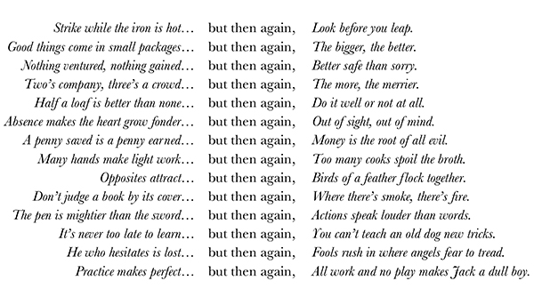

我们忍不住想在这张清单中加上一个双语例子，即，

We are tempted to add to this list one bilingual example — namely,

Pierre qui roule n’amasse pas mousse（滚石不生苔）……但话又说回来，A rolling stone gathers no moss（滚石不生苔）。

*Pierre qui roule n’amasse pas mousse…* but then again, *A rolling stone gathers no moss*.

奇怪的是，尽管英国编纂的词典倾向于认同这条国际性谚语的法语解释（即不断迁移，就永远不会扎下深根，也不会获得任何有价值的东西），我们通过非正式观察发现，大多数美国人听到这条谚语，却作相反的理解。也就是说，他们认为对一个人（或一块石头）来说，长出苔藓显然是坏事，所以在他们看来，这条谚语劝诫人们不断行动，以免积上一层讨厌的硬壳。讽刺之处在于，尽管英语和法语的谚语逐词来说意思相同，人们的解读却常常截然相反；对美国人来说，其意思往往大致是：“不断滚动，才不会停滞。”帕斯卡也许会说：“真理一越过大西洋，就变成谬误。”

Oddly enough, even if dictionaries compiled in Britain tend to agree with the French-language interpretation of this international proverb (namely, that by constantly moving about one never acquires any deep roots or anything of value), we have informally observed that most Americans hear this proverb in the opposite fashion. That is, they consider the gathering of moss to be an obviously bad thing to happen to a person (or a stone), and so from their point of view, the proverb exhorts people to stay constantly on the move in order to avoid acquiring a nasty crust. The irony is that although the English and French proverbs say the same thing on a word-by-word level, their interpretations are often quite opposite, and for Americans the meaning tends to be roughly, “Keep on rolling so you won’t stagnate.” Pascal might have said, “A truth becomes a falsity once it crosses the Atlantic.”

不过，还是回到主要清单吧……每一行都呈现一对断言相互矛盾的谚语，这个事实说明，重要的不是谚语是否为真，而是它能否照亮一个情境，使我们看到的东西不只是对事件的简单叙述。Don’t judge a book by its cover（别凭封面判断一本书）和 Where there’s smoke, there’s fire（有烟必有火）是两个范畴，它们帮助人突出两方面的重要性：一方面，不被廉价的吸引注意力的花招分心，往事物的表层之下看；另一方面，不忽略眼前的东西，注意显著的线索。这两种相反的立场体现于简短而熟悉的短语中，如果它们是一个人词汇库的一部分，就可以用来给非常复杂的新情境贴上精炼的标签，从而简洁地将其范畴化，也由此暗中传达对这些情境的整套态度。

But back to the main list… The fact that each line features a pair of proverbs that assert contradictory things shows that what counts is not a proverb’s truth, but its ability to cast light on a situation, allowing it to be seen as more than simply a recitation of events. *Don’t judge a book by its cover* and *Where there’s smoke, there’s fire* are categories that help one to highlight, on the one hand, the importance of not being distracted by cheap attention-getting tricks and of looking below the surface of things, and on the other hand, the importance of not ignoring what’s right in front of one’s eyes and of paying attention to salient clues. These two opposite stances, embodied in short and familiar phrases, can, if they form part of one’s lexicon, be used to pin pithy labels on, and thus concisely categorize, novel situations that are very complex, thereby implicitly conveying entire attitudes about them.

谚语所指的范畴，与其他范畴一样，并不是陈述。因此，Don’t judge a book by its cover 这个范畴，尽管表面上如此，却不是一项陈述（的确，不应该凭封面判断一本书！）——正如桌子或鸟这个范畴不是陈述一样。它是可以对各种情境采取的一种观点。正如鸟这个范畴是进行推断的平台（如果某物是一只鸟，它大概会飞、会唱、有羽毛、住在巢里……），而不是陈述，说“Don’t judge a book by its cover”也是一种识别标志：自己正处在需要审慎判断的情境中，必须确保深入表层之下，并运用批判能力。还须记住，对情境的这种范畴化，与其他范畴化一样，可能是不恰当的。人可以假定一个装满细小白色颗粒的小玻璃容器里放的是盐而不是糖，不久就发现自己错了；同样，人有时会把情境归入 Don’t judge a book by its cover 范畴，后来才意识到这是一个不明智的判断。有些情况下，封面其实完美地代表了书籍，凭封面作判断也完全恰当；在某些生活情境中，只依据表层线索作出迅速判断，实际上可能至关重要。郑重说出“Don’t judge a book by its cover”的人，不一定抓住了被他如此贴标签的情境的核心。那反而很可能是个 Where there’s smoke, there’s fire 的情境。

The categories denoted by proverbs are not statements any more than other categories are statements. Thus the category *Don’t judge a book by its cover* is not, despite its surface appearance, a statement (indeed, one shouldn’t judge a book by its cover!) — no more than the category *table* or *bird* is a statement. It is a point of view that can be adopted on various situations. Just as the category *bird* is a platform for making inferences (if something is a bird, probably it flies, sings, has feathers, lives in a nest…) rather than a statement, so saying “Don’t judge a book by its cover” is a sign of recognition that one is in a situation where prudence is called for in judgment, and where one should make sure to look well below the surface and to use one’s critical faculties. And it’s important to remember that this categorization of a situation, just like others, can be an inappropriate one. Just as one can assume that a small glass container filled with fine white grains contains salt rather than sugar, soon discovering one’s mistake, so one can sometimes categorize a situation as belonging to the category *Don’t judge a book by its cover*, only to realize later that this was an ill-advised judgment. In some cases, books *are* in fact perfectly represented and appropriately judged by their covers, and in some life situations, making a snap judgment based solely on surface-level cues can in fact be crucial. A person who intones “Don’t judge a book by its cover” has not necessarily put their finger on the crux of the situation that they have so labeled. It may well be a *Where there’s smoke, there’s fire* situation instead.

### 手机被盗可以“是”被狗咬A Stolen Cell Phone can “Be” a Dog Bite

显然，“Once bitten, twice shy”远远超出了被狗（或蛇）咬过的人此后随时都会避开所有狗（或蛇）这一想法。虽然这条谚语表面上讲的是动物咬伤的受害者，它实际讲的却是无数其他情境，其细节完全无法预料。重要的是，那些其他情境应当与谚语中四个词唤起的微小事件共享一个概念骨架。因此，我们很容易把下面任何一个情境看作值得贴上这个标签：

Obviously, “Once bitten, twice shy” goes way beyond the idea that someone who has suffered a dog (or snake) bite will henceforth steer clear of all dogs (or snakes) at all times. Although the proverb is ostensibly about animal-bite victims, it is really about any number of other situations whose details are completely unforeseeable. What counts is that those other situations should share a conceptual skeleton with the microevent conjured up by the four words in the proverb. Thus, we could easily see any of the following situations as meriting the label:

结婚后，A 生了两个孩子，随后她的婚姻开始破裂。她发现丈夫多年来一直背着她出轨，对她撒谎。最终，婚姻以非常痛苦的离婚告终。从那以后，A 对所有男人都心存怀疑，无论他们多么温柔善良。

After marrying, A. had two children, and then her marriage started falling apart. She found out that her husband had been cheating on her and lying to her for years. It ended up in a very painful divorce. Ever since then, A. has been suspicious of all men, no matter how gentle and kind they are.

B 和 C 来自中国，住在旧金山。一天，他们的儿子在公立学校遭到一名同学的种族嘲弄。第二天，父母就让他退了学，转入一所非常昂贵的私立学校。

B. and C. are from China and live in San Francisco. One day, their son was the victim of racial taunts from a classmate in his public school. The next day, his parents pulled him out of that school and enrolled him in a very expensive private school.

D 走下一段陡峭的楼梯时，脚下一滑，摔下了好几级台阶。虽然跌倒没有造成严重后果，他重新站起时却浑身发抖，因为他知道自己很容易就可能摔断好几根骨头。接下来两天，D 无论走到哪里都极其小心。他上下家里的楼梯时慢得像蜗牛，仅仅是骑自行车这个念头，在他看来就疯狂到了极点。

While walking down a steep staircase, D. slipped and fell down several stairs. Although his fall had no serious effects, when he got back to his feet, he was trembling, because he knew he could easily have broken several bones. For the next two days, everywhere he walked, D. took exceeding care. While going up and down his stairs at home he went at a snail’s pace, and the mere idea of riding his bicycle struck him as the height of insanity.

公寓被人入室盗窃后，此前对安全问题毫不在意的 E 一下子买了高级防盗警报器和最昂贵的安全锁，并立刻给所有门窗都装上这些锁，包括地下室的窗户；那些窗户小得几乎无法想象有人能从那里闯入。

After her apartment was burglarized, E., who till then had paid no attention to safety matters, all at once bought a fancy burglar alarm as well as the most expensive safety locks, and she promptly installed the locks on all her doors and windows, including her basement windows, which were so small that for anyone to break in through them would have been well-nigh inconceivable.

在城里一个有点危险的区域，F 的手机在大白天、街道中央被劫匪抢走。从那以后，每次使用手机，F 都始终处于最高度的戒备中，非常紧张地环顾四周，即使身在豪华酒店或高档餐厅也是如此。

F.’s cell phone was stolen in broad daylight by a mugger in the middle of the street in a somewhat dangerous part of town. Ever since then, whenever he uses his cell phone, F. is constantly on the highest level of alert, looking all around himself with great nervousness, even when he is in swanky hotels or ritzy restaurants.

这说明，“Once bitten, twice shy”传达了这样一种想法：当某个事件导致负面后果时，有些人会形成过度敏感的回避策略，甚至不惜错失可能极好的机会，以免再遇到任何哪怕隐约让人想起触发事件的情境，而不管客观上它似乎带来的风险多么小。更简洁地说，经历痛苦事件之后，人们往往会对让他们想起最初事件的事情惊惧不安，哪怕这种相似仅仅是表层的。

As this shows, “Once bitten, twice shy” conveys the idea that when some event leads to negative consequences, some people develop a hypersensitive avoidance strategy, even at the price of missing out on potentially excellent opportunities, in order not to re-encounter any situation that is even vaguely reminiscent of the triggering one, no matter how little risk it would seem to pose objectively. More succinctly, in the wake of a painful event, people tend to be skittish about events that remind them, however superficially, of the original event.

这个关于创伤事件后续影响的想法，并非不言自明。情绪打击会造成持久的负面后果——会有“灵魂的伤口”——这一想法，直到最近一百多年才作为心理学观念被接受。创伤原本仅被视为生物体的身体损伤；当深刻的情绪打击会造成长期影响成为公认的见解之后，创伤被延伸到了心理损伤领域。这些影响把受害者卷入多层面变化的漩涡，有时可逆，有时则不可逆。

This idea, having to do with the aftermath of a traumatic event, is not self-evident. The idea that an emotional shock can have lasting negative consequences — that there can be “wounds to the soul” — became acceptable only in the last hundred and some years as a psychological notion. Trauma, originally thought of solely as *physical* damage to a living being, was extended to the realm of *psychic* damage when it became part of the received wisdom that deep emotional shock can cause long-lasting repercussions, which suck the victim into a vortex of changes at many levels, sometimes reversible, sometimes not.

### 类比联想的不可抑制性The Irrepressibility of Analogical Associations

包括土耳其语、意大利语、西班牙语、德语和法语在内的几种语言，都有谚语讲述某些类比看见了就无法抑制。例如，法语中说“Il ne faut pas parler de corde dans la maison d’un pendu”，英语中有一个极罕见的对应说法：“One mustn’t speak of rope in a hanged man’s house”（不要在吊死者家里谈绳子）；还有一个更加鲜为人知的说法：“One mustn’t say ‘Hang up your fish’ in a hanged man’s house”（不要在吊死者家里说“把你的鱼挂起来”）。这类谚语表达的想法当然是，人们动不动就会不由自主地作出类比联想，每个人都应该体察这个事实。因此，即使只是无心地想提到一段用来捆包裹的绳子，或说某些鱼应该挂起来晒干，在被吊死者的家人面前这样说也会很粗鲁。不管如何措辞，吊死这件事都会鲜明地呈现在说出口的话里。因此，在某些情况下，有些事情不能说，甚至不能暗示。

Several languages, including Turkish, Italian, Spanish, German, and French, have proverbs about the irrepressibility of seeing certain analogies. Thus in French one says, “Il ne faut pas parler de corde dans la maison d’un pendu”, and it has a very rare English counterpart, “One mustn’t speak of rope in a hanged man’s house”, and, even more obscure, “One mustn’t say ‘Hang up your fish’ in a hanged man’s house”. The idea expressed by such proverbs is of course that people cannot help making analogical associations at the drop of a hat, and that everyone should be sensitive to this fact. Thus, even if one innocently wishes to allude to a piece of rope that was used to tie a package, or to say that some fish should be hung out to dry, it would be boorish to do so in the presence of the family of someone who had been hanged. The hanging would be vividly present in the uttered words, no matter how the thought was phrased. And so in certain circumstances, certain things cannot be said or even hinted at.

这条谚语向人类认知的流动性致意，但当然没有讲出全部情况。实际上，遇到的情境触发了谚语的自发提取（认知科学家罗杰·尚克在《动态记忆》中描述过这一点），这表明我们的日常感知远不止是在提到绳子时看见亲人被吊死。当一条谚语在不到一秒内浮现时，两个乍看之下似乎毫无共同之处的情境之间的关联，就已经被发现了。例如，在吉姆绕远避开露西重新搭好的木积木围栏，突然脱口说出“Once bitten, twice shy”的故事中，关联仅存在于深层语义层面。没有狗，没有咬伤，也没有身体疼痛；有的是意外踢碰、倒下的积木，以及目睹的心理痛苦（换句话说，不是吉姆自己的心理痛苦，而是通过他人间接体验的苦恼）。吉姆不是害怕外界蓄意的攻击给自己带来身体疼痛，而是担心无意中造成别人的心理痛苦。然而，这个类比在他看来显而易见，甚至微不足道——一句随口的话，一桩小事，不值一提——根本算不上值得骄傲的心智壮举。对于上面清单中其他所有 Once bitten, twice shy 的情境，也可以作出类似评论。没有狗，却有一只“抽象的狗”；没有咬伤，却有一次“抽象的咬伤”；往往没有身体疼痛，只有映射到它的东西。不过，每个事件的核心都有一个人，对不愉快的情境反应过度，有时极其过度。这才是关键的共同核心。

This proverb tips its hat to the fluidity of human cognition, but of course it doesn’t tell the whole story. Indeed, the spontaneous retrieval of proverbs, triggered by situations one encounters (as described in the book *Dynamic Memory* by cognitive scientist Roger Schank), shows that our everyday perception goes far beyond just seeing the hanging of a loved one in a mention of rope. When a proverb comes to mind in but a fraction of a second, a link has been discovered between two situations that would seem, on first glance, to have nothing whatsoever in common. For example, in the story where Jim, as he widely skirts Lucy’s rebuilt wooden-block fence, suddenly blurts out, “Once bitten, twice shy”, the connections exist only at a deeply semantic level. There was no dog, no bite, and no physical pain; instead there was an accidental kick, a falling block, and some psychic pain witnessed (in other words, not Jim’s own psychic pain, but vicariously-experienced anguish). Rather than fearing a deliberate external attack bringing about his own physical pain, Jim was concerned about accidentally causing someone else mental anguish. And yet the analogy seemed obvious, even trivial, to him — a throwaway remark, a mere bagatelle, nothing to write home about — hardly a mental feat to be proud of. And for all the other *Once bitten, twice shy* situations given in our list above, one could make similar comments. There is no dog, but there is an “abstract dog”; there is no bite, but an “abstract bite”; there is often no physical pain, but just something that maps onto it. At the core of each event, however, there is a person who overreacts, sometimes wildly so, to an unpleasant situation. That is the crucial shared core.

Once bitten, twice shy 这个遍布世界的范畴，在全球各种文化中以许多不同的语言形态出现；它们表面上各不相同，却由共享的概念骨架彼此联系。有趣的是，每种文化中的典型情境都如此简单、如此贴近日常生活，这使得谚语的信息无论用什么语言表达，都显得十分可信。例如，罗马尼亚人说：“吃东西烫伤过的人，连吃酸奶也要吹一吹。”阿富汗人说：“被蛇咬过的人，连绳子也怕。”中国人说：“被蛇咬过，连小蜥蜴都害怕。”当然，英语国家说：“Once bitten, twice shy。”所以，无论其表层语言外衣是什么，只要（1）某个事件产生了负面后果，（2）之后人们避开了一个表面相似的事件，不管它多么不可能产生负面后果，这同一个范畴都很可能被唤起。

The worldwide category *Once bitten, twice shy* pops up in many different verbal incarnations in various cultures around the globe, all of them superficially different, but tied to one another by their shared conceptual skeleton. It is interesting to notice how simple and down-to-earth each culture’s quintessential situation is, a fact that makes the proverb’s message seem very plausible, no matter what language it is in. Thus, for instance, in Romania people say, “Someone who gets burned while eating will blow even on yogurt.” In Afghanistan, “Someone bitten by a snake fears even a rope.” In China, “Bitten by a snake, frightened of tiny lizards.” And of course in English-speaking countries, “Once bitten, twice shy.” And thus this same category, whatever its surface-level linguistic guise may be, has a good chance of being evoked whenever (1) an event gave rise to negative consequences, and (2) a superficially similar event was subsequently avoided, no matter how unlikely it was to have negative consequences.

在法国，这个形象是沸水烫伤了猫，此后猫避开所有水，连冷水也不例外。冷水不能烫伤这一事实，说明避开它的愿望是不理性的，因此这种谨慎过了头。同样，虽然蛇咬会令人疼痛并造成伤害，一根绳子（表面上像蛇）和一只小蜥蜴（生物学上的远亲）却都没有丝毫造成伤害的风险。

In France, the image is of boiling water scalding a cat, followed by the cat’s shunning of all water, even cold. The fact that cold water cannot scald shows that the desire to avoid it is irrational, and thus that the caution is overdone. Likewise, while a snakebite is painful and harmful, neither a rope (superficially resembling a snake) nor a tiny lizard (a distant biological cousin) presents the slightest risk of harm.

我们可以随意创造同一路数的新“谚语”，用来标示完全相同或十分接近的范畴。读者也许会觉得玩这个游戏很有趣，创造出“Once bitten, twice shy”的其他版本。下面给出几个伪谚语样品，权当抛砖引玉：

Novel “proverbs” along the same lines can be created at will, which serve to label exactly the same category, or very close categories. The reader may find it amusing to play this game, giving birth to alternative versions of “Once bitten, twice shy”. Here are a few sample pseudo-proverbs, just to set the ball rolling:

遭劫的人，见自己的影子也退缩。从前溜冰无畏，如今踩干土亦惊。骨头硌断一颗双尖牙，连黄油也不敢咬。被敌人袭击，连最好的朋友也害怕。挨石头打过一回的狗，如今见棉花也畏缩。红灯区遭抢，茶馆里心惊。被背叛的女人，连最正直的男人也躲避。某个冬天着过凉，从此夏夏穿毛衣。破过产的人，连最稳当的买卖也拒绝。被门夹过的小手指，永远远离门把手。

Mugging victims flinch at their own shadows.  
Once fearless on ice, now fearful on driest dirt.  
Broke a bicuspid on a bone, balks at biting butter.  
Assaulted by one’s enemy, afraid of one’s best friend.  
Struck once by a stone, the cur now cringes at cotton.  
Robbed in the red-light district, terrified in a teahouse.  
A woman betrayed shuns even the most virtuous of men.  
Caught cold one winter; now dons sweaters each summer.  
One who’s been through bankruptcy spurns the surest of deals.  
Little fingers smashed in doors will ever steer clear of doorknobs.

我们考察过的所有精炼短语，无论取自真实文化还是由我们创造，都会使人想起并适用于围绕创伤事件展开的情境。许多习语仅凭组成词无法看懂，如“to see red”（看见红色，意指发怒）、“to sing the blues”（唱蓝调，诉说忧愁）、“to be yellow”（呈黄色，胆怯）、“to be in the pink”（处于粉红色中，身体极好）、“to be in the black”（处于黑色中，有盈余）、“to spill the beans”（倒出豆子，泄露秘密）、“to shoot one’s wad”（打出全部填塞物，耗尽本钱）、“to fly off the handle”（飞离把柄，大发脾气）、“to go on a wild goose chase”（追逐野鹅，徒劳追寻）、“to go Dutch”（各自付账）、“to be in Dutch”（陷入麻烦）、“to say uncle”（认输）或“to be a Dutch uncle”（做严厉训诫者）；与它们不同，谚语有双重优点：明白地为范畴命名，同时又令人容易记住。的确，前面那些习语即使词源学家能解释其来历，对外国人来说仍会像“cocktail”（鸡尾酒）、“understand”（理解）和“handsome”（英俊）这样的复合词一样晦涩、任意；谚语却容易唤起易于想象的情景——“All that glitters is not gold”（闪光的不都是金子）、“A leopard cannot change its spots”（豹子改不了斑点）、“A rolling stone gathers no moss”（滚石不生苔）——这使范畴与语言标签之间的联系更紧密、更牢固。

All the pithy phrases we’ve considered, whether taken from real cultures or invented by us, bring to mind and apply to situations centered on a traumatic event. In contrast to so many idioms that are impenetrable on the basis of just their component words, such as “to see red”, “to sing the blues”, “to be yellow”, “to be in the pink”, “to be in the black”, “to spill the beans”, “to shoot one’s wad”, “to fly off the handle”, “to go on a wild goose chase”, “to go Dutch”, “to be in Dutch”, “to say uncle”, or “to be a Dutch uncle”, a proverb has the twofold virtue of naming a category transparently and doing so in a catchy fashion. Indeed, unlike the preceding idioms, which, even if an etymologist could explain their origins, will still strike foreigners as being just as opaque and arbitrary as compound words such as “cocktail”, “understand”, and “handsome”, proverbs readily conjure up easily visualizable scenarios — “All that glitters is not gold”, “A leopard cannot change its spots”, “A rolling stone gathers no moss” — and this tightens and strengthens the link between the category and its linguistic label.

### 谚语的恰当适用范围The Proper Scope of a Proverb

谚语适用得有多广？一条给定的谚语可以说涵盖多大范围的情境，而不会让人觉得牵强得难受？正如前文所见，与谚语相关的心理范畴，其成员在表面上极为不同。这意味着这样的范畴非常宽广，汇集了许多共同要旨仅位于高度抽象层面的情境。

How broadly does a proverb apply? How wide is the scope of situations that a given proverb can be said to cover, without one feeling that one is stretching things uncomfortably? As we have seen in the foregoing, the mental categories associated with proverbs have members that on the surface are extremely different. This means that such categories are very broad, and that they bring together situations whose common gist is located only at a high level of abstraction.

法语谚语“Qui vole un œuf vole un bœuf”有一个相对不太为人所知的英语对应：“He who will steal an egg will steal an ox”（会偷鸡蛋的人，也会偷牛）。阿拉伯语还有一条谚语说：“会偷鸡蛋的人，也会偷骆驼。”有人可能主张，这两条谚语表达了非常不同的想法，因为骆驼和牛是相当不同的动物。当然，这是把事情放到一个荒唐的字面层面上了。听到任何一条谚语时，我们本应理解比一个偷过鸡蛋的男性人类有一天还会偷牛或骆驼宽泛得多的东西。我们应该通过自然向外概括的倾向推断：任何人，无论男女，只要偷了不大的东西，很可能会继续下去，后来实施更严重的偷窃。一个偷拿巧克力棒的学生，长大后很可能偷毕加索的画；或者说，“五岁偷回形针，二十五岁成惯匪抢银行”。但隐藏在谚语表层之后的教训，很可能比这还宽泛得多，因为这里真正的重点不是偷窃——所针对的是任何一种坏事，包括考试作弊、打架等等。这条谚语的核心是，小规模的坏事可能只是滑坡的第一步，导致此后与它相似、但规模大得多的坏事。

The French proverb “Qui vole un œuf vole un bœuf” has a relatively little-known counterpart in English: “He who will steal an egg will steal an ox.” There is also a proverb in Arabic that says “He who will steal an egg will steal a camel.” Someone might argue that these two proverbs express very different ideas, a camel and an ox being rather different beasts. Of course this takes things at a ridiculously literal level. In hearing either proverb, we are meant to understand something far more general than the notion that a male human being who has stolen an egg will one day also steal either an ox or a camel. We are supposed to infer, through our natural tendency to generalize outwards, that any person, male or female, who steals something smallish stands a good chance of going on and committing more serious acts of thievery later on. A schoolchild who swipes a candy bar may well steal Picassos as a grownup, or perhaps “Paper-clip filcher at five, hardened bank robber at twenty-five.” But the intended lesson hidden behind the proverb’s surface is probably considerably broader than that, since thievery is not really the point here — the targeted idea is bad deeds of any sort, including cheating on tests, engaging in fights, and so forth. The crux of the proverb is that bad deeds on a small scale can be but the initial step on a slippery slope leading towards subsequent bad deeds that resemble them but on a much larger scale.

除了最初坏事在规模上扩大的想法，也有可能，随着坏事的规模日益增大，它的性质也改变了，从侮辱变成袭击，从袭击变成暗杀。因此，在学校从别的孩子储物柜里偷铅笔、长大后成为职业杀手的孩子，也会被“会偷鸡蛋的人，也会偷牛”所涵盖。

Aside from the idea of scaling up the initial bad deed, it is also possible that as the bad deed grows in size over time, it also changes in nature, moving from an insult to an assault, from an assault to an assassination. The kid who steals a pencil from another kid’s locker in school and then as an adult becomes a hired killer would thus be covered by “He who will steal an egg will steal an ox.”

但我们还没说完，因为谁说这条谚语只涵盖犯罪呢？为什么不让这个范畴再灵活一点，容纳各种负面行为，无论犯罪与否？例如，小时候对父母无礼，可能导致长大后习惯用挑衅的语言说话；小时候说无伤大雅的小谎，可能导致对配偶说弥天大谎；小时候说“Darn!”（可恶！），也可能是长大后像水手一样满口脏话的前奏。那么，所有这些情况都被“会偷鸡蛋的人，也会偷牛”涵盖了。真的会吗？这个谚语范畴隐含而未明说的边界在哪里？

But we are not done yet, for who says that our proverb covers only crimes? Why not let the category flex a bit more, allowing it to cover all kinds of negative behavior, criminal or not? For example, being fresh to one’s parents as a kid could lead to habitual aggressive language when one is grown up, or telling little white lies as a kid could lead to telling whoppers to one’s spouse, or saying “Darn!” as a kid could be a prelude to swearing like a sailor when one is big. All of these cases would then be covered by “He who will steal an egg will steal an ox.” Or would they? Where are the implicit, unspelled-out boundaries of this proverb’s category?

假设我们允许范围变得更加广泛。例如，我们可以舍弃所谈的行为必须是负面的这个想法。这样，谚语的含义就大致变成“小行动是大行动的前奏”。这可能意味着，比如，一个往乞丐帽子里放一便士的孩子，长大后很可能主持一个慈善组织；或者，一个年幼时开始学乐器的人会变成音乐会演奏家。

Suppose we allow the scope to become more encompassing yet. We could, for instance, drop the idea that the behavior in question has to be negative. In that case, the proverb’s meaning becomes roughly, “Small acts are a prelude to larger acts.” This might mean, for instance, that a child who drops a penny in a beggar’s cap stands a good chance of going on to head up a charitable organization when grown up, or that someone who starts a musical instrument when young will turn into a concert artist.

另一方面，我们猜测大多数人会说，我们在这里过头得太远了——把谚语范围扩大到既适用于负面行动，也适用于正面行动，甚至不在乎其所围绕的较早与较晚行动是否相似，这不忠于它的真正含义。这就像用“chair”（椅子）不仅指人们千百年来刻意设计的所有标准椅子，还指无数其他实体物件，因为人几乎什么上面都能坐。到了这个地步，“chair”就丧失了大部分有用的含义。这一切表明，对谚语存在一个最适宜的概括层次，不会把它的含义稀释到荒谬的程度。

On the other hand, we suspect that most people would say that we’ve gone way overboard here — that expanding the scope of the proverb so that it applies to positive as well as negative actions, and not even caring about any similarity existing between the earlier and later acts that it is centered on, is not faithful to what it genuinely means. It’s like taking the word “chair” to stand not only for all the standard chairs that people have deliberately designed over the millennia, but also for countless other physical objects, since a person can sit on just about anything. At that point, the word “chair” has lost most of its useful meaning. All this suggests that there is an optimal level of generalization of the proverb that does not dilute its meaning to the point of absurdity.

把它听成只适用于偷窃行为，肯定过于狭窄，因为关键想法似乎是某种滑坡，从小“罪过”滑向大致同类的更大罪过。在谚语中只听见对偷窃的提及，会非常局限。想来，这条谚语的目的，是使人警惕人生早期各种负面行为，从而尽力阻止这些行为随着时间推移而失控。“把坏行为扼杀在萌芽中！”才是所给建议的核心。

It is certainly too narrow to hear it as applying solely to acts of thievery, because the key idea seems to be some kind of slippery slope leading from small “sins” to larger sins of roughly the same type. To hear only an allusion to thievery in the proverb would be very limiting. Presumably, the proverb’s purpose is to put people on guard concerning all sorts of negative actions early in life, so that they might try to prevent those actions from growing out of control as time goes by. “Nip bad acts in the bud!” would be the crux of the advice being given.

然而，如果范围扩展到没有负面含义的行动，那么警惕这些行动的想法就不再有任何意义。我们不必警惕善行，不必将其扼杀在萌芽中。固然，我们很容易想象从小善行滑向大善行的一道滑坡——但那错失了谚语的要点。这样做，会牺牲谚语很大一部分“咬劲”。这种牺牲也许会被视为抽象性质的正常结果，因为按定义，“抽象”就意味着舍弃所处理事物中较不重要的方面；但如果进行一系列抽象行为时丝毫不顾意图，那么迟早会干脆丢失要旨。的确，抽象的小罪过，也可能导致抽象的大罪过。

If, however, the scope is extended to actions without negative import, then the idea of being on guard against them no longer makes any sense. We don’t need to be on guard against good deeds, don’t need to nip them in the bud. To be sure, we can easily imagine a slippery slope leading from small good deeds to large ones — but that misses the proverb’s point. In so doing, we will be sacrificing much of the “bite” of the proverb. Such a sacrifice might be seen as a standard consequence of the nature of abstraction, since by definition, “to abstract” means to abandon the less important aspects of what one is dealing with, but if a series of acts of abstraction is carried out without any attention being paid to intent, sooner or later the gist will simply be lost. Indeed, a small sin of abstraction may lead to a large sin of abstraction.

就“会偷鸡蛋的人，也会偷牛”这条谚语来说，我们可以在抽象上再进一层，不仅忽略扩大（从鸡蛋到牛）的想法，也忽略两个分句动词相同这一点，甚至忽略它们之间的任何语义关系；这就会让我们得出结论：谚语的意思是，一件事会导致另一件事。这个极端的抽象层次包含一切存在因果的情境，可如此极端地向上跳跃，对任何人又有什么好处？原来谚语的丰富性丢失了；实际上，被提升到这种平流层般的抽象高度时，“会偷鸡蛋的人，也会偷牛”最终与“一朝被咬，二度胆怯”就毫无区别了。

In the case of our proverb “He who will steal an egg will steal an ox”, we could take things one level further in abstraction, not just ignoring the idea of magnification (from egg to ox), but also ignoring the sameness of the verbs in the two clauses and even any semantic relation between them; this would lead us to conclude that the proverb means that *one thing leads to another.* This extreme level of abstraction includes all situations in which there are causes and effects, but what good does such an extreme leap upwards do anyone? The richness of the original proverb is lost, and in fact, when carried to this stratospheric level of abstraction, “He who will steal an egg will steal an ox” winds up being no different from “Once bitten, twice shy.”

虽然沿着抽象的梯子逐级向上跳，在某些情况下可能是聪明与思维灵活的表现，但如果走得太远，它就会变成一个空洞而轻浮的游戏；拿谚语玩这种游戏，暴露的是对它贫乏而肤浅的理解。实际上，最终，抽象过度会变得类似于拘泥字面过度，因为把任何两件东西都看成类比，并不比完全看不出任何类比更有洞察力。

Although jumping up the ladder of abstraction rung by rung may in some cases be a sign of intelligence and fluid thinking, if it is taken too far, it becomes a vacuous and frivolous game, and playing such a game with a proverb reveals an impoverished and superficial understanding of it. Indeed, in the end, an excess of abstraction winds up being similar to an excess of literality, because seeing any two things as analogous is no more insightful than not being able to see any analogies at all.

因此，似乎存在一个最适宜的抽象层次；如果我们在到达这个层次之前停下，就会排除大量与谚语严丝合缝的情境，例如幼儿园里满口脏话的小不点，多年后成了火山般暴躁的配偶；反过来，如果超过最适宜的抽象层次，就会放进大量无关情境，例如一个六岁时在街角卖柠檬水赚了三美元、六十岁时成了软饮料业亿万富翁的孩子。

It would thus seem that there is an optimal level of abstraction, and that if we stop before reaching that level, we will exclude a host of situations that fit the proverb like a glove, such as the pint-sized swearer in nursery school who many years later turns into a volcanic spouse, and contrariwise, if we go beyond the optimal level of abstraction, we will let in a flood of irrelevant situations, such as the kid who at age six made three dollars selling lemonade at the corner and went on to become a billionaire in the soft-drink business at age sixty.

为了追寻谚语的某种终极含义而跳到如此稀薄的抽象层次，让人想起这样一个人：把眼前每件东西都叫“thing”（东西）、“thingy”（那个东西）、“deal”（那玩意儿）或“whatchamacallit”（那个叫什么来着），于是很容易说出“那个东西在那个叫什么来着里，放在那玩意儿上”这样的抽象观察，而大多数人会觉得“钢笔放在客厅的书桌上”更清楚、更有用。后一句更为具体，在我们看来显然优于前一句的含混，不过这是品味问题。

Jumping up to such a rarefied level of abstraction as a quest for some ultimate meaning of a proverb is reminiscent of a person who would label every object in sight a “thing”, a “thingy”, a “deal”, or a “whatchamacallit”, and thus would be prone to coming out with such abstract observations as “The thingy is sitting on the deal in the whatchamacallit”, whereas most of us would find it clearer and more useful to say, “The pen is sitting on the desk in the living room.” The greater specificity of the latter sentence strikes us as obviously preferable to the ambiguity of the former, but it’s a matter of taste.

这让人想起叫作“smurfs”（蓝精灵）的卡通人物，他们有一个高度抽象而简洁的词汇库：所有名词都由超级抽象的词“smurf”涵盖，其他词类也受到类似处理。例如，他们可能兴奋地宣布：“We’re off to smurf a smurf tonight!”（我们今晚要去 smurf 一个 smurf！）即使没有完全明白这句话的意思，也很难不被整体的兴奋感感染。如果蓝精灵们有谚语储备，那里面就会有“A smurfing smurf smurfs no smurf”（一个正在 smurf 的 smurf 不 smurf 任何 smurf）这样的智慧珍珠。对蓝精灵自身来说，这个短语也许满是洞见，但对我们来说，它的含义仍难以捉摸。

This recalls the cartoon figures called “smurfs”, who have a highly abstract and concise lexicon, in which all nouns are covered by the super-abstract term “smurf”, and other parts of speech are treated somewhat similarly. For example, they might enthusiastically announce, “We’re off to smurf a smurf tonight!”, and even if one didn’t fully get the meaning of this utterance, it would be hard not to be caught up in the general feeling of excitement. And if the smurfs have a stock of proverbs, then it would contain such pearls of wisdom as “A smurfing smurf smurfs no smurf.” Perhaps for the smurfs themselves, this phrase would be filled with insight, but for us its meaning remains elusive.

只有如此抽象的心理词汇库——如此稀薄的一组概念——的问题，在于它允许作出的区分太少，有点像高海拔空气稀薄处严重的缺氧。抽象有它的优点，我们会在适当时机指出；但如果不能作出区分，思考就会像在珠穆朗玛峰顶呼吸一样困难。

The problem with having only such an abstract mental lexicon — such a rarefied set of concepts — is the paucity of distinctions that it allows to be made, somewhat like the severe paucity of oxygen at rarefied altitudes. Abstraction has its virtues, which we will point out at an appropriate moment, but if one cannot draw distinctions, then thinking becomes as difficult as breathing at the top of Mount Everest.

### 从鸡蛋到橡子，从牛到橡树From Eggs to Acorns, From Oxen to Oaks

即使我们忘掉偷鸡蛋和牛的人，事物随着时间能够变得更大、更好的想法，在我们周围也随处可见，毕竟成年人曾是孩子；今天的跨国巨头曾是初创的小机构；史蒂夫·乔布斯和史蒂夫·沃兹尼亚克在车库里制造出第一台苹果电脑，随后才创立他们传奇的公司；谢尔盖·布林和拉里·佩奇在门洛帕克一处简陋住所注册了谷歌；阿尔伯特·爱因斯坦先学会读写，随后才发展出相对论；教皇曾是小教堂里的神父；征服珠穆朗玛峰的人先爬小山，随后才迈向大目标；重大的慈善行动之前是微小的善举；每段伟大的友谊，最初都只是试探性的好感；乐器演奏大师曾是音乐新手；每位国际象棋大师都必须在某个时候学习规则；强大的思想先产生少量成果，随后才带来巨大进步……这一切与偷鸡蛋者变成偷牛者相去甚远，但仍值得有一两条谚语，以及任何谚语暗中象征的丰富范畴。

Even if we forget about people who steal eggs and oxen, the notion that things can become bigger and better over time is everywhere to be found around us, for after all, grownups were once children; today’s multinational giants were once fledgling outfits; Steve Jobs and Steve Wozniak made the first Apple computer in a garage before going on to found their legendary firm; Sergey Brin and Larry Page incorporated Google in a humble dwelling in Menlo Park; Albert Einstein first learned to read and write before developing his theories of relativity; popes were once priests in little churches; conquerors of Everest climbed small hills before moving on to the big time; major acts of philanthropy were preceded by minuscule acts of charity; every great friendship was once just a tentative affinity; virtuoso instrumentalists were once musical novices; every chess master had to learn the rules at some point; powerful ideas gave rise to modest fruit before resulting in huge advances… All of this is far from egg-stealers turning into ox-stealers, but it nonetheless deserves a proverb or two, along with the rich category that any proverb covertly symbolizes.

怎样才能把“会偷鸡蛋的人，也会偷牛”转化为更乐观的想法？关键问题是明确我们想在这个范畴中抓住的核心想法，因为可以想象各种相互关联却又不同的可能性。最普遍的版本，只不过是大规模的事物以某种方式成为一个“放大”过程的果实这个想法。

How might “He who will steal an egg will steal an ox” be converted into a more upbeat thought? The key question is to pinpoint the core idea that one wishes to capture in this category, since various possibilities, related but distinct, might be imagined. The most general version would simply be the idea that things on a large scale are the fruits, in some fashion or other, of a process of “amplification”.

因此，放大可以来自把若干小东西合在一起：大东西是许多小东西的“总和”。许多谚语以某种形式捕捉了这个想法。例如：“Many a mickle makes a muckle”（许多 mickle 组成一个 muckle，不管这些东西是什么！）；“Many drops make a shower”（许多水滴形成一阵雨）；“United we stand; divided we fall”（团结则立，分裂则倒，既描绘乐观图景，也描绘悲观图景）；“E pluribus unum”（合众为一）。它们都传达了这样的想法：单独而言微不足道的实体，大量聚集后，可以产生规模庞大、力量强大的实体。

Thus, amplification can come from putting together a number of small items: a big thing is the “sum” of many little things. There are numerous proverbs that capture this idea in some form or other. For example: “Many a mickle makes a muckle” (whatever those items might be!); “Many drops make a shower”; “United we stand; divided we fall” (which paints both an optimistic and a pessimistic picture); “E pluribus unum”. All of them get across the idea that individually insignificant entities, when put together in large numbers, can give rise to entities of great magnitude and strength.

然而，这些谚语没有一条明确涉及时间的流动。如果我们寻找从鸡蛋贼到牛贼这种悲观蜕变的乐观对应，那么目标就是一条强调单一好事物在很长时间中缓慢而稳定地演化或生长的谚语。因此，我们有著名的“Mighty oaks from little acorns grow”（雄伟橡树由小橡子长成），还有十八世纪英国作家戴维·埃弗里特对这个想法更铺陈的版本：“Large streams from little fountains flow, tall oaks from little acorns grow”（大河由小泉流出，高大橡树由小橡子长成）。

However, in none of these is time’s flow explicitly involved. If we are looking for an optimistic counterpart to the pessimistic egg-thief-to-ox-thief metamorphosis, then our goal is a proverb highlighting the slow but steady process of evolution or growth of a single good thing over a very long time. Thus we have the famous proverb “Mighty oaks from little acorns grow”, and a more elaborated version of this thought, from eighteenth-century English writer David Everett: “Large streams from little fountains flow, tall oaks from little acorns grow.”

另一种有关随时间放大的想法，是在很长时期内，一个接一个地把许多小行动（或物件）合起来，以完成一个宏伟目标——简言之，时间上的积累：“A long journey starts with a single step”（漫长旅程始于一步）；“Rome wasn’t built in a day”（罗马不是一天建成的）；“Little and often fills the purse”（少量而经常，装满钱袋）；“Drop by drop fills the tub”（一滴一滴装满桶）（或者倒转时间来看，“Drop by drop the sea is drained”，一滴一滴排干海，这在法语中是一条真正的谚语）；最后，带着更具破坏性的意味，“Little strokes fell great oaks”（小斧一下下，砍倒大橡树），这是本杰明·富兰克林《穷理查年鉴》中的一则劝诫。

A related notion of amplification over time involves putting together many small acts (or objects), one by one, over a very long period of time in order to accomplish a grand goal — in short, temporal accumulation: “A long journey starts with a single step”; “Rome wasn’t built in a day”; “Little and often fills the purse”; “Drop by drop fills the tub” (or, seeing things in a time-reversed fashion, “Drop by drop the sea is drained”, which, in French, is a genuine proverb); and finally, in a more destructive vein, “Little strokes fell great oaks”, a homily found in *Poor Richard’s Almanac* by Benjamin Franklin.

美国大学的筹款风格，体现了“会偷鸡蛋的人，也会偷牛”明确的语义反转；这种风格可以概括为“A little giver will one day a grander giver be”（小捐赠者有朝一日会成为更大捐赠者），或者更诗意地说，“Mighty donors from humble tippers grow”（慷慨巨额捐赠者由卑微的小费给予者长成）。再或者，“Someone who donates a book today may donate a library tomorrow”（今天捐一本书的人，明天可能捐一座图书馆），甚至“Butter up a million, smile and snag a billion”（奉承百万，微笑钓来十亿）。最后，为使语气更古雅，我们还可以改成：“A giver of eggs may one day give an ox”（送鸡蛋者有一天可能送牛）。或骆驼（camel）。或单峰骆驼（dromedary）。或宿舍楼（dormitory）。

A clear semantic reversal of “He who will steal an egg will steal an ox” is illustrated by the fund-raising style of American universities, which might be summarized as “A little giver will one day a grander giver be”, or, more poetically, “Mighty donors from humble tippers grow.” Or then again, “Someone who donates a book today may donate a library tomorrow”, or even “Butter up a million, smile and snag a billion.” Finally, to give it a more antique tone, we might rephrase it thus: “A giver of eggs may one day give an ox.” Or a camel. Or a dromedary. Or a dormitory.

### 在记忆提取上，我们都是大师In Memory Retrieval, We Are All Virtuosos

到目前为止，本章讨论了导致复合词汇实体或现成短语被提取的范畴化行为，其中包括复合词、习语、现成句子和谚语。特别是，我们讨论人们如何毫不费力地理解听到的谚语，又如何流畅地把谚语插入谈话，目的在于揭示我们所有人自动而不断进行的一些记忆访问过程。这些过程在不到一秒内发生，而且精确得实在令人惊叹。这种灵活调用深层、沉睡记忆储备的方式，是一种大师级技艺；它远不限于少数有天赋、受过高度训练的人，只要拥有正常人脑，就能免费附带获得。

So far in this chapter, we have been discussing acts of categorization that result in the retrieval of composite lexical entities or ready-made phrases, including compound words, idiomatic expressions, ready-made sentences, and proverbs. In particular, our discussion of people’s effortless understanding of proverbs they hear and their fluent insertion of proverbs into conversations was intended to bring to light some of the memory-access processes that we all engage in automatically and ceaselessly, processes that transpire in but fractions of a second and with truly impressive precision. This fluid fashion of tapping into deep, dormant reserves of memory is a variety of virtuosity, and far from being limited to a few gifted and highly trained individuals, it comes along free with the possession of a normal human brain.

你告诉坐在后座大声抗议的孩子系好安全带很重要，会自发地说出“Better safe than sorry”（宁可安全，不要后悔），事先并没有引用谚语的打算。听朋友说，他们周末度假回来，发现十几岁的女儿趁他们不在家开了一场疯狂聚会，你会发现自己想到“When the cat’s away, the mice will play!”（猫儿不在，老鼠撒欢！）一位朋友申请了几个希望渺茫的工作，突然有一个成功了，必须立即答复，否则就永远失去，你给他建议时会即兴脱口而出：“A bird in the hand is worth two in the bush!”（一鸟在手，胜过二鸟在林！）（我们暂时打断自然的叙述流，提醒读者：第一章中我们曾宣布，打算分别用引号和斜体来区分语言表达与它们所指的概念。不过，本段所有例子都微妙地处于两者之间；实际上，它们全都是短语“neither fish nor fowl”（既非鱼也非禽，不伦不类）所命名范畴的实例。但我们不得不作出选择，因此在整段中，多少有点任意地选择了引号。）

Telling one’s loudly protesting children in the back seat that it’s important to fasten their seat belts, one comes out spontaneously with the phrase “Better safe than sorry” without having had any prior intention of quoting a proverb. Hearing from friends who returned from a weekend vacation to find that their teen-age daughter had thrown a wild party in the house during their absence, one finds oneself thinking, “When the cat’s away, the mice will play!” Advising a friend who’s applied for several long-shot jobs of which one has suddenly come through and needs an instant reply or it will be lost forever, one blurts out, quite off the cuff, “A bird in the hand is worth two in the bush!” (We momentarily interrup the natural flow to remind readers that in Chapter 1 we announced our intention to distinguish linguistic expressions from the concepts they denote by using quotation marks or italics, respectively. In this paragraph, though, all the examples are delicately poised between the two; indeed, they are all cases of the category named by the phrase “neither fish nor fowl”. But we had to make a choice, and so, throughout the paragraph, somewhat arbitrarily, we opted for quote marks.)

正如当某些视觉刺激出现时，“bottle”（瓶子）、“table”（桌子）和“chair”（椅子）等词仿佛客观地就在那里，直瞪着我们的脸，刚才引用的各种谚语（不用说，也包括许多其他谚语），在刚才那些场合也能凭空出现在脑海中，仿佛有人放在银盘上奉给我们——而当这种毫不费力、瞬间完成的提取发生时，它们就感觉恰到好处，和把眼前物件叫作“一只瓶子”“一张桌子”“一把椅子”一样恰当。在这种时候，抽象范畴的成员对我们来说似乎客观地存在，客观地真实——与眼前实物一样真实，几乎同样可见可触，尽管当然，它们不像物理对象那样可见可触。车里有一个 Better safe than sorry 的情境，就像后座有安全带和孩子一样实在。屋里有一个 When the cat’s away, the mice will play 的情境，就像客厅里有一片由半空啤酒瓶和一群狂欢少年构成的可怕狼藉一样实在。空气中浮动着一个 A bird in the hand is worth two in the bush 的情境，就像网络空间中悬着一份工作邀请，以及永远失去它的威胁一样实在。这些例子毫无疑问地表明，范畴远远超出单个词语所标示的东西。

Just as words like “bottle”, “table”, and “chair” strike us as being objectively *there*, staring us in the face, when we are in the presence of certain visual stimuli, so the various proverbs that we have just cited above (and many others as well, needless to say) can, on occasions like those just cited, simply materialize out of thin air in our minds, as if handed to us on a silver platter — and when this kind of effortless, instantaneous retrieval happens, they simply feel *right*, every bit as right as calling the objects in front of us “a bottle”, “a table”, and “a chair”. On such occasions, the members of the abstract category seem to us to be objectively *there* and objectively *real* — just as real and almost as visible and tangible to us as are the material objects before our eyes, even though, of course, they are not visible or tangible in the way physical objects are. No less than there are seat belts and children in the back seat, there is a *Better safe than sorry* situation inside the car. No less than there is a frightful mess of half-empty beer bottles and a bevy of reveling teen-agers in the living room, there is a *When the cat’s away, the mice will play* situation in the house. No less than there is a job offer dangling in cyberspace and a threat of losing it forever, there is an *A bird in the hand is worth two in the bush* situation floating in the air. As these examples demonstrate beyond any doubt, categories go far beyond what is labeled by single words.

### 寓言Fables

本章越往下讲，所涉及范畴的标签就变得越长。首先，我们讨论了“pacifier”（安抚奶嘴）、“understand”（理解）、“handsome”（英俊）、“cockpit”（驾驶舱）、“cupboard”（橱柜）、“wardrobe”（衣橱）、“pocketbook”（钱包）和“eavesdrop”（偷听）等词；这些词由若干部分构成，流畅使用它们的人却已不再感到这些部分的独立存在，因此复合词有其独特的整体意味，让人联想到最初组成部分全都融为一体的沉积过程，或一种浓郁美味、如此精妙以至于只有专业厨师才能辨认配料的酱汁。然后，我们考察组成部分似乎更清楚可见的复合词，如“bedroom”（卧室）、“airport”（机场）、“bottlecap”（瓶盖）和“Jewish mother”（犹太母亲）。接着，我们转向预制的习语短语，如“to drop the ball”（把事情搞砸）、“to catch the drift”（领会大意）、“to be caught off guard”（措手不及）和“to jump on the bandwagon”（追随潮流）。然后，我们转向简短的现成句子，如“What’s up?”（怎么了？）和“It could be worse”（还可能更糟）；最近又转向“Better safe than sorry”（宁可安全，不要后悔）等谚语。在每个阶段，我们的要点都是：第一，这类表达是心中范畴的名称；第二，凭借类比感知，我们感受到这些范畴实例的存在，不亚于感受到那些语言标签看似更具原子性的范畴实例的存在，如“table”（桌子）、“chair”（椅子）、“moon”（月亮）、“circle”（圆）、“office”（办公室）、“study”（学习）、“think”（思考）、“spend”（花费）、“much”（许多）、“and”（和）、“but”（但是）和“hub”（枢纽）（我们也通过类比感知发现它们的存在）。这是本书一个核心主题。

The further we’ve gone in this chapter, the longer the labels of the categories concerned have grown. First we discussed words such as “pacifier”, “understand”, “handsome”, “cockpit”, “cupboard”, “wardrobe”, “pocketbook”, and “eavesdrop”; these words are made of components that are no longer felt as such by those who use them fluently, so that the compounds have a unique flavor all their own, reminiscent of a process of sedimentation in which the initial constituents have all melted together, or of a rich, tasty sauce that is so subtle that only an expert chef can figure out what went into it. Then we looked at compounds whose components seem more transparently present, such as “bedroom”, “airport”, “bottlecap”, and “Jewish mother”. Next, we moved to prefabricated idiomatic phrases like “to drop the ball”, “to catch the drift”, “to be caught off guard”, and “to jump on the bandwagon”. Then we moved on to short ready-made sentences such as “What’s up?” and “It could be worse”, and most recently, to proverbs such as “Better safe than sorry”. At every stage of the game, our point has been firstly that such expressions are the names of categories in our minds, and secondly that, thanks to analogical perception, we feel the presence of instances of those categories no less than we feel the presence of instances of categories whose linguistic labels seem far more atomic, like “table”, “chair”, “moon”, “circle”, “office”, “study”, “think”, “spend”, “much”, “and”, “but”, and “hub” (and whose presence we also detect through analogical perception). This is a quintessential theme of this book.

那么，现在说说寓言——最终陈述一个寓意的简短幻想故事——又如何呢？它们也可能是范畴的名称吗？我们的回答是肯定的——不只是有时如此，而是只要寓言被清楚理解，所有情况下都如此。阅读寓言，使人能够构建一个由其寓意简洁概括的范畴；寓言本身只是这个范畴无数潜在成员中的一个——一个极为典型的成员。理解寓言之后，如同任何范畴一样，人会不时遇到新情境，凭借感知到的类比，看出它们与寓言有共同本质，从而增加这个范畴的丰富性。

So how about fables, now — short fanciful tales that wind up stating a moral? Might those, too, be the names of categories? We shall answer in the affirmative — not just sometimes, but in all cases, as long as the fable is clearly understood. Reading a fable allows one to construct a category that is succinctly summarized by its moral; the fable itself is just one member — a very typical member — of the category, among a myriad potential members. After the fable has been understood, then, as is the case for any category, new situations will from time to time be encountered that, thanks to an analogy perceived, are seen to have a common essence with the fable, and will thus add to the category’s richness.

从此以后，寓言的作用就很像一个词语。它变成一个标签，当把它纳入记忆的人遇到“匹配”或“符合”寓言的情境时，就会浮现脑海——显然，不是逐词匹配（寓言很少被背下来），而是抽象地对应其寓意、标题，或者只是对应对基本情节的模糊记忆。如果眼前出现一个平面，一个人正被看见在上面吃东西，这很可能触发“table”（桌子）；如果眼前出现几个玩跳房子的孩子，这很可能触发“jump”（跳）；十分相似地，某些行动者及其所参与事件的组合，很可能触发某些寓言的提取（或至少是寓言标签的提取）。我们的主张——一个十分郑重的主张——是：寓言作为识别情境的标签跃入脑海，一点也不亚于谚语、习语、复合词和“简单”词语；任何唤起某个特定寓言记忆的情境，都会被感知为潜藏在幕后的范畴中一个极为真实的成员。

From then on, a fable will act much like a word. It becomes a label that jumps to mind when someone who has incorporated it in their memory runs into a situation that “matches” or “fits” the fable — not in a word-for-word fashion, obviously (fables are seldom memorized), but by an abstract alignment with its moral, or with its title, or just with a blurry memory of its basic plot. If a flat surface comes into view off of which a person is seen eating food, this is very likely to trigger the word “table”; if a few children come into view who are playing hopscotch, this is very likely to trigger the word “jump”; in much the same way, there are certain combinations of actors and events in which they participate that are very likely to trigger the retrieval of certain fables (or of fable-labels, at least). Our claim — a very serious one — is that fables jump to mind as situation-identification labels no less than do proverbs, idioms, compound words, and “simple” words, and any situation that evokes the memory of a particular fable will be perceived as a very real member of the category that lurks behind the scenes.

### 鄙弃够不着的东西Scorning What is Out of Reach

伊索因公元前六世纪写下的寓言为人所铭记，其中最著名的一篇是《狐狸与葡萄》。它如此成功，以至于流传久远，还被后来的多位作者改编；这些作者虽然改变了形式，却保留了内容。罗马寓言作家斐德鲁斯在公元一世纪将其收入自己的《伊索寓言》集；十七世纪，法国诗人兼寓言作家伊萨克·德·邦瑟拉德和让·德·拉封丹也这样做了。下面是这四位作者的版本，全都译成了英语：

Æsop is remembered for the fables he wrote in the sixth century B.C., of which one of the most famous is “The Fox and the Grapes”. It was so successful that it passed down through the æons and was even adapted by a number of later authors who, despite changing its form, retained its content. The Roman fabulist Phædrus included it in his collection of Æsop’s fables in the first century A.D., and in the seventeenth century, the French poet–fabulists Isaac de Benserade and Jean de La Fontaine did the same. Here are the versions by these four authors, all translated into English:

《狐狸与葡萄》，伊索作（公元前六世纪）：

“The Fox and the Grapes”, by Æsop (sixth century B.C.):

一只饥肠辘辘的狐狸看见头顶一座很高的棚架上挂着葡萄。葡萄熟了，这个无赖很乐意把它们偷走。但无论怎么跳，棚架实在太高，他够不着。看到所有努力都徒劳无功，狐狸昂着头，大模大样地走开，宣称：“只要我对那些葡萄有一点兴趣，顷刻就能弄到手；但它们看起来那么青，根本不值得费这个劲。”

A famished fox observed some grapes dangling above him, on a very high trellis. They were ripe and the rascal would very gladly have absconded with them. But jump though he might, the trellis was simply so high that he couldn’t reach them. Seeing that all his efforts were futile, the fox strutted away with his head held high, declaring, “I could grab those grapes in a trice if I had the slightest interest in them, but they look so green that it’s simply not worth the trouble.”

《狐狸与葡萄》，斐德鲁斯作（公元一世纪）：

“The Fox and the Grapes”, by Phædrus (first century A.D.):

饥饿驱使一只狐狸渴望得到高高藤蔓上的葡萄，他使尽全力跳起来想够到它们。但他失败了，走开时说道：“它们还没熟，我可不想吃酸葡萄。”

Driven by hunger, a fox was lusting after some grapes on a high vine, and he jumped with all his might to reach them. But he failed, and as he walked away, he remarked, “They aren’t yet ripe, and I don’t want to eat sour grapes.”

《狐狸与葡萄》（据伊索改写），伊萨克·德·邦瑟拉德作（1612—1691）：

“The Fox and the Grapes” (after Æsop), by Isaac de Benserade (1612–1691):

唉，我们不能如愿得到一切，这个小场景便说明。

*We can’t have all we seek, alas, as shows this little scene.*

一串美得无可挑剔的紫葡萄，高高悬在那里。

*A picture-perfect bunch of purple grapes was dangling high.*

狐狸向上跳去抓取，虽奋勇一试，却没够到；

*To snag them, up jumped Fox, but missed, despite his valiant try;*

他跳了又跳，终于叹道：“那些葡萄实在太青。”

*He jumped and jumped until he sighed, “Those grapes are far too green.”*

坦白说，我们的狐狸感到绝望、愤怒、痛苦。

*Our Fox, to put it frankly, felt despair and rage and pain.*

也许稍后更平静时，他会用凄凉的语调思索：

*Perhaps more calmly, later, he would muse in tones forlorn,*

“那些葡萄已熟，正宜采摘——可我们凡人总是鄙弃

*“Those grapes were ripe for plucking — but we mortals always scorn*

那些奋勇争取，却始终得不到的东西！”

*The things we strive for valiantly but never do obtain!”*

《狐狸与葡萄》（据伊索改写），让·德·拉封丹作（1621—1695）：

“The Fox and the Grapes” (after Æsop), by Jean de La Fontaine (1621–1695):

某只来自诺曼底的狐狸（也有人说来自南方），

*A certain fox from Normandy (though others say the South)*

饿得奄奄一息，忽然看见一根藤上，

*Was at death’s door from hunger, when he spied, upon a vine,*

一串诱人的葡萄，他真想放进嘴里，

*A tempting bunch of grapes that he would fain place in his mouth,*

裹着可爱的果皮，红得像葡萄酒。

*All covered with a lovely skin so red it looked like wine.*

勇敢的狐狸很乐意拿它们饱餐一顿，

*The plucky fox would happily have made of them a meal,*

可偏巧它们挂得太高，

*But due to the chance happenstance that they were up too high,*

他厉声道：“谁要这么酸的葡萄？那是坏蛋吃的东西！”

*He snapped, “Who’d want such sour grapes? They’re food fit for a heel!”*

他只是发泄一下，因为狐狸从不说谎！

*He just was letting off some steam, for foxes never lie!*

现在，读者读过这个经典寓言的四个版本之后，请给下面这个简短故事补上缺失的结尾：

And now our readers, having read these four versions of the classic fable, are invited to supply the missing conclusion to the following brief anecdote:

C 教授为当选系主任非常努力地开展竞选，然而 A 教授轻松赢得了选举。这时，C 教授向系里所有人宣称……

Professor C. had campaigned very hard to be elected Head of the Department, but Professor A. won the election hands down. At that point, Professor C. declared to everyone in the Department…

这里没有动物、葡萄藤、棚架、葡萄或饥饿，有的却是一些人、一所大学、一个系、一次选举，以及对权力的渴望。然而，读者几乎肯定猜到了 C 教授可能说出哪一类话。例如：

Here we have no animals, no vine, no trellis, no grapes, and no hunger, but rather some humans, a university, a department, an election, and a lust for power. And yet the reader most surely guessed the kind of sentence that Professor C. might have uttered. For example:

“我竞选这个职位，纯粹是因为我对本系福祉的无私奉献。不过，既然没选上，我问心无愧，而且幸好不必做一份吃力不讨好的工作。”

“I ran for office solely out of my selfless dedication to our department’s welfare. However, having lost the election, I am at peace with my conscience and luckily I will not have to do a thankless job.”

“呼！现在我终于能致力于自己真正热爱的事——研究了。”

“Whew! Now, at last, I’ll be able to dedicate myself to my true passion — research.”

“这份责任本来会把我活活吞掉。能专心陪伴家人，看着孩子长大，我会快乐得多。”

“This responsibility would have eaten me alive. I’ll be much happier being able to devote myself to my family, and to watch my kids grow up.”

“这个系不过是一群自命不凡、难伺候的人。幸好我逃过了管理它这场噩梦！”

“This department is just a bunch of prima donnas. Lucky for me that I escaped the nightmare of trying to run it!”

是什么惊人的心理洞察力，让我们能为一个与伊索寓言几乎毫不相干的故事想出这些结尾？当然，这里没有奇迹。C 教授的故事被清楚地理解为与寓言本身属于同一个范畴——即曾经深深渴求，却未能得到，因而加以贬低的东西的范畴。在我们的文化中，许多从没读过伊索这篇寓言的人，都非常熟悉这个情境范畴。熟悉的表达“sour grapes”（酸葡萄）就是这类情境一个十分标准的标签。

What amazing psychological insight allows us to come up with these conclusions to a story that has so little to do with Æsop’s fable? Well, of course, there is no miracle here. The story of Professor C. is clearly understood as belonging to the same category as the fable itself — namely, the category of *things that one once craved deeply but that one failed to obtain, and that one therefore disparages.* This category of situations is well known to many people in our culture who have never read Æsop’s fable itself. The familiar expression “sour grapes” is a very standard label for such situations.

奇怪的是，虽然法语中存在大致对应的表达——“les raisins sont trop verts”（葡萄太青）——其流行程度却远不及英语的对应表达。这个借自拉封丹押韵寓言版本的短语，出现在法兰西学院出版的官方法语词典1832年版中，从那以后一直保留在词典里。但即使从没遇见过这个表达的法语使用者，也很可能已经观察到，人们经常贬低未能得到的东西；因此，这样的人已经构建了这个范畴，只是自己没有意识到。

Curiously, although a roughly equivalent expression exists in French — “les raisins sont trop verts” (“the grapes are too green”) — it does not enjoy anything like the popularity of its English counterpart. This phrase, borrowed from La Fontaine’s rhyming version of the fable, appeared in the 1832 edition of the official dictionary of the French language published by the French Academy, and it has remained in the dictionary ever since then. But even a speaker of French who has never run into the expression is quite likely to have observed that people often deprecate things that they have failed to obtain; such a person has thus already constructed the category without being aware of it.

如果人们尚未创造出这个范畴，那么，阅读《狐狸与葡萄》故事的各个版本，就会自然而轻松地使他们制造出它。寓言一经理解，在未能得到珍爱之物之后，很快便重新评估原来目标有多值得向往的场合，所创建的范畴就相当有可能被唤起。

If one hasn’t already created the category, then reading the various versions of the story of the fox and the grapes will naturally and easily lead one to manufacture it. Once the fable has been understood, the category thus created has a decent chance of being evoked on occasions when a failure to obtain something cherished is followed in short order by a revised estimate of how desirable the original goal was.

现在，我们简要看看酸葡萄范畴中一些明显的实例——这些短情景应当非常容易触发这个范畴，特别是在英语母语者的心中，因为对他们来说，这个范畴预先就配备了一个熟悉的标准标签。

We’ll now take a brief look at some flagrant cases of the category of *sour grapes* — short scenarios that should very easily trigger the category, especially in the mind of a native speaker of English, for whom the category comes pre-equipped with a familiar, standard label.

A 不想让儿子上当地的高中，试图把他送进一所入学标准很高的精英私立学校。儿子没被录取后，A 向所有听得到的人宣称，他其实非常高兴结果如此，因为现在儿子能生活在社会多样性丰富的环境中，而不是与现实隔绝，周围只有傲慢而肤浅的人。

A. didn’t want his son to go to the local high school and tried to get him into an elite private school whose admission standards were very high. When his son was not accepted, A. declared to everyone in hearing range that he was actually very glad it worked out this way, because now his son would get to live in an environment of great social diversity, rather than finding himself cut off from reality and surrounded only by arrogant and superficial people.

B 没能临时买到去夏威夷的机票，只得放弃精心制定的度假计划。但他对朋友说，他实际上松了一口气，而不是失望，因为假期里，岛上最好的地方总是人满为患，那会毁掉去那里的全部乐趣。

B. wasn’t able to purchase last-minute airplane tickets to Hawaii and thus had to give up his elaborate vacation plans. But he said to his friends that he was in fact relieved, not disappointed, because all the best spots in the islands are always hugely overcrowded during vacation periods, and that ruins all the fun of going there.

C 最大的梦想是当演员，但遭到多次拒绝后，他终于说已经放弃这个目标，准备找一份更常规的职业。他补充说，演艺界不健康的氛围本来会腐蚀他，过上更加均衡、远离舞台耀眼灯光的生活，会让他快乐得多。

C. ’s great dream was to become an actor, but after suffering a number of rejections, he finally said he had dropped that goal and would look for a more conventional kind of career. He added that the unhealthy atmosphere in the world of acting would have corrupted him, and that he would be far happier leading a more balanced life far from the glare of the footlights.

D 刚被男友甩了，她以前总向朋友把他形容成“真命天子”。然而现在，她告诉所有朋友，分手卸去了肩上的沉重负担，她终于又能呼吸了；她内心深处一直知道，他们的恋情注定失败，只是她不愿伤害他，所以始终没能亲自迈出分手这一步。

D. has just been dumped by her boyfriend, whom she’d always described to her friends as “Mister Right”. Now, though, she’s telling all her friends that their breakup has taken a great weight off her shoulders, and that she can finally breathe again; deep down, she’d always known that their love affair was doomed, but she just hadn’t been able to take the step of breaking off with him herself, because she hadn’t wanted to hurt him.

E 得知最喜欢的摇滚乐队要来自己的城镇开演唱会，立刻以最快速度争取买票，可惜太晚了；票已经全部售罄。E 对朋友说：“礼堂那么大，根本没人真能看清什么；在电视上看演唱会，大概还更好。”

E. learned that her favorite rock band was going to give a concert in her town. As fast as she could, she scrambled to get a ticket, but unfortunately she was too late; they were already all sold out. E. said to her friends, “The auditorium is so huge that no one will really be able to see anything at all; you’re probably better off watching the concert on television.”

上面清单中的所有情境，都属于同一个范畴；其成员虽很不同，却共享同一个核心——《狐狸与葡萄》的寓意。每个情景都以自己的方式，体现了失败之后贬低原先目标的想法；它们都十分接近源自寓言本身的酸葡萄范畴的核心。虽然所有这些情景之间的相似之处，在你看来大概明显得不能再明显，因而毫无趣味，但正是这一事实如此了不起。我们对这些故事的表层往往关注得如此少，以至于很容易滑入这样的信念：在所有这些不同语境中看见酸葡萄概念，是完全机械、微不足道的；然而事实是，发现表层下面的这个模式，绝不是机械行为。今天没有任何搜索引擎，哪怕接近于能够发现这类故事的深层方面、识别各种情境的酸葡萄性质。实际上，这些看似微不足道的感知，多年来一直是人工智能研究人员的绊脚石。迅速发现这种本质（至少到目前为止！）是一种人类独有的能力，计算机只能急不可耐地梦想那个遥远的日子，到那时，它们也终于能看出，两个表层如此不同的情境，仍然是“完全相同的一回事”。不过，在此期间，它们全都对这种目标的趣味性嗤之以鼻……

All the situations in the list above belong to a single category whose members, though very different, all share the same core — namely, the moral of the fable of the fox and the grapes. Each of these scenarios exemplifies, in its own way, the notion of *failure followed by belittling of the original goal*, and they are all located quite close to the core of the category *sour grapes*, which comes from the fable itself. Although the resemblances among all these scenarios probably strike you as glaringly obvious and thus of no interest, it’s that very fact that is so remarkable. We all tend to pay so little attention to the surface level in these stories that it is very easy to slip into the belief that seeing the *sour grapes* concept in all these diverse contexts is utterly mechanical and trivial; the truth, however, is that spotting this pattern beneath the surface is anything but a mechanical act. No search engine today is anywhere near being able to spot the deeper aspects of an anecdote like this, and to detect the *sour-grapes-*ness of all sorts of situations. Indeed, making these kinds of seemingly trivial perceptions has been a stumbling block for many years for researchers in artificial intelligence. Rapid spotting of this kind of essence is (at least so far!) a uniquely human capacity, and computers can only dream with impatience of that far-off day when they, too, will at last be able to perceive that two situations so different on their surface level are nonetheless “exactly the same thing”. In the meantime, though, they all pooh-pooh the interest of such a goal…

### 如何减轻狐狸的认知失调How to Reduce Cognitive Dissonance in a Fox

伊索的《狐狸与葡萄》已有两千多年历史，却富有洞察力地预见了一些相当近期的想法。从20世纪50年代开始，由于社会心理学家利昂·费斯廷格的开创性工作，认知失调及其减轻的概念成为心理学的一部分；它们是这个寓言的直系后裔，而在对该理论的阐述中，寓言也常被当作典型例子。现代理论的基本想法是：一个人内部存在相互冲突的认知状态，会导致内在紧张，而此人会通过改变其中某个冲突的内在状态，尝试减轻紧张。因此，狐狸处于认知失调状态，因为他想吃葡萄，却够不着，这两者相冲突。于是，他否认自己想吃葡萄，从而改变了冲突的两个原因之一。既然葡萄是酸的（按他的说法），就不再令人向往，够不着也就不再令人烦恼。

Æsop’s fox-and-grapes fable, more than two millennia old, insightfully anticipated some rather recent ideas. From the 1950’s onwards, thanks to the pioneering work of social psychologist Leon Festinger, the notions of cognitive dissonance and its reduction have been part of psychology, and they are direct descendants of the fable, which, in expositions of the theory, is often given as a quintessential example. The basic idea of the contemporary theories is that the presence of conflicting cognitive states in an individual results in a state of inner tension that the individual tries to reduce by modifying one or another of their conflicting internal states. Thus, the fox is in a state of cognitive dissonance, since his desire to eat the grapes conflicts with his inability to reach them. He thus modifies one of the two causes of the conflict by denying that he wants to eat them. Since they are sour (so he says), they are no longer desirable, so his failure to reach them is no longer upsetting.

正如一朝被咬，二度胆怯这个概念，包含了创伤经历会留下持久后效这一现代心理学想法的本质，酸葡萄寓言也包含了减轻认知失调这一想法的本质；更普遍地说，它包含了合理化的想法，即事后无意识地产生某种任意且往往不太可信的辩解，使痛苦情境变得不那么痛苦。

Much as the concept *once bitten, twice shy* contains the essence of the modern psychological notion that a traumatic experience leaves lasting after-effects in its wake, so the sour-grapes fable contains the essence of the notion of reduction of cognitive dissonance, and more generally, the notion of *rationalization*, where a painful situation is rendered less painful by the unconscious generation, after the fact, of some kind of arbitrary and often unlikely justification.

狐狸谎言的公然性质，使这个寓言成为酸葡萄范畴理想的核心成员，并使人能够理解所有酸葡萄情境的结构。伊索的天才在于，想出了这样一个简单而吸引人的情境，其中失调得以减轻。因此，他的寓言不仅存续了许多世纪，还预见了现代心理学的发展。

The blatant nature of the fox’s lie makes the fable an ideal core member of the *sour grapes* category, and allows one to understand the structure of all *sour grapes* situations. The genius of Æsop was to have come up with such a simple, appealing situation in which dissonance is reduced. For this reason, his fable not only has survived many centuries but it also anticipated developments in modern psychology.

要看出酸葡萄寓言与认知失调这个概念在其全部普遍意义上的关系，可以把贬低未实现愿望这个想法——寓言的核心——看作一个更普遍想法的特例：通过扭曲自己对困扰情境的感知，重新获得平静心态；减轻认知失调说的正是这个。有了这个新范畴，我们就会更容易、更迅速地识别那些人们自发编造新辩解——有时相当离奇——来接受令人失望结果的情境。当个人遇到出乎意料、与范畴最核心成员具有不同程度相似性的情境时，这个更普遍的新范畴就会开始在其心中扩展。

To see how the sour-grapes fable relates to the notion of cognitive dissonance in its full generality, one can cast the notion of *disparagement of an unrealized yearning*, which is the fable’s crux, as a special case of the more general notion of *regaining a peaceful frame of mind by distorting one’s perception of a troubling situation*, which is what the reduction of cognitive dissonance is all about. Equipped with this new category, we will far more easily and more rapidly recognize situations in which people spontaneously invent novel justifications, sometimes rather bizarre ones, in order to reconcile themselves with disappointing outcomes. And this new, more general category will start expanding in an individual’s mind as that person encounters unexpected situations that have varying degrees of similarity to the most central members of the category.

现在，让我们看看一些可能归入这个新的、更宽广范畴的情境样品。

Let’s now take a look at a sampler of situations that might fit into the new, broader category.

F 在朋友极力推荐的一家高级餐厅订了双人桌。然而，他和约会对象途中堵车，预订被取消了。F 说：“这附近到处都是很棒的餐厅；咱们自己去找一家吧。这样会浪漫得多。”

F. has reserved a table for two in a fancy restaurant highly recommended by friends. However, he and his date are caught in a traffic jam on his way, and their reservation is canceled. F. says, “There are terrific restaurants everywhere around here; let’s go find one ourselves. It’ll be much more romantic that way.”

G 一向从某家专门机构购买大幅打折的戏票。今晚是一出广受评论家赞誉的戏剧的最后一场，可票已售罄，G 不得不放弃计划。他思索道：“这么多年使用这个策略，还是头一次遇到这种事。这成功记录可真够好的！”

G. has a tradition of buying slashed-price theater tickets from a special agency. Tonight is the last night of a play that’s received rave reviews from the critics, but it is sold out, and G. has to give up his plan. He muses, “That’s the first time this has happened to me in all these years of using this strategy. That’s a pretty darn good track record!”

H 对餐厅里某道单点菜馋涎欲滴。点菜时，服务员带来令人失望的消息：她想要的那道菜刚刚卖完。“哦，好吧，”H 随即带着达观、恢复过来的轻笑说道，“这样我就能少摄入几百卡路里，外加一些胆固醇。”于是她从菜单上点了较清淡、较健康的一道菜，那是她最初浏览菜单时并没有特别看中的。

H. is drooling over a certain *à la carte* dish in a restaurant. When orders are being taken, the server has disappointing news for H.: they’ve just run out of her dish. “Oh, well,” says H. with a philosophical, on-the-rebound chuckle, “this way I’ll save myself hundreds of calories and some cholesterol to boot.” And she orders a lighter, healthier dish from the menu, one that her eye hadn’t been so drawn to when she was first scanning the menu.

I 刚得知，自己极为渴望的公司内部调职申请被拒绝了。“好吧——那就这样吧！”I 说，“我不会让这事困扰我；我干脆辞职，到别的公司找份工作。这样，我事业发展的机会会比留在这个死板老地方好得多。”

I. has just learned that her deeply-desired request for a transfer within her company has been denied. “All right, then — so be it!” says I. “I’m not going to let it bother me; I’ll just quit and get another job in another firm. And my chances to make headway in my career will be a lot better than if I had stayed in this stodgy old place.”

J 没被申请的艺术学校录取。他说，只有走后门的人才能进那里；今天腐败的社会里，什么都是这样。想到全世界到处都横行着这么多不公，他就恶心。

J. wasn’t admitted by the art school he’d applied to. He says that only people who pull strings ever get admitted there; that’s how everything is in today’s corrupted society. The thought of so much rampant injustice everywhere in the world makes him sick.

结婚几年后，K 正在盘点。他对妻子仍有深深的感情，但肉体激情和精神亲密，大部分已是过去的事。“一切都会随时间消磨，”K 心想，“我们的婚姻也是如此。不过，即使我的感觉不像从前那么强烈，我们的爱却已经深厚得多了。”

K., after several years of marriage, is taking stock. He still feels great affection for his wife, but physical passion and spiritual intimacy are largely things of the past. “Everything has a way of eroding with time,” K. thinks to himself, “and so it is with our marriage. But even if what I feel isn’t as intense as it once was, our love has grown ever so much deeper.”

L 在竞选代表本选区进入州议会时，以微弱差距落败。数月的牺牲和日夜工作化为乌有。但 L 对自己说，失败是政治学习曲线的一部分；通过这次失败，他正变得更宽广、更深刻。

L. just barely lost an election to represent his district in the state legislature. Months of sacrifice and day-and-night work have gone up in smoke. But L. says to himself that failures are part of the learning curve of politics; through this defeat he is becoming broader and deeper.

所有这些巧妙的合理化，都以某种方式减轻了希望与现实之间的差距所造成的某种紧张。但我们容易把它们看成酸葡萄的实例吗？大概不容易。这部分是因为，减轻失调这个手段是一种防御机制；不知道自己如何用防御机制自欺来保护脆弱心灵，对我们自己最为有利。如果每个人都看穿一切防御机制——自己的和别人的——那会在许多方面造成损失。无论如何，减轻失调这个“把戏”长久成功地存续，表明我们都对它存在某种盲点。

All these ingenious rationalizations do the job, in one way or another, of reducing some kind of tension created by the gap between hopes and reality. But do we easily see these as cases of *sour grapes*? Probably not, and this is in part because the device of dissonance reduction is a defense mechanism, and it’s in our own best interest not to be aware of how we protect our delicate psyches by deluding ourselves with defense mechanisms. If everyone saw through all defense mechanisms — their own as well as other people’s — it would be a loss in many ways. In any case, the successful survival of the dissonance-reduction “trick” over eons reveals that we all have a certain kind of blind spot concerning it.

酸葡萄当然不是将上面一串故事范畴化的唯一方式。我们也可以在每一次经历（或倒霉经历）中看到，对各种失望作出反应时的一种本能智慧，一种重视积极面、淡化消极面的乐观。如果想以不同方式将这些小故事范畴化，我们可以聚焦这些人反应的这一方面，把它们归为 seeing the silver lining（看见银边，大概是暴风云边缘的银色亮边）这个范畴的实例，完全合理。再者，其中一些也符合 walking on the sunny side of the street（走在街道阳光一侧）、counting your blessings（数数自己的福分）、thanking one’s lucky stars（感谢自己的幸运星），或 being thankful for what you have（感激自己拥有的东西）这些范畴。还有，其中一些或许最适合归入一个虽陈词滥调、却完全有效的范畴：seeing the glass as half-full instead of half-empty（把杯子看作半满，而不是半空）。

*Sour grapes* is certainly not the sole way of categorizing the string of anecdotes shown above. One could also see, in each of these (mis)adventures, a kind of instinctive wisdom in reacting to their various disappointments, an optimism that focuses on the positive and minimizes the negative. If we wished to categorize these little vignettes in different ways, we could focus on this aspect of the people’s reactions, and could perfectly reasonably cast them as instances of the category *seeing the silver lining* (presumably at the edges of a storm cloud). Then again, some of them fit the category *walking on the sunny side of the street* or the category *counting your blessings* or the category *thanking one’s lucky stars* or the category *being thankful for what you have.* And then again, some of them might arguably best be placed in the clichéd but nonetheless perfectly valid category *seeing the glass as half-full instead of half-empty*.

如同任何范畴化，将情境归在“酸葡萄”标签之下，是一种判断的结果。第一章开头，我们提出这样一个想法：人从来不是面对一个孤立的单一情境，而总是置身于大量情境之中；从来不是只有一个有效视角可采取，而总有各种合理的观点。例如，要把某个情境贴上“酸葡萄”标签，就必须识别出：某人看见一个难得的机会，试图抓住时机，却失败、失望，最后说出一些轻蔑的话；如果最初目标实现了，他根本不会想出这些话。那个兴高采烈地说随意漫步时偶遇一家新餐厅更浪漫的男人，如果预订没有被取消，无疑会觉得在朋友推荐的豪华餐厅用餐浪漫无比。如果那位政治家以微弱优势胜选，而不是以微弱差距落败，他大概不会想到政治失败的巨大益处；那样，他更可能自言自语：“The world is my oyster!”（世界是我的牡蛎，一切机会任我获取！）

As is the case for any categorization, filing a situation under the “sour grapes” label is the result of a judgment call. We opened Chapter 1 with the idea that one is never confronted with a single isolated situation but is always in the midst of a vast multitude of situations, and that there is never just one single valid point of view to take but always a variety of reasonable points of view. For instance, in order to label a situation as “sour grapes”, one has to recognize that someone saw a rare opportunity, tried to seize the moment, failed and was disappointed, and in the end came out with some dismissive comments that would never have been thought up had the original goal been obtained. The man who cheerily said that it’s more romantic to chance upon a new restaurant while strolling about would doubtless have found dining at the posh restaurant that his friends had recommended to be boundlessly romantic had his reservation not been canceled. The great benefits of losing in politics would not very likely have sprung to the mind of the politician if he had just barely won the election instead of just barely lost it; in that case, he might more likely have thought to himself, “The world is my oyster!”

用语言表达酸葡萄情境本质的一种方式如下：在这些情境中，失望把一个人变成了思想上的机会主义者——也就是试图把失败涂上玫瑰色彩的人。常被称作“看见银边”或“数数自己的福分”的行为，与这个模式略有不同。它们涉及一个人在主要令人困扰的情境中，寻找潜藏未见的小小积极方面。酸葡萄情境涉及权宜地歪曲一个或多个信念；与之相反，看见银边的情境里，主人公虽感烦恼，却不歪曲任何信念，而只是选择聚焦哪些信念。

One way of verbalizing the essence of *sour grapes* situations is as follows: they are situations in which *disappointment turns a person into an intellectual opportunist* — that is, into someone who tries to paint a failure in rosy colors. The behaviors that are often called “seeing the silver lining” or “counting one’s blessings” are somewhat different from this pattern. They involve a person searching for small positive aspects that lurk unseen in a mostly troubling situation. In contrast to *sour-grapes* situations, which involve the expedient distortion of one or more beliefs, *seeing-the-silver-lining* situations are ones in which the protagonist, though upset, does not distort any beliefs but instead is *selective* in terms of which beliefs to focus on.

《狐狸与葡萄》寓言（按定义！）是酸葡萄范畴的一个原型。然而，它很不适合充当看见银边或数福分范畴的成员，因为狐狸并没有突出自己所处的令人沮丧情境中的任何积极方面。另一方面，这个寓言是 bad faith（不诚实）范畴的一个很好的成员（也就是主人公缺乏诚实和诚意的情境）。这个范畴中，有许多情境与减轻认知失调毫无关系。几个简单例子是：

The fox-and-grapes fable is (by definition!) a prototype of the *sour grapes* category. However, it is a very poor member of the *silver lining* or *blessing-counting* categories, because the fox does not foreground any positive aspects of the frustrating situation that he finds himself in. On the other hand, this fable is a good member of the *bad faith* category (that is, situations whose protagonist lacks honesty and sincerity). In this category are found many situations that have nothing to do with the reduction of cognitive dissonance. Some simple examples would be:

发生汽车事故后提交虚假报告的人；

A person who would file false reports after having had an automobile accident;

为了增加连任机会，歪曲当前经济状况事实的政治家；

Politicians who would distort facts about the current economic situation in order to boost their chances of re-election;

明知自己说的全不属实，却大叫“是她先动手的！”的小弟弟。

A kid brother who would scream, “She started it!” when he knows there is no truth at all to his claim.

任何情境都容许大量不同的范畴化。最终选中的范畴，会决定感知者解释构成情境的各种事实时所受影响的视角。前面各节探索的情境范围表明，不能把范畴看作边界固定，也不能把解释看作唯一。相反，寓言所唤起的范畴，与一切范畴一样，是引导解释的总框架。范畴化这一心理行为，会给情境投射特定的光。因此，《狐狸与葡萄》寓言让我们对明确涉及酸葡萄性质的情境获得初步、基本的感受，后来又帮助我们在这种性质不那么明显时识别它。最终，这个寓言丰富了我们，使我们能够感受到人们在实际上困扰自己的情境中设法找到安慰的各种创造性方式。

Any situation permits a host of diverse categorizations. The category that winds up being selected will determine the perspective that colors how the perceiver interprets the various facts that constitute the situation. The range of situations that have been explored in the preceding sections shows the impossibility of thinking of categories as having fixed boundaries and interpretations as being unique. To the contrary, categories evoked by fables are, like all categories, overarching frameworks that guide interpretations. The mental act of categorization shines a particular light on a situation. Thus the fox-and-grapes fable gives a first, basic sense for situations that clearly involve *sour-grapes-ness*, and later it helps us recognize this quality when it is less obvious. In the end, the fable enriches us with a sense for the various creative ways that people manage to find comfort in situations that in fact bother them.

### 概念空间中的空缺Lacunæ in a Conceptual Space

现在，我们再次讨论概念空间这一主题；第一章末尾，我们引入它来描述语言与概念之间的关系。某种语言的每个词语或表达，都被看作占据概念空间一部分的有色斑块（每种颜色被看作代表一种语言）。概念空间的中心，由某个文化中最常用的一组概念构成。共享同一种文化的不同语言，以大小、形状各异、当然颜色也不同的斑块，用不同方式覆盖概念空间的核心。

We now take up once again the theme of *conceptual spaces*, which we introduced at the end of Chapter 1 to describe the relations between languages and concepts. Each word or expression of a given language is thought of as a colored blob occupying a portion of a conceptual space (and each color is thought of as representing a language). The center of a conceptual space consists of the set of concepts most frequently used in a given culture. All the different languages that share the same culture cover the core of the conceptual space in different fashions, using blobs of different sizes and shapes, and of course different colors.

我们还引入了概念的环或壳层这个隐喻，指那些使用频率或重要性大致相同的概念。我们构建出同心环或同心壳层的形象：对一种给定的颜色，它们被该颜色的斑块填满，每个斑块都有独特的形状和大小，代表一个特定概念。在概念空间的核心，每种颜色都基本上完美地填满空间；向外移动到靠近核心的环时，每种颜色仍然做得极好。

We also introduced the metaphor of a ring or shell of concepts, meaning those concepts that share approximately the same frequency or importance. We had built up the image of concentric rings or shells that, given a particular color, are filled up with blobs of that color, with each blob having its own unique shape and size, and representing a specific concept. At the core of a conceptual space, each color does an essentially perfect job of filling the space up, and as one moves outwards to rings that lie near the core, each color continues to do an excellent job.

然而，如果继续向更外面走，迟早会到达概念空间中的一些区域，在那里，单词式词汇项几乎永远不足以应付，而每种语言覆盖这些区域的方式都十分不同。例如，英语有短语“it’s nothing to write home about”（这没什么值得写信告诉家里的，意指发生的事并不特别激动人心或值得记忆）。如果有人问（很合理）：“法语怎样覆盖这个区域？”答案不是提及假想中从未写过、从未寄给家人的明信片或信件，而是采取一种截然不同的方式。法国人借助一个生动（虽然相当朦胧）的短语“ça ne casse pas trois pattes à un canard”（这打不断鸭子的三条腿），来表达同样的意思。从某种意义上说，法语短语和英语短语含义完全相同，但仍以很不相同的方式传达，因为可能在说者或听者心中唤起的具体形象，涉及极为不同的情景。

If we keep on going out further, however, sooner or later we come to areas of conceptual space where single-word lexical items almost never suffice, and where each language has a quite different way of covering those zones. For instance, English has the phrase “it’s nothing to write home about” (meaning “what happened isn’t particularly thrilling or memorable”, and if someone were to ask (quite reasonably), “How does French cover that zone?”, the answer would be that it’s not by reference to hypothetical postcards or letters that were never written or sent to one’s family, but in a radically different fashion. The French get this same idea across by recourse to the colorful (although rather nebulous) phrase “ça ne casse pas trois pattes à un canard” (“it doesn’t break three legs of a duck”). In some sense, the French phrase and the English phrase mean just the same thing, but they nonetheless convey the meaning in very different ways, since the concrete images that might be conjured up in the minds of speakers or listeners involve extremely different scenarios.

习语表达之间的这些差别，可大可小。例如，与习语“to be flat on one’s back”（仰面躺倒，意指病得很重）最接近的法语表达是“être cloué au lit”（被钉在床上），它传达了一个相似、但痛苦得多的情景。因此，不同语言填充概念空间的方式之间出现差异，不仅意味着同一区域中的斑块形状不同，还意味着习语传达信息的方式不同。

These differences between idiomatic expressions can be of any size. For instance, the closest French counterpart of the idiom “to be flat on one’s back” (meaning “to be very sick”) is “être cloué au lit” (“to be nailed to one’s bed”), which conveys a similar but much more painful scenario. So we get discrepancies between different languages’ ways of filling up a conceptual space not only in the sense that the blobs in the same part of space are shaped differently, but also in the way in which idiomatic phrases get across their messages.

最终，如果移得足够远，真正的空洞就会出现——概念空间中的一些区域，一种语言用单个斑块覆盖得整整齐齐，另一种语言却根本没有任何标准词语或短语覆盖，无论其词汇储备多么庞大。序言中给过一个典型例子：我们提到，汉语普通话中缺少一个适用于任何乐器、意为“to play”（演奏）的通用动词。

Eventually, if we move out far enough, genuine *holes* will start to turn up — patches in conceptual space that one language covers very neatly with a single blob, but that the other simply doesn’t cover with any standard word or phrase, no matter how voluminous is its repository of lexical items. A typical example was given in the Prologue, where we mentioned the lack in Mandarin of a generic verb meaning “to play” applicable to any musical instrument.

因此，给定英语中的任何习语（而它们有数不清的几千几万条），问“这个用法语怎么说？”是合理的，因为相当多时候有一个近乎完美的对应短语；但有时答案不是人想听到的，实际上，赤裸的事实有时是：“法语里没有表达这个意思的标准说法。”有时答案实质上是：“在这个英语短语准确定位并突出显示的概念空间区域里，法语词汇库不幸有一个大空洞。”当然，法语总能描述这个想法，但在这类情况下，不能靠所有或大多数母语者都知道的标准词汇项来描述。我们赶紧指出，法语使用者想用英语表达事物时，也会遇到完全相同的意料之外的空缺现象。

Thus, given any idiomatic phrase in English (and there are untold thousands of them), it makes reasonable sense to ask, “How does one say this in French?”, because fairly often there is a nearly-perfect counterpart phrase, but sometimes the answer is not what one wants to hear; indeed, sometimes the blunt truth is: “There is no standard way to say that in French.” Sometimes the answer is, in effect, “In the zone of conceptual space that is pinpointed and highlighted by that phrase in English, there is unfortunately a gaping hole in the French lexicon.” Of course the French language can always *describe* the idea, but in these kinds of cases it cannot do so by means of a standard lexical item known to all or most native speakers. We hasten to point out that exactly the same phenomenon of unexpected lacunœ is encountered also by French speakers seeking to say things in English.

离共享概念空间的中心越远，就越常遇到这种区域：一种语言能够轻松自然地到达，另一种语言却完全没有覆盖。最终，每种语言接近自身外围时，都只有零星覆盖，越往外越零星。如果此时你想象的是类似星云或星系的东西，核心密布恒星，边缘却稀疏得多，最终完全消失，归于宇宙彻底的黑暗，那么你心中正是我们想传达的形象。

And the farther out one moves from the center of the shared conceptual space, the more often one will encounter these kinds of regions that, although easily and naturally accessible in one language, are simply uncovered by another language. Eventually, each language, as it approaches its own outer reaches, offers only spotty coverage, growing ever spottier as one gets further out. If at this point you are envisioning something like a nebula or galaxy whose core is densely packed with stars but whose fringes are populated more sparsely, and which eventually tails off totally, yielding to the utter blackness of the cosmos, then you have in mind exactly the image that we wish to convey.

于是，最终每种语言都会耗尽，从某个点往外，概念空间就是空的，无人居住。这意味着什么？意味着如果有人想谈概念空间那个遥远区域中的东西，就不能只引用一个标准积木，而必须把若干标准积木串在一起，构建通向所需区域的路径。简言之，必须编造新的短语或句子。如果一个短语或句子不够，也许就需要一段话。如果一段话不够，也许就需要一篇文章或一个故事。通过这种方式，任何语言都能到达概念空间黑暗深处任意遥远的地点。

Eventually, then, every language simply gives out, and from a certain point onwards the conceptual space is simply empty, uninhabited. What does this imply? It implies that if someone wants to talk about things in that remote zone of conceptual space, they can’t just quote one standard building block, but instead must take a number of standard building blocks and string them together, thereby constructing a pathway that leads to the desired zone. In short, they must concoct new phrases or sentences. And if no single phrase or sentence will suffice, then a paragraph may be required. And if no single paragraph will suffice, then an article or a story may be required. In this fashion, arbitrarily remote spots in the black depths of conceptual space *will* be reachable by any language.

### 每种语言的独特禀赋The Genius of Each Language

这里我们主要关心的不是概念空间极遥远、近乎空无的区域。相反，我们想聚焦概念空间局部的小块区域：一种语言的词汇库有所覆盖，另一种则没有。当一种语言把一个现成办法交给所有使用者，让他们找出概念空间某处的一小块，而另一种语言完全不这样做时，会有什么影响吗？

Here we are not primarily concerned with extremely remote, nearly empty areas of conceptual space. Instead, we wish to focus on little local pockets of conceptual space that are covered by one language’s lexicon while being uncovered by another’s. Are there any implications when some language hands to all of its speakers a ready recipe for picking out a small spot somewhere in conceptual space, while another language does not do so at all?

来看一个例子。美式英语有一个形象的习语：“That’s the tail wagging the dog!”（那是尾巴在摇狗！）成年美式英语使用者知道这是什么意思，也就是说，他们很容易识别它适用的情境，在这些情况下能自己使用；别人将它应用于某种情境时，他们也能轻松理解其意思。

Let’s take an example. American English has the picturesque idiom, “That’s the tail wagging the dog!” Adult speakers of American English know what this means, which is to say, they readily recognize situations to which it applies and they can use it themselves in such cases, and they can also easily understand what is meant if someone else applies it to some situation.

为了传达这个习语的含义，美式英语使用者不能简单地逐词翻译，希望法语使用者一下“懂了”，突然豁然开朗。这个策略不会奏效。可以尝试通过抽象描述习语背后的想法来传达这个概念；虽然这是一个良好的第一步，但提供几个尾巴摇狗情境的典型例子，也许更有帮助，例子可以从记忆中提取，也可以当场创造。因此，想象中的美国人可以回忆或编造七岁的普里西拉的故事：她是一个被宠坏的女孩，父母兴冲冲地计划去新奥尔良短暂度假，打算带她一起，但她根本不想去，于是大发雷霆，闹得如此厉害，她的父母彻底放弃计划，顺从地留在家里。听说这事，家里的朋友啧啧摇头，说：“那个小 enfant terrible（可怕的孩子）把父母攥在小指头上摆布。这才真叫尾巴摇狗！”

In order to convey the meaning of this idiom, a speaker of American English cannot simply translate it word for word in the hopes that a French speaker will just “get it”, suddenly becoming enlightened. That strategy won’t work. One might try to get the concept across by giving an abstract description of the idea behind this idiom, and although doing so could be a good first step, it might be more helpful to provide a few quintessential examples of *tail-wagging-the-dog* situations, either by retrieving them from memory or by inventing new ones on the spot. Thus our imaginary American could recall or invent the story of seven-year-old Priscilla, a spoiled girl whose parents were eagerly planning a short vacation to New Orleans and were planning to take her along, but she didn’t want to go at all, so she threw such a violent temper tantrum that her folks totally dropped their plans and submissively stayed home. Hearing about this, friends of the family tsk-tsked and said, “That little *enfant terrible* has her parents wrapped around her little finger. Talk about the *tail* wagging the *dog!”*

为了表达尾巴摇狗情境并不限于被宠坏的孩子闹脾气、破坏父母度假计划的情况，这位美国人还可以讲沃金顿的宏伟新市政厅的故事：它正在设计中，用于美化中央广场。建筑师提交第一批草图后，镇议会抱怨没有考虑停车。方案退回给建筑师，他提交了一份包含停车区的新设计；但送交镇议会时，又被否决了，因为他们这次声称停车位不够。这样又反复几次，每次建筑物都变得更小，停车场开始主宰整个设计，一位愤怒市民写信给当地报纸，说：“这么说，停一堆车的需求正在决定我们新市政厅的外观？哎呀，这还不叫尾巴摇狗！”

In order to convey the idea that *tail-wagging-the-dog* situations are not limited to those in which spoiled children have temper tantrums and foil their parents’ vacation plans, our American could then recount the story of the grand new city hall that was being designed to beautify the central square of Waggington. After the first sketches had been submitted by the architect, the town council complained that there was no provision for parking. The idea was sent back to the architect, who responded with a new plan that included a parking area, but when this was submitted to the town council, it was again rejected because, they claimed, this time, that there wasn’t *enough* parking. After a couple more iterations of this, with the building growing smaller each time and the parking lot coming to dominate the entire design, one outraged citizen wrote a letter to the local paper that said, “So the need to park a bunch of cars is dictating the appearance of our new city hall? Well, if *that* ain’t the tail waggin’ the dog!”

作为简短的第三个例子，提一提一位跑步者的故事：每天一到膝盖骨开始疼，他就不得不停跑。于是，他的膝盖骨决定了他能跑多少英里。又是一个极好的尾巴摇狗实例！

As a brief third example, let’s mention the story of a runner who had to stop running each day when his kneecap started to hurt. Thus his kneecap dictated to him how many miles he would run. Another excellent case of the tail wagging the dog!

听过几个这样的故事，希望尾巴摇狗的要旨已经传达得相当有效；从此，希望法语使用者就能恰当地使用这个美式习语，虽然起初可能需要一些微调，澄清它在哪里极为适用、在哪里不那么适用；当然，边界是模糊的，所以母语者也不总会一致。到这个阶段，法语使用者甚至可能开始因法语在这一部分概念空间的“真空”而感到挫败，类似于缺少与英语“sour grapes”（酸葡萄）相对应的熟悉短语所造成的轻微真空感。

After a few such stories, the gist of *tail-wagging-the-dog*-ness would hopefully have been gotten across pretty effectively; from there on out, the French speaker would hopefully be able to use the American idiom appropriately, although at the outset there might be some need for fine-tuning to clarify where the idiom is eminently applicable and where it is less so, though of course the borderlines are blurry, so that native speakers won’t always agree. The French speaker might even start, at about this stage of the game, to feel a frustrating sense of French’s “vacuum” in this part of conceptual space, not unlike the slight sense of vacuum created by the lack of a familiar phrase corresponding to English’s “sour grapes”.

这里，我们想扳回一局，让英语使用者有机会体验刚才描述的真空感；为此，我们将引用一个典型的法语习语，常被归于哲学家德尼·狄德罗，却没有合适的英语对应（当然，它并非唯一；还有几百个别的例子）——即“avoir l’esprit d’escalier”。这是什么意思？嗯，按字面翻译（仿照让-卢·希弗莱书中的方式），它意味着“拥有楼梯的精神”；但作为习语，其基本意思是：“刚离开聚会，正下楼梯时，才想出对某句恼人话语的理想反击。”换句话说，稍微简洁一点，“拥有楼梯机智”。只有在不再有用时才找到完美的回击，是令人挫败的事，但也是生活中相当普遍的现象，因此你会以为以丰富著称的英语，会给使用者提供一个能有效表达这一想法的惯用表达，然而没有。饼干就是这样碎的，事情就是这样。

Here, we would like to even up the score by giving English speakers the chance to experience the just-described feeling of vacuum, and to do so we will cite a typical French idiomatic phrase, often attributed to the philosopher Denis Diderot, that has no good English counterpart (and of course this one isn’t unique; there are hundreds of others) — namely, “avoir l’esprit d’escalier”. What does this mean? Well, translated literally (in the manner of Jean-Loup Chiflet’s books), it means “to have the spirit of staircase”, but as an idiom it basically means “to come up with the ideal retort to an annoying remark right after one has left the party and is heading down the stairs”. In other words, to put it a bit more pithily, “to have staircase wit”. Although it is a frustrating thing to find the perfect parry only when it no longer counts, it is also a fairly widespread phenomenon in life, and so you would think that the famously rich English language would offer its speakers a stock expression that gets efficiently at this notion, but no. That’s just the way the cookie crumbles.

语言 A 在某处有一个斑块，而语言 B 没有，这种对比，就是我们说的“语言 A 的独特禀赋”；它是语言 A 通达某些概念的特殊能力，任何其他语言都没法如此轻松通达——而与之互补，它也是语言 A 在表达某些东西时的一组弱点，那些东西在其他某些语言里，却像从圆木上掉下来一样容易。也许，一种语言独特的一组缺陷，不配用“禀赋”这个听来正面的词。“词汇覆盖”也许略为准确，但它一本正经的中性语气，未能暗示每种语言独特细微之处的特别意味，以及它们的演化潜力。

This contrast between language A, which has a blob where language B has none, is what we mean by the phrase “the genius of language A”; it is the special ability of language A to get at certain concepts that no other language gets at as easily — and complementarily, it is also the set of weaknesses that language A has in expressing certain things that, in some other languages, are as easy as falling off a log. Perhaps a language’s unique set of frailties doesn’t merit the positive-sounding word “genius”. The phrase “lexical coverage” might be a bit more accurate, but in its staid neutrality it fails to suggest the special flavor of the idiosyncratic subtleties and the evolutionary potential of each different language.